# Deep Learning CA2 Part A

```python
v00_generated_uint8 = np.rint(
    v00_generated_float * 255.0
).astype(np.uint8)
v01_generated_uint8 = np.rint(
    v01_generated_float * 255.0
).astype(np.uint8)

np.save(
    v01_evaluation_dir
    / "V01_fixed_generated_samples.npy",
    v01_generated_uint8
)

fig, axes = plt.subplots(
    nrows=4,
    ncols=10,
    figsize=(18, 8)
)

for column_index in range(10):
    paired_images = [
        v00_generated_float[
            column_index
        ],
        v01_generated_float[
            column_index
        ],
        v00_generated_float[
            column_index + 10
        ],
        v01_generated_float[
            column_index + 10
        ]
    ]
    paired_labels = [
        "V00",
        "V01",
        "V00",
        "V01"
    ]

    for row_index, image_value in enumerate(
        paired_images
    ):
        axes[
            row_index,
            column_index
        ].imshow(image_value)
        axes[
            row_index,
            column_index
        ].axis("off")

        if column_index == 0:
            axes[
                row_index,
                column_index
            ].text(
                -0.2,
                0.5,
                paired_labels[row_index],
                transform=axes[
                    row_index,
                    column_index
                ].transAxes,
                rotation=90,
                va="center",
                ha="right",
                fontsize=9
            )

    axes[0, column_index].set_title(
        f"z{column_index}",
        fontsize=8
    )
    axes[2, column_index].set_title(
        f"z{column_index + 10}",
        fontsize=8
    )

fig.suptitle(
    "Same-Latent Generations: V00 versus V01",
    fontsize=14
)
plt.tight_layout()

paired_generation_grid_path = (
    v01_evaluation_dir
    / "V00_V01_paired_generation_grid.png"
)
plt.savefig(
    paired_generation_grid_path,
    dpi=150,
    bbox_inches="tight"
)
plt.show()

fig, axes = plt.subplots(
    nrows=10,
    ncols=10,
    figsize=(14, 14)
)

for sample_index, axis in enumerate(
    axes.flat
):
    axis.imshow(
        v01_generated_float[
            sample_index
        ]
    )
    axis.set_title(
        f"{sample_index:02d}",
        fontsize=7
    )
    axis.axis("off")

fig.suptitle(
    "V01 Final Generations from "
    "100 Fixed Latent Vectors",
    fontsize=14
)
plt.tight_layout()

v01_generation_grid_path = (
    v01_evaluation_dir
    / "V01_final_generation_grid.png"
)
plt.savefig(
    v01_generation_grid_path,
    dpi=150,
    bbox_inches="tight"
)
plt.show()

descriptor_rng = np.random.default_rng(
    SEED + 100
)
reference_indices = []

for class_id in range(
    len(class_names)
):
    class_indices = np.where(
        y_train == class_id
    )[0]
    selected_indices = (
        descriptor_rng.choice(
            class_indices,
            size=100,
            replace=False
        )
    )
    reference_indices.extend(
        selected_indices
    )

reference_indices = np.array(
    reference_indices,
    dtype=np.int64
)
reference_images = x_train_vae[
    reference_indices
]


def calculate_comparison_descriptors(
    image_batch
):
    image_batch = image_batch.astype(
        np.float32
    )

    horizontal_difference = np.abs(
        np.diff(
            image_batch,
            axis=2
        )
    ).mean(axis=(1, 2, 3))
    vertical_difference = np.abs(
        np.diff(
            image_batch,
            axis=1
        )
    ).mean(axis=(1, 2, 3))

    return pd.DataFrame({
        "brightness": image_batch.mean(
            axis=(1, 2, 3)
        ),
        "contrast": image_batch.std(
            axis=(1, 2, 3)
        ),
        "red_mean": image_batch[
            :, :, :, 0
        ].mean(axis=(1, 2)),
        "green_mean": image_batch[
            :, :, :, 1
        ].mean(axis=(1, 2)),
        "blue_mean": image_batch[
            :, :, :, 2
        ].mean(axis=(1, 2)),
        "saturation": (
            image_batch.max(axis=3)
            - image_batch.min(axis=3)
        ).mean(axis=(1, 2)),
        "edge_strength": (
            horizontal_difference
            + vertical_difference
        ) / 2.0
    })


reference_descriptors = (
    calculate_comparison_descriptors(
        reference_images
    )
)
v00_descriptors = (
    calculate_comparison_descriptors(
        v00_generated_float
    )
)
v01_descriptors = (
    calculate_comparison_descriptors(
        v01_generated_float
    )
)

descriptor_records = []

for descriptor_name in (
    reference_descriptors.columns
):
    training_mean = (
        reference_descriptors[
            descriptor_name
        ].mean()
    )
    v00_mean = v00_descriptors[
        descriptor_name
    ].mean()
    v01_mean = v01_descriptors[
        descriptor_name
    ].mean()

    v00_gap = abs(
        v00_mean - training_mean
    )
    v01_gap = abs(
        v01_mean - training_mean
    )

    descriptor_records.append({
        "descriptor": descriptor_name,
        "training_mean": training_mean,
        "V00_mean": v00_mean,
        "V01_mean": v01_mean,
        "V00_absolute_gap": v00_gap,
        "V01_absolute_gap": v01_gap,
        "gap_reduction_V01": (
            v00_gap - v01_gap
        )
    })

descriptor_comparison_df = pd.DataFrame(
    descriptor_records
).set_index("descriptor")

print(
    "\nGenerated descriptor comparison:"
)
display(
    descriptor_comparison_df.round(6)
)

descriptor_comparison_path = (
    v01_evaluation_dir
    / "V00_V01_descriptor_comparison.csv"
)
descriptor_comparison_df.to_csv(
    descriptor_comparison_path
)

diversity_comparison_df = pd.DataFrame(
    {
        "V00": [
            len(
                np.unique(
                    v00_generated_uint8.reshape(
                        100,
                        -1
                    ),
                    axis=0
                )
            ),
            np.mean(
                np.std(
                    v00_generated_float,
                    axis=0
                )
            )
        ],
        "V01": [
            len(
                np.unique(
                    v01_generated_uint8.reshape(
                        100,
                        -1
                    ),
                    axis=0
                )
            ),
            np.mean(
                np.std(
                    v01_generated_float,
                    axis=0
                )
            )
        ],
        "Training_reference": [
            np.nan,
            np.mean(
                np.std(
                    reference_images,
                    axis=0
                )
            )
        ]
    },
    index=[
        "unique_uint8_images_out_of_100",
        "mean_pixel_standard_deviation"
    ]
)
```

```
Overall fixed-sample reconstruction comparison:
```

|  | V00_beta_1.0 | V01_beta_0.5 | V01_minus_V00 |
| --- | --- | --- | --- |
| mse_lower_is_better | 0.009583 | 0.007829 | -0.001755 |
| mae_lower_is_better | 0.071707 | 0.064010 | -0.007697 |
| psnr_db_higher_is_better | 20.768259 | 21.660751 | 0.892490 |

```
Per-class fixed-sample comparison (two images per class):
```

| class_name | V00_mse | V01_mse | mse_change_V01_minus_V00 | V00_psnr_db | V01_psnr_db | psnr_change_V01_minus_V00 |
| --- | --- | --- | --- | --- | --- | --- |
| Airplane | 0.011830 | 0.010242 | -0.001588 | 21.893154 | 22.567642 | 0.674488 |
| Automobile | 0.009469 | 0.007941 | -0.001528 | 20.605980 | 21.266832 | 0.660852 |
| Bird | 0.007914 | 0.006266 | -0.001649 | 21.168398 | 22.155918 | 0.987520 |
| Cat | 0.010386 | 0.008010 | -0.002375 | 19.862690 | 20.974152 | 1.111462 |
| Deer | 0.012486 | 0.009972 | -0.002514 | 19.452118 | 20.474890 | 1.022772 |
| Dog | 0.009495 | 0.007605 | -0.001890 | 20.251549 | 21.218964 | 0.967415 |
| Frog | 0.010375 | 0.008705 | -0.001670 | 19.903778 | 20.632393 | 0.728615 |
| Horse | 0.011013 | 0.008831 | -0.002182 | 19.698418 | 20.672443 | 0.974026 |
| Ship | 0.004932 | 0.003515 | -0.001417 | 23.697712 | 25.020599 | 1.322887 |
| Truck | 0.007932 | 0.007199 | -0.000733 | 21.148788 | 21.623674 | 0.474886 |

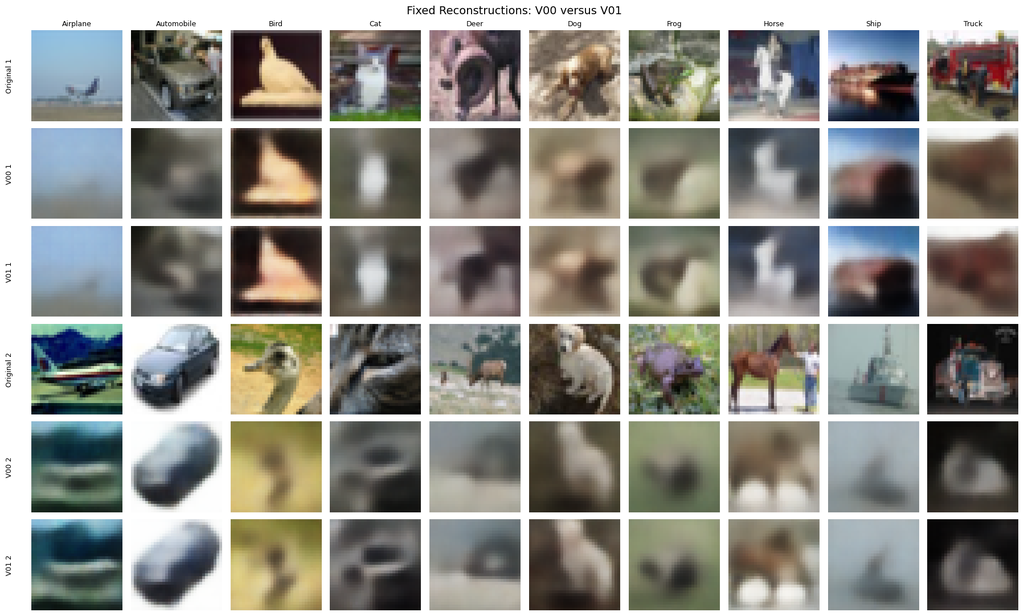

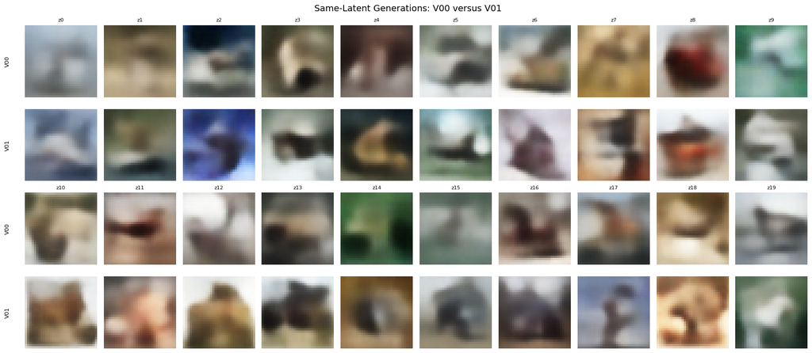

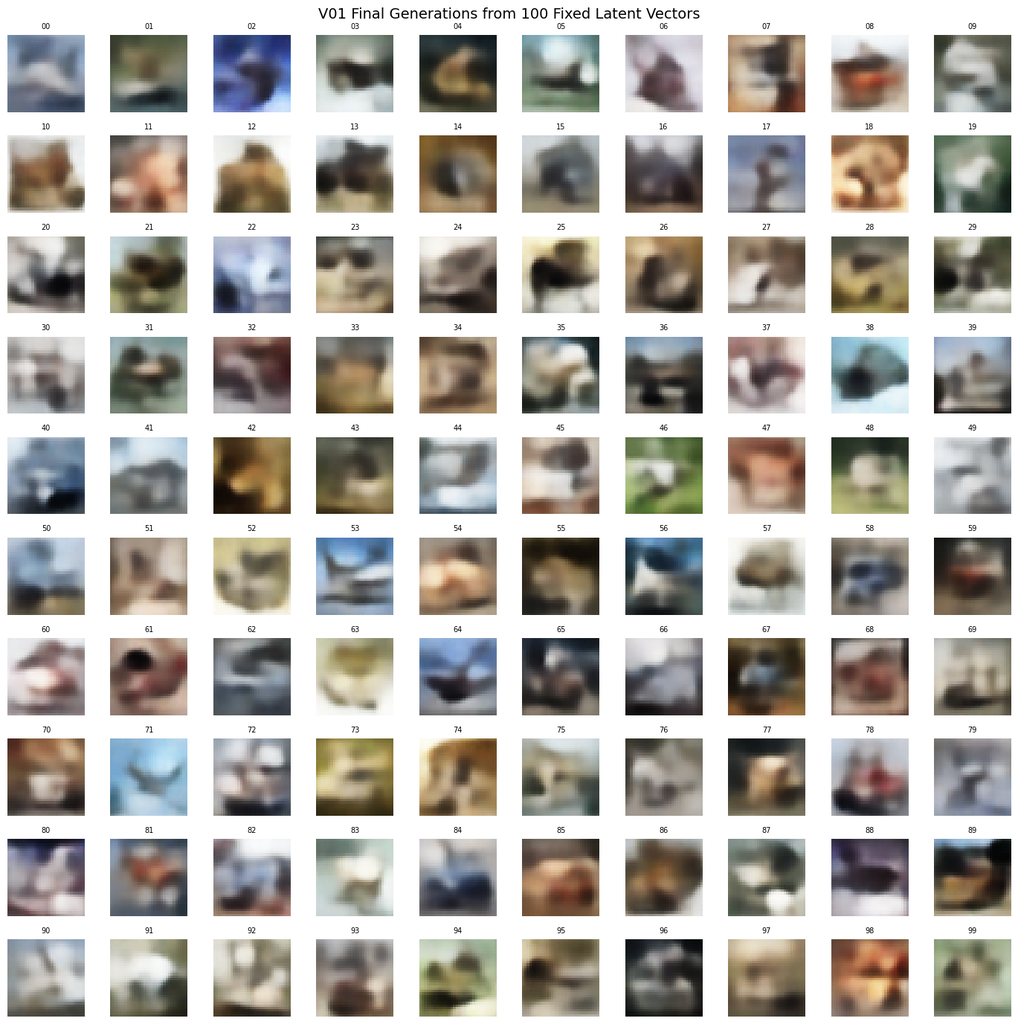

```
Generated descriptor comparison:
```

| descriptor | training_mean | V00_mean | V01_mean | V00_absolute_gap | V01_absolute_gap | gap_reduction_V01 |
| --- | --- | --- | --- | --- | --- | --- |
| brightness | 0.473055 | 0.489685 | 0.491670 | 0.016630 | 0.018615 | -0.001985 |
| contrast | 0.213141 | 0.173136 | 0.187481 | 0.040004 | 0.025660 | 0.014345 |
| red_mean | 0.489844 | 0.513826 | 0.518268 | 0.023982 | 0.028424 | -0.004442 |
| green_mean | 0.482936 | 0.498273 | 0.496388 | 0.015338 | 0.013453 | 0.001885 |
| blue_mean | 0.446386 | 0.456955 | 0.460354 | 0.010570 | 0.013968 | -0.003398 |
| saturation | 0.129711 | 0.109435 | 0.109810 | 0.020276 | 0.019901 | 0.000374 |
| edge_strength | 0.058002 | 0.024764 | 0.030020 | 0.033238 | 0.027982 | 0.005256 |

```
Generated diversity comparison:
```

|  | V00 | V01 | Training_reference |
| --- | --- | --- | --- |
| unique_uint8_images_out_of_100 | 100.000000 | 100.000000 | NaN |
| mean_pixel_standard_deviation | 0.212167 | 0.212463 | 0.249836 |

```
Latent posterior comparison (1,000 training-reference images):
```

| model | mean_unweighted_kl | mean_absolute_z_mean | mean_posterior_std | mean_variance_of_z_mean_dims |
| --- | --- | --- | --- | --- |
| V00_beta_1.0 | 40.043465 | 0.470885 | 0.634754 | 0.511075 |
| V01_beta_0.5 | 62.324078 | 0.604584 | 0.475810 | 0.707226 |

```
Saved comparison artefacts:
- artifacts\vae\V01\evaluation\V00_V01_reconstruction_comparison.csv
- artifacts\vae\V01\evaluation\V00_V01_reconstruction_grid.png
- artifacts\vae\V01\evaluation\V00_V01_paired_generation_grid.png
- artifacts\vae\V01\evaluation\V01_final_generation_grid.png
- artifacts\vae\V01\evaluation\V00_V01_descriptor_comparison.csv
- artifacts\vae\V01\evaluation\V00_V01_latent_diagnostics.csv
Official test-set usage: None
```

```python
print(
    "\nGenerated diversity comparison:"
)
display(
    diversity_comparison_df.round(6)
)

# -------------------------------------------------------
# 4. Latent posterior diagnostics on the same reference
# -------------------------------------------------------
(
    v00_reference_mean,
    v00_reference_log_var,
    _
) = encoder.predict(
    reference_images,
    verbose=0
)
(
    v01_reference_mean,
    v01_reference_log_var,
    _
) = encoder_v01.predict(
    reference_images,
    verbose=0
)


def latent_diagnostic_record(
    model_name,
    z_mean_values,
    z_log_var_values
):
    kl_per_image = -0.5 * np.sum(
        (
            1.0
            + z_log_var_values
            - np.square(
                z_mean_values
            )
            - np.exp(
                z_log_var_values
            )
        ),
        axis=1
    )

    return {
        "model": model_name,
        "mean_unweighted_kl": (
            kl_per_image.mean()
        ),
        "mean_absolute_z_mean": (
            np.abs(
                z_mean_values
            ).mean()
        ),
        "mean_posterior_std": (
            np.exp(
                0.5
                * z_log_var_values
            ).mean()
        ),
        "mean_variance_of_z_mean_dims": (
            np.var(
                z_mean_values,
                axis=0
            ).mean()
        )
    }


latent_diagnostics_df = pd.DataFrame([
    latent_diagnostic_record(
        "V00_beta_1.0",
        v00_reference_mean,
        v00_reference_log_var
    ),
    latent_diagnostic_record(
        "V01_beta_0.5",
        v01_reference_mean,
        v01_reference_log_var
    )
]).set_index("model")

print(
    "\nLatent posterior comparison "
    "(1,000 training-reference images):"
)
display(
    latent_diagnostics_df.round(6)
)

latent_diagnostics_path = (
    v01_evaluation_dir
    / "V00_V01_latent_diagnostics.csv"
)
latent_diagnostics_df.to_csv(
    latent_diagnostics_path
)

print(
    "\nSaved comparison artefacts:"
)
print(
    f"- {comparison_metrics_path}"
)
print(
    f"- {reconstruction_comparison_grid_path}"
)
print(
    f"- {paired_generation_grid_path}"
)
print(
    f"- {v01_generation_grid_path}"
)
print(
    f"- {descriptor_comparison_path}"
)
print(
    f"- {latent_diagnostics_path}"
)
print(
    "Official test-set usage: None"
)
```

### 6.7 V01 Development FID - Saved-Weight Three-Generation-Seed Evaluation

V01 receives the exact development-FID protocol used in the baseline architecture screen:

- final epoch-50 decoder rebuilt and loaded from saved weights;
- 5,000 standard-normal generated samples per run;
- seeds `1001`, `1002`, and `1003`;
- the same frozen InceptionV3 extractor and preprocessing;
- the same 50,000-image training reference;
- individual FID values plus mean, standard deviation, minimum and maximum; and
- no model retraining or official test-set use.

The already completed seed-1001 result is validated and reused. The updated cell calculates only the missing seeds 1002 and 1003, then creates the complete repeated-results and summary files. FID is one selection consideration alongside reconstruction, visual, descriptor, diversity, latent, stability and compute evidence.

```python
INLINE_VAE_FID_SAMPLE_COUNT = (
    BASELINE_FID_SAMPLE_COUNT
)
INLINE_VAE_FID_SEEDS = tuple(
    BASELINE_FID_SEEDS
)
INLINE_VAE_FID_CHECKPOINT_EPOCH = (
    BASELINE_FID_CHECKPOINT_EPOCH
)
INLINE_VAE_FID_REAL_REFERENCE_COUNT = (
    BASELINE_FID_REAL_REFERENCE_COUNT
)

assert INLINE_VAE_FID_SAMPLE_COUNT == 5_000
assert INLINE_VAE_FID_SEEDS == (
    1001,
    1002,
    1003
)
assert INLINE_VAE_FID_CHECKPOINT_EPOCH == 50
assert (
    INLINE_VAE_FID_REAL_REFERENCE_COUNT
    == 50_000
)

inline_fid_required_objects = [
    "build_v00_fid_decoder",
    "generate_vae_images_uint8",
    "extract_vae_inception_features",
    "calculate_vae_feature_statistics",
    "calculate_vae_fid_from_statistics",
    "baseline_fid_feature_extractor",
    "baseline_real_fid_mean",
    "baseline_real_fid_covariance",
    "BASELINE_FID_GENERATION_BATCH_SIZE",
    "BASELINE_FID_BATCH_SIZE"
]
inline_fid_missing_objects = [
    object_name
    for object_name in (
        inline_fid_required_objects
    )
    if object_name not in globals()
]

assert not inline_fid_missing_objects, (
    "Required locked FID objects are "
    "missing from the active kernel: "
    f"{inline_fid_missing_objects}. "
    "Restore the Section 5.6.6 FID setup "
    "and real-reference state without "
    "retraining any VAE."
)


def load_existing_unconditional_fid_rows(
    experiment_id,
    single_result_path,
    repeated_result_path
):
    existing_rows = {}

    repeated_result_path = Path(
        repeated_result_path
    )
    single_result_path = Path(
        single_result_path
    )

    if repeated_result_path.exists():
        existing_repeated_df = pd.read_csv(
            repeated_result_path
        )

        for _, row in (
            existing_repeated_df.iterrows()
        ):
            seed = int(row["seed"])
            if seed in INLINE_VAE_FID_SEEDS:
                existing_rows[seed] = {
                    "experiment_id": (
                        experiment_id
                    ),
                    "checkpoint_epoch": int(
                        row["checkpoint_epoch"]
                    ),
                    "seed": seed,
                    "generated_sample_count": int(
                        row[
                            "generated_sample_count"
                        ]
                    ),
                    "real_reference_count": int(
                        row[
                            "real_reference_count"
                        ]
                    ),
                    "fid": float(row["fid"]),
                    "score_role": (
                        "three_seed_formal_"
                        "comparison"
                    ),
                    "score_source": (
                        "reused_validated_"
                        "repeated_result"
                    ),
                    "test_set_used": False
                }

    if (
        1001 not in existing_rows
        and single_result_path.exists()
    ):
        existing_single_df = pd.read_csv(
            single_result_path
        )

        assert len(existing_single_df) == 1
        row = existing_single_df.iloc[0]
        assert (
            row["experiment_id"]
            == experiment_id
        )
        assert int(row["seed"]) == 1001
        assert int(
            row["generated_sample_count"]
        ) == INLINE_VAE_FID_SAMPLE_COUNT
        assert int(
            row["real_reference_count"]
        ) == (
            INLINE_VAE_FID_REAL_REFERENCE_COUNT
        )
        assert not bool(row["test_set_used"])

        existing_rows[1001] = {
            "experiment_id": experiment_id,
            "checkpoint_epoch": int(
                row["checkpoint_epoch"]
            ),
            "seed": 1001,
            "generated_sample_count": int(
                row["generated_sample_count"]
            ),
            "real_reference_count": int(
                row["real_reference_count"]
            ),
            "fid": float(row["fid"]),
            "score_role": (
                "three_seed_formal_comparison"
            ),
            "score_source": (
                "reused_validated_"
                "single_seed_result"
            ),
            "test_set_used": False
        }

    return existing_rows


def create_repeated_fid_summary(
    repeated_df
):
    summary_df = (
        repeated_df
        .groupby(
            "experiment_id",
            as_index=False
        )
        .agg(
            fid_mean=("fid", "mean"),
            fid_std=("fid", "std"),
            fid_min=("fid", "min"),
            fid_max=("fid", "max"),
            repeat_count=("fid", "size")
        )
    )

    assert len(summary_df) == 1
    assert int(
        summary_df.loc[
            0,
            "repeat_count"
        ]
    ) == len(INLINE_VAE_FID_SEEDS)

    return summary_df


def evaluate_saved_unconditional_vae_fid(
    experiment_id,
    latent_dim,
    decoder_weights_path,
    single_result_path,
    repeated_result_path,
    summary_path
):
    decoder_weights_path = Path(
        decoder_weights_path
    )
    single_result_path = Path(
        single_result_path
    )
    repeated_result_path = Path(
        repeated_result_path
    )
    summary_path = Path(summary_path)

    assert decoder_weights_path.exists(), (
        "Saved decoder weights missing: "
        f"{decoder_weights_path}"
    )

    decoder_model = build_v00_fid_decoder(
        latent_dim=latent_dim
    )
    decoder_model.load_weights(
        str(decoder_weights_path)
    )

    assert decoder_model.input_shape == (
        None,
        latent_dim
    )
    assert decoder_model.output_shape == (
        None,
        32,
        32,
        3
    )

    rows_by_seed = (
        load_existing_unconditional_fid_rows(
            experiment_id=experiment_id,
            single_result_path=(
                single_result_path
            ),
            repeated_result_path=(
                repeated_result_path
            )
        )
    )

    for fid_seed in INLINE_VAE_FID_SEEDS:
        if fid_seed in rows_by_seed:
            print(
                f"Reusing validated "
                f"{experiment_id} seed "
                f"{fid_seed} FID: "
                f"{rows_by_seed[fid_seed]['fid']:.4f}"
            )
            continue

        print(
            f"\nCalculating {experiment_id} "
            f"FID for seed {fid_seed}"
        )

        generated_images = (
            generate_vae_images_uint8(
                decoder_model=decoder_model,
                sample_count=(
                    INLINE_VAE_FID_SAMPLE_COUNT
                ),
                latent_dim=latent_dim,
                seed=fid_seed,
                batch_size=(
                    BASELINE_FID_GENERATION_BATCH_SIZE
                )
            )
        )
        generated_features = (
            extract_vae_inception_features(
                images_uint8=generated_images,
                feature_extractor=(
                    baseline_fid_feature_extractor
                ),
                batch_size=(
                    BASELINE_FID_BATCH_SIZE
                )
            )
        )
        (
            generated_mean,
            generated_covariance
        ) = calculate_vae_feature_statistics(
            generated_features
        )
        fid_value = (
            calculate_vae_fid_from_statistics(
                baseline_real_fid_mean,
                baseline_real_fid_covariance,
                generated_mean,
                generated_covariance
            )
        )

        rows_by_seed[fid_seed] = {
            "experiment_id": experiment_id,
            "checkpoint_epoch": (
                INLINE_VAE_FID_CHECKPOINT_EPOCH
            ),
            "seed": fid_seed,
            "generated_sample_count": (
                INLINE_VAE_FID_SAMPLE_COUNT
            ),
            "real_reference_count": (
                INLINE_VAE_FID_REAL_REFERENCE_COUNT
            ),
            "fid": float(fid_value),
            "score_role": (
                "three_seed_formal_comparison"
            ),
            "score_source": (
                "calculated_in_experiment"
            ),
            "test_set_used": False
        }

        print(
            f"{experiment_id} seed "
            f"{fid_seed} FID: "
            f"{fid_value:.4f}"
        )

        del generated_images
        del generated_features
        del generated_mean
        del generated_covariance
        gc.collect()

    repeated_df = (
        pd.DataFrame(
            list(rows_by_seed.values())
        )
        .sort_values("seed")
        .reset_index(drop=True)
    )

    assert len(repeated_df) == 3
    assert tuple(
        repeated_df["seed"].astype(int)
    ) == INLINE_VAE_FID_SEEDS
    assert (
        repeated_df[
            "generated_sample_count"
        ] == INLINE_VAE_FID_SAMPLE_COUNT
    ).all()
    assert (
        repeated_df[
            "real_reference_count"
        ] == (
            INLINE_VAE_FID_REAL_REFERENCE_COUNT
        )
    ).all()
    assert np.isfinite(
        repeated_df["fid"]
    ).all()
    assert not repeated_df[
        "test_set_used"
    ].any()

    summary_df = create_repeated_fid_summary(
        repeated_df
    )

    repeated_result_path.parent.mkdir(
        parents=True,
        exist_ok=True
    )
    repeated_df.to_csv(
        repeated_result_path,
        index=False
    )
    summary_df.to_csv(
        summary_path,
        index=False
    )

    return (
        repeated_df,
        summary_df,
        decoder_model
    )


v01_inline_fid_weights_path = (
    Path("artifacts")
    / "vae"
    / "V01"
    / "weights"
    / "V01_decoder_final.weights.h5"
)
v01_single_fid_result_path = (
    Path("artifacts")
    / "vae"
    / "V01"
    / "evaluation"
    / "V01_development_fid.csv"
)
v01_repeated_fid_result_path = (
    Path("artifacts")
    / "vae"
    / "V01"
    / "evaluation"
    / "V01_repeated_development_fid.csv"
)
v01_fid_summary_path = (
    Path("artifacts")
    / "vae"
    / "V01"
    / "evaluation"
    / "V01_development_fid_summary.csv"
)

(
    v01_repeated_fid_df,
    v01_fid_summary_df,
    v01_inline_fid_decoder
) = evaluate_saved_unconditional_vae_fid(
    experiment_id="V01",
    latent_dim=64,
    decoder_weights_path=(
        v01_inline_fid_weights_path
    ),
    single_result_path=(
        v01_single_fid_result_path
    ),
    repeated_result_path=(
        v01_repeated_fid_result_path
    ),
    summary_path=v01_fid_summary_path
)

print(
    "\nV01 repeated development-FID "
    "results:"
)
display(
    v01_repeated_fid_df.round(4)
)
print(
    "\nV01 FID summary "
    "(lower is better):"
)
display(
    v01_fid_summary_df.round(4)
)
print(
    "Repeated results saved to: "
    f"{v01_repeated_fid_result_path}"
)
print(
    "Summary saved to: "
    f"{v01_fid_summary_path}"
)
print("V01 retrained: No")
print("Official test-set usage: None")
```

```
Reusing validated V01 seed 1001 FID: 157.2114

Calculating V01 FID for seed 1002
```

```
V01 seed 1002 FID: 158.4197

Calculating V01 FID for seed 1003
```

```
V01 seed 1003 FID: 158.5634

V01 repeated development-FID results:
```

|  | experiment_id | checkpoint_epoch | seed | generated_sample_count | real_reference_count | fid | score_role | score_source | test_set_used |
| --- | --- | --- | --- | --- | --- | --- | --- | --- | --- |
| 0 | V01 | 50 | 1001 | 5000 | 50000 | 157.2114 | three_seed_formal_comparison | reused_validated_single_seed_result | False |
| 1 | V01 | 50 | 1002 | 5000 | 50000 | 158.4197 | three_seed_formal_comparison | calculated_in_experiment | False |
| 2 | V01 | 50 | 1003 | 5000 | 50000 | 158.5634 | three_seed_formal_comparison | calculated_in_experiment | False |

```
V01 FID summary (lower is better):
```

|  | experiment_id | fid_mean | fid_std | fid_min | fid_max | repeat_count |
| --- | --- | --- | --- | --- | --- | --- |
| 0 | V01 | 158.0648 | 0.7426 | 157.2114 | 158.5634 | 3 |

```
Repeated results saved to: artifacts\vae\V01\evaluation\V01_repeated_development_fid.csv
Summary saved to: artifacts\vae\V01\evaluation\V01_development_fid_summary.csv
V01 retrained: No
Official test-set usage: None
```

### 6.8 V01 Decision - Accepted as the Current Family Incumbent

V01 is accepted as the parent for the next controlled experiment. This is an evidence-based intermediate decision, not a claim that the model is final.

#### Evidence Supporting Acceptance

V01 trained stably for all 50 epochs. Its fixed reconstruction MSE improved from 0.02015 at epoch 1 to 0.00783 at epoch 50, while PSNR increased from 17.347 dB to 21.661 dB. The checkpoint grid shows the largest qualitative improvement by epoch 10, followed by smaller refinements through epoch 50.

Against V00 on the same 20 fixed images, V01 achieved:

- an 18.30% reduction in MSE, from 0.00958 to 0.00783;
- a 10.73% reduction in MAE, from 0.07171 to 0.06401;
- a 0.892 dB increase in PSNR, from 20.768 to 21.661 dB; and
- lower MSE and higher PSNR for every one of the ten CIFAR-10 classes represented in the fixed set.

The reconstruction grid supports these numerical results: V01 generally retains stronger contours and more local detail than V00, although both models remain visibly blurred.

The locked three-generation-seed FID protocol produced **158.0648 ± 0.7426** for V01, compared with **166.6486 ± 0.4074** for V00. This is a **5.15% lower mean FID**, and every V01 generation seed scored below every V00 generation seed. The distributional result therefore supports the reconstruction and edge improvements rather than contradicting them. These repetitions reuse each model's same saved weights, so they measure sampling variation rather than independent-training variability. FID is still interpreted with the visual, diversity, latent, stability and efficiency evidence because it does not measure recognisability by itself.

Fixed-latent generation did not show complete mode collapse. Both models produced 100 unique uint8 images out of 100, and mean pixel diversity was essentially unchanged (0.21217 for V00 and 0.21246 for V01). Relative to the stratified training reference, V01 reduced the contrast gap by 35.86% and the edge-strength gap by 15.81%. Its generated samples consequently contain somewhat stronger local structure than V00.

#### Trade-Off and Remaining Risk

Lowering `β` weakened prior matching as expected. On the same 1,000-image training reference, mean unweighted KL increased by 55.64%, mean posterior standard deviation decreased by 25.04%, and variance across latent means increased by 38.38%. This does not prove failure, because fixed prior samples remained varied, but it warns against reducing `β` again without stronger evidence.

V01 also did not improve every descriptor. Brightness, red-channel mean, and blue-channel mean moved further from the training reference, while the saturation-gap reduction was only 1.84%. Most importantly, generated edge strength remains about 48% below the training reference, matching the continuing visual blur and ambiguous object identity.

V01 therefore provides the better reconstruction-generation trade-off within the tested family and becomes the current incumbent. It remains unconditional, so named classes still cannot be requested. The next experiment keeps `β = 0.5` and targets residual information capacity rather than weakening regularisation further.

## 7. Controlled Improvement 2 - V02 Larger Latent Dimension

### 7.1 Decision, Hypothesis, and Controls

V02 changes one deliberate modelling factor: latent dimension increases from 64 to 128 while `β = 0.5` and all other training conditions remain fixed.

V01 improved reconstruction detail, yet its images still lose fine boundaries and texture. A 64-dimensional bottleneck may restrict how much image-specific information can be represented for colour CIFAR-10 images. A larger latent vector gives the encoder and decoder more capacity to describe variations in colour, layout, and local structure.

**Hypothesis:** V02 will further reduce fixed reconstruction MSE and MAE, increase PSNR, and improve generated contrast or edge strength without materially reducing fixed-prior sample diversity.

**Risk:** more dimensions increase model capacity and parameter count. Some dimensions may be unused, or the aggregate posterior may become harder to align with the standard-normal prior. V02 must therefore be judged using both reconstruction and unconditional generation evidence, not reconstruction loss alone.

| Factor | V01 incumbent | V02 |
| --- | --- | --- |
| Main deliberate change | - | Latent dimension `64 → 128` |
| KL weight `β` | 0.5 | 0.5 |
| Encoder/decoder convolution blocks | Same | Same |
| Reconstruction loss | BCE sum | BCE sum |
| Optimiser | Adam | Adam |
| Learning rate | 0.001 | 0.001 |
| Batch size | 128 | 128 |
| Epochs | 50 | 50 |
| Data augmentation | None | None |
| Training images | 50,000 | 50,000 |
| Test-set usage | None | None |
| Seed | 42 | 42 |

Changing the latent width necessarily enlarges the two encoder heads and the decoder's first dense layer. This parameter increase is a direct consequence of the single latent-dimension change, rather than a second independently tuned factor. The architecture cell reports the exact counts for transparent comparison.

```python
# Build V02 with the V01 convolutional design and
# a single deliberate change: latent dimension 128.
V02_EXPERIMENT_ID = "V02"
V02_LATENT_DIM = 128
V02_BETA = V01_BETA

tf.keras.utils.set_random_seed(SEED)

encoder_inputs_v02 = keras.Input(
    shape=INPUT_SHAPE,
    name="V02_encoder_input"
)

x_v02 = layers.Conv2D(
    filters=32,
    kernel_size=3,
    strides=2,
    padding="same",
    activation="relu",
    name="V02_encoder_conv_1"
)(encoder_inputs_v02)

x_v02 = layers.Conv2D(
    filters=64,
    kernel_size=3,
    strides=2,
    padding="same",
    activation="relu",
    name="V02_encoder_conv_2"
)(x_v02)

x_v02 = layers.Conv2D(
    filters=128,
    kernel_size=3,
    strides=2,
    padding="same",
    activation="relu",
    name="V02_encoder_conv_3"
)(x_v02)

x_v02 = layers.Flatten(
    name="V02_encoder_flatten"
)(x_v02)

x_v02 = layers.Dense(
    units=256,
    activation="relu",
    name="V02_encoder_dense"
)(x_v02)

z_mean_v02 = layers.Dense(
    units=V02_LATENT_DIM,
    name="V02_z_mean"
)(x_v02)

z_log_var_v02 = layers.Dense(
    units=V02_LATENT_DIM,
    name="V02_z_log_var"
)(x_v02)

z_v02 = Sampling(
    name="V02_z_sampling"
)([
    z_mean_v02,
    z_log_var_v02
])

encoder_v02 = keras.Model(
    inputs=encoder_inputs_v02,
    outputs=[
        z_mean_v02,
        z_log_var_v02,
        z_v02
    ],
    name="V02_encoder"
)

decoder_inputs_v02 = keras.Input(
    shape=(V02_LATENT_DIM,),
    name="V02_decoder_input"
)

y_v02 = layers.Dense(
    units=4 * 4 * 128,
    activation="relu",
    name="V02_decoder_dense"
)(decoder_inputs_v02)

y_v02 = layers.Reshape(
    target_shape=(4, 4, 128),
    name="V02_decoder_reshape"
)(y_v02)

y_v02 = layers.Conv2DTranspose(
    filters=128,
    kernel_size=3,
    strides=2,
    padding="same",
    activation="relu",
    name="V02_decoder_deconv_1"
)(y_v02)

y_v02 = layers.Conv2DTranspose(
    filters=64,
    kernel_size=3,
    strides=2,
    padding="same",
    activation="relu",
    name="V02_decoder_deconv_2"
)(y_v02)

y_v02 = layers.Conv2DTranspose(
    filters=32,
    kernel_size=3,
    strides=2,
    padding="same",
    activation="relu",
    name="V02_decoder_deconv_3"
)(y_v02)

decoder_outputs_v02 = layers.Conv2D(
    filters=3,
    kernel_size=3,
    strides=1,
    padding="same",
    activation="sigmoid",
    name="V02_decoder_output"
)(y_v02)

decoder_v02 = keras.Model(
    inputs=decoder_inputs_v02,
    outputs=decoder_outputs_v02,
    name="V02_decoder"
)

assert V02_BETA == V01_BETA
assert V02_LATENT_DIM == 2 * V01_LATENT_DIM
assert encoder_v02.count_params() == 683584
assert decoder_v02.count_params() == 504899

v01_total_parameters = (
    encoder_v01.count_params()
    + decoder_v01.count_params()
)
v02_total_parameters = (
    encoder_v02.count_params()
    + decoder_v02.count_params()
)
v02_parameter_increase_percent = (
    (v02_total_parameters - v01_total_parameters)
    / v01_total_parameters
    * 100.0
)

# Use a reproducible 128-D prior sample. The first
# 64 columns match the established fixed V00/V01
# vectors; the extra 64 columns use a separate seed.
fixed_inputs_dir = (
    Path("artifacts")
    / "vae"
    / "fixed_inputs"
)
v01_fixed_latent_path = (
    fixed_inputs_dir
    / "fixed_latent_vectors_dim64.npy"
)
assert v01_fixed_latent_path.exists()

fixed_latent_vectors_dim64 = np.load(
    v01_fixed_latent_path
).astype(np.float32)
assert fixed_latent_vectors_dim64.shape == (
    100,
    V01_LATENT_DIM
)

v02_latent_rng = np.random.default_rng(
    SEED + 202
)
v02_extra_latent_dimensions = (
    v02_latent_rng.normal(
        size=(
            fixed_latent_vectors_dim64.shape[0],
            V02_LATENT_DIM - V01_LATENT_DIM
        )
    ).astype(np.float32)
)
fixed_latent_vectors_v02 = np.concatenate(
    [
        fixed_latent_vectors_dim64,
        v02_extra_latent_dimensions
    ],
    axis=1
)
assert fixed_latent_vectors_v02.shape == (
    100,
    V02_LATENT_DIM
)
assert np.isfinite(
    fixed_latent_vectors_v02
).all()

v02_fixed_latent_path = (
    fixed_inputs_dir
    / "fixed_latent_vectors_dim128.npy"
)
np.save(
    v02_fixed_latent_path,
    fixed_latent_vectors_v02
)

print(f"Experiment ID: {V02_EXPERIMENT_ID}")
print(
    "Main change: latent dimension "
    f"{V01_LATENT_DIM} -> {V02_LATENT_DIM}"
)
print(f"Beta held constant: {V02_BETA}")
print(
    "V02 encoder parameters: "
    f"{encoder_v02.count_params():,}"
)
print(
    "V02 decoder parameters: "
    f"{decoder_v02.count_params():,}"
)
print(
    "V02 total parameters: "
    f"{v02_total_parameters:,}"
)
print(
    "Parameter increase versus V01: "
    f"{v02_parameter_increase_percent:.2f}%"
)
print(
    "Fixed V02 latent vectors saved to: "
    f"{v02_fixed_latent_path}"
)
print("Official test-set usage: None")

encoder_v02.summary()
decoder_v02.summary()
```

```
Experiment ID: V02
Main change: latent dimension 64 -> 128
Beta held constant: 0.5
V02 encoder parameters: 683,584
V02 decoder parameters: 504,899
V02 total parameters: 1,188,483
Parameter increase versus V01: 16.00%
Fixed V02 latent vectors saved to: artifacts\vae\fixed_inputs\fixed_latent_vectors_dim128.npy
Official test-set usage: None
Model: "V02_encoder"
__________________________________________________________________________________________________
 Layer (type)                   Output Shape         Param #     Connected to
==================================================================================================
 V02_encoder_input (InputLayer)  [(None, 32, 32, 3)]  0          []

 V02_encoder_conv_1 (Conv2D)    (None, 16, 16, 32)   896         ['V02_encoder_input[0][0]']

 V02_encoder_conv_2 (Conv2D)    (None, 8, 8, 64)     18496       ['V02_encoder_conv_1[0][0]']

 V02_encoder_conv_3 (Conv2D)    (None, 4, 4, 128)    73856       ['V02_encoder_conv_2[0][0]']

 V02_encoder_flatten (Flatten)  (None, 2048)         0           ['V02_encoder_conv_3[0][0]']

 V02_encoder_dense (Dense)      (None, 256)          524544      ['V02_encoder_flatten[0][0]']

 V02_z_mean (Dense)             (None, 128)          32896       ['V02_encoder_dense[0][0]']

 V02_z_log_var (Dense)          (None, 128)          32896       ['V02_encoder_dense[0][0]']

 V02_z_sampling (Sampling)      (None, 128)          0           ['V02_z_mean[0][0]',
                                                                  'V02_z_log_var[0][0]']

==================================================================================================
Total params: 683,584
Trainable params: 683,584
Non-trainable params: 0
__________________________________________________________________________________________________
Model: "V02_decoder"
_________________________________________________________________
 Layer (type)                Output Shape              Param #
```

[output cut: 10 more lines]

```
 DTranspose)

 V02_decoder_deconv_2 (Conv2  (None, 16, 16, 64)       73792
 DTranspose)

 V02_decoder_deconv_3 (Conv2  (None, 32, 32, 32)       18464
 DTranspose)

 V02_decoder_output (Conv2D)  (None, 32, 32, 3)        867

=================================================================
Total params: 504,899
Trainable params: 504,899
Non-trainable params: 0
_________________________________________________________________
```

### 7.2 V02 Training

V02 is trained from a fresh seeded initialisation for 50 epochs. The data, optimiser, learning rate, batch size, loss formulation, `β`, shuffling behaviour, and milestone epochs are unchanged from V01. Checkpoints at epochs 1, 10, 25, 40, and 50 support the same progression analysis used for the earlier models.

No validation or test images are used. This keeps the protected CIFAR-10 test set untouched until final model selection.

```python
# Create, train, and save the controlled V02 model.
V02_LEARNING_RATE = LEARNING_RATE
V02_BATCH_SIZE = BATCH_SIZE
V02_EPOCHS = EPOCHS
V02_MILESTONE_EPOCHS = [
    1,
    10,
    25,
    40,
    V02_EPOCHS
]

vae_v02 = VAE(
    encoder=encoder_v02,
    decoder=decoder_v02,
    beta=V02_BETA,
    name="V02_vae"
)

vae_v02.compile(
    optimizer=keras.optimizers.Adam(
        learning_rate=V02_LEARNING_RATE
    )
)

_ = vae_v02(
    tf.zeros(
        shape=(1,) + INPUT_SHAPE,
        dtype=tf.float32
    ),
    training=False
)

v02_artifact_dir = (
    Path("artifacts") / "vae" / "V02"
)
v02_checkpoint_dir = (
    v02_artifact_dir / "checkpoints"
)
v02_weight_dir = (
    v02_artifact_dir / "weights"
)

for directory in [
    v02_artifact_dir,
    v02_checkpoint_dir,
    v02_weight_dir
]:
    directory.mkdir(
        parents=True,
        exist_ok=True
    )

assert x_train_vae.shape == (50000, 32, 32, 3)
assert x_train_vae.dtype == np.float32
assert np.isfinite(x_train_vae).all()


class V02MilestoneWeightsSaver(
    keras.callbacks.Callback
):
    """Saves fixed V02 epoch checkpoints."""

    def __init__(
        self,
        checkpoint_dir,
        milestone_epochs
    ):
        super().__init__()
        self.checkpoint_dir = Path(checkpoint_dir)
        self.milestone_epochs = set(milestone_epochs)
        self.saved_paths = []

    def on_epoch_end(self, epoch, logs=None):
        completed_epoch = epoch + 1

        if completed_epoch in self.milestone_epochs:
            checkpoint_path = (
                self.checkpoint_dir
                / (
                    "V02_epoch_"
                    f"{completed_epoch:03d}"
                    ".weights.h5"
                )
            )
            self.model.save_weights(
                str(checkpoint_path)
            )
            self.saved_paths.append(checkpoint_path)
            print(
                "\nSaved fixed V02 milestone "
                f"checkpoint: {checkpoint_path}"
            )


v02_milestone_saver = V02MilestoneWeightsSaver(
    checkpoint_dir=v02_checkpoint_dir,
    milestone_epochs=V02_MILESTONE_EPOCHS
)

print("Starting V02 controlled training.")
print(
    "Main change: latent dimension "
    f"{V01_LATENT_DIM} -> {V02_LATENT_DIM}"
)
print(f"Beta held constant: {V02_BETA}")
print(f"Epochs: {V02_EPOCHS}")
print(f"Batch size: {V02_BATCH_SIZE}")
print(f"Learning rate: {V02_LEARNING_RATE}")
print("Data augmentation: None")
print("Official test-set usage: None")

v02_training_start_time = time.perf_counter()

vae_v02_history = vae_v02.fit(
    x=x_train_vae,
    epochs=V02_EPOCHS,
    batch_size=V02_BATCH_SIZE,
    shuffle=True,
    callbacks=[
        keras.callbacks.TerminateOnNaN(),
        v02_milestone_saver
    ],
    verbose=2
)

v02_training_duration_seconds = (
    time.perf_counter() - v02_training_start_time
)

v02_history_df = pd.DataFrame(
    vae_v02_history.history
)
v02_history_df.index = np.arange(
    1,
    len(v02_history_df) + 1
)
v02_history_df.index.name = "epoch"

v02_history_path = (
    v02_artifact_dir / "V02_training_history.csv"
)
v02_history_df.to_csv(v02_history_path)

v02_final_vae_weights_path = (
    v02_weight_dir / "V02_vae_final.weights.h5"
)
v02_final_encoder_weights_path = (
    v02_weight_dir / "V02_encoder_final.weights.h5"
)
v02_final_decoder_weights_path = (
    v02_weight_dir / "V02_decoder_final.weights.h5"
)

vae_v02.save_weights(str(v02_final_vae_weights_path))
encoder_v02.save_weights(str(v02_final_encoder_weights_path))
decoder_v02.save_weights(str(v02_final_decoder_weights_path))

v02_training_record = {
    "experiment_id": V02_EXPERIMENT_ID,
    "parent_experiment": V01_EXPERIMENT_ID,
    "main_change": "latent dimension 64 to 128",
    "input_shape": list(INPUT_SHAPE),
    "latent_dimension": V02_LATENT_DIM,
    "beta": V02_BETA,
    "optimizer": "Adam",
    "learning_rate": V02_LEARNING_RATE,
    "batch_size": V02_BATCH_SIZE,
    "epochs_requested": V02_EPOCHS,
    "epochs_completed": len(v02_history_df),
    "data_augmentation": None,
    "validation_split": None,
    "test_set_used": False,
    "seed": SEED,
    "milestone_epochs": V02_MILESTONE_EPOCHS,
    "encoder_parameters": encoder_v02.count_params(),
    "decoder_parameters": decoder_v02.count_params(),
    "training_duration_seconds": (
        v02_training_duration_seconds
    )
}

v02_training_record_path = (
    v02_artifact_dir / "V02_training_record.json"
)
with v02_training_record_path.open(
    "w",
    encoding="utf-8"
) as record_file:
    json.dump(
        v02_training_record,
        record_file,
        indent=4
    )

print("\nV02 controlled training completed.")
print(
    "Training duration: "
    f"{v02_training_duration_seconds / 60:.2f} minutes"
)
print(f"History saved to: {v02_history_path}")
print(
    "Training record saved to: "
    f"{v02_training_record_path}"
)
print(
    "Final VAE weights saved to: "
    f"{v02_final_vae_weights_path}"
)
print(
    "Final encoder weights saved to: "
    f"{v02_final_encoder_weights_path}"
)
print(
    "Final decoder weights saved to: "
    f"{v02_final_decoder_weights_path}"
)
```

```
Starting V02 controlled training.
Main change: latent dimension 64 -> 128
Beta held constant: 0.5
Epochs: 50
Batch size: 128
Learning rate: 0.001
Data augmentation: None
Official test-set usage: None

Saved fixed V02 milestone checkpoint: artifacts\vae\V02\checkpoints\V02_epoch_001.weights.h5
391/391 - 15s - loss: 1958.5592 - total_loss: 1958.5592 - reconstruction_loss: 1944.7856 - kl_loss: 27.5452 - 15s/epoch - 38ms/step
391/391 - 12s - loss: 1856.6946 - total_loss: 1856.6946 - reconstruction_loss: 1834.8782 - kl_loss: 43.6289 - 12s/epoch - 31ms/step
391/391 - 12s - loss: 1830.7385 - total_loss: 1830.7385 - reconstruction_loss: 1807.8330 - kl_loss: 45.8111 - 12s/epoch - 31ms/step
391/391 - 12s - loss: 1820.1884 - total_loss: 1820.1884 - reconstruction_loss: 1796.4027 - kl_loss: 47.5698 - 12s/epoch - 31ms/step
391/391 - 12s - loss: 1814.2114 - total_loss: 1814.2114 - reconstruction_loss: 1789.5470 - kl_loss: 49.3294 - 12s/epoch - 31ms/step
391/391 - 12s - loss: 1810.4963 - total_loss: 1810.4963 - reconstruction_loss: 1785.2887 - kl_loss: 50.4146 - 12s/epoch - 30ms/step
391/391 - 12s - loss: 1807.3998 - total_loss: 1807.3998 - reconstruction_loss: 1781.5718 - kl_loss: 51.6560 - 12s/epoch - 31ms/step
391/391 - 12s - loss: 1805.2235 - total_loss: 1805.2235 - reconstruction_loss: 1779.0009 - kl_loss: 52.4451 - 12s/epoch - 30ms/step
391/391 - 13s - loss: 1803.5371 - total_loss: 1803.5371 - reconstruction_loss: 1776.8955 - kl_loss: 53.2826 - 13s/epoch - 32ms/step

Saved fixed V02 milestone checkpoint: artifacts\vae\V02\checkpoints\V02_epoch_010.weights.h5
391/391 - 13s - loss: 1802.1819 - total_loss: 1802.1819 - reconstruction_loss: 1775.1235 - kl_loss: 54.1170 - 13s/epoch - 33ms/step
391/391 - 12s - loss: 1800.7041 - total_loss: 1800.7041 - reconstruction_loss: 1773.2417 - kl_loss: 54.9252 - 12s/epoch - 32ms/step
391/391 - 12s - loss: 1799.6705 - total_loss: 1799.6705 - reconstruction_loss: 1771.8850 - kl_loss: 55.5725 - 12s/epoch - 31ms/step
391/391 - 12s - loss: 1798.5609 - total_loss: 1798.5609 - reconstruction_loss: 1770.4092 - kl_loss: 56.3026 - 12s/epoch - 31ms/step
391/391 - 12s - loss: 1797.7557 - total_loss: 1797.7557 - reconstruction_loss: 1769.3555 - kl_loss: 56.8004 - 12s/epoch - 31ms/step
391/391 - 13s - loss: 1796.9325 - total_loss: 1796.9325 - reconstruction_loss: 1768.3109 - kl_loss: 57.2419 - 13s/epoch - 32ms/step
391/391 - 15s - loss: 1796.3387 - total_loss: 1796.3387 - reconstruction_loss: 1767.5515 - kl_loss: 57.5740 - 15s/epoch - 38ms/step
391/391 - 12s - loss: 1795.9990 - total_loss: 1795.9990 - reconstruction_loss: 1767.0515 - kl_loss: 57.8934 - 12s/epoch - 31ms/step
391/391 - 12s - loss: 1795.4895 - total_loss: 1795.4895 - reconstruction_loss: 1766.3850 - kl_loss: 58.2110 - 12s/epoch - 31ms/step
391/391 - 13s - loss: 1795.1044 - total_loss: 1795.1044 - reconstruction_loss: 1765.8165 - kl_loss: 58.5738 - 13s/epoch - 33ms/step
391/391 - 13s - loss: 1794.3846 - total_loss: 1794.3846 - reconstruction_loss: 1764.9117 - kl_loss: 58.9473 - 13s/epoch - 33ms/step
391/391 - 12s - loss: 1794.0098 - total_loss: 1794.0098 - reconstruction_loss: 1764.3947 - kl_loss: 59.2261 - 12s/epoch - 30ms/step
391/391 - 13s - loss: 1793.7324 - total_loss: 1793.7324 - reconstruction_loss: 1763.9742 - kl_loss: 59.5168 - 13s/epoch - 33ms/step
391/391 - 13s - loss: 1793.2014 - total_loss: 1793.2014 - reconstruction_loss: 1763.2874 - kl_loss: 59.8270 - 13s/epoch - 32ms/step
391/391 - 12s - loss: 1793.4567 - total_loss: 1793.4567 - reconstruction_loss: 1763.4480 - kl_loss: 60.0169 - 12s/epoch - 32ms/step

Saved fixed V02 milestone checkpoint: artifacts\vae\V02\checkpoints\V02_epoch_025.weights.h5
391/391 - 13s - loss: 1792.6582 - total_loss: 1792.6582 - reconstruction_loss: 1762.5055 - kl_loss: 60.3035 - 13s/epoch - 32ms/step
391/391 - 12s - loss: 1792.4680 - total_loss: 1792.4680 - reconstruction_loss: 1762.2538 - kl_loss: 60.4233 - 12s/epoch - 32ms/step
```

[output cut: 21 more lines]

```
391/391 - 12s - loss: 1788.8973 - total_loss: 1788.8973 - reconstruction_loss: 1757.2659 - kl_loss: 63.2614 - 12s/epoch - 31ms/step
391/391 - 12s - loss: 1788.8512 - total_loss: 1788.8512 - reconstruction_loss: 1757.1688 - kl_loss: 63.3609 - 12s/epoch - 32ms/step
391/391 - 13s - loss: 1788.8027 - total_loss: 1788.8027 - reconstruction_loss: 1757.0448 - kl_loss: 63.5191 - 13s/epoch - 33ms/step
391/391 - 12s - loss: 1788.3917 - total_loss: 1788.3917 - reconstruction_loss: 1756.5802 - kl_loss: 63.6247 - 12s/epoch - 32ms/step

Saved fixed V02 milestone checkpoint: artifacts\vae\V02\checkpoints\V02_epoch_050.weights.h5
391/391 - 12s - loss: 1788.4215 - total_loss: 1788.4215 - reconstruction_loss: 1756.5542 - kl_loss: 63.7371 - 12s/epoch - 30ms/step

V02 controlled training completed.
Training duration: 10.43 minutes
History saved to: artifacts\vae\V02\V02_training_history.csv
Training record saved to: artifacts\vae\V02\V02_training_record.json
Final VAE weights saved to: artifacts\vae\V02\weights\V02_vae_final.weights.h5
Final encoder weights saved to: artifacts\vae\V02\weights\V02_encoder_final.weights.h5
Final decoder weights saved to: artifacts\vae\V02\weights\V02_decoder_final.weights.h5
```

### 7.3 V02 Training Diagnostics

The following cell verifies that all 50 epochs were recorded with finite total, reconstruction, and KL losses. It displays the first and final losses, the last ten epochs, and matching loss curves. Interpretation is intentionally deferred until these outputs exist.

```
V02 training-history validation passed.
Recorded epochs: 50

First-epoch V02 losses:
total_loss             1958.5592
reconstruction_loss    1944.7856
kl_loss                  27.5452
Name: 1, dtype: float64

Final-epoch V02 losses:
total_loss             1788.4215
reconstruction_loss    1756.5542
kl_loss                  63.7371
Name: 50, dtype: float64

Last 10 V02 epochs:
```

| epoch | total_loss | reconstruction_loss | kl_loss |
| --- | --- | --- | --- |
| 41 | 1789.7065 | 1758.3837 | 62.6468 |
| 42 | 1789.3191 | 1757.9380 | 62.7617 |
| 43 | 1789.2588 | 1757.8739 | 62.7733 |
| 44 | 1789.2144 | 1757.7489 | 62.9341 |
| 45 | 1789.0671 | 1757.5411 | 63.0514 |
| 46 | 1788.8973 | 1757.2659 | 63.2614 |
| 47 | 1788.8512 | 1757.1688 | 63.3609 |
| 48 | 1788.8027 | 1757.0448 | 63.5191 |
| 49 | 1788.3917 | 1756.5802 | 63.6247 |
| 50 | 1788.4215 | 1756.5542 | 63.7371 |

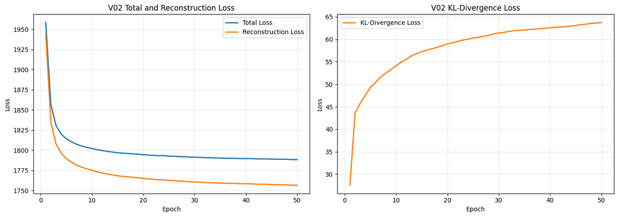

```
V02 training-loss figure saved to: artifacts\vae\V02\V02_training_loss_curves.png
```

```python
# Validate and display the V02 training history.
v02_required_columns = [
    "total_loss",
    "reconstruction_loss",
    "kl_loss"
]

v02_missing_columns = [
    column
    for column in v02_required_columns
    if column not in v02_history_df.columns
]

assert not v02_missing_columns, (
    "Missing V02 history columns: "
    f"{v02_missing_columns}"
)
assert len(v02_history_df) == V02_EPOCHS
assert np.isfinite(
    v02_history_df[v02_required_columns].to_numpy()
).all()

print("V02 training-history validation passed.")
print(f"Recorded epochs: {len(v02_history_df)}")

print("\nFirst-epoch V02 losses:")
print(
    v02_history_df.loc[
        1,
        v02_required_columns
    ].round(4)
)

print("\nFinal-epoch V02 losses:")
print(
    v02_history_df.loc[
        V02_EPOCHS,
        v02_required_columns
    ].round(4)
)

print("\nLast 10 V02 epochs:")
display(
    v02_history_df[
        v02_required_columns
    ].tail(10).round(4)
)

fig, axes = plt.subplots(
    nrows=1,
    ncols=2,
    figsize=(14, 5)
)

axes[0].plot(
    v02_history_df.index,
    v02_history_df["total_loss"],
    label="Total Loss",
    linewidth=2
)
axes[0].plot(
    v02_history_df.index,
    v02_history_df["reconstruction_loss"],
    label="Reconstruction Loss",
    linewidth=2
)
axes[0].set_title(
    "V02 Total and Reconstruction Loss"
)
axes[0].set_xlabel("Epoch")
axes[0].set_ylabel("Loss")
axes[0].grid(alpha=0.3)
axes[0].legend()

axes[1].plot(
    v02_history_df.index,
    v02_history_df["kl_loss"],
    color="tab:orange",
    label="KL-Divergence Loss",
    linewidth=2
)
axes[1].set_title("V02 KL-Divergence Loss")
axes[1].set_xlabel("Epoch")
axes[1].set_ylabel("Loss")
axes[1].grid(alpha=0.3)
axes[1].legend()

plt.tight_layout()

v02_training_curve_path = (
    v02_artifact_dir / "V02_training_loss_curves.png"
)
plt.savefig(
    v02_training_curve_path,
    dpi=150,
    bbox_inches="tight"
)
plt.show()

print(
    "V02 training-loss figure saved to: "
    f"{v02_training_curve_path}"
)
```

### 7.4 V02 Training Interpretation

V02 completed all 50 epochs without non-finite losses. The total and reconstruction losses fell sharply during the early epochs and then improved gradually, while KL divergence rose smoothly as the encoder used the latent representation. There is no numerical instability in the saved training evidence.

The final V02 losses were total loss 1788.4215, reconstruction loss 1756.5542, and unweighted KL loss 63.7371. Compared with V01's final reconstruction loss of 1758.7421, V02 improved by only 2.1879 loss units, or approximately 0.12%, despite increasing the combined encoder-plus-decoder parameter count by 16.00%. Its unweighted KL increased from 60.9300 to 63.7371, approximately 4.61%.

The training curve continues to decline slowly near epoch 50, with a very small stochastic increase in total loss from epoch 49 to 50. This is normal mini-batch variation and not evidence of divergence. Because no validation set is used, the training curves alone also cannot establish whether the additional capacity generalises better or overfits.

V02 is therefore neither accepted nor rejected from training loss. Its small optimisation gain must be tested on the same fixed reconstructions and prior samples used for V01. The evaluation below also reports KL per latent dimension because total KL naturally tends to grow when the number of dimensions doubles.

### 7.5 V02 Checkpoint Progression

Each saved V02 checkpoint is evaluated on the same 20 stratified training reconstructions and the same 100 fixed 128-dimensional standard-normal draws. The table measures reconstruction MSE, MAE, and PSNR, while the grid shows how fixed-prior generations change at epochs 1, 10, 25, 40, and 50.

These are development diagnostics only. The protected CIFAR-10 test set remains unused.

```
V02 fixed-input checkpoint metrics:
```

| epoch | training_reconstruction_loss | unweighted_kl_loss | reconstruction_mse | reconstruction_mae | reconstruction_psnr_db |
| --- | --- | --- | --- | --- | --- |
| 1 | 1944.78564 | 27.54523 | 0.02184 | 0.11503 | 16.899960 |
| 10 | 1775.12354 | 54.11695 | 0.00952 | 0.07100 | 20.794741 |
| 25 | 1762.50549 | 60.30352 | 0.00839 | 0.06642 | 21.350821 |
| 40 | 1758.41577 | 62.57066 | 0.00792 | 0.06483 | 21.600500 |
| 50 | 1756.55420 | 63.73709 | 0.00745 | 0.06213 | 21.850981 |

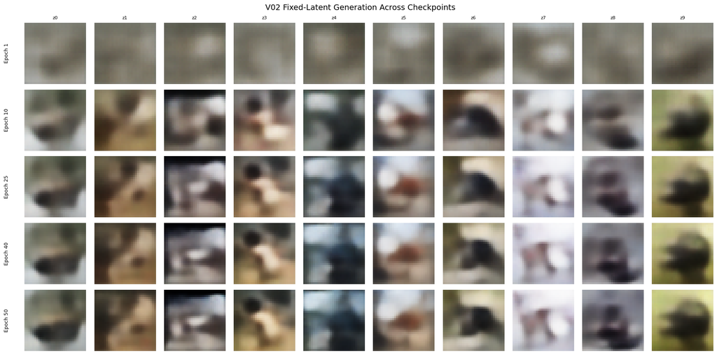

```
V02 checkpoint metrics saved to: artifacts\vae\V02\evaluation\V02_checkpoint_metrics.csv
V02 checkpoint grid saved to: artifacts\vae\V02\evaluation\V02_checkpoint_generation_grid.png
Official test-set usage: None
```

```python
# Evaluate V02 checkpoints using the established fixed inputs.
v02_artifact_dir = (
    Path("artifacts") / "vae" / "V02"
)
v02_evaluation_dir = (
    v02_artifact_dir / "evaluation"
)
v02_evaluation_dir.mkdir(
    parents=True,
    exist_ok=True
)

fixed_inputs_dir = (
    Path("artifacts")
    / "vae"
    / "fixed_inputs"
)
fixed_latent_path = (
    fixed_inputs_dir
    / f"fixed_latent_vectors_dim{V02_LATENT_DIM}.npy"
)
fixed_indices_path = (
    fixed_inputs_dir
    / "fixed_reconstruction_indices.npy"
)
v02_history_path = (
    v02_artifact_dir
    / "V02_training_history.csv"
)
v02_final_vae_weights_path = (
    v02_artifact_dir
    / "weights"
    / "V02_vae_final.weights.h5"
)

for required_path in [
    fixed_latent_path,
    fixed_indices_path,
    v02_history_path,
    v02_final_vae_weights_path
]:
    assert required_path.exists(), (
        f"Required artefact not found: "
        f"{required_path}"
    )

fixed_latent_vectors = np.load(
    fixed_latent_path
)
fixed_reconstruction_indices = np.load(
    fixed_indices_path
)
fixed_reconstruction_images = x_train_vae[
    fixed_reconstruction_indices
]
fixed_reconstruction_labels = y_train[
    fixed_reconstruction_indices
]

v02_checkpoint_epochs = [
    1,
    10,
    25,
    40,
    50
]
v02_history_for_evaluation = pd.read_csv(
    v02_history_path,
    index_col="epoch"
)

v02_checkpoint_records = []
v02_checkpoint_generated = {}

for checkpoint_epoch in (
    v02_checkpoint_epochs
):
    checkpoint_path = (
        v02_artifact_dir
        / "checkpoints"
        / (
            "V02_epoch_"
            f"{checkpoint_epoch:03d}"
            ".weights.h5"
        )
    )
    assert checkpoint_path.exists(), (
        f"V02 checkpoint not found: "
        f"{checkpoint_path}"
    )

    vae_v02.load_weights(
        str(checkpoint_path)
    )

    (
        checkpoint_z_mean,
        _,
        _
    ) = encoder_v02.predict(
        fixed_reconstruction_images,
        verbose=0
    )
    checkpoint_reconstructions = (
        decoder_v02.predict(
            checkpoint_z_mean,
            verbose=0
        )
    )
    checkpoint_reconstructions = np.clip(
        checkpoint_reconstructions,
        0.0,
        1.0
    )

    mse_per_image = np.mean(
        np.square(
            fixed_reconstruction_images
            - checkpoint_reconstructions
        ),
        axis=(1, 2, 3)
    )
    mae_per_image = np.mean(
        np.abs(
            fixed_reconstruction_images
            - checkpoint_reconstructions
        ),
        axis=(1, 2, 3)
    )
    psnr_per_image = tf.image.psnr(
        fixed_reconstruction_images,
        checkpoint_reconstructions,
        max_val=1.0
    ).numpy()

    fixed_generation = (
        decoder_v02.predict(
            fixed_latent_vectors[:10],
            verbose=0
        )
    )
    v02_checkpoint_generated[
        checkpoint_epoch
    ] = np.clip(
        fixed_generation,
        0.0,
        1.0
    )

    v02_checkpoint_records.append({
        "epoch": checkpoint_epoch,
        "training_reconstruction_loss": (
            v02_history_for_evaluation.loc[
                checkpoint_epoch,
                "reconstruction_loss"
            ]
        ),
        "unweighted_kl_loss": (
            v02_history_for_evaluation.loc[
                checkpoint_epoch,
                "kl_loss"
            ]
        ),
        "reconstruction_mse": (
            mse_per_image.mean()
        ),
        "reconstruction_mae": (
            mae_per_image.mean()
        ),
        "reconstruction_psnr_db": (
            psnr_per_image.mean()
        )
    })

vae_v02.load_weights(
    str(v02_final_vae_weights_path)
)

v02_checkpoint_metrics_df = (
    pd.DataFrame(
        v02_checkpoint_records
    ).set_index("epoch")
)

v02_checkpoint_metrics_path = (
    v02_evaluation_dir
    / "V02_checkpoint_metrics.csv"
)
v02_checkpoint_metrics_df.to_csv(
    v02_checkpoint_metrics_path
)

print(
    "V02 fixed-input checkpoint metrics:"
)
display(
    v02_checkpoint_metrics_df.round(5)
)

fig, axes = plt.subplots(
    nrows=len(v02_checkpoint_epochs),
    ncols=10,
    figsize=(18, 9)
)

for row_index, checkpoint_epoch in enumerate(
    v02_checkpoint_epochs
):
    checkpoint_images = (
        v02_checkpoint_generated[
            checkpoint_epoch
        ]
    )

    for column_index in range(10):
        axes[
            row_index,
            column_index
        ].imshow(
            checkpoint_images[
                column_index
            ]
        )
        axes[
            row_index,
            column_index
        ].axis("off")

        if row_index == 0:
            axes[
                row_index,
                column_index
            ].set_title(
                f"z{column_index}",
                fontsize=8
            )

    axes[row_index, 0].text(
        -0.25,
        0.5,
        f"Epoch {checkpoint_epoch}",
        transform=axes[
            row_index,
            0
        ].transAxes,
        rotation=90,
        va="center",
        ha="right",
        fontsize=9
    )

fig.suptitle(
    "V02 Fixed-Latent Generation Across Checkpoints",
    fontsize=14
)
plt.tight_layout()

v02_checkpoint_grid_path = (
    v02_evaluation_dir
    / "V02_checkpoint_generation_grid.png"
)
plt.savefig(
    v02_checkpoint_grid_path,
    dpi=150,
    bbox_inches="tight"
)
plt.show()

print(
    "V02 checkpoint metrics saved to: "
    f"{v02_checkpoint_metrics_path}"
)
print(
    "V02 checkpoint grid saved to: "
    f"{v02_checkpoint_grid_path}"
)
print(
    "Official test-set usage: None"
)
```

### 7.6 Final Controlled Comparison - V01 versus V02

V01 and V02 are compared using identical reconstruction images and the same metric definitions. The reconstruction path is directly comparable because both models encode the same inputs and decode their posterior means.

Prior generation requires one important qualification. V01 expects 64-dimensional vectors, whereas V02 expects 128-dimensional vectors, so a mathematically identical latent vector cannot be supplied to both. For reproducibility, the first 64 dimensions of each V02 draw equal the corresponding complete V01 draw; V02 then receives 64 additional seeded standard-normal values. Rows paired by draw index are therefore **aligned fixed draws**, not evidence that both latent spaces assign the same semantics to a coordinate.

The comparison includes:

- overall and per-class deterministic reconstruction metrics;
- original/V01/V02 reconstruction grids;
- aligned fixed-prior generation grids;
- low-level descriptor and diversity comparisons;
- total and per-dimension latent KL diagnostics; and
- active latent-unit counts using variance of posterior means greater than 0.01 as a transparent supplementary threshold.

The final decision will balance image quality, diversity, latent usage, and the 16% parameter cost. It will not be based on training reconstruction loss alone.

```python
# -------------------------------------------------------
# 1. Reload both final models and fixed evaluation inputs
# -------------------------------------------------------
v01_artifact_dir = (
    Path("artifacts") / "vae" / "V01"
)
v01_final_weights_path = (
    v01_artifact_dir
    / "weights"
    / "V01_vae_final.weights.h5"
)
v02_final_weights_path = (
    v02_artifact_dir
    / "weights"
    / "V02_vae_final.weights.h5"
)

assert v01_final_weights_path.exists()
assert v02_final_weights_path.exists()

vae_v01.load_weights(
    str(v01_final_weights_path)
)
vae_v02.load_weights(
    str(v02_final_weights_path)
)

# -------------------------------------------------------
# 2. Deterministic reconstruction comparison
# -------------------------------------------------------
(
    v01_z_mean_fixed,
    _,
    _
) = encoder_v01.predict(
    fixed_reconstruction_images,
    verbose=0
)
(
    v02_z_mean_fixed,
    _,
    _
) = encoder_v02.predict(
    fixed_reconstruction_images,
    verbose=0
)

v01_reconstructions = np.clip(
    decoder_v01.predict(
        v01_z_mean_fixed,
        verbose=0
    ),
    0.0,
    1.0
)
v02_reconstructions = np.clip(
    decoder_v02.predict(
        v02_z_mean_fixed,
        verbose=0
    ),
    0.0,
    1.0
)


def reconstruction_metric_arrays(
    originals,
    reconstructions
):
    mse_values = np.mean(
        np.square(
            originals
            - reconstructions
        ),
        axis=(1, 2, 3)
    )
    mae_values = np.mean(
        np.abs(
            originals
            - reconstructions
        ),
        axis=(1, 2, 3)
    )
    psnr_values = tf.image.psnr(
        originals,
        reconstructions,
        max_val=1.0
    ).numpy()

    return (
        mse_values,
        mae_values,
        psnr_values
    )


(
    v01_mse,
    v01_mae,
    v01_psnr
) = reconstruction_metric_arrays(
    fixed_reconstruction_images,
    v01_reconstructions
)
(
    v02_mse,
    v02_mae,
    v02_psnr
) = reconstruction_metric_arrays(
    fixed_reconstruction_images,
    v02_reconstructions
)

overall_reconstruction_comparison = (
    pd.DataFrame(
        {
            "V01_latent_64": [
                v01_mse.mean(),
                v01_mae.mean(),
                v01_psnr.mean()
            ],
            "V02_latent_128": [
                v02_mse.mean(),
                v02_mae.mean(),
                v02_psnr.mean()
            ]
        },
        index=[
            "mse_lower_is_better",
            "mae_lower_is_better",
            "psnr_db_higher_is_better"
        ]
    )
)
overall_reconstruction_comparison[
    "V02_minus_V01"
] = (
    overall_reconstruction_comparison[
        "V02_latent_128"
    ]
    - overall_reconstruction_comparison[
        "V01_latent_64"
    ]
)

print(
    "Overall fixed-sample reconstruction "
    "comparison:"
)
display(
    overall_reconstruction_comparison.round(
        6
    )
)

per_class_records = []

for class_id, class_name in enumerate(
    class_names
):
    class_mask = (
        fixed_reconstruction_labels
        == class_id
    )

    per_class_records.append({
        "class_name": class_name,
        "V01_mse": (
            v01_mse[class_mask].mean()
        ),
        "V02_mse": (
            v02_mse[class_mask].mean()
        ),
        "mse_change_V02_minus_V01": (
            v02_mse[class_mask].mean()
            - v01_mse[class_mask].mean()
        ),
        "V01_psnr_db": (
            v01_psnr[class_mask].mean()
        ),
        "V02_psnr_db": (
            v02_psnr[class_mask].mean()
        ),
        "psnr_change_V02_minus_V01": (
            v02_psnr[class_mask].mean()
            - v01_psnr[class_mask].mean()
        )
    })

per_class_comparison_df = pd.DataFrame(
    per_class_records
).set_index("class_name")

print(
    "\nPer-class fixed-sample comparison "
    "(two images per class):"
)
display(
    per_class_comparison_df.round(6)
)

comparison_metrics_path = (
    v02_evaluation_dir
    / "V01_V02_reconstruction_comparison.csv"
)
per_class_comparison_df.to_csv(
    comparison_metrics_path
)

fig, axes = plt.subplots(
    nrows=6,
    ncols=len(class_names),
    figsize=(18, 11)
)

row_labels = [
    "Original 1",
    "V01 1",
    "V02 1",
    "Original 2",
    "V01 2",
    "V02 2"
]

for class_id, class_name in enumerate(
    class_names
):
    first_position = class_id * 2
    second_position = (
        first_position + 1
    )

    image_sequence = [
        fixed_reconstruction_images[
            first_position
        ],
        v01_reconstructions[
            first_position
        ],
        v02_reconstructions[
            first_position
        ],
        fixed_reconstruction_images[
            second_position
        ],
        v01_reconstructions[
            second_position
        ],
        v02_reconstructions[
            second_position
        ]
    ]

    for row_index, image_value in enumerate(
        image_sequence
    ):
        axes[
            row_index,
            class_id
        ].imshow(image_value)
        axes[
            row_index,
            class_id
        ].axis("off")

        if class_id == 0:
            axes[
                row_index,
                class_id
            ].text(
                -0.2,
                0.5,
                row_labels[row_index],
                transform=axes[
                    row_index,
                    class_id
                ].transAxes,
                rotation=90,
                va="center",
                ha="right",
                fontsize=9
            )

    axes[0, class_id].set_title(
        class_name,
        fontsize=9
    )

fig.suptitle(
    "Fixed Reconstructions: V01 versus V02",
    fontsize=14
)
plt.tight_layout()

reconstruction_comparison_grid_path = (
    v02_evaluation_dir
    / "V01_V02_reconstruction_grid.png"
)
plt.savefig(
    reconstruction_comparison_grid_path,
    dpi=150,
    bbox_inches="tight"
)
plt.show()

# -------------------------------------------------------
# 3. Aligned fixed-prior generation and descriptor comparison
# -------------------------------------------------------
fixed_latent_vectors_v01 = np.load(
    fixed_inputs_dir
    / "fixed_latent_vectors_dim64.npy"
).astype(np.float32)
fixed_latent_vectors_v02 = np.load(
    fixed_inputs_dir
    / "fixed_latent_vectors_dim128.npy"
).astype(np.float32)
```

```python
assert fixed_latent_vectors_v01.shape == (100, 64)
assert fixed_latent_vectors_v02.shape == (100, 128)
assert np.allclose(
    fixed_latent_vectors_v01,
    fixed_latent_vectors_v02[:, :64]
)

v01_generated_float = np.clip(
    decoder_v01.predict(
        fixed_latent_vectors_v01,
        verbose=0
    ),
    0.0,
    1.0
)
v02_generated_float = np.clip(
    decoder_v02.predict(
        fixed_latent_vectors_v02,
        verbose=0
    ),
    0.0,
    1.0
)

v01_generated_uint8 = np.rint(
    v01_generated_float * 255.0
).astype(np.uint8)
v02_generated_uint8 = np.rint(
    v02_generated_float * 255.0
).astype(np.uint8)

np.save(
    v02_evaluation_dir
    / "V02_fixed_generated_samples.npy",
    v02_generated_uint8
)

fig, axes = plt.subplots(
    nrows=4,
    ncols=10,
    figsize=(18, 8)
)

for column_index in range(10):
    paired_images = [
        v01_generated_float[
            column_index
        ],
        v02_generated_float[
            column_index
        ],
        v01_generated_float[
            column_index + 10
        ],
        v02_generated_float[
            column_index + 10
        ]
    ]
    paired_labels = [
        "V01",
        "V02",
        "V01",
        "V02"
    ]

    for row_index, image_value in enumerate(
        paired_images
    ):
        axes[
            row_index,
            column_index
        ].imshow(image_value)
        axes[
            row_index,
            column_index
        ].axis("off")

        if column_index == 0:
            axes[
                row_index,
                column_index
            ].text(
                -0.2,
                0.5,
                paired_labels[row_index],
                transform=axes[
                    row_index,
                    column_index
                ].transAxes,
                rotation=90,
                va="center",
                ha="right",
                fontsize=9
            )

    axes[0, column_index].set_title(
        f"draw {column_index}",
        fontsize=8
    )
    axes[2, column_index].set_title(
        f"draw {column_index + 10}",
        fontsize=8
    )

fig.suptitle(
    "Aligned Fixed Prior Draws: V01 versus V02",
    fontsize=14
)
plt.tight_layout()

paired_generation_grid_path = (
    v02_evaluation_dir
    / "V01_V02_aligned_draw_generation_grid.png"
)
plt.savefig(
    paired_generation_grid_path,
    dpi=150,
    bbox_inches="tight"
)
plt.show()

fig, axes = plt.subplots(
    nrows=10,
    ncols=10,
    figsize=(14, 14)
)

for sample_index, axis in enumerate(
    axes.flat
):
    axis.imshow(
        v02_generated_float[
            sample_index
        ]
    )
    axis.set_title(
        f"{sample_index:02d}",
        fontsize=7
    )
    axis.axis("off")

fig.suptitle(
    "V02 Final Generations from "
    "100 Fixed Latent Vectors",
    fontsize=14
)
plt.tight_layout()

v02_generation_grid_path = (
    v02_evaluation_dir
    / "V02_final_generation_grid.png"
)
plt.savefig(
    v02_generation_grid_path,
    dpi=150,
    bbox_inches="tight"
)
plt.show()

descriptor_rng = np.random.default_rng(
    SEED + 100
)
reference_indices = []

for class_id in range(
    len(class_names)
):
    class_indices = np.where(
        y_train == class_id
    )[0]
    selected_indices = (
        descriptor_rng.choice(
            class_indices,
            size=100,
            replace=False
        )
    )
    reference_indices.extend(
        selected_indices
    )

reference_indices = np.array(
    reference_indices,
    dtype=np.int64
)
reference_images = x_train_vae[
    reference_indices
]


def calculate_comparison_descriptors(
    image_batch
):
    image_batch = image_batch.astype(
        np.float32
    )

    horizontal_difference = np.abs(
        np.diff(
            image_batch,
            axis=2
        )
    ).mean(axis=(1, 2, 3))
    vertical_difference = np.abs(
        np.diff(
            image_batch,
            axis=1
        )
    ).mean(axis=(1, 2, 3))

    return pd.DataFrame({
        "brightness": image_batch.mean(
            axis=(1, 2, 3)
        ),
        "contrast": image_batch.std(
            axis=(1, 2, 3)
        ),
        "red_mean": image_batch[
            :, :, :, 0
        ].mean(axis=(1, 2)),
        "green_mean": image_batch[
            :, :, :, 1
        ].mean(axis=(1, 2)),
        "blue_mean": image_batch[
            :, :, :, 2
        ].mean(axis=(1, 2)),
        "saturation": (
            image_batch.max(axis=3)
            - image_batch.min(axis=3)
        ).mean(axis=(1, 2)),
        "edge_strength": (
            horizontal_difference
            + vertical_difference
        ) / 2.0
    })


reference_descriptors = (
    calculate_comparison_descriptors(
        reference_images
    )
)
v01_descriptors = (
    calculate_comparison_descriptors(
        v01_generated_float
    )
)
v02_descriptors = (
    calculate_comparison_descriptors(
        v02_generated_float
    )
)

descriptor_records = []

for descriptor_name in (
    reference_descriptors.columns
):
    training_mean = (
        reference_descriptors[
            descriptor_name
        ].mean()
    )
    v01_mean = v01_descriptors[
        descriptor_name
    ].mean()
    v02_mean = v02_descriptors[
        descriptor_name
    ].mean()

    v01_gap = abs(
        v01_mean - training_mean
    )
    v02_gap = abs(
        v02_mean - training_mean
    )

    descriptor_records.append({
        "descriptor": descriptor_name,
        "training_mean": training_mean,
        "V01_mean": v01_mean,
        "V02_mean": v02_mean,
        "V01_absolute_gap": v01_gap,
        "V02_absolute_gap": v02_gap,
        "gap_reduction_V02": (
            v01_gap - v02_gap
        )
    })

descriptor_comparison_df = pd.DataFrame(
    descriptor_records
).set_index("descriptor")

print(
    "\nGenerated descriptor comparison:"
)
display(
    descriptor_comparison_df.round(6)
)

descriptor_comparison_path = (
    v02_evaluation_dir
    / "V01_V02_descriptor_comparison.csv"
)
descriptor_comparison_df.to_csv(
    descriptor_comparison_path
)
```

```
Overall fixed-sample reconstruction comparison:
```

|  | V01_latent_64 | V02_latent_128 | V02_minus_V01 |
| --- | --- | --- | --- |
| mse_lower_is_better | 0.007829 | 0.007450 | -0.000379 |
| mae_lower_is_better | 0.064010 | 0.062135 | -0.001875 |
| psnr_db_higher_is_better | 21.660751 | 21.850985 | 0.190233 |

```
Per-class fixed-sample comparison (two images per class):
```

| class_name | V01_mse | V02_mse | mse_change_V02_minus_V01 | V01_psnr_db | V02_psnr_db | psnr_change_V02_minus_V01 |
| --- | --- | --- | --- | --- | --- | --- |
| Airplane | 0.010242 | 0.009670 | -0.000572 | 22.567642 | 22.690769 | 0.123127 |
| Automobile | 0.007941 | 0.007446 | -0.000495 | 21.266832 | 21.543003 | 0.276171 |
| Bird | 0.006266 | 0.006018 | -0.000248 | 22.155918 | 22.361164 | 0.205246 |
| Cat | 0.008010 | 0.007866 | -0.000145 | 20.974152 | 21.060076 | 0.085924 |
| Deer | 0.009972 | 0.009694 | -0.000278 | 20.474890 | 20.567579 | 0.092690 |
| Dog | 0.007605 | 0.007400 | -0.000205 | 21.218964 | 21.342201 | 0.123238 |
| Frog | 0.008705 | 0.008107 | -0.000599 | 20.632393 | 20.922760 | 0.290367 |
| Horse | 0.008831 | 0.008067 | -0.000764 | 20.672443 | 21.068092 | 0.395649 |
| Ship | 0.003515 | 0.003409 | -0.000107 | 25.020599 | 25.138149 | 0.117550 |
| Truck | 0.007199 | 0.006822 | -0.000377 | 21.623674 | 21.816055 | 0.192381 |

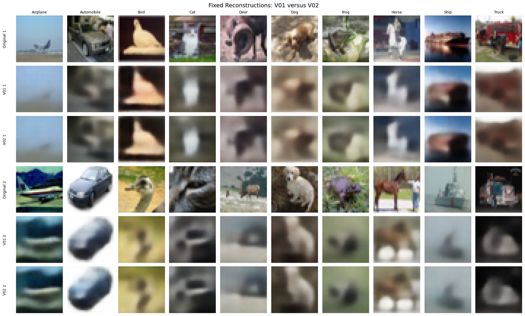

[figure not shown]

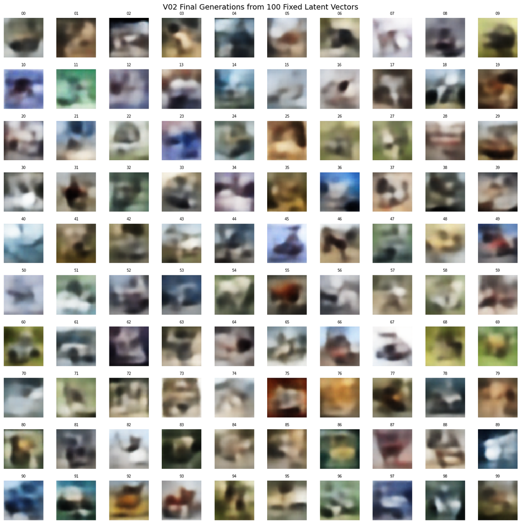

```
Generated descriptor comparison:
```

| descriptor | training_mean | V01_mean | V02_mean | V01_absolute_gap | V02_absolute_gap | gap_reduction_V02 |
| --- | --- | --- | --- | --- | --- | --- |
| brightness | 0.473055 | 0.491670 | 0.467640 | 0.018615 | 0.005415 | 0.013200 |
| contrast | 0.213141 | 0.187481 | 0.178486 | 0.025660 | 0.034655 | -0.008995 |
| red_mean | 0.489844 | 0.518268 | 0.484860 | 0.028424 | 0.004983 | 0.023441 |
| green_mean | 0.482936 | 0.496388 | 0.477380 | 0.013453 | 0.005556 | 0.007896 |
| blue_mean | 0.446386 | 0.460354 | 0.440679 | 0.013968 | 0.005706 | 0.008262 |
| saturation | 0.129711 | 0.109810 | 0.114101 | 0.019901 | 0.015610 | 0.004291 |
| edge_strength | 0.058002 | 0.030020 | 0.029195 | 0.027982 | 0.028808 | -0.000826 |

```
Generated diversity comparison:
```

|  | V01 | V02 | Training_reference |
| --- | --- | --- | --- |
| unique_uint8_images_out_of_100 | 100.000000 | 100.0000 | NaN |
| mean_pixel_standard_deviation | 0.212463 | 0.2052 | 0.249836 |

```
Latent posterior comparison (1,000 training-reference images):
```

| model | latent_dimension | mean_unweighted_kl | mean_kl_per_dimension | mean_absolute_z_mean | mean_posterior_std | mean_variance_of_z_mean_dims | active_units_variance_gt_0.01 | active_unit_fraction |
| --- | --- | --- | --- | --- | --- | --- | --- | --- |
| V01_latent_64 | 64 | 62.324078 | 0.973814 | 0.604584 | 0.475810 | 0.707226 | 62 | 0.968750 |
| V02_latent_128 | 128 | 64.463303 | 0.503620 | 0.394492 | 0.714489 | 0.394095 | 122 | 0.953125 |

```
Controlled V01-versus-V02 summary:
```

|  | V01_latent_64 | V02_latent_128 |
| --- | --- | --- |
| latent_dimension | 6.400000e+01 | 1.280000e+02 |
| encoder_plus_decoder_parameters | 1.024515e+06 | 1.188483e+06 |
| fixed_reconstruction_mse | 7.829000e-03 | 7.450000e-03 |
| fixed_reconstruction_mae | 6.401000e-02 | 6.213500e-02 |
| fixed_reconstruction_psnr_db | 2.166075e+01 | 2.185099e+01 |
| unique_uint8_images_out_of_100 | 1.000000e+02 | 1.000000e+02 |
| mean_pixel_standard_deviation | 2.124630e-01 | 2.052000e-01 |
| mean_unweighted_kl | 6.232408e+01 | 6.446330e+01 |
| mean_kl_per_dimension | 9.738140e-01 | 5.036200e-01 |
| active_unit_fraction | 9.687500e-01 | 9.531250e-01 |

```
Saved comparison artefacts:
- artifacts\vae\V02\evaluation\V01_V02_reconstruction_comparison.csv
- artifacts\vae\V02\evaluation\V01_V02_reconstruction_grid.png
- artifacts\vae\V02\evaluation\V01_V02_aligned_draw_generation_grid.png
- artifacts\vae\V02\evaluation\V02_final_generation_grid.png
- artifacts\vae\V02\evaluation\V01_V02_descriptor_comparison.csv
- artifacts\vae\V02\evaluation\V01_V02_latent_diagnostics.csv
- artifacts\vae\V02\evaluation\V01_V02_controlled_summary.csv
Official test-set usage: None
```

```python
diversity_comparison_df = pd.DataFrame(
    {
        "V01": [
            len(
                np.unique(
                    v01_generated_uint8.reshape(
                        100,
                        -1
                    ),
                    axis=0
                )
            ),
            np.mean(
                np.std(
                    v01_generated_float,
                    axis=0
                )
            )
        ],
        "V02": [
            len(
                np.unique(
                    v02_generated_uint8.reshape(
                        100,
                        -1
                    ),
                    axis=0
                )
            ),
            np.mean(
                np.std(
                    v02_generated_float,
                    axis=0
                )
            )
        ],
        "Training_reference": [
            np.nan,
            np.mean(
                np.std(
                    reference_images,
                    axis=0
                )
            )
        ]
    },
    index=[
        "unique_uint8_images_out_of_100",
        "mean_pixel_standard_deviation"
    ]
)

print(
    "\nGenerated diversity comparison:"
)
display(
    diversity_comparison_df.round(6)
)

# -------------------------------------------------------
# 4. Latent posterior diagnostics on the same reference
# -------------------------------------------------------
(
    v01_reference_mean,
    v01_reference_log_var,
    _
) = encoder_v01.predict(
    reference_images,
    verbose=0
)
(
    v02_reference_mean,
    v02_reference_log_var,
    _
) = encoder_v02.predict(
    reference_images,
    verbose=0
)


def latent_diagnostic_record(
    model_name,
    z_mean_values,
    z_log_var_values
):
    kl_by_image_and_dimension = -0.5 * (
        1.0
        + z_log_var_values
        - np.square(z_mean_values)
        - np.exp(z_log_var_values)
    )
    kl_per_image = np.sum(
        kl_by_image_and_dimension,
        axis=1
    )
    variance_by_dimension = np.var(
        z_mean_values,
        axis=0
    )
    active_unit_threshold = 0.01

    return {
        "model": model_name,
        "latent_dimension": z_mean_values.shape[1],
        "mean_unweighted_kl": kl_per_image.mean(),
        "mean_kl_per_dimension": (
            kl_by_image_and_dimension.mean()
        ),
        "mean_absolute_z_mean": (
            np.abs(z_mean_values).mean()
        ),
        "mean_posterior_std": (
            np.exp(0.5 * z_log_var_values).mean()
        ),
        "mean_variance_of_z_mean_dims": (
            variance_by_dimension.mean()
        ),
        "active_units_variance_gt_0.01": int(
            np.sum(
                variance_by_dimension
                > active_unit_threshold
            )
        ),
        "active_unit_fraction": np.mean(
            variance_by_dimension
            > active_unit_threshold
        )
    }


latent_diagnostics_df = pd.DataFrame([
    latent_diagnostic_record(
        "V01_latent_64",
        v01_reference_mean,
        v01_reference_log_var
    ),
    latent_diagnostic_record(
        "V02_latent_128",
        v02_reference_mean,
        v02_reference_log_var
    )
]).set_index("model")

print(
    "\nLatent posterior comparison "
    "(1,000 training-reference images):"
)
display(
    latent_diagnostics_df.round(6)
)

latent_diagnostics_path = (
    v02_evaluation_dir
    / "V01_V02_latent_diagnostics.csv"
)
latent_diagnostics_df.to_csv(
    latent_diagnostics_path
)

controlled_summary_df = pd.DataFrame(
    {
        "V01_latent_64": [
            64,
            (
                encoder_v01.count_params()
                + decoder_v01.count_params()
            ),
            v01_mse.mean(),
            v01_mae.mean(),
            v01_psnr.mean(),
            len(
                np.unique(
                    v01_generated_uint8.reshape(100, -1),
                    axis=0
                )
            ),
            np.mean(
                np.std(v01_generated_float, axis=0)
            ),
            latent_diagnostics_df.loc[
                "V01_latent_64",
                "mean_unweighted_kl"
            ],
            latent_diagnostics_df.loc[
                "V01_latent_64",
                "mean_kl_per_dimension"
            ],
            latent_diagnostics_df.loc[
                "V01_latent_64",
                "active_unit_fraction"
            ]
        ],
        "V02_latent_128": [
            128,
            (
                encoder_v02.count_params()
                + decoder_v02.count_params()
            ),
            v02_mse.mean(),
            v02_mae.mean(),
            v02_psnr.mean(),
            len(
                np.unique(
                    v02_generated_uint8.reshape(100, -1),
                    axis=0
                )
            ),
            np.mean(
                np.std(v02_generated_float, axis=0)
            ),
            latent_diagnostics_df.loc[
                "V02_latent_128",
                "mean_unweighted_kl"
            ],
            latent_diagnostics_df.loc[
                "V02_latent_128",
                "mean_kl_per_dimension"
            ],
            latent_diagnostics_df.loc[
                "V02_latent_128",
                "active_unit_fraction"
            ]
        ]
    },
    index=[
        "latent_dimension",
        "encoder_plus_decoder_parameters",
        "fixed_reconstruction_mse",
        "fixed_reconstruction_mae",
        "fixed_reconstruction_psnr_db",
        "unique_uint8_images_out_of_100",
        "mean_pixel_standard_deviation",
        "mean_unweighted_kl",
        "mean_kl_per_dimension",
        "active_unit_fraction"
    ]
)

print("\nControlled V01-versus-V02 summary:")
display(controlled_summary_df.round(6))

controlled_summary_path = (
    v02_evaluation_dir
    / "V01_V02_controlled_summary.csv"
)
controlled_summary_df.to_csv(controlled_summary_path)

print(
    "\nSaved comparison artefacts:"
)
print(
    f"- {comparison_metrics_path}"
)
print(
    f"- {reconstruction_comparison_grid_path}"
)
print(
    f"- {paired_generation_grid_path}"
)
print(
    f"- {v02_generation_grid_path}"
)
print(
    f"- {descriptor_comparison_path}"
)
print(
    f"- {latent_diagnostics_path}"
)
print(
    f"- {controlled_summary_path}"
)
print(
    "Official test-set usage: None"
)
```

### 7.7 V02 Development FID - Saved-Weight Three-Generation-Seed Evaluation

V02 uses the identical three-generation-seed protocol as the baseline and V01: the same saved decoder weights generate 5,000 images for each of seeds `1001`, `1002`, and `1003`, followed by the individual values, mean, standard deviation, minimum and maximum. The final saved decoder is rebuilt with latent dimension 128, while the extractor, real reference and numerical calculation remain unchanged.

The completed seed-1001 result is reused after validation; only seeds 1002 and 1003 are missing. The final interpretation will combine FID mean and variability with V02's reconstruction gain, parameter cost, descriptors, edge strength, diversity and visual evidence.

```python
assert (
    "evaluate_saved_unconditional_vae_fid"
    in globals()
), (
    "Run the updated V01 FID cell first "
    "to restore the locked three-generation-seed "
    "unconditional FID helper."
)

v02_inline_fid_weights_path = (
    Path("artifacts")
    / "vae"
    / "V02"
    / "weights"
    / "V02_decoder_final.weights.h5"
)
v02_single_fid_result_path = (
    Path("artifacts")
    / "vae"
    / "V02"
    / "evaluation"
    / "V02_development_fid.csv"
)
v02_repeated_fid_result_path = (
    Path("artifacts")
    / "vae"
    / "V02"
    / "evaluation"
    / "V02_repeated_development_fid.csv"
)
v02_fid_summary_path = (
    Path("artifacts")
    / "vae"
    / "V02"
    / "evaluation"
    / "V02_development_fid_summary.csv"
)

(
    v02_repeated_fid_df,
    v02_fid_summary_df,
    v02_inline_fid_decoder
) = evaluate_saved_unconditional_vae_fid(
    experiment_id="V02",
    latent_dim=128,
    decoder_weights_path=(
        v02_inline_fid_weights_path
    ),
    single_result_path=(
        v02_single_fid_result_path
    ),
    repeated_result_path=(
        v02_repeated_fid_result_path
    ),
    summary_path=v02_fid_summary_path
)

print(
    "\nV02 repeated development-FID "
    "results:"
)
display(
    v02_repeated_fid_df.round(4)
)
print(
    "\nV02 FID summary "
    "(lower is better):"
)
display(
    v02_fid_summary_df.round(4)
)
print(
    "Repeated results saved to: "
    f"{v02_repeated_fid_result_path}"
)
print(
    "Summary saved to: "
    f"{v02_fid_summary_path}"
)
print("V02 retrained: No")
print("Official test-set usage: None")
```

```
Reusing validated V02 seed 1001 FID: 156.1888

Calculating V02 FID for seed 1002
```

```
V02 seed 1002 FID: 155.6830

Calculating V02 FID for seed 1003
```

```
V02 seed 1003 FID: 155.8390

V02 repeated development-FID results:
```

|  | experiment_id | checkpoint_epoch | seed | generated_sample_count | real_reference_count | fid | score_role | score_source | test_set_used |
| --- | --- | --- | --- | --- | --- | --- | --- | --- | --- |
| 0 | V02 | 50 | 1001 | 5000 | 50000 | 156.1888 | three_seed_formal_comparison | reused_validated_single_seed_result | False |
| 1 | V02 | 50 | 1002 | 5000 | 50000 | 155.6830 | three_seed_formal_comparison | calculated_in_experiment | False |
| 2 | V02 | 50 | 1003 | 5000 | 50000 | 155.8390 | three_seed_formal_comparison | calculated_in_experiment | False |

```
V02 FID summary (lower is better):
```

|  | experiment_id | fid_mean | fid_std | fid_min | fid_max | repeat_count |
| --- | --- | --- | --- | --- | --- | --- |
| 0 | V02 | 155.9036 | 0.259 | 155.683 | 156.1888 | 3 |

```
Repeated results saved to: artifacts\vae\V02\evaluation\V02_repeated_development_fid.csv
Summary saved to: artifacts\vae\V02\evaluation\V02_development_fid_summary.csv
V02 retrained: No
Official test-set usage: None
```

### 7.8 V02 Decision - Rejected; V01 Retained as Unconditional Incumbent

V02 is a valid, stable model, but the 128-dimensional latent vector does not provide a strong enough overall benefit to replace V01.

#### Reconstruction Benefit

On the same 20 fixed images, V02 reduced MSE from 0.007829 to 0.007450 (4.84%) and MAE from 0.064010 to 0.062135 (2.93%), while PSNR increased by 0.190 dB. Every represented CIFAR-10 class improved in both MSE and PSNR. However, the reconstruction grid shows only subtle differences between V01 and V02; both remain strongly smoothed and lose fine texture. The gain is therefore consistent but visually modest.

#### Generation and Efficiency Trade-Off

V02 required 1,188,483 encoder-plus-decoder parameters, 16.00% more than V01. Both models produced 100 unique uint8 samples, but V02's mean pixel diversity fell by 3.42%, from 0.21246 to 0.20520. Its contrast gap against the training reference became 35.05% larger and its edge-strength gap became 2.95% larger. The aligned-draw and 100-image grids support these statistics: V02 remains ambiguous and blurred, with no clear recognisability improvement and several samples appearing softer.

V02 did improve brightness, RGB channel means, and saturation matching. Its saturation gap fell by 21.56%. These improvements are useful, but broad colour statistics were not the main V01 weakness; low edge strength and uncertain object identity were.

#### Development-FID Finding

V02 achieved a three-generation-seed mean FID of **155.9036 ± 0.2590**, compared with **158.0648 ± 0.7426** for V01. Its mean is **1.37% lower**, and all three V02 scores were below the three V01 scores. This confirms a small distributional improvement that is consistent across the tested generation seeds; it does not establish repeatability across independent training runs. However, the gain is not considered alone: V02 required 16.00% more parameters, reduced pixel diversity, worsened the contrast and edge gaps, and produced no clear recognisability improvement in the matched grids. The FID result therefore strengthens V02's positive evidence but does not overturn its overall rejection.

#### Latent-Space Finding

V02 used 122 of 128 dimensions under the stated variance threshold, so there is no sign that most added dimensions collapsed. Nevertheless, mean KL per dimension fell by 48.28%, from 0.97381 to 0.50362. The larger representation spreads a similar total information budget across more dimensions rather than producing a proportionate quality improvement.

#### Decision

V02 is rejected as the family winner because its small reconstruction gain does not justify the parameter cost and weaker generation statistics. This negative result is retained because it demonstrates systematic improvement testing and prevents an unsupported assumption that a larger latent space must be better. V01 remains the unconditional incumbent: latent dimension 64, `β = 0.5`, and 1,024,515 encoder-plus-decoder parameters.

## 8. Conditional VAE Branch - V03

### 8.1 Motivation, Hypothesis, and Controlled Design

V00, V01, and V02 are unconditional VAEs. They can draw varied samples from a prior, but they cannot generate a specifically requested class because no class label enters the model. This is a direct limitation for producing a controlled, balanced set across all ten CIFAR-10 classes.

V03 is a conditional VAE (CVAE) based on the V01 incumbent. The wider CVAE framework conditions variational generation on known information [8]; in this implementation, the CIFAR-10 class label is the conditioning variable. A one-hot class vector is supplied to both paths:

- **Encoder:** convolutional image features are concatenated with the one-hot label before the dense latent heads. The approximate posterior therefore models `q(z | x, y)`.
- **Decoder:** the sampled latent vector is concatenated with the same label before image reconstruction. The generation model therefore represents `p(x | z, y)`.

Conditioning both paths is important. Supplying a label only to the decoder would make the generation path conditional while leaving the inference model unaware of the known class information.

**Hypothesis:** V03 will produce stronger class-related cues and allow ten balanced samples to be requested for each class. Giving the decoder the class identity may also let the latent vector focus more on within-class colour, pose, and background variation.

**Risks:** the decoder may ignore the label, or it may rely too strongly on the label and reduce within-class diversity. Conditional generation must therefore be evaluated for requested-class separation, quality, and diversity-not merely reconstruction loss.

| Factor | V01 unconditional incumbent | V03 conditional branch |
| --- | --- | --- |
| Main conceptual change | No class input | One-hot class input to encoder and decoder |
| Latent dimension | 64 | 64 |
| KL weight `β` | 0.5 | 0.5 |
| Convolution blocks | Same | Same |
| Reconstruction loss | BCE sum | BCE sum |
| Optimiser | Adam | Adam |
| Learning rate | 0.001 | 0.001 |
| Batch size | 128 | 128 |
| Epochs | 50 | 50 |
| Data augmentation | None | None |
| Training images | 50,000 | 50,000 |
| Test-set usage | None | None |
| Seed | 42 | 42 |

Concatenating ten label values necessarily adds weights to the encoder dense layer and decoder projection. This small parameter increase is a consequence of conditioning, not a separately tuned capacity change.

```python
# Build the V03 conditional VAE architecture.
V03_EXPERIMENT_ID = "V03"
V03_PARENT_EXPERIMENT = "V01"
V03_LATENT_DIM = V01_LATENT_DIM
V03_BETA = V01_BETA
V03_NUM_CLASSES = len(class_names)

assert V03_NUM_CLASSES == 10
assert V03_LATENT_DIM == 64
assert V03_BETA == 0.5

# One-hot labels are a transparent representation
# for the ten mutually exclusive CIFAR-10 classes.
y_train_one_hot_v03 = keras.utils.to_categorical(
    y_train,
    num_classes=V03_NUM_CLASSES
).astype(np.float32)

assert y_train_one_hot_v03.shape == (50000, 10)
assert y_train_one_hot_v03.dtype == np.float32
assert np.allclose(
    y_train_one_hot_v03.sum(axis=1),
    1.0
)

# Save balanced requested labels for later fixed
# conditional evaluation: ten draws per class.
fixed_inputs_dir = (
    Path("artifacts")
    / "vae"
    / "fixed_inputs"
)
fixed_inputs_dir.mkdir(parents=True, exist_ok=True)

fixed_latent_vectors_v03 = np.load(
    fixed_inputs_dir
    / "fixed_latent_vectors_dim64.npy"
).astype(np.float32)
fixed_conditional_label_ids_v03 = np.repeat(
    np.arange(V03_NUM_CLASSES, dtype=np.int64),
    repeats=10
)
fixed_conditional_labels_v03 = (
    keras.utils.to_categorical(
        fixed_conditional_label_ids_v03,
        num_classes=V03_NUM_CLASSES
    ).astype(np.float32)
)

assert fixed_latent_vectors_v03.shape == (100, 64)
assert fixed_conditional_label_ids_v03.shape == (100,)
assert fixed_conditional_labels_v03.shape == (100, 10)
assert np.array_equal(
    np.bincount(fixed_conditional_label_ids_v03),
    np.full(V03_NUM_CLASSES, 10)
)

v03_fixed_label_ids_path = (
    fixed_inputs_dir
    / "V03_fixed_conditional_label_ids.npy"
)
v03_fixed_one_hot_labels_path = (
    fixed_inputs_dir
    / "V03_fixed_conditional_one_hot_labels.npy"
)
np.save(
    v03_fixed_label_ids_path,
    fixed_conditional_label_ids_v03
)
np.save(
    v03_fixed_one_hot_labels_path,
    fixed_conditional_labels_v03
)

tf.keras.utils.set_random_seed(SEED)

# ----------------------------
# Conditional encoder q(z|x,y)
# ----------------------------
image_inputs_v03 = keras.Input(
    shape=INPUT_SHAPE,
    name="V03_encoder_image_input"
)
label_inputs_encoder_v03 = keras.Input(
    shape=(V03_NUM_CLASSES,),
    name="V03_encoder_label_input"
)

x_v03 = layers.Conv2D(
    32,
    kernel_size=3,
    strides=2,
    padding="same",
    activation="relu",
    name="V03_encoder_conv_1"
)(image_inputs_v03)
x_v03 = layers.Conv2D(
    64,
    kernel_size=3,
    strides=2,
    padding="same",
    activation="relu",
    name="V03_encoder_conv_2"
)(x_v03)
x_v03 = layers.Conv2D(
    128,
    kernel_size=3,
    strides=2,
    padding="same",
    activation="relu",
    name="V03_encoder_conv_3"
)(x_v03)
x_v03 = layers.Flatten(
    name="V03_encoder_flatten"
)(x_v03)
x_v03 = layers.Concatenate(
    name="V03_encoder_feature_label_concat"
)([x_v03, label_inputs_encoder_v03])
x_v03 = layers.Dense(
    256,
    activation="relu",
    name="V03_encoder_dense"
)(x_v03)

z_mean_v03 = layers.Dense(
    V03_LATENT_DIM,
    name="V03_z_mean"
)(x_v03)
z_log_var_v03 = layers.Dense(
    V03_LATENT_DIM,
    name="V03_z_log_var"
)(x_v03)
z_v03 = Sampling(
    name="V03_z_sampling"
)([z_mean_v03, z_log_var_v03])

encoder_v03 = keras.Model(
    inputs=[
        image_inputs_v03,
        label_inputs_encoder_v03
    ],
    outputs=[z_mean_v03, z_log_var_v03, z_v03],
    name="V03_conditional_encoder"
)

# ----------------------------
# Conditional decoder p(x|z,y)
# ----------------------------
latent_inputs_v03 = keras.Input(
    shape=(V03_LATENT_DIM,),
    name="V03_decoder_latent_input"
)
label_inputs_decoder_v03 = keras.Input(
    shape=(V03_NUM_CLASSES,),
    name="V03_decoder_label_input"
)
y_v03 = layers.Concatenate(
    name="V03_decoder_latent_label_concat"
)([latent_inputs_v03, label_inputs_decoder_v03])
y_v03 = layers.Dense(
    4 * 4 * 128,
    activation="relu",
    name="V03_decoder_dense"
)(y_v03)
y_v03 = layers.Reshape(
    (4, 4, 128),
    name="V03_decoder_reshape"
)(y_v03)
y_v03 = layers.Conv2DTranspose(
    128,
    kernel_size=3,
    strides=2,
    padding="same",
    activation="relu",
    name="V03_decoder_deconv_1"
)(y_v03)
y_v03 = layers.Conv2DTranspose(
    64,
    kernel_size=3,
    strides=2,
    padding="same",
    activation="relu",
    name="V03_decoder_deconv_2"
)(y_v03)
y_v03 = layers.Conv2DTranspose(
    32,
    kernel_size=3,
    strides=2,
    padding="same",
    activation="relu",
    name="V03_decoder_deconv_3"
)(y_v03)
decoder_outputs_v03 = layers.Conv2D(
    3,
    kernel_size=3,
    padding="same",
    activation="sigmoid",
    name="V03_decoder_output"
)(y_v03)

decoder_v03 = keras.Model(
    inputs=[
        latent_inputs_v03,
        label_inputs_decoder_v03
    ],
    outputs=decoder_outputs_v03,
    name="V03_conditional_decoder"
)

assert encoder_v03.count_params() == 653248
assert decoder_v03.count_params() == 394307

v01_total_parameters = (
    encoder_v01.count_params()
    + decoder_v01.count_params()
)
v03_total_parameters = (
    encoder_v03.count_params()
    + decoder_v03.count_params()
)
v03_parameter_increase_percent = (
    (v03_total_parameters - v01_total_parameters)
    / v01_total_parameters
    * 100.0
)

print(f"Experiment ID: {V03_EXPERIMENT_ID}")
print(f"Parent model: {V03_PARENT_EXPERIMENT}")
print("Main change: class conditioning added")
print(
    "Conditioning path: one-hot labels enter "
    "both encoder and decoder"
)
print(f"Latent dimension held constant: {V03_LATENT_DIM}")
print(f"Beta held constant: {V03_BETA}")
print(
    "V03 encoder parameters: "
    f"{encoder_v03.count_params():,}"
)
print(
    "V03 decoder parameters: "
    f"{decoder_v03.count_params():,}"
)
print(f"V03 total parameters: {v03_total_parameters:,}")
print(
    "Parameter increase versus V01: "
    f"{v03_parameter_increase_percent:.2f}%"
)
print(
    "Balanced fixed requested labels saved to:"
)
print(f"- {v03_fixed_label_ids_path}")
print(f"- {v03_fixed_one_hot_labels_path}")
print("Official test-set usage: None")

encoder_v03.summary()
decoder_v03.summary()
```

```
Experiment ID: V03
Parent model: V01
Main change: class conditioning added
Conditioning path: one-hot labels enter both encoder and decoder
Latent dimension held constant: 64
Beta held constant: 0.5
V03 encoder parameters: 653,248
V03 decoder parameters: 394,307
V03 total parameters: 1,047,555
Parameter increase versus V01: 2.25%
Balanced fixed requested labels saved to:
- artifacts\vae\fixed_inputs\V03_fixed_conditional_label_ids.npy
- artifacts\vae\fixed_inputs\V03_fixed_conditional_one_hot_labels.npy
Official test-set usage: None
Model: "V03_conditional_encoder"
__________________________________________________________________________________________________
 Layer (type)                   Output Shape         Param #     Connected to
==================================================================================================
 V03_encoder_image_input (Input  [(None, 32, 32, 3)]  0          []
 Layer)

 V03_encoder_conv_1 (Conv2D)    (None, 16, 16, 32)   896         ['V03_encoder_image_input[0][0]']

 V03_encoder_conv_2 (Conv2D)    (None, 8, 8, 64)     18496       ['V03_encoder_conv_1[0][0]']

 V03_encoder_conv_3 (Conv2D)    (None, 4, 4, 128)    73856       ['V03_encoder_conv_2[0][0]']

 V03_encoder_flatten (Flatten)  (None, 2048)         0           ['V03_encoder_conv_3[0][0]']

 V03_encoder_label_input (Input  [(None, 10)]        0           []
 Layer)

 V03_encoder_feature_label_conc  (None, 2058)        0           ['V03_encoder_flatten[0][0]',
 at (Concatenate)                                                 'V03_encoder_label_input[0][0]']

 V03_encoder_dense (Dense)      (None, 256)          527104      ['V03_encoder_feature_label_conca
                                                                 t[0][0]']

 V03_z_mean (Dense)             (None, 64)           16448       ['V03_encoder_dense[0][0]']

```

[output cut: 30 more lines]

```
 anspose)

 V03_decoder_deconv_2 (Conv2DTr  (None, 16, 16, 64)  73792       ['V03_decoder_deconv_1[0][0]']
 anspose)

 V03_decoder_deconv_3 (Conv2DTr  (None, 32, 32, 32)  18464       ['V03_decoder_deconv_2[0][0]']
 anspose)

 V03_decoder_output (Conv2D)    (None, 32, 32, 3)    867         ['V03_decoder_deconv_3[0][0]']

==================================================================================================
Total params: 394,307
Trainable params: 394,307
Non-trainable params: 0
__________________________________________________________________________________________________
```

### 8.2 Conditional Training

V03 uses the same VAE objective as V01:

$$ \mathcal{L}_{V03} = \mathcal{L}_{reconstruction} + 0.5\,\mathcal{L}_{KL} $$

The only conceptual change is that each image is paired with its true one-hot class label. V03 is trained from a fresh seeded initialisation for 50 epochs, with fixed checkpoints at epochs 1, 10, 25, 40, and 50. No validation or test images are used.

```python
class ConditionalVAE(keras.Model):
    """Conditional VAE with separately tracked losses."""

    def __init__(
        self,
        encoder,
        decoder,
        beta=1.0,
        **kwargs
    ):
        super().__init__(**kwargs)
        self.encoder = encoder
        self.decoder = decoder
        self.beta = beta
        self.total_loss_tracker = keras.metrics.Mean(
            name="total_loss"
        )
        self.reconstruction_loss_tracker = (
            keras.metrics.Mean(
                name="reconstruction_loss"
            )
        )
        self.kl_loss_tracker = keras.metrics.Mean(
            name="kl_loss"
        )

    @property
    def metrics(self):
        return [
            self.total_loss_tracker,
            self.reconstruction_loss_tracker,
            self.kl_loss_tracker
        ]

    def call(self, inputs, training=False):
        image_batch, label_batch = inputs
        _, _, z_batch = self.encoder(
            [image_batch, label_batch],
            training=training
        )
        return self.decoder(
            [z_batch, label_batch],
            training=training
        )

    def train_step(self, data):
        # With no target y, Keras wraps the two-input
        # model data as the first item of a tuple.
        if isinstance(data, tuple):
            inputs = data[0]
        else:
            inputs = data

        image_batch, label_batch = inputs

        with tf.GradientTape() as tape:
            z_mean, z_log_var, z_batch = self.encoder(
                [image_batch, label_batch],
                training=True
            )
            reconstruction = self.decoder(
                [z_batch, label_batch],
                training=True
            )
            reconstruction_per_element = (
                keras.backend.binary_crossentropy(
                    image_batch,
                    reconstruction
                )
            )
            reconstruction_loss = tf.reduce_mean(
                tf.reduce_sum(
                    reconstruction_per_element,
                    axis=(1, 2, 3)
                )
            )
            kl_loss = -0.5 * tf.reduce_mean(
                tf.reduce_sum(
                    1
                    + z_log_var
                    - tf.square(z_mean)
                    - tf.exp(z_log_var),
                    axis=1
                )
            )
            total_loss = (
                reconstruction_loss
                + self.beta * kl_loss
            )

        gradients = tape.gradient(
            total_loss,
            self.trainable_weights
        )
        self.optimizer.apply_gradients(
            zip(gradients, self.trainable_weights)
        )

        self.total_loss_tracker.update_state(total_loss)
        self.reconstruction_loss_tracker.update_state(
            reconstruction_loss
        )
        self.kl_loss_tracker.update_state(kl_loss)

        return {
            "loss": self.total_loss_tracker.result(),
            "total_loss": self.total_loss_tracker.result(),
            "reconstruction_loss": (
                self.reconstruction_loss_tracker.result()
            ),
            "kl_loss": self.kl_loss_tracker.result()
        }


V03_LEARNING_RATE = LEARNING_RATE
V03_BATCH_SIZE = BATCH_SIZE
V03_EPOCHS = EPOCHS
V03_MILESTONE_EPOCHS = [1, 10, 25, 40, V03_EPOCHS]

vae_v03 = ConditionalVAE(
    encoder=encoder_v03,
    decoder=decoder_v03,
    beta=V03_BETA,
    name="V03_conditional_vae"
)
vae_v03.compile(
    optimizer=keras.optimizers.Adam(
        learning_rate=V03_LEARNING_RATE
    )
)

_ = vae_v03(
    [
        tf.zeros(
            shape=(1,) + INPUT_SHAPE,
            dtype=tf.float32
        ),
        tf.one_hot([0], depth=V03_NUM_CLASSES)
    ],
    training=False
)

v03_artifact_dir = Path("artifacts") / "vae" / "V03"
v03_checkpoint_dir = v03_artifact_dir / "checkpoints"
v03_weight_dir = v03_artifact_dir / "weights"
for directory in [
    v03_artifact_dir,
    v03_checkpoint_dir,
    v03_weight_dir
]:
    directory.mkdir(parents=True, exist_ok=True)


class V03MilestoneWeightsSaver(keras.callbacks.Callback):
    """Saves fixed V03 epoch checkpoints."""

    def __init__(self, checkpoint_dir, milestone_epochs):
        super().__init__()
        self.checkpoint_dir = Path(checkpoint_dir)
        self.milestone_epochs = set(milestone_epochs)
        self.saved_paths = []

    def on_epoch_end(self, epoch, logs=None):
        completed_epoch = epoch + 1
        if completed_epoch in self.milestone_epochs:
            checkpoint_path = (
                self.checkpoint_dir
                / (
                    "V03_epoch_"
                    f"{completed_epoch:03d}"
                    ".weights.h5"
                )
            )
            self.model.save_weights(str(checkpoint_path))
            self.saved_paths.append(checkpoint_path)
            print(
                "\nSaved fixed V03 milestone "
                f"checkpoint: {checkpoint_path}"
            )


v03_milestone_saver = V03MilestoneWeightsSaver(
    checkpoint_dir=v03_checkpoint_dir,
    milestone_epochs=V03_MILESTONE_EPOCHS
)

print("Starting V03 conditional training.")
print("Main change: class conditioning")
print(f"Latent dimension: {V03_LATENT_DIM}")
print(f"Beta: {V03_BETA}")
print(f"Epochs: {V03_EPOCHS}")
print(f"Batch size: {V03_BATCH_SIZE}")
print(f"Learning rate: {V03_LEARNING_RATE}")
print("Data augmentation: None")
print("Official test-set usage: None")

v03_training_start_time = time.perf_counter()
vae_v03_history = vae_v03.fit(
    x=[x_train_vae, y_train_one_hot_v03],
    epochs=V03_EPOCHS,
    batch_size=V03_BATCH_SIZE,
    shuffle=True,
    callbacks=[
        keras.callbacks.TerminateOnNaN(),
        v03_milestone_saver
    ],
    verbose=2
)
v03_training_duration_seconds = (
    time.perf_counter() - v03_training_start_time
)

v03_history_df = pd.DataFrame(vae_v03_history.history)
v03_history_df.index = np.arange(
    1,
    len(v03_history_df) + 1
)
v03_history_df.index.name = "epoch"
v03_history_path = (
    v03_artifact_dir / "V03_training_history.csv"
)
v03_history_df.to_csv(v03_history_path)

v03_final_vae_weights_path = (
    v03_weight_dir / "V03_vae_final.weights.h5"
)
v03_final_encoder_weights_path = (
    v03_weight_dir / "V03_encoder_final.weights.h5"
)
v03_final_decoder_weights_path = (
    v03_weight_dir / "V03_decoder_final.weights.h5"
)
vae_v03.save_weights(str(v03_final_vae_weights_path))
encoder_v03.save_weights(str(v03_final_encoder_weights_path))
decoder_v03.save_weights(str(v03_final_decoder_weights_path))

v03_training_record = {
    "experiment_id": V03_EXPERIMENT_ID,
    "parent_experiment": V03_PARENT_EXPERIMENT,
    "model_type": "conditional_vae",
    "main_change": "one-hot class conditioning",
    "conditioning": "encoder_and_decoder",
    "input_shape": list(INPUT_SHAPE),
    "number_of_classes": V03_NUM_CLASSES,
    "latent_dimension": V03_LATENT_DIM,
    "beta": V03_BETA,
    "optimizer": "Adam",
    "learning_rate": V03_LEARNING_RATE,
    "batch_size": V03_BATCH_SIZE,
    "epochs_requested": V03_EPOCHS,
    "epochs_completed": len(v03_history_df),
    "data_augmentation": None,
    "validation_split": None,
    "test_set_used": False,
    "seed": SEED,
    "milestone_epochs": V03_MILESTONE_EPOCHS,
    "encoder_parameters": encoder_v03.count_params(),
    "decoder_parameters": decoder_v03.count_params(),
    "training_duration_seconds": (
        v03_training_duration_seconds
    )
}
v03_training_record_path = (
    v03_artifact_dir / "V03_training_record.json"
)
with v03_training_record_path.open(
    "w",
    encoding="utf-8"
) as record_file:
    json.dump(v03_training_record, record_file, indent=4)

print("\nV03 conditional training completed.")
print(
    "Training duration: "
    f"{v03_training_duration_seconds / 60:.2f} minutes"
)
print(f"History saved to: {v03_history_path}")
print(
    "Training record saved to: "
    f"{v03_training_record_path}"
)
print(f"Final VAE weights: {v03_final_vae_weights_path}")
print(
    "Final encoder weights: "
    f"{v03_final_encoder_weights_path}"
)
print(
    "Final decoder weights: "
    f"{v03_final_decoder_weights_path}"
)
```

```
Starting V03 conditional training.
Main change: class conditioning
Latent dimension: 64
Beta: 0.5
Epochs: 50
Batch size: 128
Learning rate: 0.001
Data augmentation: None
Official test-set usage: None

Saved fixed V03 milestone checkpoint: artifacts\vae\V03\checkpoints\V03_epoch_001.weights.h5
391/391 - 15s - loss: 1949.6219 - total_loss: 1949.6219 - reconstruction_loss: 1935.8939 - kl_loss: 27.4556 - 15s/epoch - 39ms/step
391/391 - 12s - loss: 1844.7330 - total_loss: 1844.7330 - reconstruction_loss: 1823.2010 - kl_loss: 43.0669 - 12s/epoch - 30ms/step
391/391 - 14s - loss: 1823.4736 - total_loss: 1823.4736 - reconstruction_loss: 1800.4603 - kl_loss: 46.0273 - 14s/epoch - 37ms/step
391/391 - 12s - loss: 1814.1901 - total_loss: 1814.1901 - reconstruction_loss: 1790.0857 - kl_loss: 48.2096 - 12s/epoch - 31ms/step
391/391 - 12s - loss: 1809.3864 - total_loss: 1809.3864 - reconstruction_loss: 1784.5807 - kl_loss: 49.6097 - 12s/epoch - 31ms/step
391/391 - 12s - loss: 1806.0972 - total_loss: 1806.0972 - reconstruction_loss: 1780.6696 - kl_loss: 50.8555 - 12s/epoch - 31ms/step
391/391 - 13s - loss: 1803.7919 - total_loss: 1803.7919 - reconstruction_loss: 1777.8657 - kl_loss: 51.8511 - 13s/epoch - 32ms/step
391/391 - 12s - loss: 1801.8328 - total_loss: 1801.8328 - reconstruction_loss: 1775.4907 - kl_loss: 52.6829 - 12s/epoch - 32ms/step
391/391 - 12s - loss: 1800.1598 - total_loss: 1800.1598 - reconstruction_loss: 1773.2705 - kl_loss: 53.7806 - 12s/epoch - 31ms/step

Saved fixed V03 milestone checkpoint: artifacts\vae\V03\checkpoints\V03_epoch_010.weights.h5
391/391 - 12s - loss: 1798.5657 - total_loss: 1798.5657 - reconstruction_loss: 1771.2316 - kl_loss: 54.6677 - 12s/epoch - 31ms/step
391/391 - 12s - loss: 1797.7820 - total_loss: 1797.7820 - reconstruction_loss: 1770.2336 - kl_loss: 55.0960 - 12s/epoch - 31ms/step
391/391 - 12s - loss: 1796.9958 - total_loss: 1796.9958 - reconstruction_loss: 1769.2579 - kl_loss: 55.4714 - 12s/epoch - 31ms/step
391/391 - 12s - loss: 1795.8846 - total_loss: 1795.8846 - reconstruction_loss: 1767.8539 - kl_loss: 56.0615 - 12s/epoch - 31ms/step
391/391 - 12s - loss: 1795.1437 - total_loss: 1795.1437 - reconstruction_loss: 1766.8673 - kl_loss: 56.5543 - 12s/epoch - 31ms/step
391/391 - 12s - loss: 1794.6584 - total_loss: 1794.6584 - reconstruction_loss: 1766.2036 - kl_loss: 56.9072 - 12s/epoch - 31ms/step
391/391 - 12s - loss: 1794.1670 - total_loss: 1794.1670 - reconstruction_loss: 1765.5948 - kl_loss: 57.1464 - 12s/epoch - 30ms/step
391/391 - 12s - loss: 1793.7137 - total_loss: 1793.7137 - reconstruction_loss: 1765.1132 - kl_loss: 57.2021 - 12s/epoch - 30ms/step
391/391 - 11s - loss: 1793.4200 - total_loss: 1793.4200 - reconstruction_loss: 1764.6803 - kl_loss: 57.4808 - 11s/epoch - 29ms/step
391/391 - 12s - loss: 1793.1262 - total_loss: 1793.1262 - reconstruction_loss: 1764.2693 - kl_loss: 57.7123 - 12s/epoch - 31ms/step
391/391 - 12s - loss: 1792.3617 - total_loss: 1792.3617 - reconstruction_loss: 1763.3275 - kl_loss: 58.0690 - 12s/epoch - 30ms/step
391/391 - 12s - loss: 1792.2393 - total_loss: 1792.2393 - reconstruction_loss: 1763.1306 - kl_loss: 58.2169 - 12s/epoch - 30ms/step
391/391 - 12s - loss: 1792.0083 - total_loss: 1792.0083 - reconstruction_loss: 1762.8048 - kl_loss: 58.4052 - 12s/epoch - 31ms/step
391/391 - 12s - loss: 1791.4333 - total_loss: 1791.4333 - reconstruction_loss: 1762.1360 - kl_loss: 58.5925 - 12s/epoch - 31ms/step
391/391 - 12s - loss: 1791.3837 - total_loss: 1791.3837 - reconstruction_loss: 1762.0371 - kl_loss: 58.6910 - 12s/epoch - 31ms/step

Saved fixed V03 milestone checkpoint: artifacts\vae\V03\checkpoints\V03_epoch_025.weights.h5
391/391 - 12s - loss: 1791.2583 - total_loss: 1791.2583 - reconstruction_loss: 1761.8662 - kl_loss: 58.7838 - 12s/epoch - 32ms/step
```

[output cut: 22 more lines]

```
391/391 - 12s - loss: 1787.8104 - total_loss: 1787.8104 - reconstruction_loss: 1757.1951 - kl_loss: 61.2298 - 12s/epoch - 31ms/step
391/391 - 12s - loss: 1787.8531 - total_loss: 1787.8531 - reconstruction_loss: 1757.1998 - kl_loss: 61.3056 - 12s/epoch - 31ms/step
391/391 - 12s - loss: 1787.8901 - total_loss: 1787.8901 - reconstruction_loss: 1757.2217 - kl_loss: 61.3317 - 12s/epoch - 30ms/step
391/391 - 12s - loss: 1787.6204 - total_loss: 1787.6204 - reconstruction_loss: 1756.9017 - kl_loss: 61.4380 - 12s/epoch - 31ms/step

Saved fixed V03 milestone checkpoint: artifacts\vae\V03\checkpoints\V03_epoch_050.weights.h5
391/391 - 12s - loss: 1787.5892 - total_loss: 1787.5892 - reconstruction_loss: 1756.8628 - kl_loss: 61.4537 - 12s/epoch - 31ms/step

V03 conditional training completed.
Training duration: 10.23 minutes
History saved to: artifacts\vae\V03\V03_training_history.csv
Training record saved to: artifacts\vae\V03\V03_training_record.json
Final VAE weights: artifacts\vae\V03\weights\V03_vae_final.weights.h5
Final encoder weights: artifacts\vae\V03\weights\V03_encoder_final.weights.h5
Final decoder weights: artifacts\vae\V03\weights\V03_decoder_final.weights.h5
```

### 8.3 V03 Training Diagnostics

The following cell checks that the conditional model completed 50 finite epochs and displays its first, final, and last ten loss records. The loss curves are saved using the same layout as the unconditional experiments. Output-dependent conclusions are deferred until training has been run.

```
V03 training-history validation passed.
Recorded epochs: 50

First-epoch V03 losses:
total_loss             1949.6219
reconstruction_loss    1935.8939
kl_loss                  27.4556
Name: 1, dtype: float64

Final-epoch V03 losses:
total_loss             1787.5892
reconstruction_loss    1756.8628
kl_loss                  61.4537
Name: 50, dtype: float64

Last 10 V03 epochs:
```

| epoch | total_loss | reconstruction_loss | kl_loss |
| --- | --- | --- | --- |
| 41 | 1788.4955 | 1758.0413 | 60.9114 |
| 42 | 1788.2382 | 1757.7286 | 61.0182 |
| 43 | 1788.2072 | 1757.6954 | 61.0223 |
| 44 | 1788.1703 | 1757.6282 | 61.0844 |
| 45 | 1788.1224 | 1757.5234 | 61.2001 |
| 46 | 1787.8104 | 1757.1951 | 61.2298 |
| 47 | 1787.8531 | 1757.1998 | 61.3056 |
| 48 | 1787.8901 | 1757.2217 | 61.3317 |
| 49 | 1787.6204 | 1756.9017 | 61.4380 |
| 50 | 1787.5892 | 1756.8628 | 61.4537 |

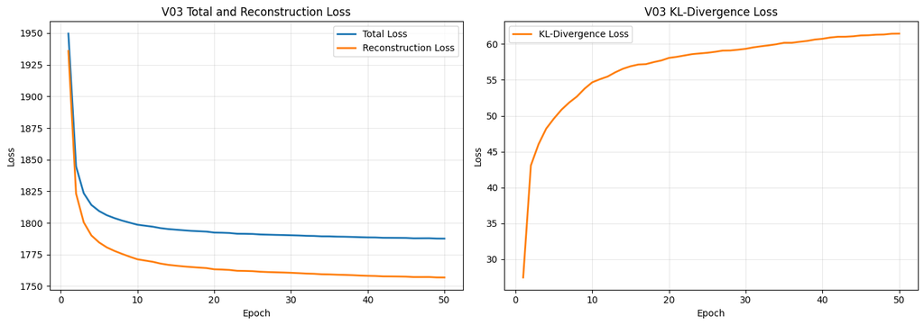

```
V03 training-loss figure saved to: artifacts\vae\V03\V03_training_loss_curves.png
```

```python
v03_required_columns = [
    "total_loss",
    "reconstruction_loss",
    "kl_loss"
]
v03_missing_columns = [
    column
    for column in v03_required_columns
    if column not in v03_history_df.columns
]

assert not v03_missing_columns, (
    "Missing V03 history columns: "
    f"{v03_missing_columns}"
)
assert len(v03_history_df) == V03_EPOCHS
assert np.isfinite(
    v03_history_df[v03_required_columns].to_numpy()
).all()

print("V03 training-history validation passed.")
print(f"Recorded epochs: {len(v03_history_df)}")
print("\nFirst-epoch V03 losses:")
print(
    v03_history_df.loc[1, v03_required_columns].round(4)
)
print("\nFinal-epoch V03 losses:")
print(
    v03_history_df.loc[
        V03_EPOCHS,
        v03_required_columns
    ].round(4)
)
print("\nLast 10 V03 epochs:")
display(
    v03_history_df[v03_required_columns]
    .tail(10)
    .round(4)
)

fig, axes = plt.subplots(1, 2, figsize=(14, 5))
axes[0].plot(
    v03_history_df.index,
    v03_history_df["total_loss"],
    label="Total Loss",
    linewidth=2
)
axes[0].plot(
    v03_history_df.index,
    v03_history_df["reconstruction_loss"],
    label="Reconstruction Loss",
    linewidth=2
)
axes[0].set_title(
    "V03 Total and Reconstruction Loss"
)
axes[0].set_xlabel("Epoch")
axes[0].set_ylabel("Loss")
axes[0].grid(alpha=0.3)
axes[0].legend()

axes[1].plot(
    v03_history_df.index,
    v03_history_df["kl_loss"],
    color="tab:orange",
    label="KL-Divergence Loss",
    linewidth=2
)
axes[1].set_title("V03 KL-Divergence Loss")
axes[1].set_xlabel("Epoch")
axes[1].set_ylabel("Loss")
axes[1].grid(alpha=0.3)
axes[1].legend()
plt.tight_layout()

v03_training_curve_path = (
    v03_artifact_dir / "V03_training_loss_curves.png"
)
plt.savefig(
    v03_training_curve_path,
    dpi=150,
    bbox_inches="tight"
)
plt.show()
print(
    "V03 training-loss figure saved to: "
    f"{v03_training_curve_path}"
)
```

### 8.4 V03 Training Interpretation

V03 completed all 50 epochs with finite losses and saved every planned checkpoint. Total and reconstruction losses fell rapidly during the first ten epochs and then improved gradually, while KL divergence rose smoothly from 27.4556 to 61.4537. This is consistent with a stable latent representation rather than numerical divergence or posterior collapse.

The final V03 losses were total loss 1787.5892, reconstruction loss 1756.8628, and unweighted KL loss 61.4537. Relative to the matched V01 incumbent, total loss decreased by 0.09%, reconstruction loss decreased by 0.11%, and KL increased by 0.86%. These are small differences. Training loss therefore provides no evidence that conditioning damaged optimisation, but it also cannot show whether requested-class control was learned.

V03's success depends on generation behaviour. The next evaluation asks three separate questions:

1. Do fixed requested-class samples become more structured across checkpoints?
2. Does changing only the one-hot label alter the generated image in a systematic way?
3. Does conditional control preserve reconstruction quality, overall image statistics, and diversity relative to V01?

No final model decision is made from the training curves.

### 8.5 V03 Checkpoint Progression

Each V03 checkpoint is evaluated on the same 20 fixed reconstruction images using their true one-hot labels. For generation, one fixed latent draw is paired with each requested CIFAR-10 class at epochs 1, 10, 25, 40, and 50. The column labels indicate the requested class, not a class predicted by an external classifier.

The protected test set remains unused.

```
V03 fixed-input checkpoint metrics:
```

| epoch | training_reconstruction_loss | unweighted_kl_loss | reconstruction_mse | reconstruction_mae | reconstruction_psnr_db |
| --- | --- | --- | --- | --- | --- |
| 1 | 1935.89392 | 27.45556 | 0.02133 | 0.11375 | 17.009041 |
| 10 | 1771.23157 | 54.66772 | 0.00933 | 0.07042 | 20.867599 |
| 25 | 1761.86621 | 58.78376 | 0.00831 | 0.06604 | 21.421209 |
| 40 | 1758.17786 | 60.73553 | 0.00781 | 0.06431 | 21.638639 |
| 50 | 1756.86279 | 61.45366 | 0.00770 | 0.06391 | 21.675640 |

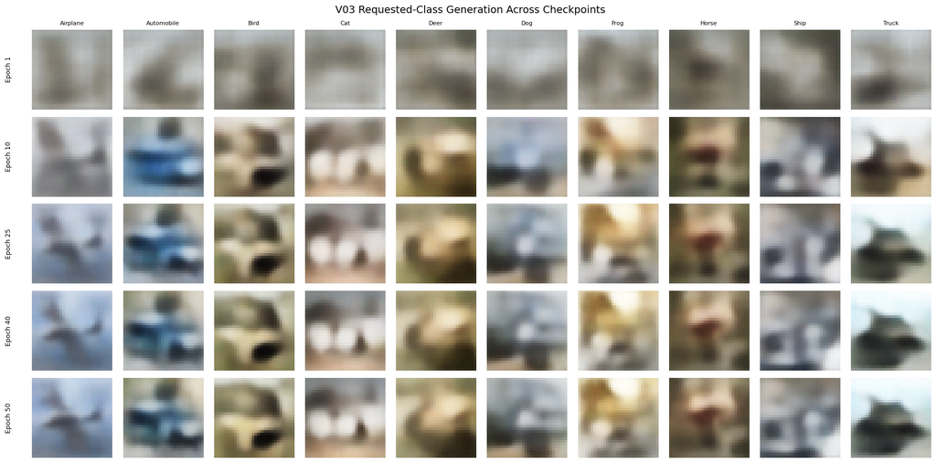

```
V03 checkpoint metrics saved to: artifacts\vae\V03\evaluation\V03_checkpoint_metrics.csv
V03 checkpoint grid saved to: artifacts\vae\V03\evaluation\V03_checkpoint_requested_class_grid.png
Official test-set usage: None
```

```python
v03_artifact_dir = Path("artifacts") / "vae" / "V03"
v03_evaluation_dir = v03_artifact_dir / "evaluation"
v03_evaluation_dir.mkdir(parents=True, exist_ok=True)

fixed_inputs_dir = (
    Path("artifacts") / "vae" / "fixed_inputs"
)
fixed_latent_path_v03 = (
    fixed_inputs_dir / "fixed_latent_vectors_dim64.npy"
)
fixed_indices_path_v03 = (
    fixed_inputs_dir / "fixed_reconstruction_indices.npy"
)
fixed_label_ids_path_v03 = (
    fixed_inputs_dir
    / "V03_fixed_conditional_label_ids.npy"
)
fixed_one_hot_path_v03 = (
    fixed_inputs_dir
    / "V03_fixed_conditional_one_hot_labels.npy"
)
v03_history_path = (
    v03_artifact_dir / "V03_training_history.csv"
)
v03_final_weights_path = (
    v03_artifact_dir
    / "weights"
    / "V03_vae_final.weights.h5"
)

for required_path in [
    fixed_latent_path_v03,
    fixed_indices_path_v03,
    fixed_label_ids_path_v03,
    fixed_one_hot_path_v03,
    v03_history_path,
    v03_final_weights_path
]:
    assert required_path.exists(), (
        f"Required artefact not found: {required_path}"
    )

fixed_latent_vectors_v03 = np.load(
    fixed_latent_path_v03
).astype(np.float32)
fixed_reconstruction_indices = np.load(
    fixed_indices_path_v03
)
fixed_conditional_label_ids_v03 = np.load(
    fixed_label_ids_path_v03
)
fixed_conditional_labels_v03 = np.load(
    fixed_one_hot_path_v03
).astype(np.float32)

fixed_reconstruction_images = x_train_vae[
    fixed_reconstruction_indices
]
fixed_reconstruction_labels = y_train[
    fixed_reconstruction_indices
]
fixed_reconstruction_one_hot_v03 = (
    keras.utils.to_categorical(
        fixed_reconstruction_labels,
        num_classes=V03_NUM_CLASSES
    ).astype(np.float32)
)

assert fixed_latent_vectors_v03.shape == (100, 64)
assert fixed_conditional_labels_v03.shape == (100, 10)
assert fixed_reconstruction_images.shape == (
    20,
    32,
    32,
    3
)
assert fixed_reconstruction_one_hot_v03.shape == (20, 10)

# Indices 0, 10, ..., 90 contain one requested
# example for classes 0, 1, ..., 9 respectively.
class_preview_indices_v03 = np.arange(
    0,
    100,
    10,
    dtype=np.int64
)
assert np.array_equal(
    fixed_conditional_label_ids_v03[
        class_preview_indices_v03
    ],
    np.arange(V03_NUM_CLASSES)
)

v03_checkpoint_epochs = [1, 10, 25, 40, 50]
v03_history_for_evaluation = pd.read_csv(
    v03_history_path,
    index_col="epoch"
)
v03_checkpoint_records = []
v03_checkpoint_generated = {}

for checkpoint_epoch in v03_checkpoint_epochs:
    checkpoint_path = (
        v03_artifact_dir
        / "checkpoints"
        / (
            "V03_epoch_"
            f"{checkpoint_epoch:03d}"
            ".weights.h5"
        )
    )
    assert checkpoint_path.exists(), (
        f"V03 checkpoint not found: {checkpoint_path}"
    )
    vae_v03.load_weights(str(checkpoint_path))

    checkpoint_z_mean, _, _ = encoder_v03.predict(
        [
            fixed_reconstruction_images,
            fixed_reconstruction_one_hot_v03
        ],
        verbose=0
    )
    checkpoint_reconstructions = np.clip(
        decoder_v03.predict(
            [
                checkpoint_z_mean,
                fixed_reconstruction_one_hot_v03
            ],
            verbose=0
        ),
        0.0,
        1.0
    )

    mse_per_image = np.mean(
        np.square(
            fixed_reconstruction_images
            - checkpoint_reconstructions
        ),
        axis=(1, 2, 3)
    )
    mae_per_image = np.mean(
        np.abs(
            fixed_reconstruction_images
            - checkpoint_reconstructions
        ),
        axis=(1, 2, 3)
    )
    psnr_per_image = tf.image.psnr(
        fixed_reconstruction_images,
        checkpoint_reconstructions,
        max_val=1.0
    ).numpy()

    checkpoint_generation = np.clip(
        decoder_v03.predict(
            [
                fixed_latent_vectors_v03[
                    class_preview_indices_v03
                ],
                fixed_conditional_labels_v03[
                    class_preview_indices_v03
                ]
            ],
            verbose=0
        ),
        0.0,
        1.0
    )
    v03_checkpoint_generated[checkpoint_epoch] = (
        checkpoint_generation
    )

    v03_checkpoint_records.append({
        "epoch": checkpoint_epoch,
        "training_reconstruction_loss": (
            v03_history_for_evaluation.loc[
                checkpoint_epoch,
                "reconstruction_loss"
            ]
        ),
        "unweighted_kl_loss": (
            v03_history_for_evaluation.loc[
                checkpoint_epoch,
                "kl_loss"
            ]
        ),
        "reconstruction_mse": mse_per_image.mean(),
        "reconstruction_mae": mae_per_image.mean(),
        "reconstruction_psnr_db": psnr_per_image.mean()
    })

vae_v03.load_weights(str(v03_final_weights_path))

v03_checkpoint_metrics_df = pd.DataFrame(
    v03_checkpoint_records
).set_index("epoch")
v03_checkpoint_metrics_path = (
    v03_evaluation_dir / "V03_checkpoint_metrics.csv"
)
v03_checkpoint_metrics_df.to_csv(
    v03_checkpoint_metrics_path
)

print("V03 fixed-input checkpoint metrics:")
display(v03_checkpoint_metrics_df.round(5))

fig, axes = plt.subplots(
    len(v03_checkpoint_epochs),
    V03_NUM_CLASSES,
    figsize=(18, 9)
)
for row_index, checkpoint_epoch in enumerate(
    v03_checkpoint_epochs
):
    for class_id, class_name in enumerate(class_names):
        axes[row_index, class_id].imshow(
            v03_checkpoint_generated[
                checkpoint_epoch
            ][class_id]
        )
        axes[row_index, class_id].axis("off")
        if row_index == 0:
            axes[row_index, class_id].set_title(
                class_name,
                fontsize=8
            )
    axes[row_index, 0].text(
        -0.25,
        0.5,
        f"Epoch {checkpoint_epoch}",
        transform=axes[row_index, 0].transAxes,
        rotation=90,
        va="center",
        ha="right",
        fontsize=9
    )

fig.suptitle(
    "V03 Requested-Class Generation Across Checkpoints",
    fontsize=14
)
plt.tight_layout()
v03_checkpoint_grid_path = (
    v03_evaluation_dir
    / "V03_checkpoint_requested_class_grid.png"
)
plt.savefig(
    v03_checkpoint_grid_path,
    dpi=150,
    bbox_inches="tight"
)
plt.show()

print(
    "V03 checkpoint metrics saved to: "
    f"{v03_checkpoint_metrics_path}"
)
print(
    "V03 checkpoint grid saved to: "
    f"{v03_checkpoint_grid_path}"
)
print("Official test-set usage: None")
```

### 8.6 Conditional Control and V01-versus-V03 Comparison

The final comparison separates ordinary image quality from class control:

- **Reconstruction:** both models receive the same 20 images; V03 additionally receives each true class label.
- **Balanced generation:** both models receive the same 100 fixed 64-dimensional latent vectors. V01 remains unrequested, while V03 receives ten requested labels per class.
- **Label intervention:** the same ten latent vectors are repeated across all ten V03 labels. Within each column, only the label changes. This directly tests whether the decoder responds to class information.
- **Counterfactual reconstruction:** each V03 posterior mean is decoded with every possible label. True-label error is compared with wrong-label error.
- **Quality and diversity:** shared descriptors, uniqueness, mean pixel diversity, and latent diagnostics are reported.

The label-intervention statistics measure low-level separation, not human recognisability. The requested-class grid must still be inspected visually, and later manual scoring must not silently relabel ambiguous outputs.

```python
# -------------------------------------------------------
# 1. Reload both final models
# -------------------------------------------------------
v01_artifact_dir = Path("artifacts") / "vae" / "V01"
v01_final_weights_path = (
    v01_artifact_dir
    / "weights"
    / "V01_vae_final.weights.h5"
)
assert v01_final_weights_path.exists()
assert v03_final_weights_path.exists()
vae_v01.load_weights(str(v01_final_weights_path))
vae_v03.load_weights(str(v03_final_weights_path))

# -------------------------------------------------------
# 2. Deterministic reconstruction comparison
# -------------------------------------------------------
v01_z_mean_fixed, _, _ = encoder_v01.predict(
    fixed_reconstruction_images,
    verbose=0
)
v03_z_mean_fixed, _, _ = encoder_v03.predict(
    [
        fixed_reconstruction_images,
        fixed_reconstruction_one_hot_v03
    ],
    verbose=0
)
v01_reconstructions = np.clip(
    decoder_v01.predict(v01_z_mean_fixed, verbose=0),
    0.0,
    1.0
)
v03_reconstructions = np.clip(
    decoder_v03.predict(
        [
            v03_z_mean_fixed,
            fixed_reconstruction_one_hot_v03
        ],
        verbose=0
    ),
    0.0,
    1.0
)


def v03_reconstruction_metric_arrays(
    originals,
    reconstructions
):
    mse_values = np.mean(
        np.square(originals - reconstructions),
        axis=(1, 2, 3)
    )
    mae_values = np.mean(
        np.abs(originals - reconstructions),
        axis=(1, 2, 3)
    )
    psnr_values = tf.image.psnr(
        originals,
        reconstructions,
        max_val=1.0
    ).numpy()
    return mse_values, mae_values, psnr_values


v01_mse, v01_mae, v01_psnr = (
    v03_reconstruction_metric_arrays(
        fixed_reconstruction_images,
        v01_reconstructions
    )
)
v03_mse, v03_mae, v03_psnr = (
    v03_reconstruction_metric_arrays(
        fixed_reconstruction_images,
        v03_reconstructions
    )
)

v01_v03_reconstruction_df = pd.DataFrame(
    {
        "V01_unconditional": [
            v01_mse.mean(),
            v01_mae.mean(),
            v01_psnr.mean()
        ],
        "V03_conditional": [
            v03_mse.mean(),
            v03_mae.mean(),
            v03_psnr.mean()
        ]
    },
    index=[
        "mse_lower_is_better",
        "mae_lower_is_better",
        "psnr_db_higher_is_better"
    ]
)
v01_v03_reconstruction_df["V03_minus_V01"] = (
    v01_v03_reconstruction_df["V03_conditional"]
    - v01_v03_reconstruction_df[
        "V01_unconditional"
    ]
)
print("Overall fixed reconstruction comparison:")
display(v01_v03_reconstruction_df.round(6))

v01_v03_per_class_records = []
for class_id, class_name in enumerate(class_names):
    class_mask = fixed_reconstruction_labels == class_id
    v01_v03_per_class_records.append({
        "class_name": class_name,
        "V01_mse": v01_mse[class_mask].mean(),
        "V03_mse": v03_mse[class_mask].mean(),
        "mse_change_V03_minus_V01": (
            v03_mse[class_mask].mean()
            - v01_mse[class_mask].mean()
        ),
        "V01_psnr_db": v01_psnr[class_mask].mean(),
        "V03_psnr_db": v03_psnr[class_mask].mean(),
        "psnr_change_V03_minus_V01": (
            v03_psnr[class_mask].mean()
            - v01_psnr[class_mask].mean()
        )
    })
v01_v03_per_class_df = pd.DataFrame(
    v01_v03_per_class_records
).set_index("class_name")
print("\nPer-class fixed reconstruction comparison:")
display(v01_v03_per_class_df.round(6))

v01_v03_reconstruction_path = (
    v03_evaluation_dir
    / "V01_V03_reconstruction_comparison.csv"
)
v01_v03_per_class_df.to_csv(
    v01_v03_reconstruction_path
)

fig, axes = plt.subplots(6, 10, figsize=(18, 11))
row_labels = [
    "Original 1",
    "V01 1",
    "V03 1",
    "Original 2",
    "V01 2",
    "V03 2"
]
for class_id, class_name in enumerate(class_names):
    first_position = class_id * 2
    second_position = first_position + 1
    image_sequence = [
        fixed_reconstruction_images[first_position],
        v01_reconstructions[first_position],
        v03_reconstructions[first_position],
        fixed_reconstruction_images[second_position],
        v01_reconstructions[second_position],
        v03_reconstructions[second_position]
    ]
    for row_index, image_value in enumerate(image_sequence):
        axes[row_index, class_id].imshow(image_value)
        axes[row_index, class_id].axis("off")
        if class_id == 0:
            axes[row_index, class_id].text(
                -0.2,
                0.5,
                row_labels[row_index],
                transform=axes[
                    row_index,
                    class_id
                ].transAxes,
                rotation=90,
                va="center",
                ha="right",
                fontsize=9
            )
    axes[0, class_id].set_title(class_name, fontsize=9)
fig.suptitle(
    "Fixed Reconstructions: V01 versus V03",
    fontsize=14
)
plt.tight_layout()
v01_v03_reconstruction_grid_path = (
    v03_evaluation_dir
    / "V01_V03_reconstruction_grid.png"
)
plt.savefig(
    v01_v03_reconstruction_grid_path,
    dpi=150,
    bbox_inches="tight"
)
plt.show()

# -------------------------------------------------------
# 3. Balanced fixed-prior generation
# -------------------------------------------------------
v01_generated_float = np.clip(
    decoder_v01.predict(
        fixed_latent_vectors_v03,
        verbose=0
    ),
    0.0,
    1.0
)
v03_generated_float = np.clip(
    decoder_v03.predict(
        [
            fixed_latent_vectors_v03,
            fixed_conditional_labels_v03
        ],
        verbose=0
    ),
    0.0,
    1.0
)
v01_generated_uint8 = np.rint(
    v01_generated_float * 255.0
).astype(np.uint8)
v03_generated_uint8 = np.rint(
    v03_generated_float * 255.0
).astype(np.uint8)

v03_generated_samples_path = (
    v03_evaluation_dir
    / "V03_fixed_requested_samples.npy"
)
np.save(v03_generated_samples_path, v03_generated_uint8)

fig, axes = plt.subplots(10, 10, figsize=(14, 14))
for class_id, class_name in enumerate(class_names):
    class_start = class_id * 10
    for draw_index in range(10):
        axis = axes[class_id, draw_index]
        axis.imshow(
            v03_generated_float[
                class_start + draw_index
            ]
        )
        axis.axis("off")
        if class_id == 0:
            axis.set_title(
                f"Draw {draw_index + 1}",
                fontsize=8
            )
        if draw_index == 0:
            axis.text(
                -0.25,
                0.5,
                class_name,
                transform=axis.transAxes,
                rotation=90,
                va="center",
                ha="right",
                fontsize=9
            )
fig.suptitle(
    "V03 Balanced Requested-Class Generation",
    fontsize=14
)
plt.tight_layout()
v03_requested_class_grid_path = (
    v03_evaluation_dir
    / "V03_balanced_requested_class_grid.png"
)
plt.savefig(
    v03_requested_class_grid_path,
    dpi=150,
    bbox_inches="tight"
)
plt.show()
```

```python
# -------------------------------------------------------
# 4. Same-z, different-label intervention
# -------------------------------------------------------
shared_latents_v03 = fixed_latent_vectors_v03[:10]
intervention_latents_v03 = np.tile(
    shared_latents_v03,
    (V03_NUM_CLASSES, 1)
)
intervention_label_ids_v03 = np.repeat(
    np.arange(V03_NUM_CLASSES),
    10
)
intervention_labels_v03 = (
    keras.utils.to_categorical(
        intervention_label_ids_v03,
        num_classes=V03_NUM_CLASSES
    ).astype(np.float32)
)
intervention_images_v03 = np.clip(
    decoder_v03.predict(
        [
            intervention_latents_v03,
            intervention_labels_v03
        ],
        verbose=0
    ),
    0.0,
    1.0
).reshape(10, 10, 32, 32, 3)

fig, axes = plt.subplots(10, 10, figsize=(14, 14))
for class_id, class_name in enumerate(class_names):
    for latent_index in range(10):
        axis = axes[class_id, latent_index]
        axis.imshow(
            intervention_images_v03[
                class_id,
                latent_index
            ]
        )
        axis.axis("off")
        if class_id == 0:
            axis.set_title(
                f"z{latent_index}",
                fontsize=8
            )
        if latent_index == 0:
            axis.text(
                -0.25,
                0.5,
                class_name,
                transform=axis.transAxes,
                rotation=90,
                va="center",
                ha="right",
                fontsize=9
            )
fig.suptitle(
    "V03 Label Intervention: Same z, Different Label",
    fontsize=14
)
plt.tight_layout()
v03_label_intervention_grid_path = (
    v03_evaluation_dir
    / "V03_same_z_different_label_grid.png"
)
plt.savefig(
    v03_label_intervention_grid_path,
    dpi=150,
    bbox_inches="tight"
)
plt.show()

class_centroids_v03 = intervention_images_v03.mean(axis=1)
global_centroid_v03 = class_centroids_v03.mean(axis=0)
within_class_variance_v03 = np.mean(
    np.square(
        intervention_images_v03
        - class_centroids_v03[:, None]
    )
)
between_class_variance_v03 = np.mean(
    np.square(
        class_centroids_v03
        - global_centroid_v03
    )
)
class_separation_ratio_v03 = (
    between_class_variance_v03
    / within_class_variance_v03
)

label_pair_mae_values_v03 = []
for latent_index in range(10):
    for first_class in range(V03_NUM_CLASSES):
        for second_class in range(
            first_class + 1,
            V03_NUM_CLASSES
        ):
            label_pair_mae_values_v03.append(
                np.mean(
                    np.abs(
                        intervention_images_v03[
                            first_class,
                            latent_index
                        ]
                        - intervention_images_v03[
                            second_class,
                            latent_index
                        ]
                    )
                )
            )

# Decode the same posterior mean with every label.
counterfactual_mse_v03 = np.empty(
    (
        len(fixed_reconstruction_images),
        V03_NUM_CLASSES
    ),
    dtype=np.float32
)
for candidate_class in range(V03_NUM_CLASSES):
    candidate_labels = keras.utils.to_categorical(
        np.full(
            len(fixed_reconstruction_images),
            candidate_class
        ),
        num_classes=V03_NUM_CLASSES
    ).astype(np.float32)
    candidate_reconstructions = np.clip(
        decoder_v03.predict(
            [v03_z_mean_fixed, candidate_labels],
            verbose=0
        ),
        0.0,
        1.0
    )
    counterfactual_mse_v03[:, candidate_class] = (
        np.mean(
            np.square(
                fixed_reconstruction_images
                - candidate_reconstructions
            ),
            axis=(1, 2, 3)
        )
    )

true_label_mse_v03 = counterfactual_mse_v03[
    np.arange(len(fixed_reconstruction_images)),
    fixed_reconstruction_labels
]
wrong_label_mask_v03 = np.ones_like(
    counterfactual_mse_v03,
    dtype=bool
)
wrong_label_mask_v03[
    np.arange(len(fixed_reconstruction_images)),
    fixed_reconstruction_labels
] = False
mean_wrong_label_mse_v03 = (
    counterfactual_mse_v03[
        wrong_label_mask_v03
    ].reshape(-1, 9).mean(axis=1)
)
counterfactual_summary_df = pd.DataFrame(
    {
        "value": [
            np.mean(label_pair_mae_values_v03),
            within_class_variance_v03,
            between_class_variance_v03,
            class_separation_ratio_v03,
            true_label_mse_v03.mean(),
            mean_wrong_label_mse_v03.mean(),
            np.mean(
                true_label_mse_v03
                < mean_wrong_label_mse_v03
            ),
            np.mean(
                np.argmin(
                    counterfactual_mse_v03,
                    axis=1
                )
                == fixed_reconstruction_labels
            )
        ]
    },
    index=[
        "mean_pairwise_mae_between_labels_same_z",
        "within_requested_class_pixel_variance",
        "between_requested_class_centroid_variance",
        "between_to_within_variance_ratio",
        "mean_true_label_reconstruction_mse",
        "mean_wrong_label_reconstruction_mse",
        "fraction_true_mse_below_mean_wrong_mse",
        "fraction_true_label_lowest_mse_of_10"
    ]
)
print("\nV03 label-control diagnostics:")
display(counterfactual_summary_df.round(6))
counterfactual_summary_path = (
    v03_evaluation_dir
    / "V03_label_control_diagnostics.csv"
)
counterfactual_summary_df.to_csv(
    counterfactual_summary_path
)

# -------------------------------------------------------
# 5. Shared descriptors and diversity
# -------------------------------------------------------
descriptor_rng = np.random.default_rng(SEED + 100)
reference_indices = []
for class_id in range(V03_NUM_CLASSES):
    class_indices = np.where(y_train == class_id)[0]
    reference_indices.extend(
        descriptor_rng.choice(
            class_indices,
            size=100,
            replace=False
        )
    )
reference_indices = np.array(reference_indices)
reference_images = x_train_vae[reference_indices]
reference_labels = y_train[reference_indices]
reference_one_hot_v03 = keras.utils.to_categorical(
    reference_labels,
    num_classes=V03_NUM_CLASSES
).astype(np.float32)
```

```python
def v03_comparison_descriptors(image_batch):
    horizontal_difference = np.abs(
        np.diff(image_batch, axis=2)
    ).mean(axis=(1, 2, 3))
    vertical_difference = np.abs(
        np.diff(image_batch, axis=1)
    ).mean(axis=(1, 2, 3))
    return pd.DataFrame({
        "brightness": image_batch.mean(axis=(1, 2, 3)),
        "contrast": image_batch.std(axis=(1, 2, 3)),
        "red_mean": image_batch[:, :, :, 0].mean(
            axis=(1, 2)
        ),
        "green_mean": image_batch[:, :, :, 1].mean(
            axis=(1, 2)
        ),
        "blue_mean": image_batch[:, :, :, 2].mean(
            axis=(1, 2)
        ),
        "saturation": (
            image_batch.max(axis=3)
            - image_batch.min(axis=3)
        ).mean(axis=(1, 2)),
        "edge_strength": (
            horizontal_difference
            + vertical_difference
        ) / 2.0
    })


reference_descriptors = v03_comparison_descriptors(
    reference_images
)
v01_descriptors = v03_comparison_descriptors(
    v01_generated_float
)
v03_descriptors = v03_comparison_descriptors(
    v03_generated_float
)

descriptor_records = []
for descriptor_name in reference_descriptors.columns:
    training_mean = reference_descriptors[
        descriptor_name
    ].mean()
    v01_mean = v01_descriptors[descriptor_name].mean()
    v03_mean = v03_descriptors[descriptor_name].mean()
    v01_gap = abs(v01_mean - training_mean)
    v03_gap = abs(v03_mean - training_mean)
    descriptor_records.append({
        "descriptor": descriptor_name,
        "training_mean": training_mean,
        "V01_mean": v01_mean,
        "V03_mean": v03_mean,
        "V01_absolute_gap": v01_gap,
        "V03_absolute_gap": v03_gap,
        "gap_reduction_V03": v01_gap - v03_gap
    })
v01_v03_descriptor_df = pd.DataFrame(
    descriptor_records
).set_index("descriptor")
print("\nGenerated descriptor comparison:")
display(v01_v03_descriptor_df.round(6))
v01_v03_descriptor_path = (
    v03_evaluation_dir
    / "V01_V03_descriptor_comparison.csv"
)
v01_v03_descriptor_df.to_csv(v01_v03_descriptor_path)

v01_v03_diversity_df = pd.DataFrame(
    {
        "V01": [
            len(
                np.unique(
                    v01_generated_uint8.reshape(100, -1),
                    axis=0
                )
            ),
            np.mean(
                np.std(v01_generated_float, axis=0)
            )
        ],
        "V03": [
            len(
                np.unique(
                    v03_generated_uint8.reshape(100, -1),
                    axis=0
                )
            ),
            np.mean(
                np.std(v03_generated_float, axis=0)
            )
        ],
        "Training_reference": [
            np.nan,
            np.mean(np.std(reference_images, axis=0))
        ]
    },
    index=[
        "unique_uint8_images_out_of_100",
        "mean_pixel_standard_deviation"
    ]
)
print("\nGenerated diversity comparison:")
display(v01_v03_diversity_df.round(6))

# Per-class descriptor evidence for requested outputs.
per_class_descriptor_records = []
selected_descriptor_names = [
    "brightness",
    "contrast",
    "saturation",
    "edge_strength"
]
for class_id, class_name in enumerate(class_names):
    training_mask = reference_labels == class_id
    generated_mask = (
        fixed_conditional_label_ids_v03 == class_id
    )
    record = {"class_name": class_name}
    for descriptor_name in selected_descriptor_names:
        training_value = reference_descriptors.loc[
            training_mask,
            descriptor_name
        ].mean()
        generated_value = v03_descriptors.loc[
            generated_mask,
            descriptor_name
        ].mean()
        record[
            f"training_{descriptor_name}"
        ] = training_value
        record[
            f"V03_{descriptor_name}"
        ] = generated_value
        record[
            f"absolute_gap_{descriptor_name}"
        ] = abs(generated_value - training_value)
    per_class_descriptor_records.append(record)
v03_per_class_descriptor_df = pd.DataFrame(
    per_class_descriptor_records
).set_index("class_name")
print("\nV03 requested-class descriptor comparison:")
display(v03_per_class_descriptor_df.round(6))
v03_per_class_descriptor_path = (
    v03_evaluation_dir
    / "V03_requested_class_descriptors.csv"
)
v03_per_class_descriptor_df.to_csv(
    v03_per_class_descriptor_path
)

# -------------------------------------------------------
# 6. Matched 64-D latent posterior diagnostics
# -------------------------------------------------------
v01_reference_mean, v01_reference_log_var, _ = (
    encoder_v01.predict(reference_images, verbose=0)
)
v03_reference_mean, v03_reference_log_var, _ = (
    encoder_v03.predict(
        [reference_images, reference_one_hot_v03],
        verbose=0
    )
)


def v03_latent_diagnostic_record(
    model_name,
    z_mean_values,
    z_log_var_values
):
    kl_per_image = -0.5 * np.sum(
        1.0
        + z_log_var_values
        - np.square(z_mean_values)
        - np.exp(z_log_var_values),
        axis=1
    )
    variance_by_dimension = np.var(
        z_mean_values,
        axis=0
    )
    return {
        "model": model_name,
        "mean_unweighted_kl": kl_per_image.mean(),
        "mean_absolute_z_mean": (
            np.abs(z_mean_values).mean()
        ),
        "mean_posterior_std": (
            np.exp(0.5 * z_log_var_values).mean()
        ),
        "mean_variance_of_z_mean_dims": (
            variance_by_dimension.mean()
        ),
        "active_units_variance_gt_0.01": int(
            np.sum(variance_by_dimension > 0.01)
        )
    }


v01_v03_latent_df = pd.DataFrame([
    v03_latent_diagnostic_record(
        "V01_unconditional",
        v01_reference_mean,
        v01_reference_log_var
    ),
    v03_latent_diagnostic_record(
        "V03_conditional",
        v03_reference_mean,
        v03_reference_log_var
    )
]).set_index("model")
print("\nMatched latent posterior comparison:")
display(v01_v03_latent_df.round(6))
v01_v03_latent_path = (
    v03_evaluation_dir
    / "V01_V03_latent_diagnostics.csv"
)
v01_v03_latent_df.to_csv(v01_v03_latent_path)
```

```
Overall fixed reconstruction comparison:
```

|  | V01_unconditional | V03_conditional | V03_minus_V01 |
| --- | --- | --- | --- |
| mse_lower_is_better | 0.007829 | 0.007696 | -0.000133 |
| mae_lower_is_better | 0.064010 | 0.063906 | -0.000104 |
| psnr_db_higher_is_better | 21.660751 | 21.675642 | 0.014891 |

```
Per-class fixed reconstruction comparison:
```

| class_name | V01_mse | V03_mse | mse_change_V03_minus_V01 | V01_psnr_db | V03_psnr_db | psnr_change_V03_minus_V01 |
| --- | --- | --- | --- | --- | --- | --- |
| Airplane | 0.010242 | 0.009616 | -0.000626 | 22.567642 | 22.607372 | 0.039730 |
| Automobile | 0.007941 | 0.008088 | 0.000147 | 21.266832 | 21.158916 | -0.107916 |
| Bird | 0.006266 | 0.006218 | -0.000048 | 22.155918 | 22.187523 | 0.031605 |
| Cat | 0.008010 | 0.008295 | 0.000284 | 20.974152 | 20.838879 | -0.135273 |
| Deer | 0.009972 | 0.010073 | 0.000101 | 20.474890 | 20.389462 | -0.085428 |
| Dog | 0.007605 | 0.007389 | -0.000216 | 21.218964 | 21.344263 | 0.125301 |
| Frog | 0.008705 | 0.008302 | -0.000403 | 20.632393 | 20.820110 | 0.187717 |
| Horse | 0.008831 | 0.008073 | -0.000758 | 20.672443 | 21.006584 | 0.334141 |
| Ship | 0.003515 | 0.003873 | 0.000358 | 25.020599 | 24.702595 | -0.318005 |
| Truck | 0.007199 | 0.007032 | -0.000166 | 21.623674 | 21.700729 | 0.077055 |

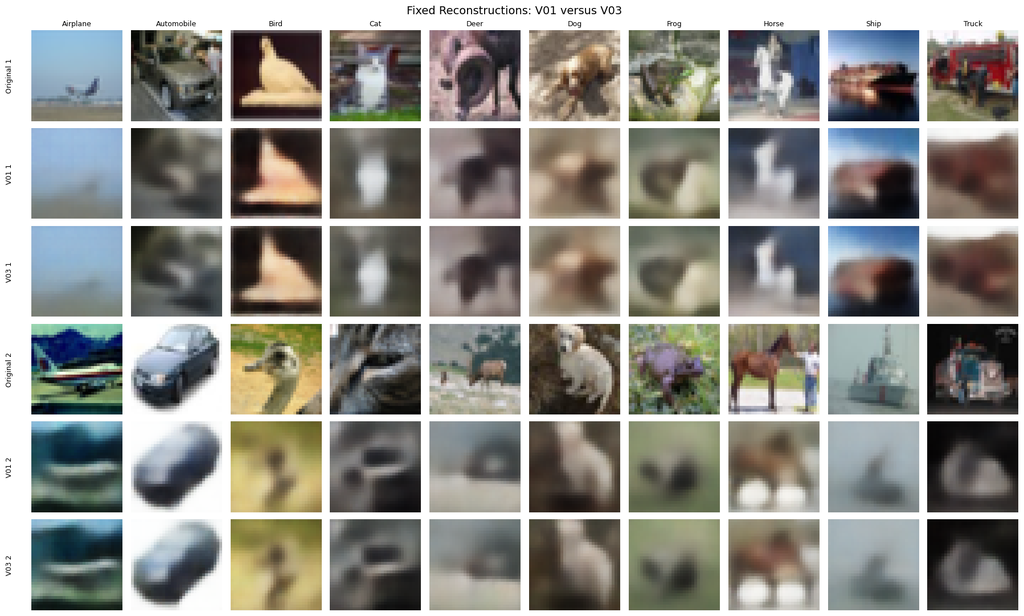

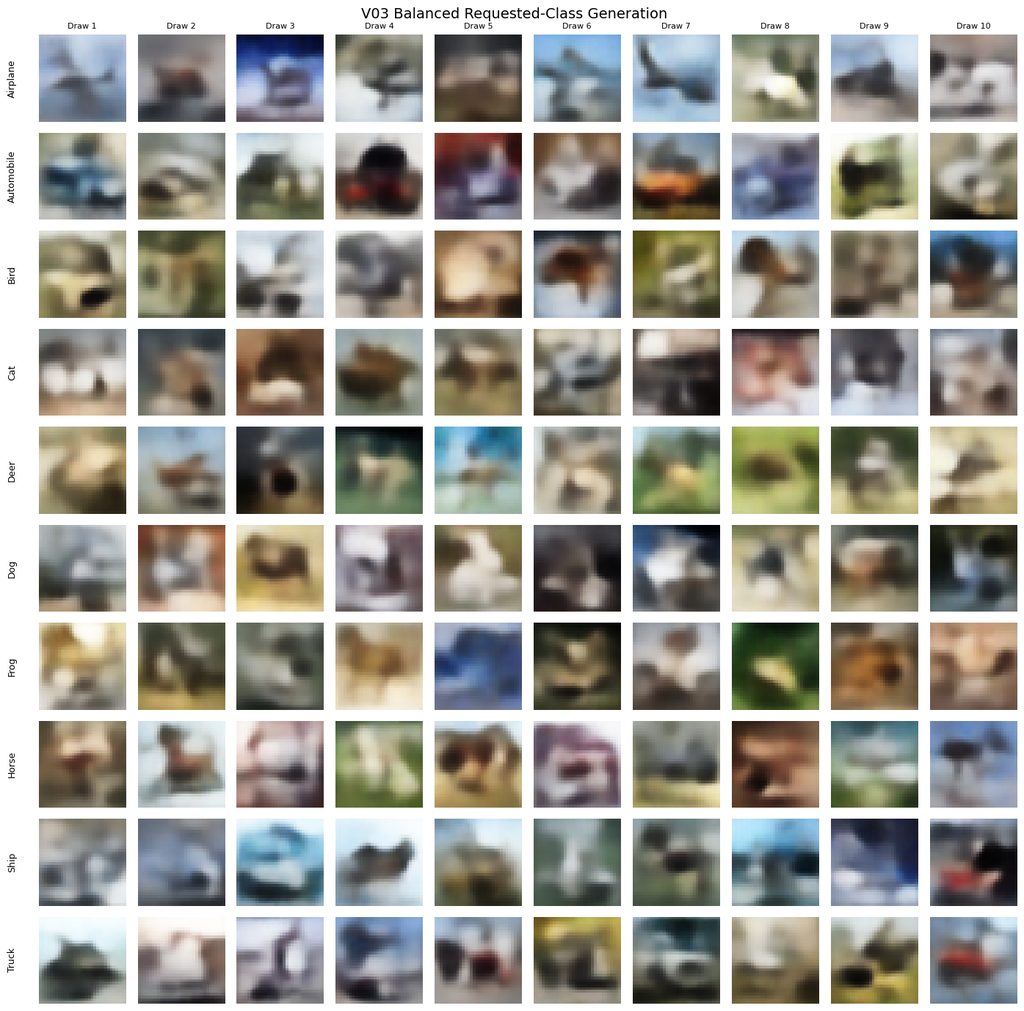

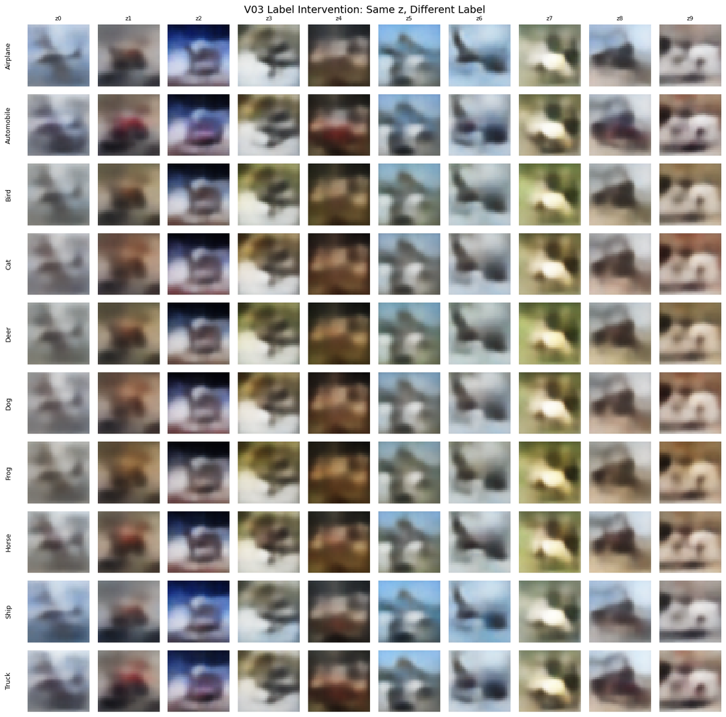

```
V03 label-control diagnostics:
```

|  | value |
| --- | --- |
| mean_pairwise_mae_between_labels_same_z | 0.055027 |
| within_requested_class_pixel_variance | 0.038273 |
| between_requested_class_centroid_variance | 0.002205 |
| between_to_within_variance_ratio | 0.057616 |
| mean_true_label_reconstruction_mse | 0.007696 |
| mean_wrong_label_reconstruction_mse | 0.013303 |
| fraction_true_mse_below_mean_wrong_mse | 1.000000 |
| fraction_true_label_lowest_mse_of_10 | 1.000000 |

```
Generated descriptor comparison:
```

| descriptor | training_mean | V01_mean | V03_mean | V01_absolute_gap | V03_absolute_gap | gap_reduction_V03 |
| --- | --- | --- | --- | --- | --- | --- |
| brightness | 0.473055 | 0.491670 | 0.488355 | 0.018615 | 0.015300 | 0.003315 |
| contrast | 0.213141 | 0.187481 | 0.186088 | 0.025660 | 0.027053 | -0.001393 |
| red_mean | 0.489844 | 0.518268 | 0.506511 | 0.028424 | 0.016668 | 0.011757 |
| green_mean | 0.482936 | 0.496388 | 0.497338 | 0.013453 | 0.014402 | -0.000950 |
| blue_mean | 0.446386 | 0.460354 | 0.461216 | 0.013968 | 0.014830 | -0.000862 |
| saturation | 0.129711 | 0.109810 | 0.116051 | 0.019901 | 0.013660 | 0.006242 |
| edge_strength | 0.058002 | 0.030020 | 0.029326 | 0.027982 | 0.028676 | -0.000694 |

```
Generated diversity comparison:
```

|  | V01 | V03 | Training_reference |
| --- | --- | --- | --- |
| unique_uint8_images_out_of_100 | 100.000000 | 100.000000 | NaN |
| mean_pixel_standard_deviation | 0.212463 | 0.210442 | 0.249836 |

```
V03 requested-class descriptor comparison:
```

| class_name | training_brightness | V03_brightness | absolute_gap_brightness | training_contrast | V03_contrast | absolute_gap_contrast | training_saturation | V03_saturation | absolute_gap_saturation | training_edge_strength | V03_edge_strength | absolute_gap_edge_strength |
| --- | --- | --- | --- | --- | --- | --- | --- | --- | --- | --- | --- | --- |
| Airplane | 0.550368 | 0.538455 | 0.011913 | 0.214661 | 0.176771 | 0.037889 | 0.143827 | 0.106454 | 0.037373 | 0.049489 | 0.028697 | 0.020792 |
| Automobile | 0.456023 | 0.473579 | 0.017556 | 0.235286 | 0.204245 | 0.031041 | 0.110859 | 0.102648 | 0.008210 | 0.070973 | 0.032351 | 0.038621 |
| Bird | 0.465895 | 0.482649 | 0.016754 | 0.178787 | 0.187216 | 0.008429 | 0.145960 | 0.122916 | 0.023044 | 0.049374 | 0.031357 | 0.018017 |
| Cat | 0.456068 | 0.471740 | 0.015672 | 0.216709 | 0.182329 | 0.034380 | 0.117143 | 0.097018 | 0.020124 | 0.057140 | 0.027712 | 0.029428 |
| Deer | 0.421086 | 0.494211 | 0.073125 | 0.175723 | 0.172385 | 0.003338 | 0.149968 | 0.149463 | 0.000505 | 0.051662 | 0.025865 | 0.025796 |
| Dog | 0.457652 | 0.473159 | 0.015507 | 0.220969 | 0.184046 | 0.036922 | 0.128401 | 0.104798 | 0.023603 | 0.058406 | 0.028834 | 0.029572 |
| Frog | 0.438980 | 0.436622 | 0.002357 | 0.192359 | 0.166363 | 0.025996 | 0.153511 | 0.155220 | 0.001710 | 0.061320 | 0.025866 | 0.035454 |
| Horse | 0.461790 | 0.509659 | 0.047869 | 0.223396 | 0.179735 | 0.043661 | 0.133550 | 0.127353 | 0.006196 | 0.063800 | 0.031517 | 0.032283 |
| Ship | 0.524599 | 0.495471 | 0.029128 | 0.219638 | 0.197083 | 0.022555 | 0.116373 | 0.099521 | 0.016852 | 0.047666 | 0.028874 | 0.018792 |
| Truck | 0.498091 | 0.508007 | 0.009916 | 0.253879 | 0.210700 | 0.043178 | 0.097520 | 0.095122 | 0.002398 | 0.070193 | 0.032189 | 0.038004 |

```
Matched latent posterior comparison:
```

| model | mean_unweighted_kl | mean_absolute_z_mean | mean_posterior_std | mean_variance_of_z_mean_dims | active_units_variance_gt_0.01 |
| --- | --- | --- | --- | --- | --- |
| V01_unconditional | 62.324078 | 0.604584 | 0.475810 | 0.707226 | 62 |
| V03_conditional | 62.017090 | 0.604957 | 0.460954 | 0.703887 | 59 |

```
Controlled V01-versus-V03 summary:
```

|  | V01_unconditional | V03_conditional |
| --- | --- | --- |
| encoder_plus_decoder_parameters | 1.024515e+06 | 1.047555e+06 |
| fixed_reconstruction_mse | 7.829000e-03 | 7.696000e-03 |
| fixed_reconstruction_mae | 6.401000e-02 | 6.390600e-02 |
| fixed_reconstruction_psnr_db | 2.166075e+01 | 2.167564e+01 |
| unique_uint8_images_out_of_100 | 1.000000e+02 | 1.000000e+02 |
| mean_pixel_standard_deviation | 2.124630e-01 | 2.104420e-01 |
| same_z_label_separation_ratio | NaN | 5.761600e-02 |

```
Saved V03 evaluation artefacts:
- artifacts\vae\V03\evaluation\V01_V03_reconstruction_comparison.csv
- artifacts\vae\V03\evaluation\V01_V03_reconstruction_grid.png
- artifacts\vae\V03\evaluation\V03_fixed_requested_samples.npy
- artifacts\vae\V03\evaluation\V03_balanced_requested_class_grid.png
- artifacts\vae\V03\evaluation\V03_same_z_different_label_grid.png
- artifacts\vae\V03\evaluation\V03_label_control_diagnostics.csv
- artifacts\vae\V03\evaluation\V01_V03_descriptor_comparison.csv
- artifacts\vae\V03\evaluation\V03_requested_class_descriptors.csv
- artifacts\vae\V03\evaluation\V01_V03_latent_diagnostics.csv
- artifacts\vae\V03\evaluation\V01_V03_controlled_summary.csv
Official test-set usage: None
```

```python
v01_v03_summary_df = pd.DataFrame(
    {
        "V01_unconditional": [
            encoder_v01.count_params()
            + decoder_v01.count_params(),
            v01_mse.mean(),
            v01_mae.mean(),
            v01_psnr.mean(),
            len(
                np.unique(
                    v01_generated_uint8.reshape(100, -1),
                    axis=0
                )
            ),
            np.mean(
                np.std(v01_generated_float, axis=0)
            ),
            np.nan
        ],
        "V03_conditional": [
            encoder_v03.count_params()
            + decoder_v03.count_params(),
            v03_mse.mean(),
            v03_mae.mean(),
            v03_psnr.mean(),
            len(
                np.unique(
                    v03_generated_uint8.reshape(100, -1),
                    axis=0
                )
            ),
            np.mean(
                np.std(v03_generated_float, axis=0)
            ),
            class_separation_ratio_v03
        ]
    },
    index=[
        "encoder_plus_decoder_parameters",
        "fixed_reconstruction_mse",
        "fixed_reconstruction_mae",
        "fixed_reconstruction_psnr_db",
        "unique_uint8_images_out_of_100",
        "mean_pixel_standard_deviation",
        "same_z_label_separation_ratio"
    ]
)
print("\nControlled V01-versus-V03 summary:")
display(v01_v03_summary_df.round(6))
v01_v03_summary_path = (
    v03_evaluation_dir
    / "V01_V03_controlled_summary.csv"
)
v01_v03_summary_df.to_csv(v01_v03_summary_path)

print("\nSaved V03 evaluation artefacts:")
for saved_path in [
    v01_v03_reconstruction_path,
    v01_v03_reconstruction_grid_path,
    v03_generated_samples_path,
    v03_requested_class_grid_path,
    v03_label_intervention_grid_path,
    counterfactual_summary_path,
    v01_v03_descriptor_path,
    v03_per_class_descriptor_path,
    v01_v03_latent_path,
    v01_v03_summary_path
]:
    print(f"- {saved_path}")
print("Official test-set usage: None")
```

### 8.7 V03 Development FID - Saved-Weight Three-Generation-Seed Evaluation

V03 uses the same three 5,000-image FID runs as the baseline, V01 and V02: its saved conditional decoder weights are reused with generation seeds `1001`, `1002`, and `1003`, followed by the individual values, mean, standard deviation, minimum and maximum. Each generation seed produces exactly 500 requested samples per CIFAR-10 class.

The seed-1001 result is validated and reused; seeds 1002 and 1003 are calculated by the updated cell. FID does not measure requested-class correctness, so its mean and variability must be interpreted together with V03's reconstruction, diversity and conditional-control evidence.

```python
assert (
    "create_repeated_fid_summary"
    in globals()
), (
    "Run the updated V01 FID cell first "
    "to restore the shared repeated-FID "
    "summary helper."
)
assert (
    "baseline_fid_feature_extractor"
    in globals()
)
assert (
    "baseline_real_fid_mean"
    in globals()
)
assert (
    "baseline_real_fid_covariance"
    in globals()
)


def build_inline_conditional_fid_decoder(
    latent_dim=64,
    num_classes=10
):
    latent_input = keras.Input(
        shape=(latent_dim,),
        name="inline_fid_latent_input"
    )
    label_input = keras.Input(
        shape=(num_classes,),
        name="inline_fid_label_input"
    )

    x = layers.Concatenate(
        name="inline_fid_latent_label_concat"
    )([
        latent_input,
        label_input
    ])
    x = layers.Dense(
        4 * 4 * 128,
        activation="relu",
        name="inline_fid_decoder_dense"
    )(x)
    x = layers.Reshape(
        (4, 4, 128),
        name="inline_fid_decoder_reshape"
    )(x)
    x = layers.Conv2DTranspose(
        128,
        kernel_size=3,
        strides=2,
        padding="same",
        activation="relu",
        name="inline_fid_decoder_deconv_1"
    )(x)
    x = layers.Conv2DTranspose(
        64,
        kernel_size=3,
        strides=2,
        padding="same",
        activation="relu",
        name="inline_fid_decoder_deconv_2"
    )(x)
    x = layers.Conv2DTranspose(
        32,
        kernel_size=3,
        strides=2,
        padding="same",
        activation="relu",
        name="inline_fid_decoder_deconv_3"
    )(x)
    output = layers.Conv2D(
        3,
        kernel_size=3,
        padding="same",
        activation="sigmoid",
        name="inline_fid_decoder_output"
    )(x)

    decoder = keras.Model(
        inputs=[
            latent_input,
            label_input
        ],
        outputs=output,
        name="inline_conditional_fid_decoder"
    )

    assert decoder.count_params() == 394_307
    return decoder


def load_existing_conditional_fid_rows(
    experiment_id,
    single_result_path,
    repeated_result_path
):
    existing_rows = {}
    single_result_path = Path(
        single_result_path
    )
    repeated_result_path = Path(
        repeated_result_path
    )

    if repeated_result_path.exists():
        existing_repeated_df = pd.read_csv(
            repeated_result_path
        )

        for _, row in (
            existing_repeated_df.iterrows()
        ):
            seed = int(row["seed"])
            if seed in INLINE_VAE_FID_SEEDS:
                existing_rows[seed] = {
                    "experiment_id": (
                        experiment_id
                    ),
                    "checkpoint_epoch": int(
                        row["checkpoint_epoch"]
                    ),
                    "seed": seed,
                    "generated_sample_count": int(
                        row[
                            "generated_sample_count"
                        ]
                    ),
                    "real_reference_count": int(
                        row[
                            "real_reference_count"
                        ]
                    ),
                    "samples_per_requested_class": (
                        int(
                            row[
                                "samples_per_"
                                "requested_class"
                            ]
                        )
                    ),
                    "fid": float(row["fid"]),
                    "score_role": (
                        "three_seed_formal_"
                        "comparison"
                    ),
                    "score_source": (
                        "reused_validated_"
                        "repeated_result"
                    ),
                    "test_set_used": False
                }

    if (
        1001 not in existing_rows
        and single_result_path.exists()
    ):
        existing_single_df = pd.read_csv(
            single_result_path
        )

        assert len(existing_single_df) == 1
        row = existing_single_df.iloc[0]
        assert (
            row["experiment_id"]
            == experiment_id
        )
        assert int(row["seed"]) == 1001
        assert int(
            row["generated_sample_count"]
        ) == INLINE_VAE_FID_SAMPLE_COUNT
        assert int(
            row["real_reference_count"]
        ) == (
            INLINE_VAE_FID_REAL_REFERENCE_COUNT
        )
        assert int(
            row[
                "samples_per_requested_class"
            ]
        ) == 500
        assert not bool(row["test_set_used"])

        existing_rows[1001] = {
            "experiment_id": experiment_id,
            "checkpoint_epoch": int(
                row["checkpoint_epoch"]
            ),
            "seed": 1001,
            "generated_sample_count": int(
                row["generated_sample_count"]
            ),
            "real_reference_count": int(
                row["real_reference_count"]
            ),
            "samples_per_requested_class": (
                int(
                    row[
                        "samples_per_"
                        "requested_class"
                    ]
                )
            ),
            "fid": float(row["fid"]),
            "score_role": (
                "three_seed_formal_comparison"
            ),
            "score_source": (
                "reused_validated_"
                "single_seed_result"
            ),
            "test_set_used": False
        }

    return existing_rows


def evaluate_saved_conditional_vae_fid(
    experiment_id,
    decoder_weights_path,
    single_result_path,
    repeated_result_path,
    summary_path
):
    decoder_weights_path = Path(
        decoder_weights_path
    )
    single_result_path = Path(
        single_result_path
    )
    repeated_result_path = Path(
        repeated_result_path
    )
    summary_path = Path(summary_path)

    assert decoder_weights_path.exists(), (
        "Saved decoder weights missing: "
        f"{decoder_weights_path}"
    )
```

```python
    decoder_model = (
        build_inline_conditional_fid_decoder(
            latent_dim=64,
            num_classes=10
        )
    )
    decoder_model.load_weights(
        str(decoder_weights_path)
    )

    rows_by_seed = (
        load_existing_conditional_fid_rows(
            experiment_id=experiment_id,
            single_result_path=(
                single_result_path
            ),
            repeated_result_path=(
                repeated_result_path
            )
        )
    )

    for fid_seed in INLINE_VAE_FID_SEEDS:
        if fid_seed in rows_by_seed:
            print(
                f"Reusing validated "
                f"{experiment_id} seed "
                f"{fid_seed} FID: "
                f"{rows_by_seed[fid_seed]['fid']:.4f}"
            )
            continue

        print(
            f"\nCalculating {experiment_id} "
            f"FID for seed {fid_seed}"
        )

        latent_vectors = (
            make_vae_fid_latents(
                sample_count=(
                    INLINE_VAE_FID_SAMPLE_COUNT
                ),
                latent_dim=64,
                seed=fid_seed
            )
        )
        requested_label_ids = np.repeat(
            np.arange(10, dtype=np.int64),
            (
                INLINE_VAE_FID_SAMPLE_COUNT
                // 10
            )
        )
        requested_one_hot = tf.one_hot(
            requested_label_ids,
            depth=10,
            dtype=tf.float32
        )

        generated_batches = []
        for start in range(
            0,
            INLINE_VAE_FID_SAMPLE_COUNT,
            BASELINE_FID_GENERATION_BATCH_SIZE
        ):
            end = min(
                start
                + (
                    BASELINE_FID_GENERATION_BATCH_SIZE
                ),
                INLINE_VAE_FID_SAMPLE_COUNT
            )
            image_batch = decoder_model(
                [
                    latent_vectors[start:end],
                    requested_one_hot[start:end]
                ],
                training=False
            )
            image_batch = tf.cast(
                tf.round(
                    tf.clip_by_value(
                        image_batch * 255.0,
                        0.0,
                        255.0
                    )
                ),
                tf.uint8
            )
            generated_batches.append(
                image_batch.numpy()
            )

        generated_images = np.concatenate(
            generated_batches,
            axis=0
        )

        assert generated_images.shape == (
            5_000,
            32,
            32,
            3
        )
        assert np.array_equal(
            np.bincount(
                requested_label_ids,
                minlength=10
            ),
            np.full(10, 500)
        )

        generated_features = (
            extract_vae_inception_features(
                images_uint8=generated_images,
                feature_extractor=(
                    baseline_fid_feature_extractor
                ),
                batch_size=(
                    BASELINE_FID_BATCH_SIZE
                )
            )
        )
        (
            generated_mean,
            generated_covariance
        ) = calculate_vae_feature_statistics(
            generated_features
        )
        fid_value = (
            calculate_vae_fid_from_statistics(
                baseline_real_fid_mean,
                baseline_real_fid_covariance,
                generated_mean,
                generated_covariance
            )
        )

        rows_by_seed[fid_seed] = {
            "experiment_id": experiment_id,
            "checkpoint_epoch": (
                INLINE_VAE_FID_CHECKPOINT_EPOCH
            ),
            "seed": fid_seed,
            "generated_sample_count": (
                INLINE_VAE_FID_SAMPLE_COUNT
            ),
            "real_reference_count": (
                INLINE_VAE_FID_REAL_REFERENCE_COUNT
            ),
            "samples_per_requested_class": 500,
            "fid": float(fid_value),
            "score_role": (
                "three_seed_formal_comparison"
            ),
            "score_source": (
                "calculated_in_experiment"
            ),
            "test_set_used": False
        }

        print(
            f"{experiment_id} seed "
            f"{fid_seed} FID: "
            f"{fid_value:.4f}"
        )

        del generated_images
        del generated_features
        del generated_mean
        del generated_covariance
        del latent_vectors
        gc.collect()

    repeated_df = (
        pd.DataFrame(
            list(rows_by_seed.values())
        )
        .sort_values("seed")
        .reset_index(drop=True)
    )

    assert len(repeated_df) == 3
    assert tuple(
        repeated_df["seed"].astype(int)
    ) == INLINE_VAE_FID_SEEDS
    assert (
        repeated_df[
            "generated_sample_count"
        ] == INLINE_VAE_FID_SAMPLE_COUNT
    ).all()
    assert (
        repeated_df[
            "samples_per_requested_class"
        ] == 500
    ).all()
    assert np.isfinite(
        repeated_df["fid"]
    ).all()
    assert not repeated_df[
        "test_set_used"
    ].any()

    summary_df = create_repeated_fid_summary(
        repeated_df
    )

    repeated_result_path.parent.mkdir(
        parents=True,
        exist_ok=True
    )
    repeated_df.to_csv(
        repeated_result_path,
        index=False
    )
    summary_df.to_csv(
        summary_path,
        index=False
    )

    return (
        repeated_df,
        summary_df,
        decoder_model
    )


v03_inline_fid_weights_path = (
    Path("artifacts")
    / "vae"
    / "V03"
    / "weights"
    / "V03_decoder_final.weights.h5"
)
v03_single_fid_result_path = (
    Path("artifacts")
    / "vae"
    / "V03"
    / "evaluation"
    / "V03_development_fid.csv"
)
v03_repeated_fid_result_path = (
    Path("artifacts")
    / "vae"
    / "V03"
    / "evaluation"
    / "V03_repeated_development_fid.csv"
)
v03_fid_summary_path = (
    Path("artifacts")
    / "vae"
    / "V03"
    / "evaluation"
    / "V03_development_fid_summary.csv"
)
```

```python
(
    v03_repeated_fid_df,
    v03_fid_summary_df,
    v03_inline_fid_decoder
) = evaluate_saved_conditional_vae_fid(
    experiment_id="V03",
    decoder_weights_path=(
        v03_inline_fid_weights_path
    ),
    single_result_path=(
        v03_single_fid_result_path
    ),
    repeated_result_path=(
        v03_repeated_fid_result_path
    ),
    summary_path=v03_fid_summary_path
)

print(
    "\nV03 repeated development-FID "
    "results:"
)
display(
    v03_repeated_fid_df.round(4)
)
print(
    "\nV03 FID summary "
    "(lower is better):"
)
display(
    v03_fid_summary_df.round(4)
)
print(
    "Repeated results saved to: "
    f"{v03_repeated_fid_result_path}"
)
print(
    "Summary saved to: "
    f"{v03_fid_summary_path}"
)
print("Balanced requested classes: Yes")
print("V03 retrained: No")
print("Official test-set usage: None")
```

```
Reusing validated V03 seed 1001 FID: 157.6641

Calculating V03 FID for seed 1002
```

```
V03 seed 1002 FID: 157.8785

Calculating V03 FID for seed 1003
```

```
V03 seed 1003 FID: 157.8282

V03 repeated development-FID results:
```

|  | experiment_id | checkpoint_epoch | seed | generated_sample_count | real_reference_count | samples_per_requested_class | fid | score_role | score_source | test_set_used |
| --- | --- | --- | --- | --- | --- | --- | --- | --- | --- | --- |
| 0 | V03 | 50 | 1001 | 5000 | 50000 | 500 | 157.6641 | three_seed_formal_comparison | reused_validated_single_seed_result | False |
| 1 | V03 | 50 | 1002 | 5000 | 50000 | 500 | 157.8785 | three_seed_formal_comparison | calculated_in_experiment | False |
| 2 | V03 | 50 | 1003 | 5000 | 50000 | 500 | 157.8282 | three_seed_formal_comparison | calculated_in_experiment | False |

```
V03 FID summary (lower is better):
```

|  | experiment_id | fid_mean | fid_std | fid_min | fid_max | repeat_count |
| --- | --- | --- | --- | --- | --- | --- |
| 0 | V03 | 157.7903 | 0.1121 | 157.6641 | 157.8785 | 3 |

```
Repeated results saved to: artifacts\vae\V03\evaluation\V03_repeated_development_fid.csv
Summary saved to: artifacts\vae\V03\evaluation\V03_development_fid_summary.csv
Balanced requested classes: Yes
V03 retrained: No
Official test-set usage: None
```

### 8.8 V03 Status - Retained as a Conditional Candidate

V03 is a valid conditional candidate, not the selected final VAE. It was deliberately built from V01 rather than V02:

- V01 retained the chosen `β = 0.5`, latent dimension 64 and stronger overall reconstruction-generation trade-off.
- V02 changed latent dimension to 128 but was rejected as the component to carry forward because its modest reconstruction and FID gains did not justify the larger parameter count and weaker generation/diversity evidence.
- V03 therefore returned to V01's 64-dimensional design and changed only one primary factor: one-hot class conditioning in both encoder and decoder.

V03 achieved a three-generation-seed mean FID of **157.7903 ± 0.1121**. This is only **0.17% lower** than V01's **158.0648 ± 0.7426**, so their distributional performance is treated as practically comparable rather than declaring V03 superior from the small mean difference. V03 nevertheless adds measurable requested-class control while retaining competitive reconstruction and diversity. FID cannot determine whether a requested class is correct, so the conditional diagnostics remain essential.

V03 remains in the V00-V05 candidate pool. No final within-VAE selection, human evaluation, freeze or handoff is performed at this stage. The next experiment tests whether a structure-aware reconstruction objective improves the conditional design.

## 9. Controlled Improvement - V04 Hybrid MAE-SSIM Conditional VAE

### 9.1 Experimental Rationale, Hypothesis, and Controls

V03 is the immediate conditional parent reference. V04 is trained from scratch and changes one primary factor at the experiment level: the reconstruction objective. V03 remains unchanged and stays in the eventual V00-V05 candidate pool.

V03 trained stably and retained an active latent space, yet its reconstructions and prior samples remained visibly smooth with weak local edges. This suggests that the next limitation is not simply failed optimisation or posterior collapse. Instead, the pixel-wise BCE objective may be insufficiently aligned with the structural qualities being sought in the generated images.

The working hypothesis is that V03's pixel-wise BCE reconstruction term may place excessive emphasis on exact independent pixel probabilities, encouraging averaged and overly smooth outputs. V04 therefore replaces BCE with **one combined L1 + SSIM reconstruction objective** intended to reduce overly harsh pixel-wise reconstruction penalisation while adding an explicit local-structure signal.

The experiment asks:

> Can one combined L1 + SSIM reconstruction objective reduce excessive pixel-wise reconstruction penalisation and VAE blur while preserving V03's conditional control, diversity, stability and competitive FID?

Lab 5 trains a VAE through the standard encoder → reparameterisation → decoder workflow and a custom `train_step` combining reconstruction and KL-divergence losses [3]. V04 retains that taught framework and changes only the reconstruction objective.

#### Clarifying the Suggested L1 and SSIM Terms

The proposed “L1 regularisation” is implemented as **L1 reconstruction loss**, also called mean absolute error (MAE), rather than L1 weight regularisation:

- **L1 reconstruction loss** penalises pixel errors linearly and directly compares the generated image with its target.
- **L1 weight regularisation** penalises model weights to encourage sparsity; it does not directly target image sharpness and is not used.
- **MSE** is retained as an evaluation metric, not the optimized objective.
- **SSIM**, introduced by Wang et al. [6], measures local luminance, contrast and structural similarity. Its differentiable dissimilarity, `1 − SSIM`, provides a structural training signal beyond independent pixel errors.

For image $i$, the fixed V04 reconstruction objective is:

$$ \mathcal{L}_{\mathrm{recon}}^{(i)} = \sum_p \left|x_p-\hat{x}_p\right| + 0.1 \times 3072 \times \left(1-\operatorname{SSIM}(x,\hat{x})\right) $$

The total loss remains:

$$ \mathcal{L}_{\mathrm{V04}} = \mathcal{L}_{\mathrm{recon}} + 0.5\mathcal{L}_{\mathrm{KL}} $$

The factor 3,072 equals `32 × 32 × 3` and places the mean SSIM dissimilarity on an image-level scale. The SSIM weight was fixed at **0.1 before training** as one modest structural term; it is not tuned after viewing the results.

#### Locked Controls and Acceptance Rule

V04 changes only the reconstruction objective at the experiment level. Within that objective, L1 and SSIM are introduced together as one planned intervention intended to reduce excessive pixel-wise penalisation and reward local structure: L1 supplies a linear pixel-level penalty, while SSIM supplies a complementary local-structure signal. The following factors are locked to V03:

| Factor | V03 | V04 |
| --- | --- | --- |
| Conditional encoder and decoder | One-hot labels | Same |
| Convolutional architecture | Conv2D / Conv2DTranspose | Same |
| Latent dimension | 64 | 64 |
| KL weight, `β` | 0.5 | 0.5 |
| Optimizer | Adam | Adam |
| Learning rate | 0.001 | 0.001 |
| Batch size | 128 | 128 |
| Training budget | 50 epochs | 50 epochs |
| Seed | 42 | 42 |
| Augmentation | None | None |
| Training data | CIFAR-10 train only | Same |

V04 will be retained as a serious candidate only if the complete matched evaluation shows a meaningful overall improvement in structure or human quality **without** unacceptable regression in FID, diversity, class control, stability or reproducibility. A lower V04 training loss cannot be compared numerically with V03's BCE loss because the objectives use different scales.

Because L1 and SSIM are introduced together, the experiment can associate any observed difference only with the **combined hybrid reconstruction objective**, not with either component individually. No component-level causal claim is made anywhere in this notebook.

```python
# Build V04 as a fresh architectural copy of V03.
V04_EXPERIMENT_ID = "V04"
V04_PARENT_EXPERIMENT = "V03"
V04_INPUT_SHAPE = (32, 32, 3)
V04_LATENT_DIM = 64
V04_BETA = 0.5
V04_NUM_CLASSES = len(class_names)
V04_SSIM_WEIGHT = 0.1
V04_PIXEL_COUNT = int(
    np.prod(V04_INPUT_SHAPE)
)

assert V04_NUM_CLASSES == 10
assert V04_LATENT_DIM == 64
assert V04_BETA == 0.5
assert V04_PIXEL_COUNT == 3_072

y_train_one_hot_v04 = (
    keras.utils.to_categorical(
        y_train,
        num_classes=V04_NUM_CLASSES
    ).astype(np.float32)
)

assert y_train_one_hot_v04.shape == (
    50_000,
    10
)
assert y_train_one_hot_v04.dtype == np.float32
assert np.allclose(
    y_train_one_hot_v04.sum(axis=1),
    1.0
)


class V04Sampling(layers.Layer):
    # Same reparameterisation operation used by
    # the Lab 5 VAE and V03.
    def call(self, inputs):
        z_mean, z_log_var = inputs

        batch_size = tf.shape(
            z_mean
        )[0]
        latent_dimension = tf.shape(
            z_mean
        )[1]

        epsilon = tf.random.normal(
            shape=(
                batch_size,
                latent_dimension
            )
        )

        return (
            z_mean
            + tf.exp(
                0.5 * z_log_var
            )
            * epsilon
        )


tf.keras.utils.set_random_seed(SEED)

# Conditional encoder q(z|x,y).
v04_image_inputs = keras.Input(
    shape=V04_INPUT_SHAPE,
    name="V04_encoder_image_input"
)
v04_encoder_label_inputs = keras.Input(
    shape=(V04_NUM_CLASSES,),
    name="V04_encoder_label_input"
)

v04_x = layers.Conv2D(
    32,
    kernel_size=3,
    strides=2,
    padding="same",
    activation="relu",
    name="V04_encoder_conv_1"
)(v04_image_inputs)
v04_x = layers.Conv2D(
    64,
    kernel_size=3,
    strides=2,
    padding="same",
    activation="relu",
    name="V04_encoder_conv_2"
)(v04_x)
v04_x = layers.Conv2D(
    128,
    kernel_size=3,
    strides=2,
    padding="same",
    activation="relu",
    name="V04_encoder_conv_3"
)(v04_x)
v04_x = layers.Flatten(
    name="V04_encoder_flatten"
)(v04_x)
v04_x = layers.Concatenate(
    name="V04_encoder_feature_label_concat"
)([
    v04_x,
    v04_encoder_label_inputs
])
v04_x = layers.Dense(
    256,
    activation="relu",
    name="V04_encoder_dense"
)(v04_x)

v04_z_mean = layers.Dense(
    V04_LATENT_DIM,
    name="V04_z_mean"
)(v04_x)
v04_z_log_var = layers.Dense(
    V04_LATENT_DIM,
    name="V04_z_log_var"
)(v04_x)
v04_z = V04Sampling(
    name="V04_z_sampling"
)([
    v04_z_mean,
    v04_z_log_var
])

encoder_v04 = keras.Model(
    inputs=[
        v04_image_inputs,
        v04_encoder_label_inputs
    ],
    outputs=[
        v04_z_mean,
        v04_z_log_var,
        v04_z
    ],
    name="V04_conditional_encoder"
)

# Conditional decoder p(x|z,y).
v04_latent_inputs = keras.Input(
    shape=(V04_LATENT_DIM,),
    name="V04_decoder_latent_input"
)
v04_decoder_label_inputs = keras.Input(
    shape=(V04_NUM_CLASSES,),
    name="V04_decoder_label_input"
)

v04_y = layers.Concatenate(
    name="V04_decoder_latent_label_concat"
)([
    v04_latent_inputs,
    v04_decoder_label_inputs
])
v04_y = layers.Dense(
    4 * 4 * 128,
    activation="relu",
    name="V04_decoder_dense"
)(v04_y)
v04_y = layers.Reshape(
    (4, 4, 128),
    name="V04_decoder_reshape"
)(v04_y)
v04_y = layers.Conv2DTranspose(
    128,
    kernel_size=3,
    strides=2,
    padding="same",
    activation="relu",
    name="V04_decoder_deconv_1"
)(v04_y)
v04_y = layers.Conv2DTranspose(
    64,
    kernel_size=3,
    strides=2,
    padding="same",
    activation="relu",
    name="V04_decoder_deconv_2"
)(v04_y)
v04_y = layers.Conv2DTranspose(
    32,
    kernel_size=3,
    strides=2,
    padding="same",
    activation="relu",
    name="V04_decoder_deconv_3"
)(v04_y)
v04_decoder_outputs = layers.Conv2D(
    3,
    kernel_size=3,
    padding="same",
    activation="sigmoid",
    name="V04_decoder_output"
)(v04_y)

decoder_v04 = keras.Model(
    inputs=[
        v04_latent_inputs,
        v04_decoder_label_inputs
    ],
    outputs=v04_decoder_outputs,
    name="V04_conditional_decoder"
)

assert (
    encoder_v04.count_params()
    == 653_248
)
assert (
    decoder_v04.count_params()
    == 394_307
)

v04_architecture_test_output = (
    decoder_v04(
        [
            tf.zeros(
                (
                    2,
                    V04_LATENT_DIM
                ),
                dtype=tf.float32
            ),
            tf.one_hot(
                [0, 1],
                depth=V04_NUM_CLASSES
            )
        ],
        training=False
    )
)

assert v04_architecture_test_output.shape == (
    2,
    32,
    32,
    3
)
assert np.isfinite(
    v04_architecture_test_output.numpy()
).all()
assert (
    tf.reduce_min(
        v04_architecture_test_output
    ).numpy()
    >= 0.0
)
assert (
    tf.reduce_max(
        v04_architecture_test_output
    ).numpy()
    <= 1.0
)

print(f"Experiment ID: {V04_EXPERIMENT_ID}")
print(f"Parent incumbent: {V04_PARENT_EXPERIMENT}")
print(
    "Only planned change: "
    "BCE reconstruction replaced by "
    "L1 + 0.1-scaled SSIM dissimilarity"
)
print(
    "V04 encoder parameters: "
    f"{encoder_v04.count_params():,}"
)
print(
    "V04 decoder parameters: "
    f"{decoder_v04.count_params():,}"
)
print(
    "Parameter count matches V03: Yes"
)
print(
    "Architecture output validation passed: "
    f"{v04_architecture_test_output.shape}"
)
print("Official test-set usage: None")

encoder_v04.summary()
decoder_v04.summary()
```

```
Experiment ID: V04
Parent incumbent: V03
Only planned change: BCE reconstruction replaced by L1 + 0.1-scaled SSIM dissimilarity
V04 encoder parameters: 653,248
V04 decoder parameters: 394,307
Parameter count matches V03: Yes
Architecture output validation passed: (2, 32, 32, 3)
Official test-set usage: None
Model: "V04_conditional_encoder"
__________________________________________________________________________________________________
 Layer (type)                   Output Shape         Param #     Connected to
==================================================================================================
 V04_encoder_image_input (Input  [(None, 32, 32, 3)]  0          []
 Layer)

 V04_encoder_conv_1 (Conv2D)    (None, 16, 16, 32)   896         ['V04_encoder_image_input[0][0]']

 V04_encoder_conv_2 (Conv2D)    (None, 8, 8, 64)     18496       ['V04_encoder_conv_1[0][0]']

 V04_encoder_conv_3 (Conv2D)    (None, 4, 4, 128)    73856       ['V04_encoder_conv_2[0][0]']

 V04_encoder_flatten (Flatten)  (None, 2048)         0           ['V04_encoder_conv_3[0][0]']

 V04_encoder_label_input (Input  [(None, 10)]        0           []
 Layer)

 V04_encoder_feature_label_conc  (None, 2058)        0           ['V04_encoder_flatten[0][0]',
 at (Concatenate)                                                 'V04_encoder_label_input[0][0]']

 V04_encoder_dense (Dense)      (None, 256)          527104      ['V04_encoder_feature_label_conca
                                                                 t[0][0]']

 V04_z_mean (Dense)             (None, 64)           16448       ['V04_encoder_dense[0][0]']

 V04_z_log_var (Dense)          (None, 64)           16448       ['V04_encoder_dense[0][0]']

 V04_z_sampling (V04Sampling)   (None, 64)           0           ['V04_z_mean[0][0]',
                                                                  'V04_z_log_var[0][0]']

==================================================================================================
```

[output cut: 24 more lines]

```
 anspose)

 V04_decoder_deconv_2 (Conv2DTr  (None, 16, 16, 64)  73792       ['V04_decoder_deconv_1[0][0]']
 anspose)

 V04_decoder_deconv_3 (Conv2DTr  (None, 32, 32, 32)  18464       ['V04_decoder_deconv_2[0][0]']
 anspose)

 V04_decoder_output (Conv2D)    (None, 32, 32, 3)    867         ['V04_decoder_deconv_3[0][0]']

==================================================================================================
Total params: 394,307
Trainable params: 394,307
Non-trainable params: 0
__________________________________________________________________________________________________
```

### 9.2 V04 Training Configuration and Objective

The custom training loop follows the Lab 5 and V03 pattern:

1. encode the image and one-hot label;
2. sample `z` through reparameterisation;
3. decode `z` with the same label;
4. calculate reconstruction and KL losses;
5. differentiate the total loss; and
6. update the encoder and decoder together.

V04 records separate quantities so the objective remains auditable:

- `l1_reconstruction_loss`: summed absolute pixel error;
- `ssim_dissimilarity`: mean `1 − SSIM`, before scaling;
- `scaled_ssim_loss`: the structural contribution added to the loss;
- `reconstruction_loss`: L1 plus scaled SSIM;
- `kl_loss`: unweighted KL divergence;
- `pixel_mse`: monitoring metric only; and
- `total_loss`: reconstruction plus `0.5 × KL`.

MSE is deliberately not optimized. It remains useful for the later matched comparison with V03, together with MAE, PSNR, SSIM, edge strength, diversity and FID. Formal manual scoring is reserved for the eventual selected VAE.

```python
class HybridMAESSIMConditionalVAE(
    keras.Model
):
    # Conditional VAE using the fixed V04
    # L1-plus-SSIM reconstruction objective.
    def __init__(
        self,
        encoder,
        decoder,
        beta,
        ssim_weight,
        pixel_count,
        **kwargs
    ):
        super().__init__(**kwargs)

        self.encoder = encoder
        self.decoder = decoder
        self.beta = beta
        self.ssim_weight = ssim_weight
        self.pixel_count = float(
            pixel_count
        )

        self.total_loss_tracker = (
            keras.metrics.Mean(
                name="total_loss"
            )
        )
        self.reconstruction_loss_tracker = (
            keras.metrics.Mean(
                name="reconstruction_loss"
            )
        )
        self.l1_loss_tracker = (
            keras.metrics.Mean(
                name="l1_reconstruction_loss"
            )
        )
        self.ssim_dissimilarity_tracker = (
            keras.metrics.Mean(
                name="ssim_dissimilarity"
            )
        )
        self.scaled_ssim_loss_tracker = (
            keras.metrics.Mean(
                name="scaled_ssim_loss"
            )
        )
        self.kl_loss_tracker = (
            keras.metrics.Mean(
                name="kl_loss"
            )
        )
        self.pixel_mse_tracker = (
            keras.metrics.Mean(
                name="pixel_mse"
            )
        )

    @property
    def metrics(self):
        return [
            self.total_loss_tracker,
            self.reconstruction_loss_tracker,
            self.l1_loss_tracker,
            self.ssim_dissimilarity_tracker,
            self.scaled_ssim_loss_tracker,
            self.kl_loss_tracker,
            self.pixel_mse_tracker
        ]

    def call(
        self,
        inputs,
        training=False
    ):
        image_batch, label_batch = inputs

        _, _, z_batch = self.encoder(
            [
                image_batch,
                label_batch
            ],
            training=training
        )

        return self.decoder(
            [
                z_batch,
                label_batch
            ],
            training=training
        )

    def train_step(
        self,
        data
    ):
        if isinstance(data, tuple):
            inputs = data[0]
        else:
            inputs = data

        image_batch, label_batch = inputs

        with tf.GradientTape() as tape:
            (
                z_mean,
                z_log_var,
                z_batch
            ) = self.encoder(
                [
                    image_batch,
                    label_batch
                ],
                training=True
            )

            reconstruction = self.decoder(
                [
                    z_batch,
                    label_batch
                ],
                training=True
            )

            l1_per_image = tf.reduce_sum(
                tf.abs(
                    image_batch
                    - reconstruction
                ),
                axis=(1, 2, 3)
            )
            l1_reconstruction_loss = (
                tf.reduce_mean(
                    l1_per_image
                )
            )

            ssim_per_image = tf.image.ssim(
                image_batch,
                reconstruction,
                max_val=1.0
            )
            ssim_dissimilarity = (
                tf.reduce_mean(
                    1.0 - ssim_per_image
                )
            )

            scaled_ssim_loss = (
                self.ssim_weight
                * self.pixel_count
                * ssim_dissimilarity
            )

            reconstruction_loss = (
                l1_reconstruction_loss
                + scaled_ssim_loss
            )

            kl_loss = -0.5 * tf.reduce_mean(
                tf.reduce_sum(
                    1
                    + z_log_var
                    - tf.square(z_mean)
                    - tf.exp(z_log_var),
                    axis=1
                )
            )

            pixel_mse = tf.reduce_mean(
                tf.square(
                    image_batch
                    - reconstruction
                )
            )

            total_loss = (
                reconstruction_loss
                + self.beta * kl_loss
            )

        gradients = tape.gradient(
            total_loss,
            self.trainable_weights
        )
        self.optimizer.apply_gradients(
            zip(
                gradients,
                self.trainable_weights
            )
        )

        self.total_loss_tracker.update_state(
            total_loss
        )
        self.reconstruction_loss_tracker.update_state(
            reconstruction_loss
        )
        self.l1_loss_tracker.update_state(
            l1_reconstruction_loss
        )
        self.ssim_dissimilarity_tracker.update_state(
            ssim_dissimilarity
        )
        self.scaled_ssim_loss_tracker.update_state(
            scaled_ssim_loss
        )
        self.kl_loss_tracker.update_state(
            kl_loss
        )
        self.pixel_mse_tracker.update_state(
            pixel_mse
        )

        return {
            "loss": (
                self.total_loss_tracker.result()
            ),
            "total_loss": (
                self.total_loss_tracker.result()
            ),
            "reconstruction_loss": (
                self
                .reconstruction_loss_tracker
                .result()
            ),
            "l1_reconstruction_loss": (
                self.l1_loss_tracker.result()
            ),
            "ssim_dissimilarity": (
                self
                .ssim_dissimilarity_tracker
                .result()
            ),
            "scaled_ssim_loss": (
                self
                .scaled_ssim_loss_tracker
                .result()
            ),
            "kl_loss": (
                self.kl_loss_tracker.result()
            ),
            "pixel_mse": (
                self.pixel_mse_tracker.result()
            )
        }
```

```python
V04_LEARNING_RATE = 0.001
V04_BATCH_SIZE = 128
V04_EPOCHS = 50
V04_MILESTONE_EPOCHS = [
    1,
    10,
    25,
    40,
    50
]

tf.keras.utils.set_random_seed(SEED)

vae_v04 = HybridMAESSIMConditionalVAE(
    encoder=encoder_v04,
    decoder=decoder_v04,
    beta=V04_BETA,
    ssim_weight=V04_SSIM_WEIGHT,
    pixel_count=V04_PIXEL_COUNT,
    name="V04_hybrid_mae_ssim_vae"
)
vae_v04.compile(
    optimizer=keras.optimizers.Adam(
        learning_rate=V04_LEARNING_RATE
    )
)

_ = vae_v04(
    [
        tf.zeros(
            shape=(1,) + V04_INPUT_SHAPE,
            dtype=tf.float32
        ),
        tf.one_hot(
            [0],
            depth=V04_NUM_CLASSES
        )
    ],
    training=False
)

v04_artifact_dir = (
    Path("artifacts")
    / "vae"
    / V04_EXPERIMENT_ID
)
v04_checkpoint_dir = (
    v04_artifact_dir
    / "checkpoints"
)
v04_weight_dir = (
    v04_artifact_dir
    / "weights"
)

for directory in [
    v04_artifact_dir,
    v04_checkpoint_dir,
    v04_weight_dir
]:
    directory.mkdir(
        parents=True,
        exist_ok=True
    )

v04_final_vae_weights_path = (
    v04_weight_dir
    / "V04_vae_final.weights.h5"
)
v04_final_encoder_weights_path = (
    v04_weight_dir
    / "V04_encoder_final.weights.h5"
)
v04_final_decoder_weights_path = (
    v04_weight_dir
    / "V04_decoder_final.weights.h5"
)

for protected_v04_path in [
    v04_final_vae_weights_path,
    v04_final_encoder_weights_path,
    v04_final_decoder_weights_path
]:
    if protected_v04_path.exists():
        raise FileExistsError(
            "A completed V04 artefact already "
            "exists. Do not overwrite or silently "
            f"retrain it: {protected_v04_path}"
        )


class V04MilestoneWeightsSaver(
    keras.callbacks.Callback
):
    def __init__(
        self,
        checkpoint_dir,
        milestone_epochs
    ):
        super().__init__()

        self.checkpoint_dir = Path(
            checkpoint_dir
        )
        self.milestone_epochs = set(
            milestone_epochs
        )
        self.saved_paths = []

    def on_epoch_end(
        self,
        epoch,
        logs=None
    ):
        completed_epoch = epoch + 1

        if (
            completed_epoch
            in self.milestone_epochs
        ):
            checkpoint_path = (
                self.checkpoint_dir
                / (
                    "V04_epoch_"
                    f"{completed_epoch:03d}"
                    ".weights.h5"
                )
            )

            self.model.save_weights(
                str(checkpoint_path)
            )
            self.saved_paths.append(
                checkpoint_path
            )

            print(
                "\nSaved fixed V04 milestone "
                f"checkpoint: {checkpoint_path}"
            )


v04_milestone_saver = (
    V04MilestoneWeightsSaver(
        checkpoint_dir=(
            v04_checkpoint_dir
        ),
        milestone_epochs=(
            V04_MILESTONE_EPOCHS
        )
    )
)

print(
    "Starting V04 controlled challenger "
    "training."
)
print(
    "Only changed factor: "
    "reconstruction objective"
)
print(
    "Reconstruction objective: "
    "summed L1 + 0.1 × 3072 × "
    "(1 - SSIM)"
)
print(f"Latent dimension: {V04_LATENT_DIM}")
print(f"Beta: {V04_BETA}")
print(f"Epochs: {V04_EPOCHS}")
print(f"Batch size: {V04_BATCH_SIZE}")
print(
    f"Learning rate: "
    f"{V04_LEARNING_RATE}"
)
print("Data augmentation: None")
print("Official test-set usage: None")

v04_training_start_time = (
    time.perf_counter()
)

vae_v04_history = vae_v04.fit(
    x=[
        x_train_vae,
        y_train_one_hot_v04
    ],
    epochs=V04_EPOCHS,
    batch_size=V04_BATCH_SIZE,
    shuffle=True,
    callbacks=[
        keras.callbacks.TerminateOnNaN(),
        v04_milestone_saver
    ],
    verbose=2
)

v04_training_duration_seconds = (
    time.perf_counter()
    - v04_training_start_time
)

v04_history_df = pd.DataFrame(
    vae_v04_history.history
)
v04_history_df.index = np.arange(
    1,
    len(v04_history_df) + 1
)
v04_history_df.index.name = "epoch"

v04_history_path = (
    v04_artifact_dir
    / "V04_training_history.csv"
)
v04_history_df.to_csv(
    v04_history_path
)

vae_v04.save_weights(
    str(v04_final_vae_weights_path)
)
encoder_v04.save_weights(
    str(v04_final_encoder_weights_path)
)
decoder_v04.save_weights(
    str(v04_final_decoder_weights_path)
)

v04_training_record = {
    "experiment_id": V04_EXPERIMENT_ID,
    "parent_experiment": (
        V04_PARENT_EXPERIMENT
    ),
    "model_type": "conditional_vae",
    "experimental_status": (
        "challenger_not_selected"
    ),
    "single_changed_factor": (
        "reconstruction_objective"
    ),
    "parent_reconstruction_objective": (
        "summed_binary_crossentropy"
    ),
    "reconstruction_objective": (
        "summed_l1_plus_scaled_"
        "ssim_dissimilarity"
    ),
    "ssim_formula": (
        "0.1 * 3072 * (1 - SSIM)"
    ),
    "ssim_weight": V04_SSIM_WEIGHT,
    "pixel_count": V04_PIXEL_COUNT,
    "mse_role": "monitoring_metric_only",
    "conditioning": (
        "one_hot_encoder_and_decoder"
    ),
    "input_shape": list(V04_INPUT_SHAPE),
    "number_of_classes": V04_NUM_CLASSES,
    "latent_dimension": V04_LATENT_DIM,
    "beta": V04_BETA,
    "optimizer": "Adam",
    "learning_rate": (
        V04_LEARNING_RATE
    ),
    "batch_size": V04_BATCH_SIZE,
    "epochs_requested": V04_EPOCHS,
    "epochs_completed": len(
        v04_history_df
    ),
    "shuffle": True,
    "data_augmentation": None,
    "validation_split": None,
    "test_set_used": False,
    "seed": SEED,
    "milestone_epochs": (
        V04_MILESTONE_EPOCHS
    ),
    "encoder_parameters": int(
        encoder_v04.count_params()
    ),
    "decoder_parameters": int(
        decoder_v04.count_params()
    ),
    "training_duration_seconds": float(
        v04_training_duration_seconds
    )
}

v04_training_record_path = (
    v04_artifact_dir
    / "V04_training_record.json"
)
```

```python
with v04_training_record_path.open(
    "w",
    encoding="utf-8"
) as record_file:
    json.dump(
        v04_training_record,
        record_file,
        indent=4
    )

print(
    "\nV04 challenger training completed."
)
print(
    "Training duration: "
    f"{v04_training_duration_seconds / 60:.2f} "
    "minutes"
)
print(
    f"History saved to: "
    f"{v04_history_path}"
)
print(
    "Training record saved to: "
    f"{v04_training_record_path}"
)
print(
    "Final VAE weights: "
    f"{v04_final_vae_weights_path}"
)
print(
    "Final encoder weights: "
    f"{v04_final_encoder_weights_path}"
)
print(
    "Final decoder weights: "
    f"{v04_final_decoder_weights_path}"
)
```

```
Starting V04 controlled challenger training.
Only changed factor: reconstruction objective
Reconstruction objective: summed L1 + 0.1 × 3072 × (1 - SSIM)
Latent dimension: 64
Beta: 0.5
Epochs: 50
Batch size: 128
Learning rate: 0.001
Data augmentation: None
Official test-set usage: None

Saved fixed V04 milestone checkpoint: artifacts\vae\V04\checkpoints\V04_epoch_001.weights.h5
391/391 - 11s - loss: 671.4911 - total_loss: 671.4911 - reconstruction_loss: 650.8966 - l1_reconstruction_loss: 434.9025 - ssim_dissimilarity: 0.7031 - scaled_ssim_loss: 215.9941 - kl_loss: 41.1889 - pixel_mse: 0.0344 - 11s/epoch - 27ms/step
391/391 - 9s - loss: 488.3492 - total_loss: 488.3492 - reconstruction_loss: 452.7992 - l1_reconstruction_loss: 295.0526 - ssim_dissimilarity: 0.5135 - scaled_ssim_loss: 157.7463 - kl_loss: 71.1011 - pixel_mse: 0.0170 - 9s/epoch - 23ms/step
391/391 - 9s - loss: 437.1550 - total_loss: 437.1550 - reconstruction_loss: 397.1702 - l1_reconstruction_loss: 258.8103 - ssim_dissimilarity: 0.4504 - scaled_ssim_loss: 138.3600 - kl_loss: 79.9698 - pixel_mse: 0.0136 - 9s/epoch - 23ms/step
391/391 - 9s - loss: 414.9066 - total_loss: 414.9066 - reconstruction_loss: 372.7147 - l1_reconstruction_loss: 245.1958 - ssim_dissimilarity: 0.4151 - scaled_ssim_loss: 127.5188 - kl_loss: 84.3837 - pixel_mse: 0.0123 - 9s/epoch - 23ms/step
391/391 - 9s - loss: 401.2264 - total_loss: 401.2264 - reconstruction_loss: 357.6754 - l1_reconstruction_loss: 236.7829 - ssim_dissimilarity: 0.3935 - scaled_ssim_loss: 120.8928 - kl_loss: 87.1017 - pixel_mse: 0.0116 - 9s/epoch - 23ms/step
391/391 - 9s - loss: 390.3566 - total_loss: 390.3566 - reconstruction_loss: 345.1566 - l1_reconstruction_loss: 229.6742 - ssim_dissimilarity: 0.3759 - scaled_ssim_loss: 115.4822 - kl_loss: 90.4002 - pixel_mse: 0.0110 - 9s/epoch - 23ms/step
391/391 - 9s - loss: 383.4601 - total_loss: 383.4601 - reconstruction_loss: 337.2832 - l1_reconstruction_loss: 224.9897 - ssim_dissimilarity: 0.3655 - scaled_ssim_loss: 112.2933 - kl_loss: 92.3539 - pixel_mse: 0.0106 - 9s/epoch - 23ms/step
391/391 - 9s - loss: 377.4745 - total_loss: 377.4745 - reconstruction_loss: 330.1344 - l1_reconstruction_loss: 220.8001 - ssim_dissimilarity: 0.3559 - scaled_ssim_loss: 109.3343 - kl_loss: 94.6804 - pixel_mse: 0.0103 - 9s/epoch - 23ms/step
391/391 - 9s - loss: 372.1574 - total_loss: 372.1574 - reconstruction_loss: 323.8397 - l1_reconstruction_loss: 216.9807 - ssim_dissimilarity: 0.3478 - scaled_ssim_loss: 106.8590 - kl_loss: 96.6357 - pixel_mse: 0.0100 - 9s/epoch - 24ms/step

Saved fixed V04 milestone checkpoint: artifacts\vae\V04\checkpoints\V04_epoch_010.weights.h5
391/391 - 9s - loss: 368.6572 - total_loss: 368.6572 - reconstruction_loss: 319.8141 - l1_reconstruction_loss: 214.8122 - ssim_dissimilarity: 0.3418 - scaled_ssim_loss: 105.0019 - kl_loss: 97.6859 - pixel_mse: 0.0098 - 9s/epoch - 23ms/step
391/391 - 10s - loss: 366.5120 - total_loss: 366.5120 - reconstruction_loss: 317.4547 - l1_reconstruction_loss: 213.6405 - ssim_dissimilarity: 0.3379 - scaled_ssim_loss: 103.8143 - kl_loss: 98.1144 - pixel_mse: 0.0097 - 10s/epoch - 25ms/step
391/391 - 10s - loss: 364.2241 - total_loss: 364.2241 - reconstruction_loss: 314.7256 - l1_reconstruction_loss: 212.2176 - ssim_dissimilarity: 0.3337 - scaled_ssim_loss: 102.5080 - kl_loss: 98.9972 - pixel_mse: 0.0096 - 10s/epoch - 24ms/step
```

[output cut: 52 more lines]

### 9.3 Immediate V04 Training Diagnostics

The next cell checks whether the planned V04 run completed correctly:

- all 50 epochs are present;
- every tracked loss and metric is finite;
- required milestone checkpoints and final weights exist;
- the recorded reconstruction identity holds; and
- the loss components are plotted without comparing their absolute scale with V03's BCE history.

Checkpoint progression, matched V03-versus-V04 evaluation and the locked three-generation-seed FID protocol are handled in Sections 9.5-9.7. The protected CIFAR-10 test set remains unused.

```
V04 training-history validation passed.
Recorded epochs: 50
Maximum reconstruction-component identity error: 0.00035095

First-epoch metrics:
```

| epoch | total_loss | reconstruction_loss | l1_reconstruction_loss | ssim_dissimilarity | scaled_ssim_loss | kl_loss | pixel_mse |
| --- | --- | --- | --- | --- | --- | --- | --- |
| 1 | 671.49115 | 650.896606 | 434.902466 | 0.703107 | 215.99411 | 41.188942 | 0.034391 |

```
Final-epoch metrics:
```

| epoch | total_loss | reconstruction_loss | l1_reconstruction_loss | ssim_dissimilarity | scaled_ssim_loss | kl_loss | pixel_mse |
| --- | --- | --- | --- | --- | --- | --- | --- |
| 50 | 341.126068 | 287.685608 | 197.453125 | 0.293725 | 90.232338 | 106.881447 | 0.008525 |

```
Last ten epochs:
```

| epoch | total_loss | reconstruction_loss | l1_reconstruction_loss | ssim_dissimilarity | scaled_ssim_loss | kl_loss | pixel_mse |
| --- | --- | --- | --- | --- | --- | --- | --- |
| 41 | 342.957214 | 289.662323 | 198.666336 | 0.296211 | 90.995956 | 106.589783 | 0.008603 |
| 42 | 342.598816 | 289.279083 | 198.437546 | 0.295709 | 90.841644 | 106.639420 | 0.008589 |
| 43 | 342.369476 | 289.061859 | 198.287903 | 0.295488 | 90.774025 | 106.615501 | 0.008581 |
| 44 | 342.073578 | 288.731689 | 198.034424 | 0.295239 | 90.697372 | 106.683403 | 0.008564 |
| 45 | 341.993896 | 288.625092 | 198.029160 | 0.294908 | 90.595840 | 106.737633 | 0.008561 |
| 46 | 341.653687 | 288.254089 | 197.737427 | 0.294651 | 90.516716 | 106.798996 | 0.008547 |
| 47 | 341.783691 | 288.386993 | 197.909714 | 0.294522 | 90.477211 | 106.793861 | 0.008552 |
| 48 | 341.493164 | 288.047119 | 197.661285 | 0.294224 | 90.385620 | 106.892342 | 0.008537 |
| 49 | 341.251129 | 287.783722 | 197.504242 | 0.293879 | 90.279549 | 106.934685 | 0.008526 |
| 50 | 341.126068 | 287.685608 | 197.453125 | 0.293725 | 90.232338 | 106.881447 | 0.008525 |

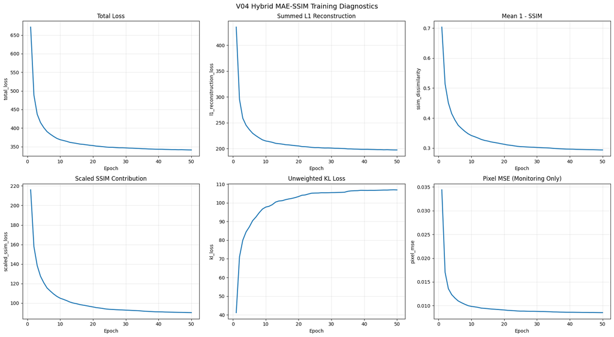

```
Training diagnostics saved to: artifacts\vae\V04\V04_training_diagnostics.png
V03 incumbent weights changed: No
Official test-set usage: None
```

```python
v04_required_history_columns = [
    "total_loss",
    "reconstruction_loss",
    "l1_reconstruction_loss",
    "ssim_dissimilarity",
    "scaled_ssim_loss",
    "kl_loss",
    "pixel_mse"
]

v04_missing_history_columns = [
    column
    for column in (
        v04_required_history_columns
    )
    if column not in (
        v04_history_df.columns
    )
]

assert not v04_missing_history_columns, (
    "Missing V04 history columns: "
    f"{v04_missing_history_columns}"
)
assert len(v04_history_df) == V04_EPOCHS
assert np.isfinite(
    v04_history_df[
        v04_required_history_columns
    ].to_numpy()
).all()
assert (
    v04_history_df[
        v04_required_history_columns
    ] >= 0.0
).all().all()

v04_expected_checkpoint_paths = [
    v04_checkpoint_dir
    / (
        "V04_epoch_"
        f"{epoch:03d}"
        ".weights.h5"
    )
    for epoch in (
        V04_MILESTONE_EPOCHS
    )
]

for required_v04_path in [
    *v04_expected_checkpoint_paths,
    v04_final_vae_weights_path,
    v04_final_encoder_weights_path,
    v04_final_decoder_weights_path,
    v04_history_path,
    v04_training_record_path
]:
    assert required_v04_path.exists(), (
        "Required V04 artefact missing: "
        f"{required_v04_path}"
    )

v04_reconstruction_identity_error = (
    np.max(
        np.abs(
            v04_history_df[
                "reconstruction_loss"
            ]
            - (
                v04_history_df[
                    "l1_reconstruction_loss"
                ]
                + v04_history_df[
                    "scaled_ssim_loss"
                ]
            )
        )
    )
)

assert (
    v04_reconstruction_identity_error
    < 1e-3
), (
    "V04 reconstruction components do "
    "not sum to the recorded "
    "reconstruction loss."
)

print(
    "V04 training-history validation "
    "passed."
)
print(
    f"Recorded epochs: "
    f"{len(v04_history_df)}"
)
print(
    "Maximum reconstruction-component "
    "identity error: "
    f"{v04_reconstruction_identity_error:.8f}"
)

print("\nFirst-epoch metrics:")
display(
    v04_history_df.loc[
        [1],
        v04_required_history_columns
    ].round(6)
)

print("\nFinal-epoch metrics:")
display(
    v04_history_df.loc[
        [V04_EPOCHS],
        v04_required_history_columns
    ].round(6)
)

print("\nLast ten epochs:")
display(
    v04_history_df[
        v04_required_history_columns
    ].tail(10).round(6)
)

fig, axes = plt.subplots(
    2,
    3,
    figsize=(18, 10)
)

v04_plot_specs = [
    (
        "total_loss",
        "Total Loss"
    ),
    (
        "l1_reconstruction_loss",
        "Summed L1 Reconstruction"
    ),
    (
        "ssim_dissimilarity",
        "Mean 1 - SSIM"
    ),
    (
        "scaled_ssim_loss",
        "Scaled SSIM Contribution"
    ),
    (
        "kl_loss",
        "Unweighted KL Loss"
    ),
    (
        "pixel_mse",
        "Pixel MSE (Monitoring Only)"
    )
]

for axis, (
    metric_name,
    metric_title
) in zip(
    axes.flat,
    v04_plot_specs
):
    axis.plot(
        v04_history_df.index,
        v04_history_df[
            metric_name
        ],
        linewidth=2
    )
    axis.set_title(metric_title)
    axis.set_xlabel("Epoch")
    axis.set_ylabel(metric_name)
    axis.grid(alpha=0.3)

fig.suptitle(
    "V04 Hybrid MAE-SSIM Training "
    "Diagnostics",
    fontsize=14
)
plt.tight_layout()

v04_training_figure_path = (
    v04_artifact_dir
    / "V04_training_diagnostics.png"
)
plt.savefig(
    v04_training_figure_path,
    dpi=150,
    bbox_inches="tight"
)
plt.show()

print(
    "Training diagnostics saved to: "
    f"{v04_training_figure_path}"
)
print(
    "V03 incumbent weights changed: No"
)
print("Official test-set usage: None")
```

### 9.4 V04 Training Interpretation

V04 completed the planned **50 epochs** in **7.77 minutes**. All recorded values were finite, all five milestone checkpoints were saved, and the reconstruction components matched the recorded reconstruction loss to within `0.00035095`.

The training trajectory was stable and directionally consistent:

| Metric | Epoch 1 | Epoch 50 | Relative reduction |
| --- | --- | --- | --- |
| Total loss | 671.4912 | 341.1261 | 49.20% |
| Summed L1 reconstruction | 434.9025 | 197.4531 | 54.60% |
| SSIM dissimilarity (`1 − SSIM`) | 0.7031 | 0.2937 | 58.22% |
| Pixel MSE | 0.03439 | 0.00853 | 75.21% |

The final ten epochs show slower but continued improvement: from epoch 41 to 50, total loss decreased by approximately **0.53%**, SSIM dissimilarity by **0.84%**, and pixel MSE by **0.91%**. KL divergence remained finite and settled near `106.9`; there is no evidence of numerical divergence or an abrupt collapsed solution in the recorded history.

These results show that V04 learned its own objective successfully. They do **not** yet show that V04 is better than V03, because V03 used binary-cross-entropy reconstruction and its loss scale is not directly comparable. V03 and V04 must therefore be evaluated on identical images, latent vectors, external metrics and decision rules.

### 9.5 V04 Checkpoint Progression

Each V04 checkpoint is evaluated on the same 20 fixed reconstruction images using their true one-hot labels. For generation, one fixed latent draw is paired with each requested CIFAR-10 class at epochs 1, 10, 25, 40 and 50. This matches V03's conditional checkpoint protocol and prevents visual cherry-picking.

The table combines V04's recorded training components with deterministic reconstruction MSE, MAE, PSNR and SSIM. The grid shows whether requested-class generations improve consistently or become unstable across training. These are development diagnostics only; the protected CIFAR-10 test set remains unused.

```
V04 fixed-input checkpoint metrics:
```

| epoch | training_total_loss | training_reconstruction_loss | training_l1_reconstruction_loss | training_ssim_dissimilarity | training_scaled_ssim_loss | unweighted_kl_loss | training_pixel_mse | reconstruction_mse | reconstruction_mae | reconstruction_psnr_db | reconstruction_ssim |
| --- | --- | --- | --- | --- | --- | --- | --- | --- | --- | --- | --- |
| 1 | 671.49115 | 650.89661 | 434.90247 | 0.70311 | 215.99411 | 41.18894 | 0.03439 | 0.01702 | 0.09876 | 18.070869 | 0.48113 |
| 10 | 368.65717 | 319.81412 | 214.81223 | 0.34180 | 105.00193 | 97.68592 | 0.00984 | 0.00789 | 0.06373 | 21.667709 | 0.70152 |
| 25 | 348.21710 | 295.61746 | 201.96521 | 0.30486 | 93.65221 | 105.19927 | 0.00884 | 0.00683 | 0.05846 | 22.304359 | 0.74451 |
| 40 | 342.97665 | 289.66614 | 198.61488 | 0.29639 | 91.05128 | 106.62119 | 0.00860 | 0.00652 | 0.05743 | 22.502859 | 0.75443 |
| 50 | 341.12607 | 287.68561 | 197.45312 | 0.29373 | 90.23234 | 106.88145 | 0.00852 | 0.00657 | 0.05792 | 22.450420 | 0.75755 |

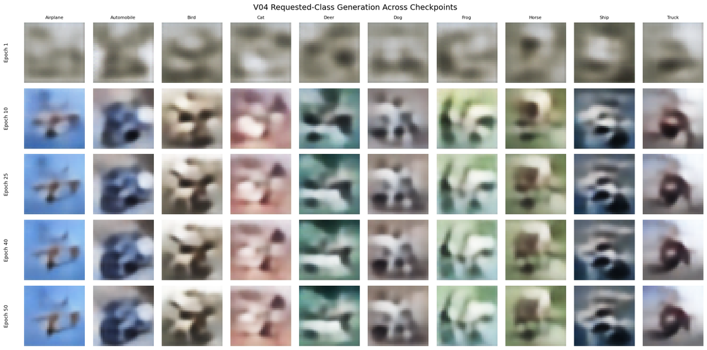

```
V04 checkpoint metrics saved to: artifacts\vae\V04\evaluation\V04_checkpoint_metrics.csv
V04 checkpoint grid saved to: artifacts\vae\V04\evaluation\V04_checkpoint_requested_class_grid.png
Final V04 weights restored: Yes
Model retrained: No
Official test-set usage: None
```

```python
# Evaluate V04 checkpoints using the established fixed inputs.
v04_artifact_dir = Path("artifacts") / "vae" / "V04"
v04_evaluation_dir = v04_artifact_dir / "evaluation"
v04_evaluation_dir.mkdir(parents=True, exist_ok=True)

fixed_inputs_dir = (
    Path("artifacts") / "vae" / "fixed_inputs"
)
fixed_latent_path_v04 = (
    fixed_inputs_dir / "fixed_latent_vectors_dim64.npy"
)
fixed_indices_path_v04 = (
    fixed_inputs_dir / "fixed_reconstruction_indices.npy"
)
fixed_label_ids_path_v04 = (
    fixed_inputs_dir
    / "V03_fixed_conditional_label_ids.npy"
)
fixed_one_hot_path_v04 = (
    fixed_inputs_dir
    / "V03_fixed_conditional_one_hot_labels.npy"
)
v04_history_path = (
    v04_artifact_dir / "V04_training_history.csv"
)
v04_final_weights_path = (
    v04_artifact_dir
    / "weights"
    / "V04_vae_final.weights.h5"
)

for required_path in [
    fixed_latent_path_v04,
    fixed_indices_path_v04,
    fixed_label_ids_path_v04,
    fixed_one_hot_path_v04,
    v04_history_path,
    v04_final_weights_path
]:
    assert required_path.exists(), (
        f"Required artefact not found: {required_path}"
    )

fixed_latent_vectors_v04 = np.load(
    fixed_latent_path_v04
).astype(np.float32)
fixed_reconstruction_indices_v04 = np.load(
    fixed_indices_path_v04
)
fixed_conditional_label_ids_v04 = np.load(
    fixed_label_ids_path_v04
)
fixed_conditional_labels_v04 = np.load(
    fixed_one_hot_path_v04
).astype(np.float32)

fixed_reconstruction_images_v04 = x_train_vae[
    fixed_reconstruction_indices_v04
]
fixed_reconstruction_labels_v04 = np.asarray(
    y_train[fixed_reconstruction_indices_v04]
).reshape(-1)
fixed_reconstruction_one_hot_v04 = (
    keras.utils.to_categorical(
        fixed_reconstruction_labels_v04,
        num_classes=V04_NUM_CLASSES
    ).astype(np.float32)
)

assert fixed_latent_vectors_v04.shape == (100, 64)
assert fixed_conditional_labels_v04.shape == (100, 10)
assert fixed_reconstruction_images_v04.shape == (
    20,
    32,
    32,
    3
)
assert fixed_reconstruction_one_hot_v04.shape == (20, 10)

# Indices 0, 10, ..., 90 provide one fixed latent
# vector for each requested class 0, 1, ..., 9.
class_preview_indices_v04 = np.arange(
    0,
    100,
    10,
    dtype=np.int64
)
assert np.array_equal(
    fixed_conditional_label_ids_v04[
        class_preview_indices_v04
    ],
    np.arange(V04_NUM_CLASSES)
)

v04_checkpoint_epochs = [1, 10, 25, 40, 50]
v04_history_for_evaluation = pd.read_csv(
    v04_history_path,
    index_col="epoch"
)
v04_checkpoint_records = []
v04_checkpoint_generated = {}

for checkpoint_epoch in v04_checkpoint_epochs:
    checkpoint_path = (
        v04_artifact_dir
        / "checkpoints"
        / (
            "V04_epoch_"
            f"{checkpoint_epoch:03d}"
            ".weights.h5"
        )
    )
    assert checkpoint_path.exists(), (
        f"V04 checkpoint not found: {checkpoint_path}"
    )
    vae_v04.load_weights(str(checkpoint_path))

    checkpoint_z_mean, _, _ = encoder_v04.predict(
        [
            fixed_reconstruction_images_v04,
            fixed_reconstruction_one_hot_v04
        ],
        verbose=0
    )
    checkpoint_reconstructions = np.clip(
        decoder_v04.predict(
            [
                checkpoint_z_mean,
                fixed_reconstruction_one_hot_v04
            ],
            verbose=0
        ),
        0.0,
        1.0
    )

    mse_per_image = np.mean(
        np.square(
            fixed_reconstruction_images_v04
            - checkpoint_reconstructions
        ),
        axis=(1, 2, 3)
    )
    mae_per_image = np.mean(
        np.abs(
            fixed_reconstruction_images_v04
            - checkpoint_reconstructions
        ),
        axis=(1, 2, 3)
    )
    psnr_per_image = tf.image.psnr(
        fixed_reconstruction_images_v04,
        checkpoint_reconstructions,
        max_val=1.0
    ).numpy()
    ssim_per_image = tf.image.ssim(
        fixed_reconstruction_images_v04,
        checkpoint_reconstructions,
        max_val=1.0
    ).numpy()

    checkpoint_generation = np.clip(
        decoder_v04.predict(
            [
                fixed_latent_vectors_v04[
                    class_preview_indices_v04
                ],
                fixed_conditional_labels_v04[
                    class_preview_indices_v04
                ]
            ],
            verbose=0
        ),
        0.0,
        1.0
    )
    v04_checkpoint_generated[checkpoint_epoch] = (
        checkpoint_generation
    )

    history_row = v04_history_for_evaluation.loc[
        checkpoint_epoch
    ]
    v04_checkpoint_records.append({
        "epoch": checkpoint_epoch,
        "training_total_loss": history_row[
            "total_loss"
        ],
        "training_reconstruction_loss": history_row[
            "reconstruction_loss"
        ],
        "training_l1_reconstruction_loss": history_row[
            "l1_reconstruction_loss"
        ],
        "training_ssim_dissimilarity": history_row[
            "ssim_dissimilarity"
        ],
        "training_scaled_ssim_loss": history_row[
            "scaled_ssim_loss"
        ],
        "unweighted_kl_loss": history_row[
            "kl_loss"
        ],
        "training_pixel_mse": history_row[
            "pixel_mse"
        ],
        "reconstruction_mse": mse_per_image.mean(),
        "reconstruction_mae": mae_per_image.mean(),
        "reconstruction_psnr_db": psnr_per_image.mean(),
        "reconstruction_ssim": ssim_per_image.mean()
    })

# Restore the saved final V04 state after inspecting
# intermediate checkpoints.
vae_v04.load_weights(str(v04_final_weights_path))

v04_checkpoint_metrics_df = pd.DataFrame(
    v04_checkpoint_records
).set_index("epoch")
assert np.isfinite(
    v04_checkpoint_metrics_df.to_numpy()
).all()

v04_checkpoint_metrics_path = (
    v04_evaluation_dir / "V04_checkpoint_metrics.csv"
)
v04_checkpoint_metrics_df.to_csv(
    v04_checkpoint_metrics_path
)

print("V04 fixed-input checkpoint metrics:")
display(v04_checkpoint_metrics_df.round(5))

fig, axes = plt.subplots(
    len(v04_checkpoint_epochs),
    V04_NUM_CLASSES,
    figsize=(18, 9)
)
for row_index, checkpoint_epoch in enumerate(
    v04_checkpoint_epochs
):
    for class_id, class_name in enumerate(class_names):
        axes[row_index, class_id].imshow(
            v04_checkpoint_generated[
                checkpoint_epoch
            ][class_id]
        )
        axes[row_index, class_id].axis("off")
        if row_index == 0:
            axes[row_index, class_id].set_title(
                class_name,
                fontsize=8
            )
    axes[row_index, 0].text(
        -0.25,
        0.5,
        f"Epoch {checkpoint_epoch}",
        transform=axes[row_index, 0].transAxes,
        rotation=90,
        va="center",
        ha="right",
        fontsize=9
    )

fig.suptitle(
    "V04 Requested-Class Generation Across Checkpoints",
    fontsize=14
)
plt.tight_layout()
v04_checkpoint_grid_path = (
    v04_evaluation_dir
    / "V04_checkpoint_requested_class_grid.png"
)
plt.savefig(
    v04_checkpoint_grid_path,
    dpi=150,
    bbox_inches="tight"
)
plt.show()

print(
    "V04 checkpoint metrics saved to: "
    f"{v04_checkpoint_metrics_path}"
)
print(
    "V04 checkpoint grid saved to: "
    f"{v04_checkpoint_grid_path}"
)
print("Final V04 weights restored: Yes")
print("Model retrained: No")
print("Official test-set usage: None")
```

#### Executed Checkpoint Findings

The checkpoint results show rapid learning followed by a stable plateau. From epoch 1 to epoch 40, deterministic reconstruction MSE fell from `0.01702` to `0.00652`, MAE fell from `0.09876` to `0.05743`, PSNR rose from `18.071` to `22.503` dB, and SSIM rose from `0.48113` to `0.75443`.

Epoch 50 retained essentially the same reconstruction level: MSE was `0.00657`, MAE was `0.05792`, PSNR was `22.450` dB, and SSIM improved slightly further to `0.75755`. The small epoch-40-to-50 movement is a plateau, not numerical instability. Epoch 50 remains the locked comparison checkpoint because every experiment uses the same 50-epoch budget and V04 FID was evaluated from those saved final weights.

The fixed requested-class grid shows the largest visual change between epochs 1 and 10. Later checkpoints preserve the same broad layouts while adding smaller colour and structural refinements. The samples remain recognisably CIFAR-like but some object identities are ambiguous, so the grid is supporting evidence rather than a human recognisability score.

### 9.6 Final Controlled Comparison - V03 versus V04

V03 is the immediate parent reference. The following comparison loads the saved final V03 and V04 weights and does not retrain either model.

The two models are compared using:

1. the same 20 fixed training reconstructions and true one-hot labels;
2. the same 100 fixed standard-normal latent vectors and balanced requested labels;
3. MSE, MAE, PSNR and SSIM for reconstruction;
4. the original notebook's brightness, contrast, colour, saturation and edge-strength descriptors;
5. exact uniqueness, overall pixel diversity and within-class diversity;
6. same-`z`, different-label intervention and counterfactual reconstruction checks;
7. matched latent-posterior diagnostics; and
8. visual grids saved without curation.

SSIM and MSE are evaluation metrics here. They are not used to change V04 after training. A positive descriptor-gap improvement means V04 is closer to the stratified training reference than V03. No single metric automatically determines the experiment decision.

```python
from hashlib import sha256


V04_EVALUATION_NUM_CLASSES = 10
V04_EVALUATION_SAMPLE_COUNT = 100

v04_evaluation_dir = (
    Path("artifacts")
    / "vae"
    / "V04"
    / "evaluation"
)
v04_evaluation_dir.mkdir(
    parents=True,
    exist_ok=True
)

v03_encoder_weights_for_v04_comparison = (
    Path("artifacts")
    / "vae"
    / "V03"
    / "weights"
    / "V03_encoder_final.weights.h5"
)
v03_decoder_weights_for_v04_comparison = (
    Path("artifacts")
    / "vae"
    / "V03"
    / "weights"
    / "V03_decoder_final.weights.h5"
)
v04_encoder_weights_for_comparison = (
    Path("artifacts")
    / "vae"
    / "V04"
    / "weights"
    / "V04_encoder_final.weights.h5"
)
v04_decoder_weights_for_comparison = (
    Path("artifacts")
    / "vae"
    / "V04"
    / "weights"
    / "V04_decoder_final.weights.h5"
)

fixed_inputs_dir_v04 = (
    Path("artifacts")
    / "vae"
    / "fixed_inputs"
)
fixed_reconstruction_indices_path_v04 = (
    fixed_inputs_dir_v04
    / "fixed_reconstruction_indices.npy"
)
fixed_latent_vectors_path_v04 = (
    fixed_inputs_dir_v04
    / "fixed_latent_vectors_dim64.npy"
)
fixed_label_ids_path_v04 = (
    fixed_inputs_dir_v04
    / "V03_fixed_conditional_label_ids.npy"
)
fixed_one_hot_labels_path_v04 = (
    fixed_inputs_dir_v04
    / "V03_fixed_conditional_one_hot_labels.npy"
)

v04_required_comparison_paths = [
    v03_encoder_weights_for_v04_comparison,
    v03_decoder_weights_for_v04_comparison,
    v04_encoder_weights_for_comparison,
    v04_decoder_weights_for_comparison,
    fixed_reconstruction_indices_path_v04,
    fixed_latent_vectors_path_v04,
    fixed_label_ids_path_v04,
    fixed_one_hot_labels_path_v04
]

for required_path in (
    v04_required_comparison_paths
):
    assert required_path.exists(), (
        "Required matched-evaluation "
        f"artefact missing: {required_path}"
    )


def v04_file_sha256(file_path):
    digest = sha256()
    with Path(file_path).open("rb") as file:
        for block in iter(
            lambda: file.read(1024 * 1024),
            b""
        ):
            digest.update(block)
    return digest.hexdigest()


v03_weight_hashes_before_v04_evaluation = {
    "encoder": v04_file_sha256(
        v03_encoder_weights_for_v04_comparison
    ),
    "decoder": v04_file_sha256(
        v03_decoder_weights_for_v04_comparison
    )
}

# Rebuild the frozen V03 architecture locally.
# This avoids depending on an earlier in-memory
# encoder_v03 or decoder_v03 object. No training occurs.
class V03EvaluationSampling(layers.Layer):
    def call(self, inputs):
        z_mean, z_log_var = inputs
        batch_size = tf.shape(z_mean)[0]
        latent_dimension = tf.shape(
            z_mean
        )[1]
        epsilon = tf.random.normal(
            shape=(
                batch_size,
                latent_dimension
            )
        )
        return (
            z_mean
            + tf.exp(
                0.5 * z_log_var
            )
            * epsilon
        )


v03_evaluation_image_input = keras.Input(
    shape=(32, 32, 3),
    name="V03_eval_encoder_image_input"
)
v03_evaluation_encoder_label_input = (
    keras.Input(
        shape=(10,),
        name="V03_eval_encoder_label_input"
    )
)

v03_evaluation_x = layers.Conv2D(
    32,
    kernel_size=3,
    strides=2,
    padding="same",
    activation="relu",
    name="V03_eval_encoder_conv_1"
)(v03_evaluation_image_input)
v03_evaluation_x = layers.Conv2D(
    64,
    kernel_size=3,
    strides=2,
    padding="same",
    activation="relu",
    name="V03_eval_encoder_conv_2"
)(v03_evaluation_x)
v03_evaluation_x = layers.Conv2D(
    128,
    kernel_size=3,
    strides=2,
    padding="same",
    activation="relu",
    name="V03_eval_encoder_conv_3"
)(v03_evaluation_x)
v03_evaluation_x = layers.Flatten(
    name="V03_eval_encoder_flatten"
)(v03_evaluation_x)
v03_evaluation_x = layers.Concatenate(
    name=(
        "V03_eval_encoder_feature_"
        "label_concat"
    )
)([
    v03_evaluation_x,
    v03_evaluation_encoder_label_input
])
v03_evaluation_x = layers.Dense(
    256,
    activation="relu",
    name="V03_eval_encoder_dense"
)(v03_evaluation_x)

v03_evaluation_z_mean = layers.Dense(
    64,
    name="V03_eval_z_mean"
)(v03_evaluation_x)
v03_evaluation_z_log_var = layers.Dense(
    64,
    name="V03_eval_z_log_var"
)(v03_evaluation_x)
v03_evaluation_z = V03EvaluationSampling(
    name="V03_eval_z_sampling"
)([
    v03_evaluation_z_mean,
    v03_evaluation_z_log_var
])

encoder_v03 = keras.Model(
    inputs=[
        v03_evaluation_image_input,
        v03_evaluation_encoder_label_input
    ],
    outputs=[
        v03_evaluation_z_mean,
        v03_evaluation_z_log_var,
        v03_evaluation_z
    ],
    name="V03_evaluation_encoder"
)

v03_evaluation_latent_input = keras.Input(
    shape=(64,),
    name="V03_eval_decoder_latent_input"
)
v03_evaluation_decoder_label_input = (
    keras.Input(
        shape=(10,),
        name="V03_eval_decoder_label_input"
    )
)

v03_evaluation_y = layers.Concatenate(
    name=(
        "V03_eval_decoder_latent_"
        "label_concat"
    )
)([
    v03_evaluation_latent_input,
    v03_evaluation_decoder_label_input
])
v03_evaluation_y = layers.Dense(
    4 * 4 * 128,
    activation="relu",
    name="V03_eval_decoder_dense"
)(v03_evaluation_y)
v03_evaluation_y = layers.Reshape(
    (4, 4, 128),
    name="V03_eval_decoder_reshape"
)(v03_evaluation_y)
v03_evaluation_y = layers.Conv2DTranspose(
    128,
    kernel_size=3,
    strides=2,
    padding="same",
    activation="relu",
    name="V03_eval_decoder_deconv_1"
)(v03_evaluation_y)
v03_evaluation_y = layers.Conv2DTranspose(
    64,
    kernel_size=3,
    strides=2,
    padding="same",
    activation="relu",
    name="V03_eval_decoder_deconv_2"
)(v03_evaluation_y)
v03_evaluation_y = layers.Conv2DTranspose(
    32,
    kernel_size=3,
    strides=2,
    padding="same",
    activation="relu",
    name="V03_eval_decoder_deconv_3"
)(v03_evaluation_y)
v03_evaluation_decoder_output = (
    layers.Conv2D(
        3,
        kernel_size=3,
        padding="same",
        activation="sigmoid",
        name="V03_eval_decoder_output"
    )(v03_evaluation_y)
)
```

```python
decoder_v03 = keras.Model(
    inputs=[
        v03_evaluation_latent_input,
        v03_evaluation_decoder_label_input
    ],
    outputs=(
        v03_evaluation_decoder_output
    ),
    name="V03_evaluation_decoder"
)

assert (
    encoder_v03.count_params()
    == 653_248
)
assert (
    decoder_v03.count_params()
    == 394_307
)

# Load final frozen weights only; no fit call occurs.
encoder_v03.load_weights(
    str(
        v03_encoder_weights_for_v04_comparison
    )
)
decoder_v03.load_weights(
    str(
        v03_decoder_weights_for_v04_comparison
    )
)
encoder_v04.load_weights(
    str(
        v04_encoder_weights_for_comparison
    )
)
decoder_v04.load_weights(
    str(
        v04_decoder_weights_for_comparison
    )
)

v04_fixed_reconstruction_indices = np.load(
    fixed_reconstruction_indices_path_v04
)
v04_fixed_reconstruction_images = (
    x_train_vae[
        v04_fixed_reconstruction_indices
    ]
)
v04_fixed_reconstruction_label_ids = (
    y_train[
        v04_fixed_reconstruction_indices
    ]
)
v04_fixed_reconstruction_one_hot = (
    keras.utils.to_categorical(
        v04_fixed_reconstruction_label_ids,
        num_classes=(
            V04_EVALUATION_NUM_CLASSES
        )
    ).astype(np.float32)
)

v04_fixed_latent_vectors = np.load(
    fixed_latent_vectors_path_v04
).astype(np.float32)
v04_fixed_requested_label_ids = np.load(
    fixed_label_ids_path_v04
).astype(np.int64)
v04_fixed_requested_one_hot = np.load(
    fixed_one_hot_labels_path_v04
).astype(np.float32)

assert (
    v04_fixed_reconstruction_images.shape
    == (20, 32, 32, 3)
)
assert (
    v04_fixed_reconstruction_one_hot.shape
    == (20, 10)
)
assert (
    v04_fixed_latent_vectors.shape
    == (100, 64)
)
assert (
    v04_fixed_requested_one_hot.shape
    == (100, 10)
)
assert np.array_equal(
    np.bincount(
        v04_fixed_requested_label_ids,
        minlength=10
    ),
    np.full(10, 10)
)

# -------------------------------------------------------
# 1. Deterministic reconstruction comparison
# -------------------------------------------------------
v03_z_mean_for_v04_comparison, _, _ = (
    encoder_v03.predict(
        [
            v04_fixed_reconstruction_images,
            v04_fixed_reconstruction_one_hot
        ],
        verbose=0
    )
)
v04_z_mean_for_comparison, _, _ = (
    encoder_v04.predict(
        [
            v04_fixed_reconstruction_images,
            v04_fixed_reconstruction_one_hot
        ],
        verbose=0
    )
)

v03_reconstructions_for_v04_comparison = (
    np.clip(
        decoder_v03.predict(
            [
                v03_z_mean_for_v04_comparison,
                v04_fixed_reconstruction_one_hot
            ],
            verbose=0
        ),
        0.0,
        1.0
    )
)
v04_reconstructions_for_comparison = (
    np.clip(
        decoder_v04.predict(
            [
                v04_z_mean_for_comparison,
                v04_fixed_reconstruction_one_hot
            ],
            verbose=0
        ),
        0.0,
        1.0
    )
)


def v04_edge_strength_per_image(
    image_batch
):
    horizontal_difference = np.abs(
        np.diff(
            image_batch,
            axis=2
        )
    ).mean(axis=(1, 2, 3))
    vertical_difference = np.abs(
        np.diff(
            image_batch,
            axis=1
        )
    ).mean(axis=(1, 2, 3))
    return (
        horizontal_difference
        + vertical_difference
    ) / 2.0


def v04_reconstruction_metric_arrays(
    originals,
    reconstructions
):
    mse_values = np.mean(
        np.square(
            originals - reconstructions
        ),
        axis=(1, 2, 3)
    )
    mae_values = np.mean(
        np.abs(
            originals - reconstructions
        ),
        axis=(1, 2, 3)
    )
    psnr_values = tf.image.psnr(
        originals,
        reconstructions,
        max_val=1.0
    ).numpy()
    ssim_values = tf.image.ssim(
        originals,
        reconstructions,
        max_val=1.0
    ).numpy()

    original_edges = (
        v04_edge_strength_per_image(
            originals
        )
    )
    reconstructed_edges = (
        v04_edge_strength_per_image(
            reconstructions
        )
    )
    edge_gap_values = np.abs(
        original_edges
        - reconstructed_edges
    )

    return {
        "mse": mse_values,
        "mae": mae_values,
        "psnr_db": psnr_values,
        "ssim": ssim_values,
        "edge_strength": (
            reconstructed_edges
        ),
        "absolute_edge_gap": (
            edge_gap_values
        )
    }


v03_reconstruction_metrics_for_v04 = (
    v04_reconstruction_metric_arrays(
        v04_fixed_reconstruction_images,
        (
            v03_reconstructions_for_v04_comparison
        )
    )
)
v04_reconstruction_metrics = (
    v04_reconstruction_metric_arrays(
        v04_fixed_reconstruction_images,
        v04_reconstructions_for_comparison
    )
)

v03_v04_reconstruction_rows = []
for (
    metric_name,
    direction
) in [
    ("mse", "lower_is_better"),
    ("mae", "lower_is_better"),
    ("psnr_db", "higher_is_better"),
    ("ssim", "higher_is_better"),
    (
        "edge_strength",
        "descriptive_only"
    ),
    (
        "absolute_edge_gap",
        "lower_is_better"
    )
]:
    v03_value = float(
        np.mean(
            v03_reconstruction_metrics_for_v04[
                metric_name
            ]
        )
    )
    v04_value = float(
        np.mean(
            v04_reconstruction_metrics[
                metric_name
            ]
        )
    )
    v03_v04_reconstruction_rows.append({
        "metric": metric_name,
        "direction": direction,
        "V03": v03_value,
        "V04": v04_value,
        "V04_minus_V03": (
            v04_value - v03_value
        )
    })

v03_v04_reconstruction_df = (
    pd.DataFrame(
        v03_v04_reconstruction_rows
    ).set_index("metric")
)

print(
    "Matched V03-versus-V04 fixed "
    "reconstruction metrics:"
)
display(
    v03_v04_reconstruction_df.round(6)
)
```

```python
v03_v04_per_class_rows = []
for class_id, class_name in enumerate(
    class_names
):
    class_mask = (
        v04_fixed_reconstruction_label_ids
        == class_id
    )
    v03_v04_per_class_rows.append({
        "class_name": class_name,
        "V03_mse": float(
            v03_reconstruction_metrics_for_v04[
                "mse"
            ][class_mask].mean()
        ),
        "V04_mse": float(
            v04_reconstruction_metrics[
                "mse"
            ][class_mask].mean()
        ),
        "V03_ssim": float(
            v03_reconstruction_metrics_for_v04[
                "ssim"
            ][class_mask].mean()
        ),
        "V04_ssim": float(
            v04_reconstruction_metrics[
                "ssim"
            ][class_mask].mean()
        ),
        "V03_absolute_edge_gap": float(
            v03_reconstruction_metrics_for_v04[
                "absolute_edge_gap"
            ][class_mask].mean()
        ),
        "V04_absolute_edge_gap": float(
            v04_reconstruction_metrics[
                "absolute_edge_gap"
            ][class_mask].mean()
        )
    })

v03_v04_per_class_reconstruction_df = (
    pd.DataFrame(
        v03_v04_per_class_rows
    ).set_index("class_name")
)

print(
    "\nPer-class fixed reconstruction "
    "metrics:"
)
display(
    v03_v04_per_class_reconstruction_df
    .round(6)
)

v03_v04_reconstruction_path = (
    v04_evaluation_dir
    / "V03_V04_reconstruction_metrics.csv"
)
v03_v04_per_class_reconstruction_path = (
    v04_evaluation_dir
    / (
        "V03_V04_per_class_"
        "reconstruction_metrics.csv"
    )
)
v03_v04_reconstruction_df.to_csv(
    v03_v04_reconstruction_path
)
v03_v04_per_class_reconstruction_df.to_csv(
    v03_v04_per_class_reconstruction_path
)

fig, axes = plt.subplots(
    6,
    10,
    figsize=(18, 11)
)
v03_v04_reconstruction_row_labels = [
    "Original 1",
    "V03 1",
    "V04 1",
    "Original 2",
    "V03 2",
    "V04 2"
]

for class_id, class_name in enumerate(
    class_names
):
    first_position = class_id * 2
    second_position = first_position + 1
    image_sequence = [
        v04_fixed_reconstruction_images[
            first_position
        ],
        v03_reconstructions_for_v04_comparison[
            first_position
        ],
        v04_reconstructions_for_comparison[
            first_position
        ],
        v04_fixed_reconstruction_images[
            second_position
        ],
        v03_reconstructions_for_v04_comparison[
            second_position
        ],
        v04_reconstructions_for_comparison[
            second_position
        ]
    ]

    for row_index, image_value in enumerate(
        image_sequence
    ):
        axis = axes[row_index, class_id]
        axis.imshow(image_value)
        axis.axis("off")

        if class_id == 0:
            axis.text(
                -0.2,
                0.5,
                (
                    v03_v04_reconstruction_row_labels[
                        row_index
                    ]
                ),
                transform=axis.transAxes,
                rotation=90,
                va="center",
                ha="right",
                fontsize=9
            )

    axes[0, class_id].set_title(
        class_name,
        fontsize=9
    )

fig.suptitle(
    "Matched Fixed Reconstructions: "
    "V03 versus V04",
    fontsize=14
)
plt.tight_layout()

v03_v04_reconstruction_grid_path = (
    v04_evaluation_dir
    / "V03_V04_reconstruction_grid.png"
)
plt.savefig(
    v03_v04_reconstruction_grid_path,
    dpi=150,
    bbox_inches="tight"
)
plt.show()

# -------------------------------------------------------
# 2. Same-latent balanced generation
# -------------------------------------------------------
v03_generated_for_v04_comparison = (
    np.clip(
        decoder_v03.predict(
            [
                v04_fixed_latent_vectors,
                v04_fixed_requested_one_hot
            ],
            verbose=0
        ),
        0.0,
        1.0
    )
)
v04_generated_for_comparison = (
    np.clip(
        decoder_v04.predict(
            [
                v04_fixed_latent_vectors,
                v04_fixed_requested_one_hot
            ],
            verbose=0
        ),
        0.0,
        1.0
    )
)

v03_generated_uint8_for_v04 = np.rint(
    v03_generated_for_v04_comparison
    * 255.0
).astype(np.uint8)
v04_generated_uint8 = np.rint(
    v04_generated_for_comparison
    * 255.0
).astype(np.uint8)

v04_fixed_generated_samples_path = (
    v04_evaluation_dir
    / "V04_fixed_requested_samples.npy"
)
np.save(
    v04_fixed_generated_samples_path,
    v04_generated_uint8
)

fig, axes = plt.subplots(
    10,
    20,
    figsize=(28, 14)
)

for class_id, class_name in enumerate(
    class_names
):
    class_start = class_id * 10

    for draw_index in range(10):
        v03_axis = axes[
            class_id,
            draw_index
        ]
        v04_axis = axes[
            class_id,
            10 + draw_index
        ]

        v03_axis.imshow(
            v03_generated_for_v04_comparison[
                class_start + draw_index
            ]
        )
        v04_axis.imshow(
            v04_generated_for_comparison[
                class_start + draw_index
            ]
        )
        v03_axis.axis("off")
        v04_axis.axis("off")

        if class_id == 0:
            v03_axis.set_title(
                f"V03 d{draw_index + 1}",
                fontsize=8
            )
            v04_axis.set_title(
                f"V04 d{draw_index + 1}",
                fontsize=8
            )

        if draw_index == 0:
            v03_axis.text(
                -0.25,
                0.5,
                class_name,
                transform=v03_axis.transAxes,
                rotation=90,
                va="center",
                ha="right",
                fontsize=9
            )

fig.suptitle(
    "Same Latents and Requested Labels: "
    "V03 versus V04",
    fontsize=14
)
plt.tight_layout()
```

```python
v03_v04_generation_grid_path = (
    v04_evaluation_dir
    / "V03_V04_same_latent_generation_grid.png"
)
plt.savefig(
    v03_v04_generation_grid_path,
    dpi=150,
    bbox_inches="tight"
)
plt.show()

# -------------------------------------------------------
# 3. Shared descriptors and diversity
# -------------------------------------------------------
v04_descriptor_rng = np.random.default_rng(
    SEED + 100
)
v04_reference_indices = []

for class_id in range(
    V04_EVALUATION_NUM_CLASSES
):
    class_indices = np.where(
        y_train == class_id
    )[0]
    v04_reference_indices.extend(
        v04_descriptor_rng.choice(
            class_indices,
            size=100,
            replace=False
        )
    )

v04_reference_indices = np.array(
    v04_reference_indices
)
v04_reference_images = x_train_vae[
    v04_reference_indices
]
v04_reference_labels = y_train[
    v04_reference_indices
]


def v04_comparison_descriptors(
    image_batch
):
    horizontal_difference = np.abs(
        np.diff(
            image_batch,
            axis=2
        )
    ).mean(axis=(1, 2, 3))
    vertical_difference = np.abs(
        np.diff(
            image_batch,
            axis=1
        )
    ).mean(axis=(1, 2, 3))

    return pd.DataFrame({
        "brightness": image_batch.mean(
            axis=(1, 2, 3)
        ),
        "contrast": image_batch.std(
            axis=(1, 2, 3)
        ),
        "red_mean": image_batch[
            :, :, :, 0
        ].mean(axis=(1, 2)),
        "green_mean": image_batch[
            :, :, :, 1
        ].mean(axis=(1, 2)),
        "blue_mean": image_batch[
            :, :, :, 2
        ].mean(axis=(1, 2)),
        "saturation": (
            image_batch.max(axis=3)
            - image_batch.min(axis=3)
        ).mean(axis=(1, 2)),
        "edge_strength": (
            horizontal_difference
            + vertical_difference
        ) / 2.0
    })


v04_reference_descriptors = (
    v04_comparison_descriptors(
        v04_reference_images
    )
)
v03_descriptors_for_v04 = (
    v04_comparison_descriptors(
        v03_generated_for_v04_comparison
    )
)
v04_descriptors = (
    v04_comparison_descriptors(
        v04_generated_for_comparison
    )
)

v03_v04_descriptor_rows = []
for descriptor_name in (
    v04_reference_descriptors.columns
):
    training_mean = float(
        v04_reference_descriptors[
            descriptor_name
        ].mean()
    )
    v03_mean = float(
        v03_descriptors_for_v04[
            descriptor_name
        ].mean()
    )
    v04_mean = float(
        v04_descriptors[
            descriptor_name
        ].mean()
    )
    v03_gap = abs(
        v03_mean - training_mean
    )
    v04_gap = abs(
        v04_mean - training_mean
    )

    v03_v04_descriptor_rows.append({
        "descriptor": descriptor_name,
        "training_mean": training_mean,
        "V03_mean": v03_mean,
        "V04_mean": v04_mean,
        "V03_absolute_gap": v03_gap,
        "V04_absolute_gap": v04_gap,
        "gap_improvement_V04_vs_V03": (
            v03_gap - v04_gap
        )
    })

v03_v04_descriptor_df = (
    pd.DataFrame(
        v03_v04_descriptor_rows
    ).set_index("descriptor")
)

print(
    "\nMatched generated-image "
    "descriptor comparison:"
)
display(
    v03_v04_descriptor_df.round(6)
)

v03_v04_descriptor_path = (
    v04_evaluation_dir
    / "V03_V04_descriptor_comparison.csv"
)
v03_v04_descriptor_df.to_csv(
    v03_v04_descriptor_path
)


def v04_per_class_diversity_record(
    generated_float,
    generated_uint8,
    label_ids
):
    unique_counts = []
    pixel_diversities = []

    for class_id in range(
        V04_EVALUATION_NUM_CLASSES
    ):
        class_mask = (
            label_ids == class_id
        )
        class_float = generated_float[
            class_mask
        ]
        class_uint8 = generated_uint8[
            class_mask
        ]
        unique_counts.append(
            len(
                np.unique(
                    class_uint8.reshape(
                        len(class_uint8),
                        -1
                    ),
                    axis=0
                )
            )
        )
        pixel_diversities.append(
            np.mean(
                np.std(
                    class_float,
                    axis=0
                )
            )
        )

    return (
        np.array(unique_counts),
        np.array(pixel_diversities)
    )


(
    v03_unique_per_class_for_v04,
    v03_pixel_diversity_per_class_for_v04
) = v04_per_class_diversity_record(
    v03_generated_for_v04_comparison,
    v03_generated_uint8_for_v04,
    v04_fixed_requested_label_ids
)
(
    v04_unique_per_class,
    v04_pixel_diversity_per_class
) = v04_per_class_diversity_record(
    v04_generated_for_comparison,
    v04_generated_uint8,
    v04_fixed_requested_label_ids
)

v03_v04_diversity_df = pd.DataFrame(
    {
        "V03": [
            len(
                np.unique(
                    v03_generated_uint8_for_v04
                    .reshape(100, -1),
                    axis=0
                )
            ),
            np.mean(
                np.std(
                    v03_generated_for_v04_comparison,
                    axis=0
                )
            ),
            int(
                v03_unique_per_class_for_v04.min()
            ),
            float(
                v03_pixel_diversity_per_class_for_v04
                .mean()
            )
        ],
        "V04": [
            len(
                np.unique(
                    v04_generated_uint8.reshape(
                        100,
                        -1
                    ),
                    axis=0
                )
            ),
            np.mean(
                np.std(
                    v04_generated_for_comparison,
                    axis=0
                )
            ),
            int(
                v04_unique_per_class.min()
            ),
            float(
                v04_pixel_diversity_per_class.mean()
            )
        ],
        "Training_reference": [
            np.nan,
            np.mean(
                np.std(
                    v04_reference_images,
                    axis=0
                )
            ),
            np.nan,
            np.nan
        ]
    },
    index=[
        "unique_uint8_images_out_of_100",
        "mean_pixel_standard_deviation",
        "minimum_unique_images_per_class_out_of_10",
        "mean_within_class_pixel_standard_deviation"
    ]
)
```

```python
print(
    "\nMatched generated diversity "
    "comparison:"
)
display(
    v03_v04_diversity_df.round(6)
)

v03_v04_diversity_path = (
    v04_evaluation_dir
    / "V03_V04_diversity_comparison.csv"
)
v03_v04_diversity_df.to_csv(
    v03_v04_diversity_path
)

# -------------------------------------------------------
# 4. Same-z label control and counterfactual check
# -------------------------------------------------------
def v04_conditional_control_evaluation(
    decoder_model,
    posterior_means,
    originals,
    true_label_ids,
    shared_latents,
    num_classes
):
    latent_count = len(shared_latents)
    intervention_latents = np.tile(
        shared_latents,
        (num_classes, 1)
    )
    intervention_label_ids = np.repeat(
        np.arange(num_classes),
        latent_count
    )
    intervention_one_hot = (
        keras.utils.to_categorical(
            intervention_label_ids,
            num_classes=num_classes
        ).astype(np.float32)
    )

    intervention_images = np.clip(
        decoder_model.predict(
            [
                intervention_latents,
                intervention_one_hot
            ],
            verbose=0
        ),
        0.0,
        1.0
    ).reshape(
        num_classes,
        latent_count,
        32,
        32,
        3
    )

    class_centroids = (
        intervention_images.mean(axis=1)
    )
    global_centroid = (
        class_centroids.mean(axis=0)
    )
    within_class_variance = np.mean(
        np.square(
            intervention_images
            - class_centroids[:, None]
        )
    )
    between_class_variance = np.mean(
        np.square(
            class_centroids
            - global_centroid
        )
    )
    separation_ratio = (
        between_class_variance
        / within_class_variance
    )

    pairwise_label_mae = []
    for latent_index in range(
        latent_count
    ):
        for first_class in range(
            num_classes
        ):
            for second_class in range(
                first_class + 1,
                num_classes
            ):
                pairwise_label_mae.append(
                    np.mean(
                        np.abs(
                            intervention_images[
                                first_class,
                                latent_index
                            ]
                            - intervention_images[
                                second_class,
                                latent_index
                            ]
                        )
                    )
                )

    counterfactual_mse = np.empty(
        (
            len(originals),
            num_classes
        ),
        dtype=np.float32
    )

    for candidate_class in range(
        num_classes
    ):
        candidate_one_hot = (
            keras.utils.to_categorical(
                np.full(
                    len(originals),
                    candidate_class
                ),
                num_classes=num_classes
            ).astype(np.float32)
        )
        candidate_reconstructions = (
            np.clip(
                decoder_model.predict(
                    [
                        posterior_means,
                        candidate_one_hot
                    ],
                    verbose=0
                ),
                0.0,
                1.0
            )
        )
        counterfactual_mse[
            :,
            candidate_class
        ] = np.mean(
            np.square(
                originals
                - candidate_reconstructions
            ),
            axis=(1, 2, 3)
        )

    true_label_mse = counterfactual_mse[
        np.arange(len(originals)),
        true_label_ids
    ]
    wrong_label_mask = np.ones_like(
        counterfactual_mse,
        dtype=bool
    )
    wrong_label_mask[
        np.arange(len(originals)),
        true_label_ids
    ] = False
    mean_wrong_label_mse = (
        counterfactual_mse[
            wrong_label_mask
        ].reshape(
            len(originals),
            num_classes - 1
        ).mean(axis=1)
    )

    metrics = {
        (
            "mean_pairwise_mae_between_"
            "labels_same_z"
        ): float(
            np.mean(pairwise_label_mae)
        ),
        (
            "within_requested_class_"
            "pixel_variance"
        ): float(within_class_variance),
        (
            "between_requested_class_"
            "centroid_variance"
        ): float(between_class_variance),
        (
            "between_to_within_"
            "variance_ratio"
        ): float(separation_ratio),
        (
            "mean_true_label_"
            "reconstruction_mse"
        ): float(true_label_mse.mean()),
        (
            "mean_wrong_label_"
            "reconstruction_mse"
        ): float(mean_wrong_label_mse.mean()),
        (
            "fraction_true_mse_below_"
            "mean_wrong_mse"
        ): float(
            np.mean(
                true_label_mse
                < mean_wrong_label_mse
            )
        ),
        (
            "fraction_true_label_"
            "lowest_mse_of_10"
        ): float(
            np.mean(
                np.argmin(
                    counterfactual_mse,
                    axis=1
                )
                == true_label_ids
            )
        )
    }

    return metrics, intervention_images


v04_shared_control_latents = (
    v04_fixed_latent_vectors[:10]
)

(
    v03_control_metrics_for_v04,
    v03_control_images_for_v04
) = v04_conditional_control_evaluation(
    decoder_model=decoder_v03,
    posterior_means=(
        v03_z_mean_for_v04_comparison
    ),
    originals=(
        v04_fixed_reconstruction_images
    ),
    true_label_ids=(
        v04_fixed_reconstruction_label_ids
    ),
    shared_latents=(
        v04_shared_control_latents
    ),
    num_classes=(
        V04_EVALUATION_NUM_CLASSES
    )
)

(
    v04_control_metrics,
    v04_control_images
) = v04_conditional_control_evaluation(
    decoder_model=decoder_v04,
    posterior_means=(
        v04_z_mean_for_comparison
    ),
    originals=(
        v04_fixed_reconstruction_images
    ),
    true_label_ids=(
        v04_fixed_reconstruction_label_ids
    ),
    shared_latents=(
        v04_shared_control_latents
    ),
    num_classes=(
        V04_EVALUATION_NUM_CLASSES
    )
)
```

```
Matched V03-versus-V04 fixed reconstruction metrics:
```

| metric | direction | V03 | V04 | V04_minus_V03 |
| --- | --- | --- | --- | --- |
| mse | lower_is_better | 0.007696 | 0.006570 | -0.001126 |
| mae | lower_is_better | 0.063906 | 0.057916 | -0.005990 |
| psnr_db | higher_is_better | 21.675642 | 22.450420 | 0.774778 |
| ssim | higher_is_better | 0.606503 | 0.757548 | 0.151045 |
| edge_strength | descriptive_only | 0.025080 | 0.032852 | 0.007772 |
| absolute_edge_gap | lower_is_better | 0.031271 | 0.023499 | -0.007772 |

```
Per-class fixed reconstruction metrics:
```

| class_name | V03_mse | V04_mse | V03_ssim | V04_ssim | V03_absolute_edge_gap | V04_absolute_edge_gap |
| --- | --- | --- | --- | --- | --- | --- |
| Airplane | 0.009616 | 0.007914 | 0.635489 | 0.778953 | 0.026652 | 0.019704 |
| Automobile | 0.008088 | 0.006975 | 0.614120 | 0.758948 | 0.031592 | 0.024678 |
| Bird | 0.006218 | 0.005435 | 0.708796 | 0.818492 | 0.021574 | 0.015982 |
| Cat | 0.008295 | 0.007112 | 0.627270 | 0.794829 | 0.034754 | 0.026081 |
| Deer | 0.010073 | 0.007756 | 0.489229 | 0.700802 | 0.041204 | 0.029449 |
| Dog | 0.007389 | 0.007120 | 0.613014 | 0.738844 | 0.035620 | 0.028972 |
| Frog | 0.008302 | 0.007378 | 0.505439 | 0.667871 | 0.047058 | 0.037304 |
| Horse | 0.008073 | 0.006714 | 0.657184 | 0.781638 | 0.027841 | 0.019516 |
| Ship | 0.003873 | 0.002635 | 0.677767 | 0.850520 | 0.015548 | 0.009398 |
| Truck | 0.007032 | 0.006658 | 0.536724 | 0.684580 | 0.030867 | 0.023904 |

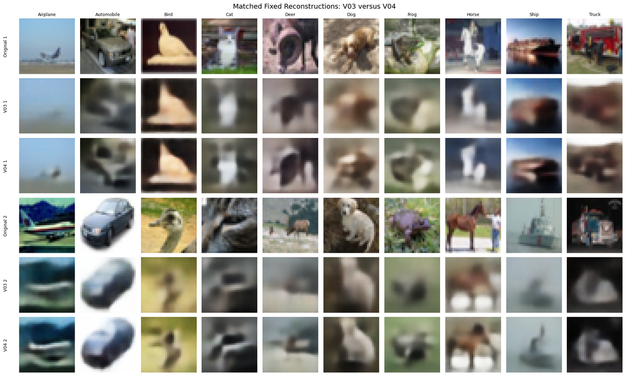

[figure not shown]

```
Matched generated-image descriptor comparison:
```

| descriptor | training_mean | V03_mean | V04_mean | V03_absolute_gap | V04_absolute_gap | gap_improvement_V04_vs_V03 |
| --- | --- | --- | --- | --- | --- | --- |
| brightness | 0.473055 | 0.488355 | 0.486635 | 0.015300 | 0.013579 | 0.001721 |
| contrast | 0.213141 | 0.186088 | 0.191225 | 0.027053 | 0.021916 | 0.005137 |
| red_mean | 0.489844 | 0.506511 | 0.509468 | 0.016668 | 0.019624 | -0.002957 |
| green_mean | 0.482936 | 0.497338 | 0.497390 | 0.014402 | 0.014454 | -0.000052 |
| blue_mean | 0.446386 | 0.461216 | 0.453046 | 0.014830 | 0.006660 | 0.008170 |
| saturation | 0.129711 | 0.116051 | 0.119659 | 0.013660 | 0.010052 | 0.003607 |
| edge_strength | 0.058002 | 0.029326 | 0.036541 | 0.028676 | 0.021461 | 0.007214 |

```
Matched generated diversity comparison:
```

|  | V03 | V04 | Training_reference |
| --- | --- | --- | --- |
| unique_uint8_images_out_of_100 | 100.000000 | 100.000000 | NaN |
| mean_pixel_standard_deviation | 0.210442 | 0.208664 | 0.249836 |
| minimum_unique_images_per_class_out_of_10 | 10.000000 | 10.000000 | NaN |
| mean_within_class_pixel_standard_deviation | 0.195344 | 0.193304 | NaN |

```
Matched conditional-control diagnostics:
```

|  | V03 | V04 | V04_minus_V03 |
| --- | --- | --- | --- |
| mean_pairwise_mae_between_labels_same_z | 0.055027 | 0.044543 | -0.010484 |
| within_requested_class_pixel_variance | 0.038273 | 0.034192 | -0.004080 |
| between_requested_class_centroid_variance | 0.002205 | 0.001360 | -0.000846 |
| between_to_within_variance_ratio | 0.057616 | 0.039763 | -0.017853 |
| mean_true_label_reconstruction_mse | 0.007696 | 0.006570 | -0.001126 |
| mean_wrong_label_reconstruction_mse | 0.013303 | 0.009660 | -0.003642 |
| fraction_true_mse_below_mean_wrong_mse | 1.000000 | 1.000000 | 0.000000 |
| fraction_true_label_lowest_mse_of_10 | 1.000000 | 0.950000 | -0.050000 |

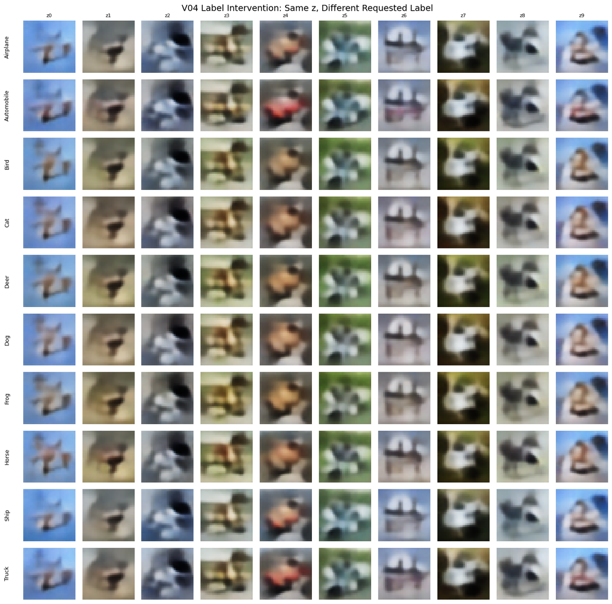

```
Matched latent-posterior diagnostics:
```

| model | mean_unweighted_kl | mean_absolute_z_mean | mean_posterior_std | mean_variance_of_z_mean_dimensions | active_units_variance_gt_0.01 |
| --- | --- | --- | --- | --- | --- |
| V03 | 62.017086 | 0.604957 | 0.460954 | 0.703887 | 59 |
| V04 | 106.539200 | 0.754401 | 0.217888 | 0.949140 | 64 |

```
Saved matched-evaluation artefacts:
- artifacts\vae\V04\evaluation\V03_V04_reconstruction_metrics.csv
- artifacts\vae\V04\evaluation\V03_V04_per_class_reconstruction_metrics.csv
- artifacts\vae\V04\evaluation\V03_V04_reconstruction_grid.png
- artifacts\vae\V04\evaluation\V04_fixed_requested_samples.npy
- artifacts\vae\V04\evaluation\V03_V04_same_latent_generation_grid.png
- artifacts\vae\V04\evaluation\V03_V04_descriptor_comparison.csv
- artifacts\vae\V04\evaluation\V03_V04_diversity_comparison.csv
- artifacts\vae\V04\evaluation\V03_V04_conditional_control_diagnostics.csv
- artifacts\vae\V04\evaluation\V04_same_z_different_label_grid.png
- artifacts\vae\V04\evaluation\V03_V04_latent_diagnostics.csv
V03 weight-file hashes unchanged: Yes
Models retrained: No
Official test-set usage: None
```

```python
v03_v04_control_df = pd.DataFrame({
    "V03": v03_control_metrics_for_v04,
    "V04": v04_control_metrics
})
v03_v04_control_df[
    "V04_minus_V03"
] = (
    v03_v04_control_df["V04"]
    - v03_v04_control_df["V03"]
)

print(
    "\nMatched conditional-control "
    "diagnostics:"
)
display(
    v03_v04_control_df.round(6)
)

v03_v04_control_path = (
    v04_evaluation_dir
    / (
        "V03_V04_conditional_"
        "control_diagnostics.csv"
    )
)
v03_v04_control_df.to_csv(
    v03_v04_control_path
)

fig, axes = plt.subplots(
    10,
    10,
    figsize=(14, 14)
)

for class_id, class_name in enumerate(
    class_names
):
    for latent_index in range(10):
        axis = axes[
            class_id,
            latent_index
        ]
        axis.imshow(
            v04_control_images[
                class_id,
                latent_index
            ]
        )
        axis.axis("off")

        if class_id == 0:
            axis.set_title(
                f"z{latent_index}",
                fontsize=8
            )

        if latent_index == 0:
            axis.text(
                -0.25,
                0.5,
                class_name,
                transform=axis.transAxes,
                rotation=90,
                va="center",
                ha="right",
                fontsize=9
            )

fig.suptitle(
    "V04 Label Intervention: "
    "Same z, Different Requested Label",
    fontsize=14
)
plt.tight_layout()

v04_label_intervention_grid_path = (
    v04_evaluation_dir
    / "V04_same_z_different_label_grid.png"
)
plt.savefig(
    v04_label_intervention_grid_path,
    dpi=150,
    bbox_inches="tight"
)
plt.show()

# -------------------------------------------------------
# 5. Matched latent-posterior diagnostics
# -------------------------------------------------------
v04_reference_one_hot = (
    keras.utils.to_categorical(
        v04_reference_labels,
        num_classes=(
            V04_EVALUATION_NUM_CLASSES
        )
    ).astype(np.float32)
)

(
    v03_reference_z_mean_for_v04,
    v03_reference_z_log_var_for_v04,
    _
) = encoder_v03.predict(
    [
        v04_reference_images,
        v04_reference_one_hot
    ],
    verbose=0
)
(
    v04_reference_z_mean,
    v04_reference_z_log_var,
    _
) = encoder_v04.predict(
    [
        v04_reference_images,
        v04_reference_one_hot
    ],
    verbose=0
)


def v04_latent_diagnostic_record(
    model_name,
    z_mean_values,
    z_log_var_values
):
    kl_per_image = -0.5 * np.sum(
        1.0
        + z_log_var_values
        - np.square(z_mean_values)
        - np.exp(z_log_var_values),
        axis=1
    )
    variance_by_dimension = np.var(
        z_mean_values,
        axis=0
    )

    return {
        "model": model_name,
        "mean_unweighted_kl": float(
            kl_per_image.mean()
        ),
        "mean_absolute_z_mean": float(
            np.abs(
                z_mean_values
            ).mean()
        ),
        "mean_posterior_std": float(
            np.exp(
                0.5 * z_log_var_values
            ).mean()
        ),
        (
            "mean_variance_of_"
            "z_mean_dimensions"
        ): float(
            variance_by_dimension.mean()
        ),
        (
            "active_units_"
            "variance_gt_0.01"
        ): int(
            np.sum(
                variance_by_dimension
                > 0.01
            )
        )
    }


v03_v04_latent_df = (
    pd.DataFrame([
        v04_latent_diagnostic_record(
            "V03",
            (
                v03_reference_z_mean_for_v04
            ),
            (
                v03_reference_z_log_var_for_v04
            )
        ),
        v04_latent_diagnostic_record(
            "V04",
            v04_reference_z_mean,
            v04_reference_z_log_var
        )
    ]).set_index("model")
)

print(
    "\nMatched latent-posterior "
    "diagnostics:"
)
display(
    v03_v04_latent_df.round(6)
)

v03_v04_latent_path = (
    v04_evaluation_dir
    / "V03_V04_latent_diagnostics.csv"
)
v03_v04_latent_df.to_csv(
    v03_v04_latent_path
)

# Confirm that evaluation did not alter V03 files.
v03_weight_hashes_after_v04_evaluation = {
    "encoder": v04_file_sha256(
        v03_encoder_weights_for_v04_comparison
    ),
    "decoder": v04_file_sha256(
        v03_decoder_weights_for_v04_comparison
    )
}
assert (
    v03_weight_hashes_before_v04_evaluation
    == v03_weight_hashes_after_v04_evaluation
)

print(
    "\nSaved matched-evaluation artefacts:"
)
for saved_path in [
    v03_v04_reconstruction_path,
    v03_v04_per_class_reconstruction_path,
    v03_v04_reconstruction_grid_path,
    v04_fixed_generated_samples_path,
    v03_v04_generation_grid_path,
    v03_v04_descriptor_path,
    v03_v04_diversity_path,
    v03_v04_control_path,
    v04_label_intervention_grid_path,
    v03_v04_latent_path
]:
    print(f"- {saved_path}")

print(
    "V03 weight-file hashes unchanged: Yes"
)
print("Models retrained: No")
print("Official test-set usage: None")
```

#### Executed V03-V04 Findings

V04 provides a clear reconstruction and structural improvement over its V03 parent on the same 20 fixed images:

| Metric | V03 | V04 | Interpretation |
| --- | --- | --- | --- |
| MSE ↓ | 0.007696 | 0.006570 | 14.63% lower |
| MAE ↓ | 0.063906 | 0.057916 | 9.37% lower |
| PSNR ↑ | 21.676 dB | 22.450 dB | +0.775 dB |
| SSIM ↑ | 0.606503 | 0.757548 | +0.151 absolute |
| Absolute edge gap ↓ | 0.031271 | 0.023499 | 24.85% lower |

Every represented class improved in reconstruction MSE and SSIM. The uncurated reconstruction grid agrees with the metrics: V04 generally retains stronger boundaries, local contrast and object structure than V03, although both remain blurred at CIFAR-10 resolution.

Generated descriptors also favour V04 overall. Five of seven absolute descriptor gaps improved, including contrast, blue-channel mean, saturation and edge strength. The red-channel gap became moderately worse and the green-channel gap was effectively unchanged, so the improvement is not universal.

There is no exact mode collapse: both models produced 100 unique uint8 images out of 100 and at least 10 unique images for every requested class. However, V04's overall pixel diversity was 0.84% lower and within-class diversity was 1.04% lower than V03.

The main trade-off is weaker conditional influence. Compared with V03, V04's same-`z` pairwise difference between labels fell by 19.05%, its between-class centroid variance fell by 38.32%, and its between-to-within variance ratio fell by 30.99%. The true label still reconstructed better than the mean wrong label for all 20 fixed images, but it was the best of all ten labels for 95% rather than 100%. The label-intervention grid visually confirms that changing the requested label often causes only modest colour or shape changes.

V04 used all 64 latent units under the stated activity threshold, so the results do not indicate posterior collapse. Its higher KL and lower posterior standard deviation nevertheless show a materially different latent trade-off from V03. This is retained as a limitation even though prior-generated FID improved.

### 9.7 V04 Development FID - Saved-Weight Three-Generation-Seed Evaluation

V04 follows the identical baseline protocol: the same saved epoch-50 weights are evaluated through three 5,000-image generations using seeds `1001`, `1002`, and `1003`, the same frozen InceptionV3 pipeline and training reference, and 500 requested samples per class in every run. These are repeated generation runs, not three independently trained V04 models.

The completed seed-1001 value is validated and reused. The code calculates seeds 1002 and 1003, then reports the three values, mean, standard deviation, minimum and maximum. Interpretation will combine this distributional evidence with V04's matched reconstruction, SSIM, edge, diversity, latent and class-control results. Formal human scoring remains reserved for the final selected VAE.

```python
assert (
    "evaluate_saved_conditional_vae_fid"
    in globals()
), (
    "Run the updated V03 FID cell first "
    "to restore the locked three-generation-seed "
    "conditional FID helper."
)

v04_inline_fid_weights_path = (
    Path("artifacts")
    / "vae"
    / "V04"
    / "weights"
    / "V04_decoder_final.weights.h5"
)
v04_single_fid_result_path = (
    Path("artifacts")
    / "vae"
    / "V04"
    / "evaluation"
    / "V04_development_fid.csv"
)
v04_repeated_fid_result_path = (
    Path("artifacts")
    / "vae"
    / "V04"
    / "evaluation"
    / "V04_repeated_development_fid.csv"
)
v04_fid_summary_path = (
    Path("artifacts")
    / "vae"
    / "V04"
    / "evaluation"
    / "V04_development_fid_summary.csv"
)

(
    v04_repeated_fid_df,
    v04_fid_summary_df,
    v04_inline_fid_decoder
) = evaluate_saved_conditional_vae_fid(
    experiment_id="V04",
    decoder_weights_path=(
        v04_inline_fid_weights_path
    ),
    single_result_path=(
        v04_single_fid_result_path
    ),
    repeated_result_path=(
        v04_repeated_fid_result_path
    ),
    summary_path=v04_fid_summary_path
)

print(
    "\nV04 repeated development-FID "
    "results:"
)
display(
    v04_repeated_fid_df.round(4)
)
print(
    "\nV04 FID summary "
    "(lower is better):"
)
display(
    v04_fid_summary_df.round(4)
)
print(
    "Repeated results saved to: "
    f"{v04_repeated_fid_result_path}"
)
print(
    "Summary saved to: "
    f"{v04_fid_summary_path}"
)
print("Balanced requested classes: Yes")
print("V04 retrained: No")
print("Official test-set usage: None")
```

```
Reusing validated V04 seed 1001 FID: 145.4253

Calculating V04 FID for seed 1002
```

```
V04 seed 1002 FID: 145.9172

Calculating V04 FID for seed 1003
```

```
V04 seed 1003 FID: 145.2898

V04 repeated development-FID results:
```

|  | experiment_id | checkpoint_epoch | seed | generated_sample_count | real_reference_count | samples_per_requested_class | fid | score_role | score_source | test_set_used |
| --- | --- | --- | --- | --- | --- | --- | --- | --- | --- | --- |
| 0 | V04 | 50 | 1001 | 5000 | 50000 | 500 | 145.4253 | three_seed_formal_comparison | reused_validated_single_seed_result | False |
| 1 | V04 | 50 | 1002 | 5000 | 50000 | 500 | 145.9172 | three_seed_formal_comparison | calculated_in_experiment | False |
| 2 | V04 | 50 | 1003 | 5000 | 50000 | 500 | 145.2898 | three_seed_formal_comparison | calculated_in_experiment | False |

```
V04 FID summary (lower is better):
```

|  | experiment_id | fid_mean | fid_std | fid_min | fid_max | repeat_count |
| --- | --- | --- | --- | --- | --- | --- |
| 0 | V04 | 145.5441 | 0.3302 | 145.2898 | 145.9172 | 3 |

```
Repeated results saved to: artifacts\vae\V04\evaluation\V04_repeated_development_fid.csv
Summary saved to: artifacts\vae\V04\evaluation\V04_development_fid_summary.csv
Balanced requested classes: Yes
V04 retrained: No
Official test-set usage: None
```

#### Executed Three-Generation-Seed FID Finding

V04 produced FID scores of `145.4253`, `145.9172`, and `145.2898` for generation seeds 1001-1003. Its mean FID is therefore **145.5441 ± 0.3302**, with all three runs tightly grouped.

V03 achieved **157.7903 ± 0.1121** under the identical protocol. V04 lowers the mean by **12.2462 points**, or **7.76%**, and even V04's worst run (`145.9172`) is well below V03's best run (`157.6641`). This is strong evidence, consistent across the three tested generation seeds, that the L1-SSIM objective improved the Inception-feature distribution of balanced prior samples. It does not measure variability across independent training runs.

FID does not measure requested-label correctness or replace visual inspection. The result is therefore combined with V04's stronger reconstruction and edge evidence, unchanged exact uniqueness, slightly lower diversity and weaker label sensitivity.

### 9.8 V04 Decision - Accepted as the Current Conditional Incumbent

V04 is retained as the current conditional incumbent and becomes the parent for V05. This is an intermediate within-family decision, not the final VAE selection.

#### Evidence Supporting Retention

V04 completed all 50 epochs without numerical instability and produced a stable checkpoint progression. Against V03, it reduced reconstruction MSE by 14.63% and MAE by 9.37%, increased PSNR by 0.775 dB, increased SSIM by 0.151, and reduced the absolute edge-strength gap by 24.85%. The reconstruction and matched-generation grids show visibly stronger local structure and contrast.

The distributional result is also substantial and consistent across the tested generation seeds. V04 achieved **145.5441 ± 0.3302** FID compared with **157.7903 ± 0.1121** for V03, a 7.76% reduction. All three V04 generation-seed scores were below every V03 score. This consistency concerns repeated sampling from the same saved weights, not independent training runs. V04 also retained 100 unique samples out of 100, used all 64 latent units under the stated activity threshold, and moved most generated-image descriptors closer to the training reference.

#### Trade-Off and Remaining Risk

V04 does not dominate V03 on every criterion. Overall and within-class pixel diversity decreased slightly. More importantly, same-latent label sensitivity, between-class centroid variance and the between-to-within variance ratio all declined. The intervention grid shows that the latent vector often controls most of the image while changing the requested class produces only modest differences. V03 therefore remains in the V00-V05 candidate pool as the stronger conditional-control reference.

The acceptance decision gives greater weight to V04's large, consistent gains in FID, reconstruction, SSIM and edge structure because diversity remained high and the conditional signal remained measurable rather than disappearing. Formal human scoring remains deferred until the V00-V05 quantitative screen identifies one provisional candidate.

#### Next Controlled Experiment

V05 keeps V04's architecture, latent dimension, `β`, hybrid L1-SSIM objective, data and training budget unchanged. It changes only the optimizer configuration from Adam to AdamW to test whether mild decoupled weight decay improves the V04 trade-off. V04 remains the reference unless V05 provides stronger complete evidence.

## 10. Controlled Improvement - V05 AdamW Conditional VAE

### 10.1 Experimental Rationale, Hypothesis, and Controls

V04 is the immediate parent and current conditional incumbent. V05 tests one primary change:

> Can AdamW's decoupled weight decay improve the stability or generalisation of V04's hybrid L1-SSIM conditional VAE without sacrificing its reconstruction, FID, diversity or conditional behaviour?

Adam and AdamW both use adaptive first- and second-moment estimates. AdamW was proposed by Loshchilov and Hutter [7] to decouple weight decay from the gradient-based loss update. The controlled difference tested here is therefore the optimizer's separate weight-decay update. The fixed weight decay is `0.0001`; it is declared before training and is not tuned after viewing the results.

| Factor | V04 | V05 |
| --- | --- | --- |
| Conditional architecture | Conv2D / Conv2DTranspose | Same |
| Conditioning | One-hot encoder and decoder | Same |
| Latent dimension | 64 | 64 |
| Reconstruction objective | L1 + 0.1-scaled SSIM | Same |
| KL weight, `β` | 0.5 | 0.5 |
| Optimizer | Adam | AdamW |
| Weight decay | 0 | 0.0001 |
| Learning rate | 0.001 | 0.001 |
| Batch size | 128 | 128 |
| Training budget | 50 epochs | 50 epochs |
| Seed | 42 | 42 |
| Augmentation | None | None |
| Training data | CIFAR-10 train only | Same |

V05 is rebuilt from a fresh seeded initialization; it does not continue V04's trained weights. It will replace V04 as the current conditional incumbent only if the complete matched evaluation provides a better overall trade-off. A lower training loss alone is insufficient.

```python
# Build V05 as a fresh architectural copy of V04.
V05_EXPERIMENT_ID = "V05"
V05_PARENT_EXPERIMENT = "V04"
V05_INPUT_SHAPE = (32, 32, 3)
V05_LATENT_DIM = 64
V05_BETA = 0.5
V05_NUM_CLASSES = len(class_names)
V05_SSIM_WEIGHT = 0.1
V05_PIXEL_COUNT = int(np.prod(V05_INPUT_SHAPE))

assert V05_NUM_CLASSES == V04_NUM_CLASSES == 10
assert V05_LATENT_DIM == V04_LATENT_DIM == 64
assert V05_BETA == V04_BETA == 0.5
assert V05_SSIM_WEIGHT == V04_SSIM_WEIGHT == 0.1
assert V05_PIXEL_COUNT == V04_PIXEL_COUNT == 3_072

y_train_one_hot_v05 = keras.utils.to_categorical(
    np.asarray(y_train).reshape(-1),
    num_classes=V05_NUM_CLASSES
).astype(np.float32)

assert y_train_one_hot_v05.shape == (50_000, 10)
assert y_train_one_hot_v05.dtype == np.float32
assert np.allclose(
    y_train_one_hot_v05.sum(axis=1),
    1.0
)


class V05Sampling(layers.Layer):
    # Same reparameterisation used by V03 and V04.
    def call(self, inputs):
        z_mean, z_log_var = inputs
        batch_size = tf.shape(z_mean)[0]
        latent_dimension = tf.shape(z_mean)[1]
        epsilon = tf.random.normal(
            shape=(batch_size, latent_dimension)
        )
        return (
            z_mean
            + tf.exp(0.5 * z_log_var) * epsilon
        )


tf.keras.utils.set_random_seed(SEED)

# Conditional encoder q(z|x,y), matched to V04.
v05_image_inputs = keras.Input(
    shape=V05_INPUT_SHAPE,
    name="V05_encoder_image_input"
)
v05_encoder_label_inputs = keras.Input(
    shape=(V05_NUM_CLASSES,),
    name="V05_encoder_label_input"
)

v05_x = layers.Conv2D(
    32,
    kernel_size=3,
    strides=2,
    padding="same",
    activation="relu",
    name="V05_encoder_conv_1"
)(v05_image_inputs)
v05_x = layers.Conv2D(
    64,
    kernel_size=3,
    strides=2,
    padding="same",
    activation="relu",
    name="V05_encoder_conv_2"
)(v05_x)
v05_x = layers.Conv2D(
    128,
    kernel_size=3,
    strides=2,
    padding="same",
    activation="relu",
    name="V05_encoder_conv_3"
)(v05_x)
v05_x = layers.Flatten(
    name="V05_encoder_flatten"
)(v05_x)
v05_x = layers.Concatenate(
    name="V05_encoder_feature_label_concat"
)([
    v05_x,
    v05_encoder_label_inputs
])
v05_x = layers.Dense(
    256,
    activation="relu",
    name="V05_encoder_dense"
)(v05_x)

v05_z_mean = layers.Dense(
    V05_LATENT_DIM,
    name="V05_z_mean"
)(v05_x)
v05_z_log_var = layers.Dense(
    V05_LATENT_DIM,
    name="V05_z_log_var"
)(v05_x)
v05_z = V05Sampling(
    name="V05_z_sampling"
)([
    v05_z_mean,
    v05_z_log_var
])

encoder_v05 = keras.Model(
    inputs=[
        v05_image_inputs,
        v05_encoder_label_inputs
    ],
    outputs=[
        v05_z_mean,
        v05_z_log_var,
        v05_z
    ],
    name="V05_conditional_encoder"
)

# Conditional decoder p(x|z,y), matched to V04.
v05_latent_inputs = keras.Input(
    shape=(V05_LATENT_DIM,),
    name="V05_decoder_latent_input"
)
v05_decoder_label_inputs = keras.Input(
    shape=(V05_NUM_CLASSES,),
    name="V05_decoder_label_input"
)

v05_y = layers.Concatenate(
    name="V05_decoder_latent_label_concat"
)([
    v05_latent_inputs,
    v05_decoder_label_inputs
])
v05_y = layers.Dense(
    4 * 4 * 128,
    activation="relu",
    name="V05_decoder_dense"
)(v05_y)
v05_y = layers.Reshape(
    (4, 4, 128),
    name="V05_decoder_reshape"
)(v05_y)
v05_y = layers.Conv2DTranspose(
    128,
    kernel_size=3,
    strides=2,
    padding="same",
    activation="relu",
    name="V05_decoder_deconv_1"
)(v05_y)
v05_y = layers.Conv2DTranspose(
    64,
    kernel_size=3,
    strides=2,
    padding="same",
    activation="relu",
    name="V05_decoder_deconv_2"
)(v05_y)
v05_y = layers.Conv2DTranspose(
    32,
    kernel_size=3,
    strides=2,
    padding="same",
    activation="relu",
    name="V05_decoder_deconv_3"
)(v05_y)
v05_decoder_outputs = layers.Conv2D(
    3,
    kernel_size=3,
    padding="same",
    activation="sigmoid",
    name="V05_decoder_output"
)(v05_y)

decoder_v05 = keras.Model(
    inputs=[
        v05_latent_inputs,
        v05_decoder_label_inputs
    ],
    outputs=v05_decoder_outputs,
    name="V05_conditional_decoder"
)

assert encoder_v05.count_params() == 653_248
assert decoder_v05.count_params() == 394_307
assert (
    encoder_v05.count_params()
    == encoder_v04.count_params()
)
assert (
    decoder_v05.count_params()
    == decoder_v04.count_params()
)

v05_architecture_test_output = decoder_v05(
    [
        tf.zeros(
            (2, V05_LATENT_DIM),
            dtype=tf.float32
        ),
        tf.one_hot(
            [0, 1],
            depth=V05_NUM_CLASSES
        )
    ],
    training=False
)

assert v05_architecture_test_output.shape == (
    2,
    32,
    32,
    3
)
assert np.isfinite(
    v05_architecture_test_output.numpy()
).all()
assert (
    tf.reduce_min(
        v05_architecture_test_output
    ).numpy() >= 0.0
)
assert (
    tf.reduce_max(
        v05_architecture_test_output
    ).numpy() <= 1.0
)

print(f"Experiment ID: {V05_EXPERIMENT_ID}")
print(f"Parent incumbent: {V05_PARENT_EXPERIMENT}")
print(
    "Only planned change: "
    "Adam replaced by AdamW"
)
print(
    "V05 encoder parameters: "
    f"{encoder_v05.count_params():,}"
)
print(
    "V05 decoder parameters: "
    f"{decoder_v05.count_params():,}"
)
print("Parameter count matches V04: Yes")
print(
    "Architecture output validation passed: "
    f"{v05_architecture_test_output.shape}"
)
print("Official test-set usage: None")

encoder_v05.summary()
decoder_v05.summary()
```

```
Experiment ID: V05
Parent incumbent: V04
Only planned change: Adam replaced by AdamW
V05 encoder parameters: 653,248
V05 decoder parameters: 394,307
Parameter count matches V04: Yes
Architecture output validation passed: (2, 32, 32, 3)
Official test-set usage: None
Model: "V05_conditional_encoder"
__________________________________________________________________________________________________
 Layer (type)                   Output Shape         Param #     Connected to
==================================================================================================
 V05_encoder_image_input (Input  [(None, 32, 32, 3)]  0          []
 Layer)

 V05_encoder_conv_1 (Conv2D)    (None, 16, 16, 32)   896         ['V05_encoder_image_input[0][0]']

 V05_encoder_conv_2 (Conv2D)    (None, 8, 8, 64)     18496       ['V05_encoder_conv_1[0][0]']

 V05_encoder_conv_3 (Conv2D)    (None, 4, 4, 128)    73856       ['V05_encoder_conv_2[0][0]']

 V05_encoder_flatten (Flatten)  (None, 2048)         0           ['V05_encoder_conv_3[0][0]']

 V05_encoder_label_input (Input  [(None, 10)]        0           []
 Layer)

 V05_encoder_feature_label_conc  (None, 2058)        0           ['V05_encoder_flatten[0][0]',
 at (Concatenate)                                                 'V05_encoder_label_input[0][0]']

 V05_encoder_dense (Dense)      (None, 256)          527104      ['V05_encoder_feature_label_conca
                                                                 t[0][0]']

 V05_z_mean (Dense)             (None, 64)           16448       ['V05_encoder_dense[0][0]']

 V05_z_log_var (Dense)          (None, 64)           16448       ['V05_encoder_dense[0][0]']

 V05_z_sampling (V05Sampling)   (None, 64)           0           ['V05_z_mean[0][0]',
                                                                  'V05_z_log_var[0][0]']

==================================================================================================
```

[output cut: 24 more lines]

```
 anspose)

 V05_decoder_deconv_2 (Conv2DTr  (None, 16, 16, 64)  73792       ['V05_decoder_deconv_1[0][0]']
 anspose)

 V05_decoder_deconv_3 (Conv2DTr  (None, 32, 32, 32)  18464       ['V05_decoder_deconv_2[0][0]']
 anspose)

 V05_decoder_output (Conv2D)    (None, 32, 32, 3)    867         ['V05_decoder_deconv_3[0][0]']

==================================================================================================
Total params: 394,307
Trainable params: 394,307
Non-trainable params: 0
__________________________________________________________________________________________________
```

### 10.2 V05 Training Configuration

V05 uses the same custom hybrid-loss VAE class as V04. The reconstruction objective remains:

$$ \mathcal{L}_{\mathrm{recon}} = \sum_p \left|x_p-\hat{x}_p\right| + 0.1 \times 3072 \times \left(1-\operatorname{SSIM}(x,\hat{x})\right) $$

and the total objective remains:

$$ \mathcal{L}_{\mathrm{V05}} = \mathcal{L}_{\mathrm{recon}} + 0.5\mathcal{L}_{\mathrm{KL}} $$

Only the optimizer configuration changes to AdamW with learning rate `0.001` and weight decay `0.0001`. The recorded TensorFlow/Keras 2.10 environment enables XLA for the experimental AdamW optimizer by default. `jit_compile=False` is therefore fixed for compatibility with the available CUDA installation. This disables optimizer-side XLA acceleration only; it does not change the AdamW update rule, learning rate or weight decay. The training cell records the same seven losses and monitoring metrics, saves the same five milestone checkpoints, and protects any completed V05 artefacts from accidental overwrite.

```python
# Train V05 from a fresh initialization using AdamW.
assert "HybridMAESSIMConditionalVAE" in globals(), (
    "Run the V04 training-definition cell first so the "
    "shared hybrid-loss VAE class is available."
)
if hasattr(keras.optimizers, "AdamW"):
    V05AdamWOptimizer = keras.optimizers.AdamW
    V05_ADAMW_API = "keras.optimizers.AdamW"
elif (
    hasattr(keras.optimizers, "experimental")
    and hasattr(
        keras.optimizers.experimental,
        "AdamW"
    )
):
    # TensorFlow/Keras 2.10 exposes AdamW here.
    V05AdamWOptimizer = (
        keras.optimizers.experimental.AdamW
    )
    V05_ADAMW_API = (
        "keras.optimizers.experimental.AdamW"
    )
else:
    raise RuntimeError(
        "AdamW is unavailable in this "
        "TensorFlow/Keras installation."
    )

V05_LEARNING_RATE = 0.001
V05_WEIGHT_DECAY = 0.0001
V05_ADAMW_JIT_COMPILE = False
V05_BATCH_SIZE = 128
V05_EPOCHS = 50
V05_MILESTONE_EPOCHS = [1, 10, 25, 40, 50]

assert V05_LEARNING_RATE == V04_LEARNING_RATE
assert V05_BATCH_SIZE == V04_BATCH_SIZE
assert V05_EPOCHS == V04_EPOCHS
assert V05_MILESTONE_EPOCHS == V04_MILESTONE_EPOCHS

tf.keras.utils.set_random_seed(SEED)

vae_v05 = HybridMAESSIMConditionalVAE(
    encoder=encoder_v05,
    decoder=decoder_v05,
    beta=V05_BETA,
    ssim_weight=V05_SSIM_WEIGHT,
    pixel_count=V05_PIXEL_COUNT,
    name="V05_hybrid_mae_ssim_adamw_vae"
)
vae_v05.compile(
    optimizer=V05AdamWOptimizer(
        learning_rate=V05_LEARNING_RATE,
        weight_decay=V05_WEIGHT_DECAY,
        jit_compile=V05_ADAMW_JIT_COMPILE
    )
)

_ = vae_v05(
    [
        tf.zeros(
            shape=(1,) + V05_INPUT_SHAPE,
            dtype=tf.float32
        ),
        tf.one_hot(
            [0],
            depth=V05_NUM_CLASSES
        )
    ],
    training=False
)

v05_artifact_dir = (
    Path("artifacts") / "vae" / V05_EXPERIMENT_ID
)
v05_checkpoint_dir = (
    v05_artifact_dir / "checkpoints"
)
v05_weight_dir = v05_artifact_dir / "weights"

for directory in [
    v05_artifact_dir,
    v05_checkpoint_dir,
    v05_weight_dir
]:
    directory.mkdir(parents=True, exist_ok=True)

v05_final_vae_weights_path = (
    v05_weight_dir / "V05_vae_final.weights.h5"
)
v05_final_encoder_weights_path = (
    v05_weight_dir / "V05_encoder_final.weights.h5"
)
v05_final_decoder_weights_path = (
    v05_weight_dir / "V05_decoder_final.weights.h5"
)

for protected_v05_path in [
    v05_final_vae_weights_path,
    v05_final_encoder_weights_path,
    v05_final_decoder_weights_path
]:
    if protected_v05_path.exists():
        raise FileExistsError(
            "A completed V05 artefact already exists. "
            "Do not overwrite or silently retrain it: "
            f"{protected_v05_path}"
        )


class V05MilestoneWeightsSaver(keras.callbacks.Callback):
    def __init__(self, checkpoint_dir, milestone_epochs):
        super().__init__()
        self.checkpoint_dir = Path(checkpoint_dir)
        self.milestone_epochs = set(milestone_epochs)
        self.saved_paths = []

    def on_epoch_end(self, epoch, logs=None):
        completed_epoch = epoch + 1
        if completed_epoch in self.milestone_epochs:
            checkpoint_path = (
                self.checkpoint_dir
                / (
                    "V05_epoch_"
                    f"{completed_epoch:03d}"
                    ".weights.h5"
                )
            )
            self.model.save_weights(str(checkpoint_path))
            self.saved_paths.append(checkpoint_path)
            print(
                "\nSaved fixed V05 milestone checkpoint: "
                f"{checkpoint_path}"
            )


v05_milestone_saver = V05MilestoneWeightsSaver(
    checkpoint_dir=v05_checkpoint_dir,
    milestone_epochs=V05_MILESTONE_EPOCHS
)

print("Starting V05 controlled AdamW training.")
print("Only changed factor: optimizer configuration")
print("Parent optimizer: Adam")
print("V05 optimizer: AdamW")
print(f"AdamW API: {V05_ADAMW_API}")
print(f"Weight decay: {V05_WEIGHT_DECAY}")
print(
    "Optimizer XLA JIT enabled: "
    f"{V05_ADAMW_JIT_COMPILE}"
)
print(f"Learning rate: {V05_LEARNING_RATE}")
print(f"Latent dimension: {V05_LATENT_DIM}")
print(f"Beta: {V05_BETA}")
print(f"Epochs: {V05_EPOCHS}")
print(f"Batch size: {V05_BATCH_SIZE}")
print("Data augmentation: None")
print("Official test-set usage: None")

v05_training_start_time = time.perf_counter()

vae_v05_history = vae_v05.fit(
    x=[
        x_train_vae,
        y_train_one_hot_v05
    ],
    epochs=V05_EPOCHS,
    batch_size=V05_BATCH_SIZE,
    shuffle=True,
    callbacks=[
        keras.callbacks.TerminateOnNaN(),
        v05_milestone_saver
    ],
    verbose=2
)

v05_training_duration_seconds = (
    time.perf_counter() - v05_training_start_time
)

v05_history_df = pd.DataFrame(
    vae_v05_history.history
)
v05_history_df.index = np.arange(
    1,
    len(v05_history_df) + 1
)
v05_history_df.index.name = "epoch"

v05_history_path = (
    v05_artifact_dir / "V05_training_history.csv"
)
v05_history_df.to_csv(v05_history_path)

vae_v05.save_weights(
    str(v05_final_vae_weights_path)
)
encoder_v05.save_weights(
    str(v05_final_encoder_weights_path)
)
decoder_v05.save_weights(
    str(v05_final_decoder_weights_path)
)

v05_training_record = {
    "experiment_id": V05_EXPERIMENT_ID,
    "parent_experiment": V05_PARENT_EXPERIMENT,
    "model_type": "conditional_vae",
    "experimental_status": "challenger_not_selected",
    "single_changed_factor": "optimizer_configuration",
    "parent_optimizer": "Adam",
    "optimizer": "AdamW",
    "optimizer_api": V05_ADAMW_API,
    "weight_decay": V05_WEIGHT_DECAY,
    "optimizer_jit_compile": (
        V05_ADAMW_JIT_COMPILE
    ),
    "learning_rate": V05_LEARNING_RATE,
    "reconstruction_objective": (
        "summed_l1_plus_scaled_ssim_dissimilarity"
    ),
    "ssim_formula": "0.1 * 3072 * (1 - SSIM)",
    "ssim_weight": V05_SSIM_WEIGHT,
    "pixel_count": V05_PIXEL_COUNT,
    "conditioning": "one_hot_encoder_and_decoder",
    "input_shape": list(V05_INPUT_SHAPE),
    "number_of_classes": V05_NUM_CLASSES,
    "latent_dimension": V05_LATENT_DIM,
    "beta": V05_BETA,
    "batch_size": V05_BATCH_SIZE,
    "epochs_requested": V05_EPOCHS,
    "epochs_completed": len(v05_history_df),
    "shuffle": True,
    "data_augmentation": None,
    "validation_split": None,
    "test_set_used": False,
    "seed": SEED,
    "milestone_epochs": V05_MILESTONE_EPOCHS,
    "encoder_parameters": int(
        encoder_v05.count_params()
    ),
    "decoder_parameters": int(
        decoder_v05.count_params()
    ),
    "training_duration_seconds": float(
        v05_training_duration_seconds
    )
}

v05_training_record_path = (
    v05_artifact_dir / "V05_training_record.json"
)
with v05_training_record_path.open(
    "w",
    encoding="utf-8"
) as record_file:
    json.dump(
        v05_training_record,
        record_file,
        indent=4
    )

print("\nV05 AdamW training completed.")
print(
    "Training duration: "
    f"{v05_training_duration_seconds / 60:.2f} minutes"
)
print(f"History saved to: {v05_history_path}")
print(
    "Training record saved to: "
    f"{v05_training_record_path}"
)
print(
    "Final VAE weights: "
    f"{v05_final_vae_weights_path}"
)
print(
    "Final encoder weights: "
    f"{v05_final_encoder_weights_path}"
)
print(
    "Final decoder weights: "
    f"{v05_final_decoder_weights_path}"
)
```

```
Starting V05 controlled AdamW training.
Only changed factor: optimizer configuration
Parent optimizer: Adam
V05 optimizer: AdamW
AdamW API: keras.optimizers.experimental.AdamW
Weight decay: 0.0001
Optimizer XLA JIT enabled: False
Learning rate: 0.001
Latent dimension: 64
Beta: 0.5
Epochs: 50
Batch size: 128
Data augmentation: None
Official test-set usage: None

Saved fixed V05 milestone checkpoint: artifacts\vae\V05\checkpoints\V05_epoch_001.weights.h5
391/391 - 16s - loss: 672.3674 - total_loss: 672.3674 - reconstruction_loss: 651.7581 - l1_reconstruction_loss: 434.9642 - ssim_dissimilarity: 0.7057 - scaled_ssim_loss: 216.7937 - kl_loss: 41.2181 - pixel_mse: 0.0344 - 16s/epoch - 40ms/step
391/391 - 14s - loss: 488.8989 - total_loss: 488.8989 - reconstruction_loss: 452.8965 - l1_reconstruction_loss: 295.0551 - ssim_dissimilarity: 0.5138 - scaled_ssim_loss: 157.8413 - kl_loss: 72.0051 - pixel_mse: 0.0170 - 14s/epoch - 35ms/step
391/391 - 14s - loss: 437.2216 - total_loss: 437.2216 - reconstruction_loss: 397.0764 - l1_reconstruction_loss: 258.7511 - ssim_dissimilarity: 0.4503 - scaled_ssim_loss: 138.3253 - kl_loss: 80.2907 - pixel_mse: 0.0136 - 14s/epoch - 35ms/step
391/391 - 14s - loss: 414.7095 - total_loss: 414.7095 - reconstruction_loss: 372.4337 - l1_reconstruction_loss: 245.0063 - ssim_dissimilarity: 0.4148 - scaled_ssim_loss: 127.4273 - kl_loss: 84.5517 - pixel_mse: 0.0123 - 14s/epoch - 36ms/step
391/391 - 14s - loss: 400.8142 - total_loss: 400.8142 - reconstruction_loss: 356.8426 - l1_reconstruction_loss: 236.6449 - ssim_dissimilarity: 0.3913 - scaled_ssim_loss: 120.1976 - kl_loss: 87.9436 - pixel_mse: 0.0116 - 14s/epoch - 35ms/step
391/391 - 14s - loss: 390.6456 - total_loss: 390.6456 - reconstruction_loss: 345.1714 - l1_reconstruction_loss: 230.2047 - ssim_dissimilarity: 0.3742 - scaled_ssim_loss: 114.9666 - kl_loss: 90.9485 - pixel_mse: 0.0110 - 14s/epoch - 35ms/step
391/391 - 14s - loss: 383.1805 - total_loss: 383.1805 - reconstruction_loss: 336.1481 - l1_reconstruction_loss: 224.9285 - ssim_dissimilarity: 0.3620 - scaled_ssim_loss: 111.2194 - kl_loss: 94.0645 - pixel_mse: 0.0106 - 14s/epoch - 35ms/step
391/391 - 14s - loss: 376.0843 - total_loss: 376.0843 - reconstruction_loss: 327.9886 - l1_reconstruction_loss: 219.7428 - ssim_dissimilarity: 0.3524 - scaled_ssim_loss: 108.2458 - kl_loss: 96.1915 - pixel_mse: 0.0102 - 14s/epoch - 35ms/step
391/391 - 14s - loss: 371.6096 - total_loss: 371.6096 - reconstruction_loss: 323.0059 - l1_reconstruction_loss: 216.7122 - ssim_dissimilarity: 0.3460 - scaled_ssim_loss: 106.2939 - kl_loss: 97.2075 - pixel_mse: 0.0100 - 14s/epoch - 35ms/step

Saved fixed V05 milestone checkpoint: artifacts\vae\V05\checkpoints\V05_epoch_010.weights.h5
391/391 - 14s - loss: 368.9146 - total_loss: 368.9146 - reconstruction_loss: 320.0666 - l1_reconstruction_loss: 215.1840 - ssim_dissimilarity: 0.3414 - scaled_ssim_loss: 104.8827 - kl_loss: 97.6959 - pixel_mse: 0.0099 - 14s/epoch - 35ms/step
391/391 - 14s - loss: 365.9201 - total_loss: 365.9201 - reconstruction_loss: 316.4925 - l1_reconstruction_loss: 213.1749 - ssim_dissimilarity: 0.3363 - scaled_ssim_loss: 103.3176 - kl_loss: 98.8551 - pixel_mse: 0.0097 - 14s/epoch - 35ms/step
391/391 - 14s - loss: 364.4296 - total_loss: 364.4296 - reconstruction_loss: 314.7972 - l1_reconstruction_loss: 212.4273 - ssim_dissimilarity: 0.3332 - scaled_ssim_loss: 102.3699 - kl_loss: 99.2645 - pixel_mse: 0.0096 - 14s/epoch - 36ms/step
391/391 - 14s - loss: 362.6219 - total_loss: 362.6219 - reconstruction_loss: 312.7545 - l1_reconstruction_loss: 211.3008 - ssim_dissimilarity: 0.3303 - scaled_ssim_loss: 101.4535 - kl_loss: 99.7349 - pixel_mse: 0.0096 - 14s/epoch - 35ms/step
391/391 - 14s - loss: 360.3524 - total_loss: 360.3524 - reconstruction_loss: 309.8755 - l1_reconstruction_loss: 209.6577 - ssim_dissimilarity: 0.3262 - scaled_ssim_loss: 100.2178 - kl_loss: 100.9539 - pixel_mse: 0.0094 - 14s/epoch - 35ms/step
391/391 - 14s - loss: 358.7883 - total_loss: 358.7883 - reconstruction_loss: 307.9246 - l1_reconstruction_loss: 208.6905 - ssim_dissimilarity: 0.3230 - scaled_ssim_loss: 99.2342 - kl_loss: 101.7273 - pixel_mse: 0.0094 - 14s/epoch - 35ms/step
391/391 - 14s - loss: 357.0676 - total_loss: 357.0676 - reconstruction_loss: 305.8528 - l1_reconstruction_loss: 207.5693 - ssim_dissimilarity: 0.3199 - scaled_ssim_loss: 98.2835 - kl_loss: 102.4294 - pixel_mse: 0.0093 - 14s/epoch - 35ms/step
391/391 - 14s - loss: 355.7585 - total_loss: 355.7585 - reconstruction_loss: 304.3150 - l1_reconstruction_loss: 206.7827 - ssim_dissimilarity: 0.3175 - scaled_ssim_loss: 97.5322 - kl_loss: 102.8875 - pixel_mse: 0.0092 - 14s/epoch - 35ms/step
391/391 - 14s - loss: 354.6268 - total_loss: 354.6268 - reconstruction_loss: 302.9378 - l1_reconstruction_loss: 206.0638 - ssim_dissimilarity: 0.3153 - scaled_ssim_loss: 96.8739 - kl_loss: 103.3779 - pixel_mse: 0.0092 - 14s/epoch - 35ms/step
391/391 - 14s - loss: 353.7933 - total_loss: 353.7933 - reconstruction_loss: 302.1458 - l1_reconstruction_loss: 205.6555 - ssim_dissimilarity: 0.3141 - scaled_ssim_loss: 96.4904 - kl_loss: 103.2950 - pixel_mse: 0.0091 - 14s/epoch - 35ms/step
391/391 - 14s - loss: 352.9442 - total_loss: 352.9442 - reconstruction_loss: 301.2565 - l1_reconstruction_loss: 205.1575 - ssim_dissimilarity: 0.3128 - scaled_ssim_loss: 96.0989 - kl_loss: 103.3755 - pixel_mse: 0.0091 - 14s/epoch - 36ms/step
391/391 - 14s - loss: 352.4004 - total_loss: 352.4004 - reconstruction_loss: 300.6660 - l1_reconstruction_loss: 204.8747 - ssim_dissimilarity: 0.3118 - scaled_ssim_loss: 95.7912 - kl_loss: 103.4686 - pixel_mse: 0.0091 - 14s/epoch - 36ms/step
391/391 - 14s - loss: 351.6158 - total_loss: 351.6158 - reconstruction_loss: 299.6425 - l1_reconstruction_loss: 204.3042 - ssim_dissimilarity: 0.3103 - scaled_ssim_loss: 95.3382 - kl_loss: 103.9468 - pixel_mse: 0.0090 - 14s/epoch - 35ms/step
```

[output cut: 27 more lines]

```
391/391 - 14s - loss: 341.0233 - total_loss: 341.0233 - reconstruction_loss: 287.2381 - l1_reconstruction_loss: 197.2903 - ssim_dissimilarity: 0.2928 - scaled_ssim_loss: 89.9477 - kl_loss: 107.5706 - pixel_mse: 0.0085 - 14s/epoch - 35ms/step
391/391 - 14s - loss: 340.9437 - total_loss: 340.9437 - reconstruction_loss: 287.1216 - l1_reconstruction_loss: 197.2531 - ssim_dissimilarity: 0.2925 - scaled_ssim_loss: 89.8684 - kl_loss: 107.6444 - pixel_mse: 0.0085 - 14s/epoch - 36ms/step
391/391 - 14s - loss: 340.7888 - total_loss: 340.7888 - reconstruction_loss: 286.9608 - l1_reconstruction_loss: 197.1862 - ssim_dissimilarity: 0.2922 - scaled_ssim_loss: 89.7746 - kl_loss: 107.6562 - pixel_mse: 0.0085 - 14s/epoch - 36ms/step
391/391 - 14s - loss: 340.4176 - total_loss: 340.4176 - reconstruction_loss: 286.5718 - l1_reconstruction_loss: 196.9086 - ssim_dissimilarity: 0.2919 - scaled_ssim_loss: 89.6633 - kl_loss: 107.6917 - pixel_mse: 0.0085 - 14s/epoch - 35ms/step

Saved fixed V05 milestone checkpoint: artifacts\vae\V05\checkpoints\V05_epoch_050.weights.h5
391/391 - 14s - loss: 340.2205 - total_loss: 340.2205 - reconstruction_loss: 286.3576 - l1_reconstruction_loss: 196.7622 - ssim_dissimilarity: 0.2917 - scaled_ssim_loss: 89.5953 - kl_loss: 107.7260 - pixel_mse: 0.0085 - 14s/epoch - 35ms/step

V05 AdamW training completed.
Training duration: 11.53 minutes
History saved to: artifacts\vae\V05\V05_training_history.csv
Training record saved to: artifacts\vae\V05\V05_training_record.json
Final VAE weights: artifacts\vae\V05\weights\V05_vae_final.weights.h5
Final encoder weights: artifacts\vae\V05\weights\V05_encoder_final.weights.h5
Final decoder weights: artifacts\vae\V05\weights\V05_decoder_final.weights.h5
```

### 10.3 Immediate V05 Training Diagnostics

The next cell validates the completed AdamW run using the same mechanical checks as V04:

- all 50 epochs must be present;
- every recorded value must be finite and non-negative;
- all five milestone checkpoints and final weight files must exist;
- L1 and scaled SSIM components must reproduce the recorded reconstruction loss; and
- the seven tracked quantities must be plotted without using the official test set.

Because V04 and V05 use the same architecture, objective, data and training budget, their recorded components are on the same scale. Nevertheless, the final experiment decision still requires fixed-input reconstruction, generation, diversity, latent, conditional-control and FID evidence.

```python
v05_required_history_columns = [
    "total_loss",
    "reconstruction_loss",
    "l1_reconstruction_loss",
    "ssim_dissimilarity",
    "scaled_ssim_loss",
    "kl_loss",
    "pixel_mse"
]

v05_missing_history_columns = [
    column
    for column in (
        v05_required_history_columns
    )
    if column not in (
        v05_history_df.columns
    )
]

assert not v05_missing_history_columns, (
    "Missing V05 history columns: "
    f"{v05_missing_history_columns}"
)
assert len(v05_history_df) == V05_EPOCHS
assert np.isfinite(
    v05_history_df[
        v05_required_history_columns
    ].to_numpy()
).all()
assert (
    v05_history_df[
        v05_required_history_columns
    ] >= 0.0
).all().all()

v05_expected_checkpoint_paths = [
    v05_checkpoint_dir
    / (
        "V05_epoch_"
        f"{epoch:03d}"
        ".weights.h5"
    )
    for epoch in (
        V05_MILESTONE_EPOCHS
    )
]

for required_v05_path in [
    *v05_expected_checkpoint_paths,
    v05_final_vae_weights_path,
    v05_final_encoder_weights_path,
    v05_final_decoder_weights_path,
    v05_history_path,
    v05_training_record_path
]:
    assert required_v05_path.exists(), (
        "Required V05 artefact missing: "
        f"{required_v05_path}"
    )

v05_reconstruction_identity_error = (
    np.max(
        np.abs(
            v05_history_df[
                "reconstruction_loss"
            ]
            - (
                v05_history_df[
                    "l1_reconstruction_loss"
                ]
                + v05_history_df[
                    "scaled_ssim_loss"
                ]
            )
        )
    )
)

assert (
    v05_reconstruction_identity_error
    < 1e-3
), (
    "V05 reconstruction components do "
    "not sum to the recorded "
    "reconstruction loss."
)

print(
    "V05 training-history validation "
    "passed."
)
print(
    f"Recorded epochs: "
    f"{len(v05_history_df)}"
)
print(
    "Maximum reconstruction-component "
    "identity error: "
    f"{v05_reconstruction_identity_error:.8f}"
)

print("\nFirst-epoch metrics:")
display(
    v05_history_df.loc[
        [1],
        v05_required_history_columns
    ].round(6)
)

print("\nFinal-epoch metrics:")
display(
    v05_history_df.loc[
        [V05_EPOCHS],
        v05_required_history_columns
    ].round(6)
)

print("\nLast ten epochs:")
display(
    v05_history_df[
        v05_required_history_columns
    ].tail(10).round(6)
)

fig, axes = plt.subplots(
    2,
    3,
    figsize=(18, 10)
)

v05_plot_specs = [
    (
        "total_loss",
        "Total Loss"
    ),
    (
        "l1_reconstruction_loss",
        "Summed L1 Reconstruction"
    ),
    (
        "ssim_dissimilarity",
        "Mean 1 - SSIM"
    ),
    (
        "scaled_ssim_loss",
        "Scaled SSIM Contribution"
    ),
    (
        "kl_loss",
        "Unweighted KL Loss"
    ),
    (
        "pixel_mse",
        "Pixel MSE (Monitoring Only)"
    )
]

for axis, (
    metric_name,
    metric_title
) in zip(
    axes.flat,
    v05_plot_specs
):
    axis.plot(
        v05_history_df.index,
        v05_history_df[
            metric_name
        ],
        linewidth=2
    )
    axis.set_title(metric_title)
    axis.set_xlabel("Epoch")
    axis.set_ylabel(metric_name)
    axis.grid(alpha=0.3)

fig.suptitle(
    "V05 Hybrid MAE-SSIM Training "
    "Diagnostics",
    fontsize=14
)
plt.tight_layout()

v05_training_figure_path = (
    v05_artifact_dir
    / "V05_training_diagnostics.png"
)
plt.savefig(
    v05_training_figure_path,
    dpi=150,
    bbox_inches="tight"
)
plt.show()

print(
    "Training diagnostics saved to: "
    f"{v05_training_figure_path}"
)
print(
    "V04 incumbent weights changed: No"
)
print("Official test-set usage: None")
```

```
V05 training-history validation passed.
Recorded epochs: 50
Maximum reconstruction-component identity error: 0.00026703

First-epoch metrics:
```

| epoch | total_loss | reconstruction_loss | l1_reconstruction_loss | ssim_dissimilarity | scaled_ssim_loss | kl_loss | pixel_mse |
| --- | --- | --- | --- | --- | --- | --- | --- |
| 1 | 672.367432 | 651.758057 | 434.964233 | 0.705709 | 216.793701 | 41.21809 | 0.034398 |

```
Final-epoch metrics:
```

| epoch | total_loss | reconstruction_loss | l1_reconstruction_loss | ssim_dissimilarity | scaled_ssim_loss | kl_loss | pixel_mse |
| --- | --- | --- | --- | --- | --- | --- | --- |
| 50 | 340.220459 | 286.357574 | 196.762207 | 0.291651 | 89.595291 | 107.725983 | 0.008469 |

```
Last ten epochs:
```

| epoch | total_loss | reconstruction_loss | l1_reconstruction_loss | ssim_dissimilarity | scaled_ssim_loss | kl_loss | pixel_mse |
| --- | --- | --- | --- | --- | --- | --- | --- |
| 41 | 342.162567 | 288.415894 | 198.020844 | 0.294255 | 90.395050 | 107.493935 | 0.008551 |
| 42 | 342.027740 | 288.321747 | 198.022003 | 0.293945 | 90.300011 | 107.411606 | 0.008549 |
| 43 | 341.514160 | 287.759979 | 197.592178 | 0.293515 | 90.167732 | 107.508339 | 0.008524 |
| 44 | 341.383759 | 287.636627 | 197.541336 | 0.293279 | 90.095261 | 107.494278 | 0.008519 |
| 45 | 341.076813 | 287.285126 | 197.308563 | 0.292892 | 89.976501 | 107.583191 | 0.008505 |
| 46 | 341.023254 | 287.238098 | 197.290314 | 0.292799 | 89.947723 | 107.570595 | 0.008503 |
| 47 | 340.943695 | 287.121613 | 197.253098 | 0.292540 | 89.868378 | 107.644440 | 0.008498 |
| 48 | 340.788788 | 286.960785 | 197.186157 | 0.292235 | 89.774605 | 107.656181 | 0.008494 |
| 49 | 340.417633 | 286.571808 | 196.908585 | 0.291873 | 89.663284 | 107.691666 | 0.008478 |
| 50 | 340.220459 | 286.357574 | 196.762207 | 0.291651 | 89.595291 | 107.725983 | 0.008469 |

[figure not shown]

```
Training diagnostics saved to: artifacts\vae\V05\V05_training_diagnostics.png
V04 incumbent weights changed: No
Official test-set usage: None
```

### 10.4 V05 Training Interpretation

V05 completed the planned **50 epochs** in **11.53 minutes** with AdamW weight decay `0.0001` and optimizer-side XLA disabled. All five milestone checkpoints and the final VAE, encoder and decoder weights were saved.

The training trajectory was stable and continued improving:

| Metric | Epoch 1 | Epoch 50 | Relative reduction |
| --- | --- | --- | --- |
| Total loss | 672.3674 | 340.2205 | 49.40% |
| Summed L1 reconstruction | 434.9642 | 196.7622 | 54.76% |
| SSIM dissimilarity (`1 − SSIM`) | 0.7057 | 0.2917 | 58.67% |
| Pixel MSE | 0.03440 | 0.00847 | 75.38% |

From epoch 41 to 50, total loss decreased by a further **0.57%**, SSIM dissimilarity by **0.88%**, and pixel MSE by **0.97%**. KL remained finite and settled near `107.73`, so the recorded history does not show divergence or an abrupt collapsed solution.

V05 finished slightly below V04 on the directly comparable training quantities: total loss was 0.27% lower, reconstruction loss 0.46% lower, SSIM dissimilarity 0.71% lower and pixel MSE 0.66% lower. Its KL was 0.79% higher. These differences are small and cannot establish that AdamW improved generated quality. V05 also took approximately 48% longer than V04 in the recorded runs, making compute cost part of the final trade-off.

### 10.5 V05 Checkpoint Progression

V05's five saved checkpoints are evaluated on the same 20 fixed reconstruction images, true one-hot labels, fixed latent vectors and balanced requested-class labels used by V03 and V04.

The table combines recorded training components with deterministic reconstruction MSE, MAE, PSNR and SSIM. The uncurated grid checks how the same requested-class samples change at epochs 1, 10, 25, 40 and 50. The final V05 weights are restored after the checkpoint loop, and the protected test set remains unused.

```
V05 fixed-input checkpoint metrics:
```

| epoch | training_total_loss | training_reconstruction_loss | training_l1_reconstruction_loss | training_ssim_dissimilarity | training_scaled_ssim_loss | unweighted_kl_loss | training_pixel_mse | reconstruction_mse | reconstruction_mae | reconstruction_psnr_db | reconstruction_ssim |
| --- | --- | --- | --- | --- | --- | --- | --- | --- | --- | --- | --- |
| 1 | 672.36743 | 651.75806 | 434.96423 | 0.70571 | 216.79370 | 41.21809 | 0.03440 | 0.01757 | 0.10058 | 17.908369 | 0.47883 |
| 10 | 368.91455 | 320.06662 | 215.18402 | 0.34142 | 104.88268 | 97.69588 | 0.00986 | 0.00785 | 0.06321 | 21.741800 | 0.70331 |
| 25 | 348.94748 | 296.33679 | 202.44789 | 0.30563 | 93.88885 | 105.22174 | 0.00888 | 0.00716 | 0.05956 | 22.141291 | 0.74404 |
| 40 | 342.23383 | 288.55850 | 198.10750 | 0.29444 | 90.45087 | 107.35066 | 0.00856 | 0.00653 | 0.05736 | 22.547060 | 0.75750 |
| 50 | 340.22046 | 286.35757 | 196.76221 | 0.29165 | 89.59529 | 107.72598 | 0.00847 | 0.00652 | 0.05709 | 22.549170 | 0.75636 |

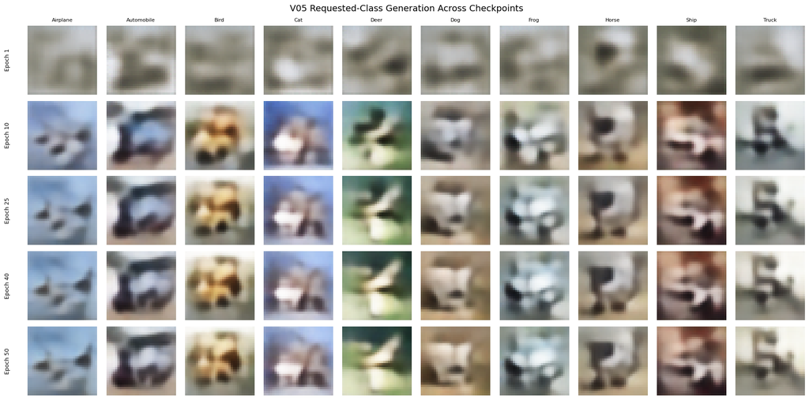

```
V05 checkpoint metrics saved to: artifacts\vae\V05\evaluation\V05_checkpoint_metrics.csv
V05 checkpoint grid saved to: artifacts\vae\V05\evaluation\V05_checkpoint_requested_class_grid.png
Final V05 weights restored: Yes
Model retrained: No
Official test-set usage: None
```

```python
# Evaluate V05 checkpoints using the established fixed inputs.
v05_artifact_dir = Path("artifacts") / "vae" / "V05"
v05_evaluation_dir = v05_artifact_dir / "evaluation"
v05_evaluation_dir.mkdir(parents=True, exist_ok=True)

fixed_inputs_dir = (
    Path("artifacts") / "vae" / "fixed_inputs"
)
fixed_latent_path_v05 = (
    fixed_inputs_dir / "fixed_latent_vectors_dim64.npy"
)
fixed_indices_path_v05 = (
    fixed_inputs_dir / "fixed_reconstruction_indices.npy"
)
fixed_label_ids_path_v05 = (
    fixed_inputs_dir
    / "V03_fixed_conditional_label_ids.npy"
)
fixed_one_hot_path_v05 = (
    fixed_inputs_dir
    / "V03_fixed_conditional_one_hot_labels.npy"
)
v05_history_path = (
    v05_artifact_dir / "V05_training_history.csv"
)
v05_final_weights_path = (
    v05_artifact_dir
    / "weights"
    / "V05_vae_final.weights.h5"
)

for required_path in [
    fixed_latent_path_v05,
    fixed_indices_path_v05,
    fixed_label_ids_path_v05,
    fixed_one_hot_path_v05,
    v05_history_path,
    v05_final_weights_path
]:
    assert required_path.exists(), (
        f"Required artefact not found: {required_path}"
    )

fixed_latent_vectors_v05 = np.load(
    fixed_latent_path_v05
).astype(np.float32)
fixed_reconstruction_indices_v05 = np.load(
    fixed_indices_path_v05
)
fixed_conditional_label_ids_v05 = np.load(
    fixed_label_ids_path_v05
)
fixed_conditional_labels_v05 = np.load(
    fixed_one_hot_path_v05
).astype(np.float32)

fixed_reconstruction_images_v05 = x_train_vae[
    fixed_reconstruction_indices_v05
]
fixed_reconstruction_labels_v05 = np.asarray(
    y_train[fixed_reconstruction_indices_v05]
).reshape(-1)
fixed_reconstruction_one_hot_v05 = (
    keras.utils.to_categorical(
        fixed_reconstruction_labels_v05,
        num_classes=V05_NUM_CLASSES
    ).astype(np.float32)
)

assert fixed_latent_vectors_v05.shape == (100, 64)
assert fixed_conditional_labels_v05.shape == (100, 10)
assert fixed_reconstruction_images_v05.shape == (
    20,
    32,
    32,
    3
)
assert fixed_reconstruction_one_hot_v05.shape == (20, 10)

# Indices 0, 10, ..., 90 provide one fixed latent
# vector for each requested class 0, 1, ..., 9.
class_preview_indices_v05 = np.arange(
    0,
    100,
    10,
    dtype=np.int64
)
assert np.array_equal(
    fixed_conditional_label_ids_v05[
        class_preview_indices_v05
    ],
    np.arange(V05_NUM_CLASSES)
)

v05_checkpoint_epochs = [1, 10, 25, 40, 50]
v05_history_for_evaluation = pd.read_csv(
    v05_history_path,
    index_col="epoch"
)
v05_checkpoint_records = []
v05_checkpoint_generated = {}

for checkpoint_epoch in v05_checkpoint_epochs:
    checkpoint_path = (
        v05_artifact_dir
        / "checkpoints"
        / (
            "V05_epoch_"
            f"{checkpoint_epoch:03d}"
            ".weights.h5"
        )
    )
    assert checkpoint_path.exists(), (
        f"V05 checkpoint not found: {checkpoint_path}"
    )
    vae_v05.load_weights(str(checkpoint_path))

    checkpoint_z_mean, _, _ = encoder_v05.predict(
        [
            fixed_reconstruction_images_v05,
            fixed_reconstruction_one_hot_v05
        ],
        verbose=0
    )
    checkpoint_reconstructions = np.clip(
        decoder_v05.predict(
            [
                checkpoint_z_mean,
                fixed_reconstruction_one_hot_v05
            ],
            verbose=0
        ),
        0.0,
        1.0
    )

    mse_per_image = np.mean(
        np.square(
            fixed_reconstruction_images_v05
            - checkpoint_reconstructions
        ),
        axis=(1, 2, 3)
    )
    mae_per_image = np.mean(
        np.abs(
            fixed_reconstruction_images_v05
            - checkpoint_reconstructions
        ),
        axis=(1, 2, 3)
    )
    psnr_per_image = tf.image.psnr(
        fixed_reconstruction_images_v05,
        checkpoint_reconstructions,
        max_val=1.0
    ).numpy()
    ssim_per_image = tf.image.ssim(
        fixed_reconstruction_images_v05,
        checkpoint_reconstructions,
        max_val=1.0
    ).numpy()

    checkpoint_generation = np.clip(
        decoder_v05.predict(
            [
                fixed_latent_vectors_v05[
                    class_preview_indices_v05
                ],
                fixed_conditional_labels_v05[
                    class_preview_indices_v05
                ]
            ],
            verbose=0
        ),
        0.0,
        1.0
    )
    v05_checkpoint_generated[checkpoint_epoch] = (
        checkpoint_generation
    )

    history_row = v05_history_for_evaluation.loc[
        checkpoint_epoch
    ]
    v05_checkpoint_records.append({
        "epoch": checkpoint_epoch,
        "training_total_loss": history_row[
            "total_loss"
        ],
        "training_reconstruction_loss": history_row[
            "reconstruction_loss"
        ],
        "training_l1_reconstruction_loss": history_row[
            "l1_reconstruction_loss"
        ],
        "training_ssim_dissimilarity": history_row[
            "ssim_dissimilarity"
        ],
        "training_scaled_ssim_loss": history_row[
            "scaled_ssim_loss"
        ],
        "unweighted_kl_loss": history_row[
            "kl_loss"
        ],
        "training_pixel_mse": history_row[
            "pixel_mse"
        ],
        "reconstruction_mse": mse_per_image.mean(),
        "reconstruction_mae": mae_per_image.mean(),
        "reconstruction_psnr_db": psnr_per_image.mean(),
        "reconstruction_ssim": ssim_per_image.mean()
    })

# Restore the saved final V05 state after inspecting
# intermediate checkpoints.
vae_v05.load_weights(str(v05_final_weights_path))

v05_checkpoint_metrics_df = pd.DataFrame(
    v05_checkpoint_records
).set_index("epoch")
assert np.isfinite(
    v05_checkpoint_metrics_df.to_numpy()
).all()

v05_checkpoint_metrics_path = (
    v05_evaluation_dir / "V05_checkpoint_metrics.csv"
)
v05_checkpoint_metrics_df.to_csv(
    v05_checkpoint_metrics_path
)

print("V05 fixed-input checkpoint metrics:")
display(v05_checkpoint_metrics_df.round(5))

fig, axes = plt.subplots(
    len(v05_checkpoint_epochs),
    V05_NUM_CLASSES,
    figsize=(18, 9)
)
for row_index, checkpoint_epoch in enumerate(
    v05_checkpoint_epochs
):
    for class_id, class_name in enumerate(class_names):
        axes[row_index, class_id].imshow(
            v05_checkpoint_generated[
                checkpoint_epoch
            ][class_id]
        )
        axes[row_index, class_id].axis("off")
        if row_index == 0:
            axes[row_index, class_id].set_title(
                class_name,
                fontsize=8
            )
    axes[row_index, 0].text(
        -0.25,
        0.5,
        f"Epoch {checkpoint_epoch}",
        transform=axes[row_index, 0].transAxes,
        rotation=90,
        va="center",
        ha="right",
        fontsize=9
    )

fig.suptitle(
    "V05 Requested-Class Generation Across Checkpoints",
    fontsize=14
)
plt.tight_layout()
v05_checkpoint_grid_path = (
    v05_evaluation_dir
    / "V05_checkpoint_requested_class_grid.png"
)
plt.savefig(
    v05_checkpoint_grid_path,
    dpi=150,
    bbox_inches="tight"
)
plt.show()

print(
    "V05 checkpoint metrics saved to: "
    f"{v05_checkpoint_metrics_path}"
)
print(
    "V05 checkpoint grid saved to: "
    f"{v05_checkpoint_grid_path}"
)
print("Final V05 weights restored: Yes")
print("Model retrained: No")
print("Official test-set usage: None")
```

#### Executed Checkpoint Findings

V05 learned rapidly and then converged smoothly. From epoch 1 to epoch 50, fixed reconstruction MSE fell from `0.01757` to `0.00652`, MAE fell from `0.10058` to `0.05709`, PSNR increased from `17.908` to `22.549` dB, and SSIM increased from `0.47883` to `0.75636`.

The final two milestones were effectively at the same reconstruction level. Epoch 40 recorded MSE `0.00653`, PSNR `22.547` dB and SSIM `0.75750`; epoch 50 recorded MSE `0.00652`, PSNR `22.549` dB and SSIM `0.75636`. The slight SSIM decrease is small and does not indicate instability.

The uncurated requested-class grid shows its largest change by epoch 10. Images from epochs 25-50 preserve very similar compositions with smaller colour and structural refinements. V05 therefore converged stably, but the checkpoint evidence does not show a late qualitative breakthrough over the V04 family.

### 10.6 Final Controlled Comparison - V04 versus V05

V04 is the immediate parent and current conditional incumbent. The following saved-weight comparison changes no model and performs no retraining.

V04 and V05 are evaluated using:

1. the same 20 fixed training reconstructions and true labels;
2. the same 100 standard-normal latent vectors and balanced requested labels;
3. MSE, MAE, PSNR, SSIM and reconstruction edge strength;
4. matched brightness, contrast, colour, saturation and generated-edge descriptors;
5. exact uniqueness, overall diversity and within-class diversity;
6. same-`z`, different-label and wrong-label reconstruction diagnostics;
7. matched latent-posterior statistics; and
8. uncurated reconstruction and generation grids.

V05 will not be accepted from its slightly lower training loss alone. The complete evidence must show whether AdamW improves the V04 quality-diversity-conditioning trade-off enough to justify its additional runtime.

```python
from hashlib import sha256


V05_EVALUATION_NUM_CLASSES = 10
V05_EVALUATION_SAMPLE_COUNT = 100

v05_evaluation_dir = (
    Path("artifacts")
    / "vae"
    / "V05"
    / "evaluation"
)
v05_evaluation_dir.mkdir(
    parents=True,
    exist_ok=True
)

v04_encoder_weights_for_v05_comparison = (
    Path("artifacts")
    / "vae"
    / "V04"
    / "weights"
    / "V04_encoder_final.weights.h5"
)
v04_decoder_weights_for_v05_comparison = (
    Path("artifacts")
    / "vae"
    / "V04"
    / "weights"
    / "V04_decoder_final.weights.h5"
)
v05_encoder_weights_for_comparison = (
    Path("artifacts")
    / "vae"
    / "V05"
    / "weights"
    / "V05_encoder_final.weights.h5"
)
v05_decoder_weights_for_comparison = (
    Path("artifacts")
    / "vae"
    / "V05"
    / "weights"
    / "V05_decoder_final.weights.h5"
)

fixed_inputs_dir_v05 = (
    Path("artifacts")
    / "vae"
    / "fixed_inputs"
)
fixed_reconstruction_indices_path_v05 = (
    fixed_inputs_dir_v05
    / "fixed_reconstruction_indices.npy"
)
fixed_latent_vectors_path_v05 = (
    fixed_inputs_dir_v05
    / "fixed_latent_vectors_dim64.npy"
)
fixed_label_ids_path_v05 = (
    fixed_inputs_dir_v05
    / "V03_fixed_conditional_label_ids.npy"
)
fixed_one_hot_labels_path_v05 = (
    fixed_inputs_dir_v05
    / "V03_fixed_conditional_one_hot_labels.npy"
)

v05_required_comparison_paths = [
    v04_encoder_weights_for_v05_comparison,
    v04_decoder_weights_for_v05_comparison,
    v05_encoder_weights_for_comparison,
    v05_decoder_weights_for_comparison,
    fixed_reconstruction_indices_path_v05,
    fixed_latent_vectors_path_v05,
    fixed_label_ids_path_v05,
    fixed_one_hot_labels_path_v05
]

for required_path in (
    v05_required_comparison_paths
):
    assert required_path.exists(), (
        "Required matched-evaluation "
        f"artefact missing: {required_path}"
    )


def v05_file_sha256(file_path):
    digest = sha256()
    with Path(file_path).open("rb") as file:
        for block in iter(
            lambda: file.read(1024 * 1024),
            b""
        ):
            digest.update(block)
    return digest.hexdigest()


v04_weight_hashes_before_v05_evaluation = {
    "encoder": v05_file_sha256(
        v04_encoder_weights_for_v05_comparison
    ),
    "decoder": v05_file_sha256(
        v04_decoder_weights_for_v05_comparison
    )
}

# Rebuild the frozen V04 architecture locally.
# This avoids depending on an earlier in-memory
# encoder_v04 or decoder_v04 object. No training occurs.
class V04EvaluationSampling(layers.Layer):
    def call(self, inputs):
        z_mean, z_log_var = inputs
        batch_size = tf.shape(z_mean)[0]
        latent_dimension = tf.shape(
            z_mean
        )[1]
        epsilon = tf.random.normal(
            shape=(
                batch_size,
                latent_dimension
            )
        )
        return (
            z_mean
            + tf.exp(
                0.5 * z_log_var
            )
            * epsilon
        )


v04_evaluation_image_input = keras.Input(
    shape=(32, 32, 3),
    name="V04_eval_encoder_image_input"
)
v04_evaluation_encoder_label_input = (
    keras.Input(
        shape=(10,),
        name="V04_eval_encoder_label_input"
    )
)

v04_evaluation_x = layers.Conv2D(
    32,
    kernel_size=3,
    strides=2,
    padding="same",
    activation="relu",
    name="V04_eval_encoder_conv_1"
)(v04_evaluation_image_input)
v04_evaluation_x = layers.Conv2D(
    64,
    kernel_size=3,
    strides=2,
    padding="same",
    activation="relu",
    name="V04_eval_encoder_conv_2"
)(v04_evaluation_x)
v04_evaluation_x = layers.Conv2D(
    128,
    kernel_size=3,
    strides=2,
    padding="same",
    activation="relu",
    name="V04_eval_encoder_conv_3"
)(v04_evaluation_x)
v04_evaluation_x = layers.Flatten(
    name="V04_eval_encoder_flatten"
)(v04_evaluation_x)
v04_evaluation_x = layers.Concatenate(
    name=(
        "V04_eval_encoder_feature_"
        "label_concat"
    )
)([
    v04_evaluation_x,
    v04_evaluation_encoder_label_input
])
v04_evaluation_x = layers.Dense(
    256,
    activation="relu",
    name="V04_eval_encoder_dense"
)(v04_evaluation_x)

v04_evaluation_z_mean = layers.Dense(
    64,
    name="V04_eval_z_mean"
)(v04_evaluation_x)
v04_evaluation_z_log_var = layers.Dense(
    64,
    name="V04_eval_z_log_var"
)(v04_evaluation_x)
v04_evaluation_z = V04EvaluationSampling(
    name="V04_eval_z_sampling"
)([
    v04_evaluation_z_mean,
    v04_evaluation_z_log_var
])

encoder_v04 = keras.Model(
    inputs=[
        v04_evaluation_image_input,
        v04_evaluation_encoder_label_input
    ],
    outputs=[
        v04_evaluation_z_mean,
        v04_evaluation_z_log_var,
        v04_evaluation_z
    ],
    name="V04_evaluation_encoder"
)

v04_evaluation_latent_input = keras.Input(
    shape=(64,),
    name="V04_eval_decoder_latent_input"
)
v04_evaluation_decoder_label_input = (
    keras.Input(
        shape=(10,),
        name="V04_eval_decoder_label_input"
    )
)

v04_evaluation_y = layers.Concatenate(
    name=(
        "V04_eval_decoder_latent_"
        "label_concat"
    )
)([
    v04_evaluation_latent_input,
    v04_evaluation_decoder_label_input
])
v04_evaluation_y = layers.Dense(
    4 * 4 * 128,
    activation="relu",
    name="V04_eval_decoder_dense"
)(v04_evaluation_y)
v04_evaluation_y = layers.Reshape(
    (4, 4, 128),
    name="V04_eval_decoder_reshape"
)(v04_evaluation_y)
v04_evaluation_y = layers.Conv2DTranspose(
    128,
    kernel_size=3,
    strides=2,
    padding="same",
    activation="relu",
    name="V04_eval_decoder_deconv_1"
)(v04_evaluation_y)
v04_evaluation_y = layers.Conv2DTranspose(
    64,
    kernel_size=3,
    strides=2,
    padding="same",
    activation="relu",
    name="V04_eval_decoder_deconv_2"
)(v04_evaluation_y)
v04_evaluation_y = layers.Conv2DTranspose(
    32,
    kernel_size=3,
    strides=2,
    padding="same",
    activation="relu",
    name="V04_eval_decoder_deconv_3"
)(v04_evaluation_y)
v04_evaluation_decoder_output = (
    layers.Conv2D(
        3,
        kernel_size=3,
        padding="same",
        activation="sigmoid",
        name="V04_eval_decoder_output"
    )(v04_evaluation_y)
)
```

```python
decoder_v04 = keras.Model(
    inputs=[
        v04_evaluation_latent_input,
        v04_evaluation_decoder_label_input
    ],
    outputs=(
        v04_evaluation_decoder_output
    ),
    name="V04_evaluation_decoder"
)

assert (
    encoder_v04.count_params()
    == 653_248
)
assert (
    decoder_v04.count_params()
    == 394_307
)

# Load final frozen weights only; no fit call occurs.
encoder_v04.load_weights(
    str(
        v04_encoder_weights_for_v05_comparison
    )
)
decoder_v04.load_weights(
    str(
        v04_decoder_weights_for_v05_comparison
    )
)
encoder_v05.load_weights(
    str(
        v05_encoder_weights_for_comparison
    )
)
decoder_v05.load_weights(
    str(
        v05_decoder_weights_for_comparison
    )
)

v05_fixed_reconstruction_indices = np.load(
    fixed_reconstruction_indices_path_v05
)
v05_fixed_reconstruction_images = (
    x_train_vae[
        v05_fixed_reconstruction_indices
    ]
)
v05_fixed_reconstruction_label_ids = (
    y_train[
        v05_fixed_reconstruction_indices
    ]
)
v05_fixed_reconstruction_one_hot = (
    keras.utils.to_categorical(
        v05_fixed_reconstruction_label_ids,
        num_classes=(
            V05_EVALUATION_NUM_CLASSES
        )
    ).astype(np.float32)
)

v05_fixed_latent_vectors = np.load(
    fixed_latent_vectors_path_v05
).astype(np.float32)
v05_fixed_requested_label_ids = np.load(
    fixed_label_ids_path_v05
).astype(np.int64)
v05_fixed_requested_one_hot = np.load(
    fixed_one_hot_labels_path_v05
).astype(np.float32)

assert (
    v05_fixed_reconstruction_images.shape
    == (20, 32, 32, 3)
)
assert (
    v05_fixed_reconstruction_one_hot.shape
    == (20, 10)
)
assert (
    v05_fixed_latent_vectors.shape
    == (100, 64)
)
assert (
    v05_fixed_requested_one_hot.shape
    == (100, 10)
)
assert np.array_equal(
    np.bincount(
        v05_fixed_requested_label_ids,
        minlength=10
    ),
    np.full(10, 10)
)

# -------------------------------------------------------
# 1. Deterministic reconstruction comparison
# -------------------------------------------------------
v04_z_mean_for_v05_comparison, _, _ = (
    encoder_v04.predict(
        [
            v05_fixed_reconstruction_images,
            v05_fixed_reconstruction_one_hot
        ],
        verbose=0
    )
)
v05_z_mean_for_comparison, _, _ = (
    encoder_v05.predict(
        [
            v05_fixed_reconstruction_images,
            v05_fixed_reconstruction_one_hot
        ],
        verbose=0
    )
)

v04_reconstructions_for_v05_comparison = (
    np.clip(
        decoder_v04.predict(
            [
                v04_z_mean_for_v05_comparison,
                v05_fixed_reconstruction_one_hot
            ],
            verbose=0
        ),
        0.0,
        1.0
    )
)
v05_reconstructions_for_comparison = (
    np.clip(
        decoder_v05.predict(
            [
                v05_z_mean_for_comparison,
                v05_fixed_reconstruction_one_hot
            ],
            verbose=0
        ),
        0.0,
        1.0
    )
)


def v05_edge_strength_per_image(
    image_batch
):
    horizontal_difference = np.abs(
        np.diff(
            image_batch,
            axis=2
        )
    ).mean(axis=(1, 2, 3))
    vertical_difference = np.abs(
        np.diff(
            image_batch,
            axis=1
        )
    ).mean(axis=(1, 2, 3))
    return (
        horizontal_difference
        + vertical_difference
    ) / 2.0


def v05_reconstruction_metric_arrays(
    originals,
    reconstructions
):
    mse_values = np.mean(
        np.square(
            originals - reconstructions
        ),
        axis=(1, 2, 3)
    )
    mae_values = np.mean(
        np.abs(
            originals - reconstructions
        ),
        axis=(1, 2, 3)
    )
    psnr_values = tf.image.psnr(
        originals,
        reconstructions,
        max_val=1.0
    ).numpy()
    ssim_values = tf.image.ssim(
        originals,
        reconstructions,
        max_val=1.0
    ).numpy()

    original_edges = (
        v05_edge_strength_per_image(
            originals
        )
    )
    reconstructed_edges = (
        v05_edge_strength_per_image(
            reconstructions
        )
    )
    edge_gap_values = np.abs(
        original_edges
        - reconstructed_edges
    )

    return {
        "mse": mse_values,
        "mae": mae_values,
        "psnr_db": psnr_values,
        "ssim": ssim_values,
        "edge_strength": (
            reconstructed_edges
        ),
        "absolute_edge_gap": (
            edge_gap_values
        )
    }


v04_reconstruction_metrics_for_v05 = (
    v05_reconstruction_metric_arrays(
        v05_fixed_reconstruction_images,
        (
            v04_reconstructions_for_v05_comparison
        )
    )
)
v05_reconstruction_metrics = (
    v05_reconstruction_metric_arrays(
        v05_fixed_reconstruction_images,
        v05_reconstructions_for_comparison
    )
)

v04_v05_reconstruction_rows = []
for (
    metric_name,
    direction
) in [
    ("mse", "lower_is_better"),
    ("mae", "lower_is_better"),
    ("psnr_db", "higher_is_better"),
    ("ssim", "higher_is_better"),
    (
        "edge_strength",
        "descriptive_only"
    ),
    (
        "absolute_edge_gap",
        "lower_is_better"
    )
]:
    v04_value = float(
        np.mean(
            v04_reconstruction_metrics_for_v05[
                metric_name
            ]
        )
    )
    v05_value = float(
        np.mean(
            v05_reconstruction_metrics[
                metric_name
            ]
        )
    )
    v04_v05_reconstruction_rows.append({
        "metric": metric_name,
        "direction": direction,
        "V04": v04_value,
        "V05": v05_value,
        "V05_minus_V04": (
            v05_value - v04_value
        )
    })

v04_v05_reconstruction_df = (
    pd.DataFrame(
        v04_v05_reconstruction_rows
    ).set_index("metric")
)

print(
    "Matched V04-versus-V05 fixed "
    "reconstruction metrics:"
)
display(
    v04_v05_reconstruction_df.round(6)
)
```

```python
v04_v05_per_class_rows = []
for class_id, class_name in enumerate(
    class_names
):
    class_mask = (
        v05_fixed_reconstruction_label_ids
        == class_id
    )
    v04_v05_per_class_rows.append({
        "class_name": class_name,
        "V04_mse": float(
            v04_reconstruction_metrics_for_v05[
                "mse"
            ][class_mask].mean()
        ),
        "V05_mse": float(
            v05_reconstruction_metrics[
                "mse"
            ][class_mask].mean()
        ),
        "V04_ssim": float(
            v04_reconstruction_metrics_for_v05[
                "ssim"
            ][class_mask].mean()
        ),
        "V05_ssim": float(
            v05_reconstruction_metrics[
                "ssim"
            ][class_mask].mean()
        ),
        "V04_absolute_edge_gap": float(
            v04_reconstruction_metrics_for_v05[
                "absolute_edge_gap"
            ][class_mask].mean()
        ),
        "V05_absolute_edge_gap": float(
            v05_reconstruction_metrics[
                "absolute_edge_gap"
            ][class_mask].mean()
        )
    })

v04_v05_per_class_reconstruction_df = (
    pd.DataFrame(
        v04_v05_per_class_rows
    ).set_index("class_name")
)

print(
    "\nPer-class fixed reconstruction "
    "metrics:"
)
display(
    v04_v05_per_class_reconstruction_df
    .round(6)
)

v04_v05_reconstruction_path = (
    v05_evaluation_dir
    / "V04_V05_reconstruction_metrics.csv"
)
v04_v05_per_class_reconstruction_path = (
    v05_evaluation_dir
    / (
        "V04_V05_per_class_"
        "reconstruction_metrics.csv"
    )
)
v04_v05_reconstruction_df.to_csv(
    v04_v05_reconstruction_path
)
v04_v05_per_class_reconstruction_df.to_csv(
    v04_v05_per_class_reconstruction_path
)

fig, axes = plt.subplots(
    6,
    10,
    figsize=(18, 11)
)
v04_v05_reconstruction_row_labels = [
    "Original 1",
    "V04 1",
    "V05 1",
    "Original 2",
    "V04 2",
    "V05 2"
]

for class_id, class_name in enumerate(
    class_names
):
    first_position = class_id * 2
    second_position = first_position + 1
    image_sequence = [
        v05_fixed_reconstruction_images[
            first_position
        ],
        v04_reconstructions_for_v05_comparison[
            first_position
        ],
        v05_reconstructions_for_comparison[
            first_position
        ],
        v05_fixed_reconstruction_images[
            second_position
        ],
        v04_reconstructions_for_v05_comparison[
            second_position
        ],
        v05_reconstructions_for_comparison[
            second_position
        ]
    ]

    for row_index, image_value in enumerate(
        image_sequence
    ):
        axis = axes[row_index, class_id]
        axis.imshow(image_value)
        axis.axis("off")

        if class_id == 0:
            axis.text(
                -0.2,
                0.5,
                (
                    v04_v05_reconstruction_row_labels[
                        row_index
                    ]
                ),
                transform=axis.transAxes,
                rotation=90,
                va="center",
                ha="right",
                fontsize=9
            )

    axes[0, class_id].set_title(
        class_name,
        fontsize=9
    )

fig.suptitle(
    "Matched Fixed Reconstructions: "
    "V04 versus V05",
    fontsize=14
)
plt.tight_layout()

v04_v05_reconstruction_grid_path = (
    v05_evaluation_dir
    / "V04_V05_reconstruction_grid.png"
)
plt.savefig(
    v04_v05_reconstruction_grid_path,
    dpi=150,
    bbox_inches="tight"
)
plt.show()

# -------------------------------------------------------
# 2. Same-latent balanced generation
# -------------------------------------------------------
v04_generated_for_v05_comparison = (
    np.clip(
        decoder_v04.predict(
            [
                v05_fixed_latent_vectors,
                v05_fixed_requested_one_hot
            ],
            verbose=0
        ),
        0.0,
        1.0
    )
)
v05_generated_for_comparison = (
    np.clip(
        decoder_v05.predict(
            [
                v05_fixed_latent_vectors,
                v05_fixed_requested_one_hot
            ],
            verbose=0
        ),
        0.0,
        1.0
    )
)

v04_generated_uint8_for_v05 = np.rint(
    v04_generated_for_v05_comparison
    * 255.0
).astype(np.uint8)
v05_generated_uint8 = np.rint(
    v05_generated_for_comparison
    * 255.0
).astype(np.uint8)

v05_fixed_generated_samples_path = (
    v05_evaluation_dir
    / "V05_fixed_requested_samples.npy"
)
np.save(
    v05_fixed_generated_samples_path,
    v05_generated_uint8
)

fig, axes = plt.subplots(
    10,
    20,
    figsize=(28, 14)
)

for class_id, class_name in enumerate(
    class_names
):
    class_start = class_id * 10

    for draw_index in range(10):
        v04_axis = axes[
            class_id,
            draw_index
        ]
        v05_axis = axes[
            class_id,
            10 + draw_index
        ]

        v04_axis.imshow(
            v04_generated_for_v05_comparison[
                class_start + draw_index
            ]
        )
        v05_axis.imshow(
            v05_generated_for_comparison[
                class_start + draw_index
            ]
        )
        v04_axis.axis("off")
        v05_axis.axis("off")

        if class_id == 0:
            v04_axis.set_title(
                f"V04 d{draw_index + 1}",
                fontsize=8
            )
            v05_axis.set_title(
                f"V05 d{draw_index + 1}",
                fontsize=8
            )

        if draw_index == 0:
            v04_axis.text(
                -0.25,
                0.5,
                class_name,
                transform=v04_axis.transAxes,
                rotation=90,
                va="center",
                ha="right",
                fontsize=9
            )

fig.suptitle(
    "Same Latents and Requested Labels: "
    "V04 versus V05",
    fontsize=14
)
plt.tight_layout()
```

```python
v04_v05_generation_grid_path = (
    v05_evaluation_dir
    / "V04_V05_same_latent_generation_grid.png"
)
plt.savefig(
    v04_v05_generation_grid_path,
    dpi=150,
    bbox_inches="tight"
)
plt.show()

# -------------------------------------------------------
# 3. Shared descriptors and diversity
# -------------------------------------------------------
v05_descriptor_rng = np.random.default_rng(
    SEED + 100
)
v05_reference_indices = []

for class_id in range(
    V05_EVALUATION_NUM_CLASSES
):
    class_indices = np.where(
        y_train == class_id
    )[0]
    v05_reference_indices.extend(
        v05_descriptor_rng.choice(
            class_indices,
            size=100,
            replace=False
        )
    )

v05_reference_indices = np.array(
    v05_reference_indices
)
v05_reference_images = x_train_vae[
    v05_reference_indices
]
v05_reference_labels = y_train[
    v05_reference_indices
]


def v05_comparison_descriptors(
    image_batch
):
    horizontal_difference = np.abs(
        np.diff(
            image_batch,
            axis=2
        )
    ).mean(axis=(1, 2, 3))
    vertical_difference = np.abs(
        np.diff(
            image_batch,
            axis=1
        )
    ).mean(axis=(1, 2, 3))

    return pd.DataFrame({
        "brightness": image_batch.mean(
            axis=(1, 2, 3)
        ),
        "contrast": image_batch.std(
            axis=(1, 2, 3)
        ),
        "red_mean": image_batch[
            :, :, :, 0
        ].mean(axis=(1, 2)),
        "green_mean": image_batch[
            :, :, :, 1
        ].mean(axis=(1, 2)),
        "blue_mean": image_batch[
            :, :, :, 2
        ].mean(axis=(1, 2)),
        "saturation": (
            image_batch.max(axis=3)
            - image_batch.min(axis=3)
        ).mean(axis=(1, 2)),
        "edge_strength": (
            horizontal_difference
            + vertical_difference
        ) / 2.0
    })


v05_reference_descriptors = (
    v05_comparison_descriptors(
        v05_reference_images
    )
)
v04_descriptors_for_v05 = (
    v05_comparison_descriptors(
        v04_generated_for_v05_comparison
    )
)
v05_descriptors = (
    v05_comparison_descriptors(
        v05_generated_for_comparison
    )
)

v04_v05_descriptor_rows = []
for descriptor_name in (
    v05_reference_descriptors.columns
):
    training_mean = float(
        v05_reference_descriptors[
            descriptor_name
        ].mean()
    )
    v04_mean = float(
        v04_descriptors_for_v05[
            descriptor_name
        ].mean()
    )
    v05_mean = float(
        v05_descriptors[
            descriptor_name
        ].mean()
    )
    v04_gap = abs(
        v04_mean - training_mean
    )
    v05_gap = abs(
        v05_mean - training_mean
    )

    v04_v05_descriptor_rows.append({
        "descriptor": descriptor_name,
        "training_mean": training_mean,
        "V04_mean": v04_mean,
        "V05_mean": v05_mean,
        "V04_absolute_gap": v04_gap,
        "V05_absolute_gap": v05_gap,
        "gap_improvement_V05_vs_V04": (
            v04_gap - v05_gap
        )
    })

v04_v05_descriptor_df = (
    pd.DataFrame(
        v04_v05_descriptor_rows
    ).set_index("descriptor")
)

print(
    "\nMatched generated-image "
    "descriptor comparison:"
)
display(
    v04_v05_descriptor_df.round(6)
)

v04_v05_descriptor_path = (
    v05_evaluation_dir
    / "V04_V05_descriptor_comparison.csv"
)
v04_v05_descriptor_df.to_csv(
    v04_v05_descriptor_path
)


def v05_per_class_diversity_record(
    generated_float,
    generated_uint8,
    label_ids
):
    unique_counts = []
    pixel_diversities = []

    for class_id in range(
        V05_EVALUATION_NUM_CLASSES
    ):
        class_mask = (
            label_ids == class_id
        )
        class_float = generated_float[
            class_mask
        ]
        class_uint8 = generated_uint8[
            class_mask
        ]
        unique_counts.append(
            len(
                np.unique(
                    class_uint8.reshape(
                        len(class_uint8),
                        -1
                    ),
                    axis=0
                )
            )
        )
        pixel_diversities.append(
            np.mean(
                np.std(
                    class_float,
                    axis=0
                )
            )
        )

    return (
        np.array(unique_counts),
        np.array(pixel_diversities)
    )


(
    v04_unique_per_class_for_v05,
    v04_pixel_diversity_per_class_for_v05
) = v05_per_class_diversity_record(
    v04_generated_for_v05_comparison,
    v04_generated_uint8_for_v05,
    v05_fixed_requested_label_ids
)
(
    v05_unique_per_class,
    v05_pixel_diversity_per_class
) = v05_per_class_diversity_record(
    v05_generated_for_comparison,
    v05_generated_uint8,
    v05_fixed_requested_label_ids
)

v04_v05_diversity_df = pd.DataFrame(
    {
        "V04": [
            len(
                np.unique(
                    v04_generated_uint8_for_v05
                    .reshape(100, -1),
                    axis=0
                )
            ),
            np.mean(
                np.std(
                    v04_generated_for_v05_comparison,
                    axis=0
                )
            ),
            int(
                v04_unique_per_class_for_v05.min()
            ),
            float(
                v04_pixel_diversity_per_class_for_v05
                .mean()
            )
        ],
        "V05": [
            len(
                np.unique(
                    v05_generated_uint8.reshape(
                        100,
                        -1
                    ),
                    axis=0
                )
            ),
            np.mean(
                np.std(
                    v05_generated_for_comparison,
                    axis=0
                )
            ),
            int(
                v05_unique_per_class.min()
            ),
            float(
                v05_pixel_diversity_per_class.mean()
            )
        ],
        "Training_reference": [
            np.nan,
            np.mean(
                np.std(
                    v05_reference_images,
                    axis=0
                )
            ),
            np.nan,
            np.nan
        ]
    },
    index=[
        "unique_uint8_images_out_of_100",
        "mean_pixel_standard_deviation",
        "minimum_unique_images_per_class_out_of_10",
        "mean_within_class_pixel_standard_deviation"
    ]
)
```

```python
print(
    "\nMatched generated diversity "
    "comparison:"
)
display(
    v04_v05_diversity_df.round(6)
)

v04_v05_diversity_path = (
    v05_evaluation_dir
    / "V04_V05_diversity_comparison.csv"
)
v04_v05_diversity_df.to_csv(
    v04_v05_diversity_path
)

# -------------------------------------------------------
# 4. Same-z label control and counterfactual check
# -------------------------------------------------------
def v05_conditional_control_evaluation(
    decoder_model,
    posterior_means,
    originals,
    true_label_ids,
    shared_latents,
    num_classes
):
    latent_count = len(shared_latents)
    intervention_latents = np.tile(
        shared_latents,
        (num_classes, 1)
    )
    intervention_label_ids = np.repeat(
        np.arange(num_classes),
        latent_count
    )
    intervention_one_hot = (
        keras.utils.to_categorical(
            intervention_label_ids,
            num_classes=num_classes
        ).astype(np.float32)
    )

    intervention_images = np.clip(
        decoder_model.predict(
            [
                intervention_latents,
                intervention_one_hot
            ],
            verbose=0
        ),
        0.0,
        1.0
    ).reshape(
        num_classes,
        latent_count,
        32,
        32,
        3
    )

    class_centroids = (
        intervention_images.mean(axis=1)
    )
    global_centroid = (
        class_centroids.mean(axis=0)
    )
    within_class_variance = np.mean(
        np.square(
            intervention_images
            - class_centroids[:, None]
        )
    )
    between_class_variance = np.mean(
        np.square(
            class_centroids
            - global_centroid
        )
    )
    separation_ratio = (
        between_class_variance
        / within_class_variance
    )

    pairwise_label_mae = []
    for latent_index in range(
        latent_count
    ):
        for first_class in range(
            num_classes
        ):
            for second_class in range(
                first_class + 1,
                num_classes
            ):
                pairwise_label_mae.append(
                    np.mean(
                        np.abs(
                            intervention_images[
                                first_class,
                                latent_index
                            ]
                            - intervention_images[
                                second_class,
                                latent_index
                            ]
                        )
                    )
                )

    counterfactual_mse = np.empty(
        (
            len(originals),
            num_classes
        ),
        dtype=np.float32
    )

    for candidate_class in range(
        num_classes
    ):
        candidate_one_hot = (
            keras.utils.to_categorical(
                np.full(
                    len(originals),
                    candidate_class
                ),
                num_classes=num_classes
            ).astype(np.float32)
        )
        candidate_reconstructions = (
            np.clip(
                decoder_model.predict(
                    [
                        posterior_means,
                        candidate_one_hot
                    ],
                    verbose=0
                ),
                0.0,
                1.0
            )
        )
        counterfactual_mse[
            :,
            candidate_class
        ] = np.mean(
            np.square(
                originals
                - candidate_reconstructions
            ),
            axis=(1, 2, 3)
        )

    true_label_mse = counterfactual_mse[
        np.arange(len(originals)),
        true_label_ids
    ]
    wrong_label_mask = np.ones_like(
        counterfactual_mse,
        dtype=bool
    )
    wrong_label_mask[
        np.arange(len(originals)),
        true_label_ids
    ] = False
    mean_wrong_label_mse = (
        counterfactual_mse[
            wrong_label_mask
        ].reshape(
            len(originals),
            num_classes - 1
        ).mean(axis=1)
    )

    metrics = {
        (
            "mean_pairwise_mae_between_"
            "labels_same_z"
        ): float(
            np.mean(pairwise_label_mae)
        ),
        (
            "within_requested_class_"
            "pixel_variance"
        ): float(within_class_variance),
        (
            "between_requested_class_"
            "centroid_variance"
        ): float(between_class_variance),
        (
            "between_to_within_"
            "variance_ratio"
        ): float(separation_ratio),
        (
            "mean_true_label_"
            "reconstruction_mse"
        ): float(true_label_mse.mean()),
        (
            "mean_wrong_label_"
            "reconstruction_mse"
        ): float(mean_wrong_label_mse.mean()),
        (
            "fraction_true_mse_below_"
            "mean_wrong_mse"
        ): float(
            np.mean(
                true_label_mse
                < mean_wrong_label_mse
            )
        ),
        (
            "fraction_true_label_"
            "lowest_mse_of_10"
        ): float(
            np.mean(
                np.argmin(
                    counterfactual_mse,
                    axis=1
                )
                == true_label_ids
            )
        )
    }

    return metrics, intervention_images


v05_shared_control_latents = (
    v05_fixed_latent_vectors[:10]
)

(
    v04_control_metrics_for_v05,
    v04_control_images_for_v05
) = v05_conditional_control_evaluation(
    decoder_model=decoder_v04,
    posterior_means=(
        v04_z_mean_for_v05_comparison
    ),
    originals=(
        v05_fixed_reconstruction_images
    ),
    true_label_ids=(
        v05_fixed_reconstruction_label_ids
    ),
    shared_latents=(
        v05_shared_control_latents
    ),
    num_classes=(
        V05_EVALUATION_NUM_CLASSES
    )
)

(
    v05_control_metrics,
    v05_control_images
) = v05_conditional_control_evaluation(
    decoder_model=decoder_v05,
    posterior_means=(
        v05_z_mean_for_comparison
    ),
    originals=(
        v05_fixed_reconstruction_images
    ),
    true_label_ids=(
        v05_fixed_reconstruction_label_ids
    ),
    shared_latents=(
        v05_shared_control_latents
    ),
    num_classes=(
        V05_EVALUATION_NUM_CLASSES
    )
)
```

```
Matched V04-versus-V05 fixed reconstruction metrics:
```

| metric | direction | V04 | V05 | V05_minus_V04 |
| --- | --- | --- | --- | --- |
| mse | lower_is_better | 0.006570 | 0.006523 | -0.000046 |
| mae | lower_is_better | 0.057916 | 0.057085 | -0.000830 |
| psnr_db | higher_is_better | 22.450420 | 22.549173 | 0.098753 |
| ssim | higher_is_better | 0.757548 | 0.756356 | -0.001192 |
| edge_strength | descriptive_only | 0.032852 | 0.032748 | -0.000105 |
| absolute_edge_gap | lower_is_better | 0.023499 | 0.023603 | 0.000105 |

```
Per-class fixed reconstruction metrics:
```

| class_name | V04_mse | V05_mse | V04_ssim | V05_ssim | V04_absolute_edge_gap | V05_absolute_edge_gap |
| --- | --- | --- | --- | --- | --- | --- |
| Airplane | 0.007914 | 0.008194 | 0.778953 | 0.780812 | 0.019704 | 0.018747 |
| Automobile | 0.006975 | 0.007052 | 0.758948 | 0.755223 | 0.024678 | 0.024908 |
| Bird | 0.005435 | 0.005248 | 0.818492 | 0.821707 | 0.015982 | 0.015741 |
| Cat | 0.007112 | 0.007138 | 0.794829 | 0.793905 | 0.026081 | 0.025940 |
| Deer | 0.007756 | 0.007706 | 0.700802 | 0.696543 | 0.029449 | 0.031216 |
| Dog | 0.007120 | 0.006971 | 0.738844 | 0.726641 | 0.028972 | 0.028679 |
| Frog | 0.007378 | 0.007342 | 0.667871 | 0.666407 | 0.037304 | 0.037666 |
| Horse | 0.006714 | 0.006591 | 0.781638 | 0.792915 | 0.019516 | 0.017900 |
| Ship | 0.002635 | 0.002445 | 0.850520 | 0.857345 | 0.009398 | 0.009592 |
| Truck | 0.006658 | 0.006547 | 0.684580 | 0.672061 | 0.023904 | 0.025645 |

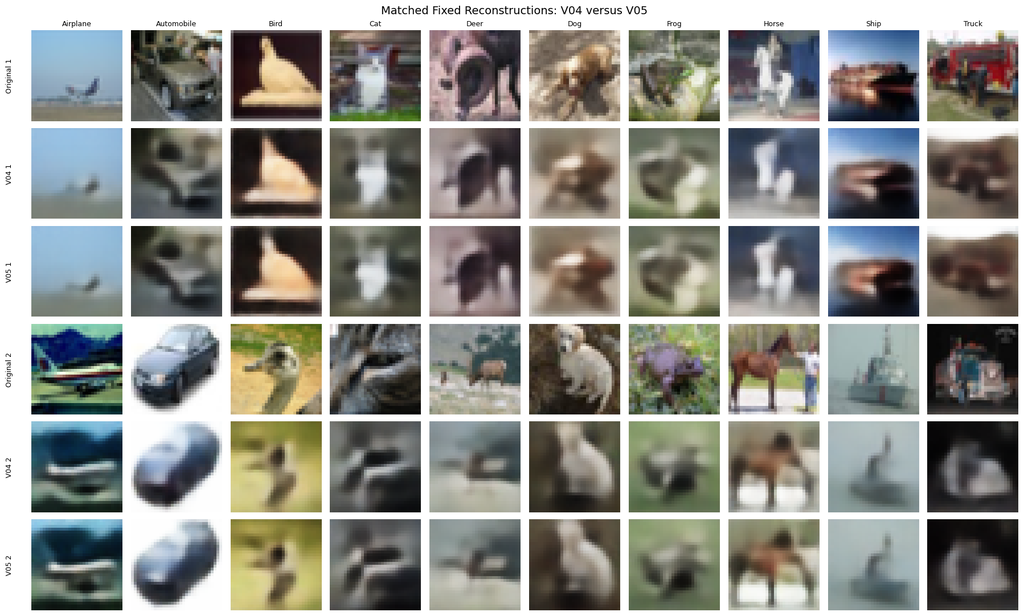

[figure not shown]

```
Matched generated-image descriptor comparison:
```

| descriptor | training_mean | V04_mean | V05_mean | V04_absolute_gap | V05_absolute_gap | gap_improvement_V05_vs_V04 |
| --- | --- | --- | --- | --- | --- | --- |
| brightness | 0.473055 | 0.486635 | 0.490659 | 0.013579 | 0.017604 | -0.004024 |
| contrast | 0.213141 | 0.191225 | 0.189526 | 0.021916 | 0.023614 | -0.001698 |
| red_mean | 0.489844 | 0.509468 | 0.513730 | 0.019624 | 0.023886 | -0.004262 |
| green_mean | 0.482936 | 0.497390 | 0.502514 | 0.014454 | 0.019578 | -0.005125 |
| blue_mean | 0.446386 | 0.453046 | 0.455732 | 0.006660 | 0.009346 | -0.002686 |
| saturation | 0.129711 | 0.119659 | 0.122838 | 0.010052 | 0.006873 | 0.003179 |
| edge_strength | 0.058002 | 0.036541 | 0.036208 | 0.021461 | 0.021794 | -0.000332 |

```
Matched generated diversity comparison:
```

|  | V04 | V05 | Training_reference |
| --- | --- | --- | --- |
| unique_uint8_images_out_of_100 | 100.000000 | 100.000000 | NaN |
| mean_pixel_standard_deviation | 0.208664 | 0.206421 | 0.249836 |
| minimum_unique_images_per_class_out_of_10 | 10.000000 | 10.000000 | NaN |
| mean_within_class_pixel_standard_deviation | 0.193304 | 0.192220 | NaN |

```
Matched conditional-control diagnostics:
```

|  | V04 | V05 | V05_minus_V04 |
| --- | --- | --- | --- |
| mean_pairwise_mae_between_labels_same_z | 0.044543 | 0.045002 | 0.000458 |
| within_requested_class_pixel_variance | 0.034192 | 0.033295 | -0.000897 |
| between_requested_class_centroid_variance | 0.001360 | 0.001432 | 0.000072 |
| between_to_within_variance_ratio | 0.039763 | 0.043005 | 0.003243 |
| mean_true_label_reconstruction_mse | 0.006570 | 0.006523 | -0.000046 |
| mean_wrong_label_reconstruction_mse | 0.009660 | 0.009680 | 0.000020 |
| fraction_true_mse_below_mean_wrong_mse | 1.000000 | 1.000000 | 0.000000 |
| fraction_true_label_lowest_mse_of_10 | 0.950000 | 0.950000 | 0.000000 |

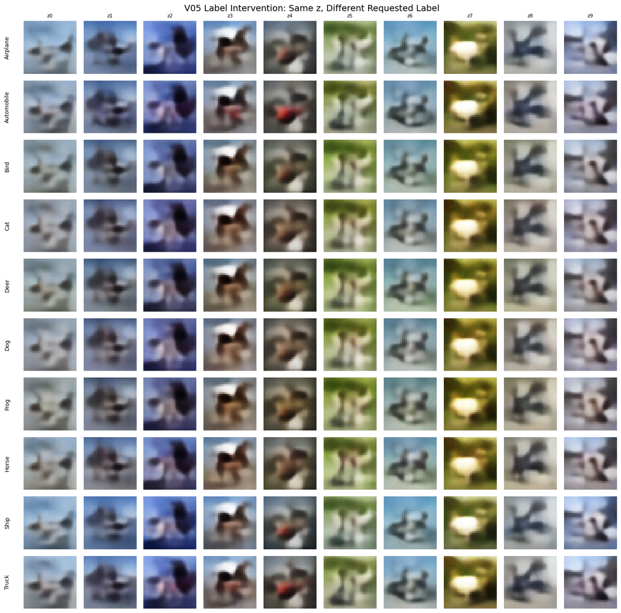

```
Matched latent-posterior diagnostics:
```

| model | mean_unweighted_kl | mean_absolute_z_mean | mean_posterior_std | mean_variance_of_z_mean_dimensions | active_units_variance_gt_0.01 |
| --- | --- | --- | --- | --- | --- |
| V04 | 106.539200 | 0.754401 | 0.217888 | 0.949140 | 64 |
| V05 | 107.970856 | 0.772504 | 0.208608 | 0.974081 | 64 |

```
Saved matched-evaluation artefacts:
- artifacts\vae\V05\evaluation\V04_V05_reconstruction_metrics.csv
- artifacts\vae\V05\evaluation\V04_V05_per_class_reconstruction_metrics.csv
- artifacts\vae\V05\evaluation\V04_V05_reconstruction_grid.png
- artifacts\vae\V05\evaluation\V05_fixed_requested_samples.npy
- artifacts\vae\V05\evaluation\V04_V05_same_latent_generation_grid.png
- artifacts\vae\V05\evaluation\V04_V05_descriptor_comparison.csv
- artifacts\vae\V05\evaluation\V04_V05_diversity_comparison.csv
- artifacts\vae\V05\evaluation\V04_V05_conditional_control_diagnostics.csv
- artifacts\vae\V05\evaluation\V05_same_z_different_label_grid.png
- artifacts\vae\V05\evaluation\V04_V05_latent_diagnostics.csv
V04 weight-file hashes unchanged: Yes
Models retrained: No
Official test-set usage: None
```

```python
v04_v05_control_df = pd.DataFrame({
    "V04": v04_control_metrics_for_v05,
    "V05": v05_control_metrics
})
v04_v05_control_df[
    "V05_minus_V04"
] = (
    v04_v05_control_df["V05"]
    - v04_v05_control_df["V04"]
)

print(
    "\nMatched conditional-control "
    "diagnostics:"
)
display(
    v04_v05_control_df.round(6)
)

v04_v05_control_path = (
    v05_evaluation_dir
    / (
        "V04_V05_conditional_"
        "control_diagnostics.csv"
    )
)
v04_v05_control_df.to_csv(
    v04_v05_control_path
)

fig, axes = plt.subplots(
    10,
    10,
    figsize=(14, 14)
)

for class_id, class_name in enumerate(
    class_names
):
    for latent_index in range(10):
        axis = axes[
            class_id,
            latent_index
        ]
        axis.imshow(
            v05_control_images[
                class_id,
                latent_index
            ]
        )
        axis.axis("off")

        if class_id == 0:
            axis.set_title(
                f"z{latent_index}",
                fontsize=8
            )

        if latent_index == 0:
            axis.text(
                -0.25,
                0.5,
                class_name,
                transform=axis.transAxes,
                rotation=90,
                va="center",
                ha="right",
                fontsize=9
            )

fig.suptitle(
    "V05 Label Intervention: "
    "Same z, Different Requested Label",
    fontsize=14
)
plt.tight_layout()

v05_label_intervention_grid_path = (
    v05_evaluation_dir
    / "V05_same_z_different_label_grid.png"
)
plt.savefig(
    v05_label_intervention_grid_path,
    dpi=150,
    bbox_inches="tight"
)
plt.show()

# -------------------------------------------------------
# 5. Matched latent-posterior diagnostics
# -------------------------------------------------------
v05_reference_one_hot = (
    keras.utils.to_categorical(
        v05_reference_labels,
        num_classes=(
            V05_EVALUATION_NUM_CLASSES
        )
    ).astype(np.float32)
)

(
    v04_reference_z_mean_for_v05,
    v04_reference_z_log_var_for_v05,
    _
) = encoder_v04.predict(
    [
        v05_reference_images,
        v05_reference_one_hot
    ],
    verbose=0
)
(
    v05_reference_z_mean,
    v05_reference_z_log_var,
    _
) = encoder_v05.predict(
    [
        v05_reference_images,
        v05_reference_one_hot
    ],
    verbose=0
)


def v05_latent_diagnostic_record(
    model_name,
    z_mean_values,
    z_log_var_values
):
    kl_per_image = -0.5 * np.sum(
        1.0
        + z_log_var_values
        - np.square(z_mean_values)
        - np.exp(z_log_var_values),
        axis=1
    )
    variance_by_dimension = np.var(
        z_mean_values,
        axis=0
    )

    return {
        "model": model_name,
        "mean_unweighted_kl": float(
            kl_per_image.mean()
        ),
        "mean_absolute_z_mean": float(
            np.abs(
                z_mean_values
            ).mean()
        ),
        "mean_posterior_std": float(
            np.exp(
                0.5 * z_log_var_values
            ).mean()
        ),
        (
            "mean_variance_of_"
            "z_mean_dimensions"
        ): float(
            variance_by_dimension.mean()
        ),
        (
            "active_units_"
            "variance_gt_0.01"
        ): int(
            np.sum(
                variance_by_dimension
                > 0.01
            )
        )
    }


v04_v05_latent_df = (
    pd.DataFrame([
        v05_latent_diagnostic_record(
            "V04",
            (
                v04_reference_z_mean_for_v05
            ),
            (
                v04_reference_z_log_var_for_v05
            )
        ),
        v05_latent_diagnostic_record(
            "V05",
            v05_reference_z_mean,
            v05_reference_z_log_var
        )
    ]).set_index("model")
)

print(
    "\nMatched latent-posterior "
    "diagnostics:"
)
display(
    v04_v05_latent_df.round(6)
)

v04_v05_latent_path = (
    v05_evaluation_dir
    / "V04_V05_latent_diagnostics.csv"
)
v04_v05_latent_df.to_csv(
    v04_v05_latent_path
)

# Confirm that evaluation did not alter V04 files.
v04_weight_hashes_after_v05_evaluation = {
    "encoder": v05_file_sha256(
        v04_encoder_weights_for_v05_comparison
    ),
    "decoder": v05_file_sha256(
        v04_decoder_weights_for_v05_comparison
    )
}
assert (
    v04_weight_hashes_before_v05_evaluation
    == v04_weight_hashes_after_v05_evaluation
)

print(
    "\nSaved matched-evaluation artefacts:"
)
for saved_path in [
    v04_v05_reconstruction_path,
    v04_v05_per_class_reconstruction_path,
    v04_v05_reconstruction_grid_path,
    v05_fixed_generated_samples_path,
    v04_v05_generation_grid_path,
    v04_v05_descriptor_path,
    v04_v05_diversity_path,
    v04_v05_control_path,
    v05_label_intervention_grid_path,
    v04_v05_latent_path
]:
    print(f"- {saved_path}")

print(
    "V04 weight-file hashes unchanged: Yes"
)
print("Models retrained: No")
print("Official test-set usage: None")
```

#### Executed V04-V05 Findings

V05 provides small pixel-error improvements but does not dominate V04:

| Metric | V04 | V05 | V05 change |
| --- | --- | --- | --- |
| MSE ↓ | 0.006570 | 0.006523 | 0.72% lower |
| MAE ↓ | 0.057916 | 0.057085 | 1.43% lower |
| PSNR ↑ | 22.450 dB | 22.549 dB | +0.099 dB |
| SSIM ↑ | 0.757548 | 0.756356 | 0.00119 lower |
| Absolute edge gap ↓ | 0.023499 | 0.023603 | 0.44% worse |

The reconstruction grids are nearly indistinguishable by eye. Per-class evidence is mixed: V05 improved MSE for seven of ten represented classes and SSIM for four, while several animal and vehicle classes regressed slightly.

Generated descriptors favour V04. V05 moved brightness, contrast, all RGB means and edge strength further from the training reference; only saturation improved. Both models retained 100 unique images out of 100 and at least ten unique images per requested class, but V05's overall pixel diversity decreased by 1.07% and within-class diversity by 0.56%.

Conditional influence improved slightly but remained limited. V05 increased same-`z` label differences by 1.03% and the between-to-within variance ratio by 8.15%, while the fraction whose true label was best remained unchanged at 95%. The label-intervention grid still shows that the latent vector controls most of the composition and requested labels often produce modest changes.

Both models used all 64 latent units. V05's higher KL, larger latent-mean variance and lower posterior standard deviation indicate a slightly stronger departure from the unit-Gaussian prior, not a clear collapse. Training time increased from 7.77 to 11.53 minutes, approximately 48% longer. The complete matched evidence therefore does not show a meaningful visual or structural advantage that offsets V05's compute and diversity costs.

### 10.7 V05 Development FID - Saved-Weight Three-Generation-Seed Evaluation

V05 uses the identical conditional-FID protocol applied to V03 and V04:

- final epoch-50 decoder loaded from saved weights;
- 5,000 balanced requested-class samples per run;
- generation seeds `1001`, `1002`, and `1003`, all using the same saved epoch-50 weights;
- the same frozen InceptionV3 extractor and 50,000-image training reference;
- mean, standard deviation, minimum and maximum reported; and
- no retraining or official test-set use.

V05 has no earlier single-seed result, so the cell calculates all three locked seeds. FID is interpreted together with reconstruction, SSIM, edge, diversity, latent, conditional-control, stability, visual and runtime evidence.

```python
assert (
    "evaluate_saved_conditional_vae_fid"
    in globals()
), (
    "Run the updated V03 FID cell first "
    "to restore the locked three-generation-seed "
    "conditional FID helper."
)

v05_inline_fid_weights_path = (
    Path("artifacts")
    / "vae"
    / "V05"
    / "weights"
    / "V05_decoder_final.weights.h5"
)
v05_single_fid_result_path = (
    Path("artifacts")
    / "vae"
    / "V05"
    / "evaluation"
    / "V05_development_fid.csv"
)
v05_repeated_fid_result_path = (
    Path("artifacts")
    / "vae"
    / "V05"
    / "evaluation"
    / "V05_repeated_development_fid.csv"
)
v05_fid_summary_path = (
    Path("artifacts")
    / "vae"
    / "V05"
    / "evaluation"
    / "V05_development_fid_summary.csv"
)

(
    v05_repeated_fid_df,
    v05_fid_summary_df,
    v05_inline_fid_decoder
) = evaluate_saved_conditional_vae_fid(
    experiment_id="V05",
    decoder_weights_path=(
        v05_inline_fid_weights_path
    ),
    single_result_path=(
        v05_single_fid_result_path
    ),
    repeated_result_path=(
        v05_repeated_fid_result_path
    ),
    summary_path=v05_fid_summary_path
)

print(
    "\nV05 repeated development-FID "
    "results:"
)
display(
    v05_repeated_fid_df.round(4)
)
print(
    "\nV05 FID summary "
    "(lower is better):"
)
display(
    v05_fid_summary_df.round(4)
)
print(
    "Repeated results saved to: "
    f"{v05_repeated_fid_result_path}"
)
print(
    "Summary saved to: "
    f"{v05_fid_summary_path}"
)
print("Balanced requested classes: Yes")
print("V05 retrained: No")
print("Official test-set usage: None")
```

```
Calculating V05 FID for seed 1001
```

```
V05 seed 1001 FID: 145.0915

Calculating V05 FID for seed 1002
```

```
V05 seed 1002 FID: 145.5390

Calculating V05 FID for seed 1003
```

```
V05 seed 1003 FID: 144.7164

V05 repeated development-FID results:
```

|  | experiment_id | checkpoint_epoch | seed | generated_sample_count | real_reference_count | samples_per_requested_class | fid | score_role | score_source | test_set_used |
| --- | --- | --- | --- | --- | --- | --- | --- | --- | --- | --- |
| 0 | V05 | 50 | 1001 | 5000 | 50000 | 500 | 145.0915 | three_seed_formal_comparison | calculated_in_experiment | False |
| 1 | V05 | 50 | 1002 | 5000 | 50000 | 500 | 145.5390 | three_seed_formal_comparison | calculated_in_experiment | False |
| 2 | V05 | 50 | 1003 | 5000 | 50000 | 500 | 144.7164 | three_seed_formal_comparison | calculated_in_experiment | False |

```
V05 FID summary (lower is better):
```

|  | experiment_id | fid_mean | fid_std | fid_min | fid_max | repeat_count |
| --- | --- | --- | --- | --- | --- | --- |
| 0 | V05 | 145.1156 | 0.4118 | 144.7164 | 145.539 | 3 |

```
Repeated results saved to: artifacts\vae\V05\evaluation\V05_repeated_development_fid.csv
Summary saved to: artifacts\vae\V05\evaluation\V05_development_fid_summary.csv
Balanced requested classes: Yes
V05 retrained: No
Official test-set usage: None
```

#### Executed Three-Generation-Seed FID Finding

V05 achieved FID scores of `145.0915`, `145.5390`, and `144.7164` across the three generation seeds, giving **145.1156 ± 0.4118**. V04 achieved **145.5441 ± 0.3302** under the identical protocol.

V05 lowers the mean by `0.4285` points, or **0.29%**. Its score is lower for each matched seed, so the direction is consistent; however, the improvement is small relative to the score magnitude and the two observed ranges overlap. This is treated as a marginal distributional gain rather than a decisive quality improvement.

FID alone does not capture requested-label correctness, reconstruction structure, descriptor matching, diversity, visual recognisability or compute. Those other criteria are therefore required for the experiment decision.

### 10.8 V05 Decision - Rejected; V04 Retained

V05 is a valid, stable AdamW experiment, but it does not provide enough overall benefit to replace V04.

#### Positive Evidence

V05 slightly improved fixed reconstruction MSE, MAE and PSNR. Conditional separation measures also moved modestly upward, and its three-generation-seed FID of **145.1156 ± 0.4118** was 0.29% lower than V04's **145.5441 ± 0.3302**. All three matched-generation-seed FID differences favoured V05.

#### Reasons for Rejection

The improvements are small and do not form a broad quality gain. V05's SSIM and reconstruction edge gap were slightly worse, six of seven generated-descriptor gaps regressed, overall and within-class diversity decreased, and the uncurated grids showed no convincing visual advantage. True-label-best reconstruction accuracy remained unchanged at 95%, so AdamW did not resolve the conditional-control limitation.

V05 also required approximately 48% more recorded training time than V04 because the TensorFlow 2.10-compatible AdamW path ran without optimizer-side XLA. The additional compute is not justified by a 0.29% FID improvement and sub-2% reconstruction changes.

#### Decision

V05 is rejected as the family winner. V04 remains the conditional incumbent because it provides the stronger multi-evidence balance of FID, reconstruction, SSIM, edge structure, descriptors, diversity, stability, visual quality and efficiency. V05 is retained as useful negative evidence showing that changing to AdamW did not materially improve the selected hybrid VAE.

## 11. Consolidated V00-V05 Quantitative Comparison and Provisional Selection

### 11.1 Consolidation Contract

All six completed experiments are now compared using their saved epoch-50 artefacts. The table combines:

- the single primary change and immediate parent;
- conditional status, latent dimension and `β`;
- architecture parameter count and recorded training time;
- fixed-input reconstruction MSE, MAE, PSNR and SSIM where available;
- conditional-control ratio for conditional models;
- the identical three-generation-seed development-FID mean and standard deviation; and
- the experiment-level decision already justified in Sections 5-10.

The code only reads existing development artefacts and writes a summary table and figure. It does not retrain any model or use the official test set. The final VAE is not selected automatically from the lowest FID.

```
Consolidated V00-V05 development evidence:
```

|  | experiment_id | primary_change | conditional | latent_dimension | beta | optimizer | total_parameters | training_minutes | reconstruction_mse | reconstruction_mae | reconstruction_psnr_db | reconstruction_ssim | absolute_edge_gap | conditional_control_ratio | fid_mean | fid_std | fid_rank | experiment_decision |
| --- | --- | --- | --- | --- | --- | --- | --- | --- | --- | --- | --- | --- | --- | --- | --- | --- | --- | --- |
| 0 | V00 | ConvTranspose baseline | False | 64 | 1.0 | Adam | 1024515 | 15.14998 | 0.00958 | 0.07171 | 20.76826 | NaN | NaN | NaN | 166.64860 | 0.40739 | 6 | Selected baseline |
| 1 | V01 | Beta 1.0 to 0.5 | False | 64 | 0.5 | Adam | 1024515 | 9.37847 | 0.00783 | 0.06401 | 21.66075 | NaN | NaN | NaN | 158.06483 | 0.74258 | 5 | Retained over V00 |
| 2 | V02 | Latent 64 to 128 | False | 128 | 0.5 | Adam | 1188483 | 10.42917 | 0.00745 | 0.06213 | 21.85098 | NaN | NaN | NaN | 155.90359 | 0.25898 | 3 | Rejected |
| 3 | V03 | One-hot conditioning | True | 64 | 0.5 | Adam | 1047555 | 10.22529 | 0.00770 | 0.06391 | 21.67564 | 0.60650 | 0.03127 | 0.05762 | 157.79025 | 0.11212 | 4 | Conditional candidate |
| 4 | V04 | L1 + SSIM objective | True | 64 | 0.5 | Adam | 1047555 | 7.77365 | 0.00657 | 0.05792 | 22.45042 | 0.75755 | 0.02350 | 0.03976 | 145.54409 | 0.33017 | 2 | Conditional incumbent |
| 5 | V05 | Adam to AdamW | True | 64 | 0.5 | AdamW | 1047555 | 11.52772 | 0.00652 | 0.05709 | 22.54917 | 0.75636 | 0.02360 | 0.04301 | 145.11564 | 0.41180 | 1 | Rejected |

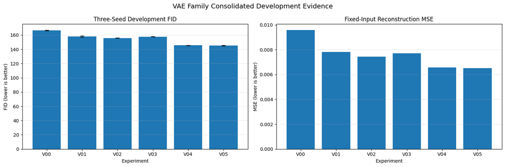

```
Consolidated table saved to: artifacts\vae\consolidated_selection\V00_V05_consolidated_comparison.csv
Consolidated figure saved to: artifacts\vae\consolidated_selection\V00_V05_consolidated_metrics.png
Automatic final model selection: No
Official test-set usage: None
```

```python
# Consolidate the completed V00-V05 development evidence.
vae_artifact_root = Path("artifacts") / "vae"
consolidated_dir = (
    vae_artifact_root / "consolidated_selection"
)
consolidated_dir.mkdir(parents=True, exist_ok=True)

experiment_ids = [
    "V00",
    "V01",
    "V02",
    "V03",
    "V04",
    "V05"
]

experiment_specs = {
    "V00": {
        "parent": "Baseline screen",
        "primary_change": "ConvTranspose baseline",
        "conditional": False,
        "objective": "BCE + KL",
        "decision": "Selected baseline"
    },
    "V01": {
        "parent": "V00",
        "primary_change": "Beta 1.0 to 0.5",
        "conditional": False,
        "objective": "BCE + KL",
        "decision": "Retained over V00"
    },
    "V02": {
        "parent": "V01",
        "primary_change": "Latent 64 to 128",
        "conditional": False,
        "objective": "BCE + KL",
        "decision": "Rejected"
    },
    "V03": {
        "parent": "V01",
        "primary_change": "One-hot conditioning",
        "conditional": True,
        "objective": "BCE + KL",
        "decision": "Conditional candidate"
    },
    "V04": {
        "parent": "V03",
        "primary_change": "L1 + SSIM objective",
        "conditional": True,
        "objective": "L1 + SSIM + KL",
        "decision": "Conditional incumbent"
    },
    "V05": {
        "parent": "V04",
        "primary_change": "Adam to AdamW",
        "conditional": True,
        "objective": "L1 + SSIM + KL",
        "decision": "Rejected"
    }
}

parameter_fallback = {
    "V00": 1_024_515,
    "V01": 1_024_515
}

required_paths = []
for experiment_id in experiment_ids:
    required_paths.extend([
        (
            vae_artifact_root
            / experiment_id
            / f"{experiment_id}_training_record.json"
        ),
        (
            vae_artifact_root
            / experiment_id
            / "evaluation"
            / f"{experiment_id}_checkpoint_metrics.csv"
        )
    ])

required_paths.extend([
    (
        vae_artifact_root
        / "architecture_screen"
        / "fid"
        / "baseline_fid_summary.csv"
    ),
    *[
        (
            vae_artifact_root
            / experiment_id
            / "evaluation"
            / (
                f"{experiment_id}_"
                "development_fid_summary.csv"
            )
        )
        for experiment_id in experiment_ids[1:]
    ],
    (
        vae_artifact_root
        / "V04"
        / "evaluation"
        / "V03_V04_reconstruction_metrics.csv"
    ),
    (
        vae_artifact_root
        / "V05"
        / "evaluation"
        / "V04_V05_reconstruction_metrics.csv"
    ),
    (
        vae_artifact_root
        / "V04"
        / "evaluation"
        / (
            "V03_V04_conditional_"
            "control_diagnostics.csv"
        )
    ),
    (
        vae_artifact_root
        / "V05"
        / "evaluation"
        / (
            "V04_V05_conditional_"
            "control_diagnostics.csv"
        )
    )
])

for required_path in required_paths:
    assert required_path.exists(), (
        "Required consolidation artefact "
        f"missing: {required_path}"
    )

# Load the repeated development-FID summaries.
baseline_fid_df = pd.read_csv(
    vae_artifact_root
    / "architecture_screen"
    / "fid"
    / "baseline_fid_summary.csv"
)
v00_fid_row = baseline_fid_df.loc[
    baseline_fid_df["candidate_id"]
    == "B02_V00_CONVTRANSPOSE"
].iloc[0]

fid_by_experiment = {
    "V00": {
        "fid_mean": float(v00_fid_row["fid_mean"]),
        "fid_std": float(v00_fid_row["fid_std"])
    }
}
for experiment_id in experiment_ids[1:]:
    fid_df = pd.read_csv(
        vae_artifact_root
        / experiment_id
        / "evaluation"
        / (
            f"{experiment_id}_"
            "development_fid_summary.csv"
        )
    )
    assert len(fid_df) == 1
    assert int(fid_df.iloc[0]["repeat_count"]) == 3
    fid_by_experiment[experiment_id] = {
        "fid_mean": float(fid_df.iloc[0]["fid_mean"]),
        "fid_std": float(fid_df.iloc[0]["fid_std"])
    }

# SSIM and edge gaps were introduced for the
# structure-aware conditional comparisons.
v03_v04_reconstruction_df = pd.read_csv(
    vae_artifact_root
    / "V04"
    / "evaluation"
    / "V03_V04_reconstruction_metrics.csv",
    index_col="metric"
)
v04_v05_reconstruction_df = pd.read_csv(
    vae_artifact_root
    / "V05"
    / "evaluation"
    / "V04_V05_reconstruction_metrics.csv",
    index_col="metric"
)

ssim_by_experiment = {
    "V00": np.nan,
    "V01": np.nan,
    "V02": np.nan,
    "V03": float(
        v03_v04_reconstruction_df.loc["ssim", "V03"]
    ),
    "V04": float(
        v04_v05_reconstruction_df.loc["ssim", "V04"]
    ),
    "V05": float(
        v04_v05_reconstruction_df.loc["ssim", "V05"]
    )
}
edge_gap_by_experiment = {
    "V00": np.nan,
    "V01": np.nan,
    "V02": np.nan,
    "V03": float(
        v03_v04_reconstruction_df.loc[
            "absolute_edge_gap",
            "V03"
        ]
    ),
    "V04": float(
        v04_v05_reconstruction_df.loc[
            "absolute_edge_gap",
            "V04"
        ]
    ),
    "V05": float(
        v04_v05_reconstruction_df.loc[
            "absolute_edge_gap",
            "V05"
        ]
    )
}

# Conditional-control ratio is not applicable to
# unconditional V00-V02.
v03_v04_control_df = pd.read_csv(
    vae_artifact_root
    / "V04"
    / "evaluation"
    / (
        "V03_V04_conditional_"
        "control_diagnostics.csv"
    ),
    index_col=0
)
v04_v05_control_df = pd.read_csv(
    vae_artifact_root
    / "V05"
    / "evaluation"
    / (
        "V04_V05_conditional_"
        "control_diagnostics.csv"
    ),
    index_col=0
)
control_metric = (
    "between_to_within_variance_ratio"
)
control_ratio_by_experiment = {
    "V00": np.nan,
    "V01": np.nan,
    "V02": np.nan,
    "V03": float(
        v03_v04_control_df.loc[
            control_metric,
            "V03"
        ]
    ),
    "V04": float(
        v04_v05_control_df.loc[
            control_metric,
            "V04"
        ]
    ),
    "V05": float(
        v04_v05_control_df.loc[
            control_metric,
            "V05"
        ]
    )
}

consolidated_rows = []
for experiment_id in experiment_ids:
    record_path = (
        vae_artifact_root
        / experiment_id
        / f"{experiment_id}_training_record.json"
    )
    with record_path.open(
        "r",
        encoding="utf-8"
    ) as record_file:
        training_record = json.load(record_file)

    checkpoint_df = pd.read_csv(
        vae_artifact_root
        / experiment_id
        / "evaluation"
        / f"{experiment_id}_checkpoint_metrics.csv",
        index_col="epoch"
    )
    final_checkpoint = checkpoint_df.loc[50]

    if (
        training_record.get("encoder_parameters")
        is not None
        and training_record.get("decoder_parameters")
        is not None
    ):
        total_parameters = int(
            training_record["encoder_parameters"]
            + training_record["decoder_parameters"]
        )
    else:
        total_parameters = parameter_fallback[
            experiment_id
        ]

    spec = experiment_specs[experiment_id]
    consolidated_rows.append({
        "experiment_id": experiment_id,
        "parent": spec["parent"],
        "primary_change": spec["primary_change"],
        "conditional": spec["conditional"],
        "latent_dimension": int(
            training_record["latent_dimension"]
        ),
        "beta": float(training_record["beta"]),
        "objective": spec["objective"],
        "optimizer": training_record["optimizer"],
        "total_parameters": total_parameters,
        "training_minutes": float(
            training_record[
                "training_duration_seconds"
            ] / 60.0
        ),
        "reconstruction_mse": float(
            final_checkpoint["reconstruction_mse"]
        ),
        "reconstruction_mae": float(
            final_checkpoint["reconstruction_mae"]
        ),
        "reconstruction_psnr_db": float(
            final_checkpoint[
                "reconstruction_psnr_db"
            ]
        ),
        "reconstruction_ssim": (
            ssim_by_experiment[experiment_id]
        ),
        "absolute_edge_gap": (
            edge_gap_by_experiment[experiment_id]
        ),
        "conditional_control_ratio": (
            control_ratio_by_experiment[
                experiment_id
            ]
        ),
        "fid_mean": (
            fid_by_experiment[
                experiment_id
            ]["fid_mean"]
        ),
        "fid_std": (
            fid_by_experiment[
                experiment_id
            ]["fid_std"]
        ),
        "experiment_decision": spec["decision"],
        "test_set_used": bool(
            training_record["test_set_used"]
        )
    })

v00_v05_consolidated_df = pd.DataFrame(
    consolidated_rows
)
v00_v05_consolidated_df["fid_rank"] = (
    v00_v05_consolidated_df["fid_mean"]
    .rank(method="min")
    .astype(int)
)

assert len(v00_v05_consolidated_df) == 6
assert (
    v00_v05_consolidated_df["experiment_id"].tolist()
    == experiment_ids
)
assert not v00_v05_consolidated_df[
    "test_set_used"
].any()
assert np.isfinite(
    v00_v05_consolidated_df[
        [
            "reconstruction_mse",
            "reconstruction_mae",
            "reconstruction_psnr_db",
            "fid_mean",
            "fid_std",
            "training_minutes"
        ]
    ].to_numpy()
).all()

display_columns = [
    "experiment_id",
    "primary_change",
    "conditional",
    "latent_dimension",
    "beta",
    "optimizer",
    "total_parameters",
    "training_minutes",
    "reconstruction_mse",
    "reconstruction_mae",
    "reconstruction_psnr_db",
    "reconstruction_ssim",
    "absolute_edge_gap",
    "conditional_control_ratio",
    "fid_mean",
    "fid_std",
    "fid_rank",
    "experiment_decision"
]

print("Consolidated V00-V05 development evidence:")
display(
    v00_v05_consolidated_df[
        display_columns
    ].round(5)
)

consolidated_table_path = (
    consolidated_dir
    / "V00_V05_consolidated_comparison.csv"
)
v00_v05_consolidated_df.to_csv(
    consolidated_table_path,
    index=False
)

fig, axes = plt.subplots(
    1,
    2,
    figsize=(15, 5)
)

axes[0].bar(
    experiment_ids,
    v00_v05_consolidated_df["fid_mean"],
    yerr=v00_v05_consolidated_df["fid_std"],
    capsize=4
)
axes[0].set_title(
    "Three-Generation-Seed Development FID"
)
axes[0].set_xlabel("Experiment")
axes[0].set_ylabel("FID (lower is better)")
axes[0].grid(axis="y", alpha=0.3)

axes[1].bar(
    experiment_ids,
    v00_v05_consolidated_df[
        "reconstruction_mse"
    ]
)
axes[1].set_title(
    "Fixed-Input Reconstruction MSE"
)
axes[1].set_xlabel("Experiment")
axes[1].set_ylabel("MSE (lower is better)")
axes[1].grid(axis="y", alpha=0.3)

fig.suptitle(
    "VAE Family Consolidated Development Evidence",
    fontsize=14
)
plt.tight_layout()

consolidated_figure_path = (
    consolidated_dir
    / "V00_V05_consolidated_metrics.png"
)
plt.savefig(
    consolidated_figure_path,
    dpi=150,
    bbox_inches="tight"
)
plt.show()

print(
    "Consolidated table saved to: "
    f"{consolidated_table_path}"
)
print(
    "Consolidated figure saved to: "
    f"{consolidated_figure_path}"
)
print("Automatic final model selection: No")
print("Official test-set usage: None")
```

### 11.2 Provisional Quantitative Selection of V04

The provisional quantitative choice is based on the complete development evidence rather than the lowest FID alone. Invalid or rejected experiments remain in the table for transparency, but they are not treated as viable candidates for formal human evaluation.

**Provisionally selected quantitative candidate: V04, the conditional ConvTranspose VAE with the combined L1 + SSIM reconstruction objective.**

The decision is supported by the following evidence:

- Against the selected V00 baseline, V04 reduces mean development FID from `166.6486 ± 0.4074` to `145.5441 ± 0.3302`, a **12.66% improvement**.
- Against its direct parent V03, V04 reduces mean FID by **7.76%**, reconstruction MSE by **14.63%**, reconstruction MAE by **9.37%**, and absolute edge-strength gap by **24.85%**. Mean reconstruction SSIM also rises from `0.6065` to `0.7575`.
- V02 has a better FID than V03, but it was rejected because doubling the latent dimension produced only a modest gain, increased the parameter count and weakened the qualitative diversity evidence. V03 was intentionally built from V01 because adding class conditioning was the required conceptual improvement, not a continuation of V02's rejected capacity increase.
- V05 records the lowest mean FID (`145.1156 ± 0.4118`), but this is only **0.29% lower** than V04. It does not provide a convincing visual improvement, has slightly lower reconstruction SSIM, a slightly larger edge gap, weaker overall descriptor balance and takes **48.29% longer** to train. AdamW is therefore rejected for this controlled experiment.
- V04's conditional-control ratio is lower than V03's. This limitation is retained explicitly: conditioning affects generation, but class control remains modest and must not be overstated.

The selected V04 configuration is therefore:

- conditional ConvTranspose encoder-decoder;
- 64-dimensional latent space;
- `β = 0.5`;
- summed L1 reconstruction plus `0.1 × 3072 × (1 − SSIM)`;
- Adam with learning rate `0.001`;
- batch size `128`, 50 epochs and seed `42`; and
- training data only, with no augmentation and no official test-set use.

V04 is therefore the **provisionally selected quantitative candidate**, not yet the confirmed final VAE. V00-V05 provide the controlled baseline, improvement and negative-result evidence required for systematic quantitative evaluation. V04's improvements are associated with the combined L1 + SSIM objective; the notebook does not claim that either component independently caused the gain. Formal blind human evaluation is required next to determine whether the quantitative choice should be confirmed before freezing, export and independent reload verification. No additional model training is performed.

## 12. Formal Human Evaluation of Provisionally Selected V04

### 12.1 Blinded Single-Rater Scoring Preparation

V04 is the provisionally selected quantitative candidate after the complete V00-V05 development comparison. This section applies the formal 100-image human evaluation needed before confirming the final VAE, using the same core protocol as the completed V00 baseline score.

The evaluation uses:

- 100 existing V04 samples generated from the locked 64-dimensional latent vectors;
- exactly 10 requested images per CIFAR-10 class;
- no curation, replacement or selective removal;
- a deterministic shuffle that hides the requested class;
- one development rater, Aniq;
- a separate answer key that must remain unopened until all ratings are complete; and
- no official test-set data.

The rater records:

- image quality: `Clear`, `Marginal`, or `Nonsense`;
- perceived class: one CIFAR-10 class name or `Unclear`;
- confidence: `Low`, `Medium`, or `High`; and
- an optional brief note.

For this completed rating procedure, an image judged `Nonsense` because no coherent object could be perceived was also recorded as `Unclear` for perceived class. Conversely, a class name was recorded only when the image was rated `Clear` or `Marginal`. The two fields are still analysed separately because quality measures visual plausibility, whereas perceived class measures recognisability.

The template deliberately excludes the requested class. After the completed sheet passes completeness and vocabulary validation, the hidden key will be joined to it to calculate overall quality, perceived-class distribution, requested-class agreement, per-class results and the final V00-versus-V04 comparison.

The saved samples and labels are reused rather than regenerated. This preserves the exact uncurated V04 evidence already evaluated quantitatively and prevents a favourable manual subset from being chosen after seeing the images.

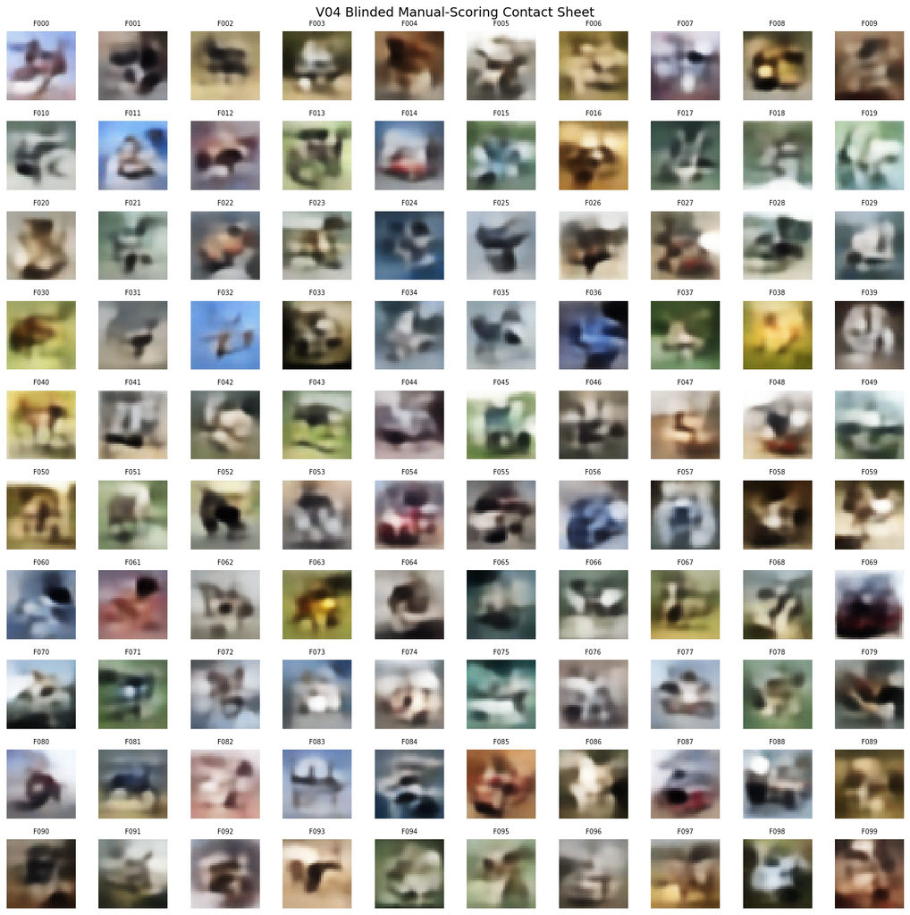

```
V04 formal blind-scoring materials created.
Contact sheet: artifacts\vae\V04\formal_manual_evaluation\V04_blind_manual_scoring_contact_sheet.png
Single-rater template: artifacts\vae\V04\formal_manual_evaluation\V04_blind_manual_scoring_template.csv
Answer key — do not open while scoring: artifacts\vae\V04\formal_manual_evaluation\V04_blind_manual_scoring_key_DO_NOT_OPEN_WHILE_SCORING.csv
Completed sheet must be saved as: artifacts\vae\V04\formal_manual_evaluation\V04_blind_manual_scoring_completed_Aniq.csv
Balanced requested classes: Yes
Images curated or selectively removed: No
Number of development raters required: 1
Official test-set usage: None
```

```python
V04_FINAL_MANUAL_SAMPLE_COUNT = 100
V04_FINAL_MANUAL_SHUFFLE_SEED = SEED + 404
V04_FINAL_MANUAL_RATER_COUNT = 1

v04_final_manual_dir = (
    Path("artifacts")
    / "vae"
    / "V04"
    / "formal_manual_evaluation"
)
v04_final_manual_dir.mkdir(
    parents=True,
    exist_ok=True
)

v04_manual_source_images_path = (
    Path("artifacts")
    / "vae"
    / "V04"
    / "evaluation"
    / "V04_fixed_requested_samples.npy"
)
v04_manual_source_labels_path = (
    Path("artifacts")
    / "vae"
    / "fixed_inputs"
    / "V03_fixed_conditional_label_ids.npy"
)

for required_path in [
    v04_manual_source_images_path,
    v04_manual_source_labels_path
]:
    assert required_path.exists(), (
        "Required V04 formal-evaluation "
        f"artefact is missing: {required_path}"
    )

v04_manual_source_images = np.load(
    v04_manual_source_images_path
)
v04_manual_source_label_ids = np.load(
    v04_manual_source_labels_path
).astype(np.int64)

assert v04_manual_source_images.shape == (
    V04_FINAL_MANUAL_SAMPLE_COUNT,
    32,
    32,
    3
)
assert v04_manual_source_images.dtype == np.uint8
assert v04_manual_source_label_ids.shape == (
    V04_FINAL_MANUAL_SAMPLE_COUNT,
)
assert np.array_equal(
    np.bincount(
        v04_manual_source_label_ids,
        minlength=len(class_names)
    ),
    np.full(
        len(class_names),
        10
    )
)

v04_manual_shuffle_rng = np.random.default_rng(
    V04_FINAL_MANUAL_SHUFFLE_SEED
)
v04_manual_permutation = (
    v04_manual_shuffle_rng.permutation(
        V04_FINAL_MANUAL_SAMPLE_COUNT
    )
)
v04_manual_blind_ids = np.array([
    f"F{index:03d}"
    for index in range(
        V04_FINAL_MANUAL_SAMPLE_COUNT
    )
])
v04_manual_blind_images = (
    v04_manual_source_images[
        v04_manual_permutation
    ]
)

assert v04_manual_blind_images.shape == (
    100,
    32,
    32,
    3
)
assert len(
    np.unique(
        v04_manual_blind_ids
    )
) == 100

v04_manual_blind_images_path = (
    v04_final_manual_dir
    / "V04_blind_images_uint8.npy"
)
v04_manual_permutation_path = (
    v04_final_manual_dir
    / "V04_blind_permutation.npy"
)
np.save(
    v04_manual_blind_images_path,
    v04_manual_blind_images
)
np.save(
    v04_manual_permutation_path,
    v04_manual_permutation
)

fig, axes = plt.subplots(
    10,
    10,
    figsize=(14, 14)
)
for blind_position, axis in enumerate(
    axes.flat
):
    axis.imshow(
        v04_manual_blind_images[
            blind_position
        ]
    )
    axis.set_title(
        v04_manual_blind_ids[
            blind_position
        ],
        fontsize=7
    )
    axis.axis("off")

fig.suptitle(
    "V04 Blinded Manual-Scoring Contact Sheet",
    fontsize=14
)
plt.tight_layout()

v04_manual_contact_sheet_path = (
    v04_final_manual_dir
    / "V04_blind_manual_scoring_contact_sheet.png"
)
plt.savefig(
    v04_manual_contact_sheet_path,
    dpi=150,
    bbox_inches="tight"
)
plt.show()

v04_manual_template_df = pd.DataFrame({
    "blind_id": v04_manual_blind_ids,
    "rater": "",
    (
        "quality_rating_"
        "clear_marginal_nonsense"
    ): "",
    "perceived_class": "",
    (
        "confidence_"
        "low_medium_high"
    ): "",
    "note": ""
})

v04_manual_key_df = pd.DataFrame({
    "blind_id": v04_manual_blind_ids,
    "source_sample_index": (
        v04_manual_permutation
    ),
    "requested_class_id": (
        v04_manual_source_label_ids[
            v04_manual_permutation
        ]
    ),
    "requested_class_name": [
        class_names[class_id]
        for class_id in (
            v04_manual_source_label_ids[
                v04_manual_permutation
            ]
        )
    ]
})

v04_manual_template_path = (
    v04_final_manual_dir
    / "V04_blind_manual_scoring_template.csv"
)
v04_manual_key_path = (
    v04_final_manual_dir
    / (
        "V04_blind_manual_scoring_"
        "key_DO_NOT_OPEN_WHILE_SCORING.csv"
    )
)
v04_manual_protocol_path = (
    v04_final_manual_dir
    / "V04_manual_scoring_protocol.json"
)

v04_manual_template_df.to_csv(
    v04_manual_template_path,
    index=False
)
v04_manual_key_df.to_csv(
    v04_manual_key_path,
    index=False
)

v04_manual_protocol = {
    "selected_experiment": "V04",
    "sample_count": (
        V04_FINAL_MANUAL_SAMPLE_COUNT
    ),
    "samples_per_requested_class": 10,
    "balanced_requested_classes": True,
    "source_samples": str(
        v04_manual_source_images_path
    ),
    "source_labels": str(
        v04_manual_source_labels_path
    ),
    "shuffle_seed": (
        V04_FINAL_MANUAL_SHUFFLE_SEED
    ),
    "blind_id_prefix": "F",
    "images_curated_or_removed": False,
    "required_raters": (
        V04_FINAL_MANUAL_RATER_COUNT
    ),
    "required_rater_name": "Aniq",
    "quality_values": [
        "Clear",
        "Marginal",
        "Nonsense"
    ],
    "perceived_class_values": (
        list(class_names) + ["Unclear"]
    ),
    "confidence_values": [
        "Low",
        "Medium",
        "High"
    ],
    "answer_key_opened_during_scoring": False,
    "test_set_used": False
}

with v04_manual_protocol_path.open(
    "w",
    encoding="utf-8"
) as protocol_file:
    json.dump(
        v04_manual_protocol,
        protocol_file,
        indent=4
    )

assert len(v04_manual_template_df) == 100
assert len(v04_manual_key_df) == 100
assert v04_manual_template_df[
    "blind_id"
].is_unique
assert v04_manual_key_df[
    "blind_id"
].is_unique
assert not any(
    "requested" in column.lower()
    for column in (
        v04_manual_template_df.columns
    )
)

print(
    "V04 formal blind-scoring materials created."
)
print(
    "Contact sheet: "
    f"{v04_manual_contact_sheet_path}"
)
print(
    "Single-rater template: "
    f"{v04_manual_template_path}"
)
print(
    "Answer key - do not open while scoring: "
    f"{v04_manual_key_path}"
)
print(
    "Completed sheet must be saved as: "
    f"{v04_final_manual_dir / 'V04_blind_manual_scoring_completed_Aniq.csv'}"
)
print("Balanced requested classes: Yes")
print("Images curated or selectively removed: No")
print("Number of development raters required: 1")
print("Official test-set usage: None")
```

### 12.2 Completed V04 Blind-Scoring Validation and Analysis

Aniq completed all 100 V04 ratings before the requested-class answer key was opened. Image quality and perceived class are retained as separate measures exactly as recorded. The documented scoring convention links their entries operationally: `Nonsense` corresponds to `Unclear`, while `Clear` or `Marginal` corresponds to a recorded class name.

The next cell validates the raw ratings before reading the key. It requires:

- exactly 100 rows and every blind ID from `F000` to `F099` exactly once;
- one rater named `Aniq`;
- no blank required fields;
- only the permitted quality, perceived-class and confidence values;
- exact row-wise compliance with the documented `Nonsense` ↔ `Unclear` scoring convention; and
- a key containing the same 100 IDs, unique source indices and exactly 10 requested images per class.

Only after these checks pass does the code join the hidden requested classes. It calculates overall quality, confidence and perceived-class summaries; requested-class agreement by class; the requested-versus-perceived confusion table; and a matched single-rater V00-versus-V04 comparison. Requested-class agreement is unavailable for V00 because it is unconditional. No official test data are used.

```python
v04_completed_manual_path = (
    Path("artifacts")
    / "vae"
    / "V04"
    / "formal_manual_evaluation"
    / "V04_blind_manual_scoring_completed_Aniq.csv"
)
v04_manual_key_path = (
    Path("artifacts")
    / "vae"
    / "V04"
    / "formal_manual_evaluation"
    / (
        "V04_blind_manual_scoring_"
        "key_DO_NOT_OPEN_WHILE_SCORING.csv"
    )
)
v00_completed_manual_path_for_v04 = (
    Path("artifacts")
    / "vae"
    / "architecture_screen"
    / "V00_baseline_manual_scoring"
    / (
        "V00_baseline_blind_manual_"
        "scoring_completed_Aniq.csv"
    )
)
v04_final_manual_dir = (
    v04_completed_manual_path.parent
)

for required_path in [
    v04_completed_manual_path,
    v04_manual_key_path,
    v00_completed_manual_path_for_v04
]:
    assert required_path.exists(), (
        "Required manual-evaluation file "
        f"is missing: {required_path}"
    )

manual_columns = [
    "blind_id",
    "rater",
    (
        "quality_rating_"
        "clear_marginal_nonsense"
    ),
    "perceived_class",
    (
        "confidence_"
        "low_medium_high"
    ),
    "note"
]
quality_column = (
    "quality_rating_"
    "clear_marginal_nonsense"
)
confidence_column = (
    "confidence_"
    "low_medium_high"
)
quality_order = [
    "Clear",
    "Marginal",
    "Nonsense"
]
confidence_order = [
    "High",
    "Medium",
    "Low"
]
perceived_class_order = (
    list(class_names)
    + ["Unclear"]
)

v04_completed_manual_df = pd.read_csv(
    v04_completed_manual_path,
    dtype=str,
    keep_default_na=False
)
assert list(
    v04_completed_manual_df.columns
) == manual_columns
assert len(v04_completed_manual_df) == 100

for column in manual_columns:
    v04_completed_manual_df[column] = (
        v04_completed_manual_df[
            column
        ].str.strip()
    )

for required_column in (
    manual_columns[:-1]
):
    assert not (
        v04_completed_manual_df[
            required_column
        ] == ""
    ).any(), (
        "Blank required values found in "
        f"{required_column}."
    )

expected_blind_ids = {
    f"F{index:03d}"
    for index in range(100)
}
assert set(
    v04_completed_manual_df["blind_id"]
) == expected_blind_ids
assert v04_completed_manual_df[
    "blind_id"
].is_unique
assert set(
    v04_completed_manual_df["rater"]
) == {"Aniq"}
assert set(
    v04_completed_manual_df[
        quality_column
    ]
).issubset(set(quality_order))
assert set(
    v04_completed_manual_df[
        "perceived_class"
    ]
).issubset(set(perceived_class_order))
assert set(
    v04_completed_manual_df[
        confidence_column
    ]
).issubset(set(confidence_order))

v04_nonsense_mask = (
    v04_completed_manual_df[
        quality_column
    ] == "Nonsense"
)
v04_unclear_mask = (
    v04_completed_manual_df[
        "perceived_class"
    ] == "Unclear"
)
assert np.array_equal(
    v04_nonsense_mask.to_numpy(),
    v04_unclear_mask.to_numpy()
), (
    "Every Nonsense rating must correspond "
    "to Unclear perceived class, and every "
    "Clear or Marginal rating must contain "
    "a CIFAR-10 class name."
)

print(
    "V04 completed ratings passed "
    "all pre-key validation checks."
)
print(
    "Nonsense-to-Unclear scoring "
    "convention: Passed"
)
print(
    "Validated rows before opening key: "
    f"{len(v04_completed_manual_df)}"
)

# Read the key only after all raw-rating checks pass.
v04_manual_key_df = pd.read_csv(
    v04_manual_key_path,
    dtype={
        "blind_id": str,
        "source_sample_index": int,
        "requested_class_id": int,
        "requested_class_name": str
    },
    keep_default_na=False
)
expected_key_columns = [
    "blind_id",
    "source_sample_index",
    "requested_class_id",
    "requested_class_name"
]
assert list(
    v04_manual_key_df.columns
) == expected_key_columns
assert len(v04_manual_key_df) == 100
assert v04_manual_key_df[
    "blind_id"
].is_unique
assert set(
    v04_manual_key_df["blind_id"]
) == expected_blind_ids
assert set(
    v04_manual_key_df[
        "source_sample_index"
    ]
) == set(range(100))
assert v04_manual_key_df[
    "source_sample_index"
].is_unique
assert set(
    v04_manual_key_df[
        "requested_class_id"
    ]
) == set(range(len(class_names)))

expected_requested_names = [
    class_names[class_id]
    for class_id in (
        v04_manual_key_df[
            "requested_class_id"
        ]
    )
]
assert np.array_equal(
    v04_manual_key_df[
        "requested_class_name"
    ].to_numpy(),
    np.asarray(expected_requested_names)
)
assert np.array_equal(
    v04_manual_key_df[
        "requested_class_name"
    ].value_counts().reindex(
        class_names,
        fill_value=0
    ).to_numpy(),
    np.full(len(class_names), 10)
)

v04_manual_joined_df = (
    v04_completed_manual_df.merge(
        v04_manual_key_df,
        on="blind_id",
        how="inner",
        validate="one_to_one"
    )
)
assert len(v04_manual_joined_df) == 100

v04_manual_joined_df[
    "acceptable_image"
] = (
    v04_manual_joined_df[
        quality_column
    ] != "Nonsense"
)
v04_manual_joined_df[
    "perceived_class_available"
] = (
    v04_manual_joined_df[
        "perceived_class"
    ] != "Unclear"
)
v04_manual_joined_df[
    "requested_class_match"
] = (
    v04_manual_joined_df[
        "perceived_class"
    ]
    == v04_manual_joined_df[
        "requested_class_name"
    ]
)


def ordered_manual_summary(
    dataframe,
    column,
    order,
    label_name
):
    counts = (
        dataframe[column]
        .value_counts()
        .reindex(order, fill_value=0)
    )
    return pd.DataFrame({
        label_name: order,
        "count": counts.to_numpy(),
        "percentage": (
            counts.to_numpy()
            / len(dataframe)
            * 100.0
        )
    })


v04_manual_quality_summary_df = (
    ordered_manual_summary(
        v04_manual_joined_df,
        quality_column,
        quality_order,
        "quality_rating"
    )
)
v04_manual_confidence_summary_df = (
    ordered_manual_summary(
        v04_manual_joined_df,
        confidence_column,
        confidence_order,
        "confidence"
    )
)
v04_manual_perceived_summary_df = (
    ordered_manual_summary(
        v04_manual_joined_df,
        "perceived_class",
        perceived_class_order,
        "perceived_class"
    )
)
```

```python
v04_requested_class_summary_df = (
    v04_manual_joined_df.groupby(
        "requested_class_name",
        sort=False
    ).agg(
        sample_count=("blind_id", "size"),
        clear_count=(
            quality_column,
            lambda values: (
                values == "Clear"
            ).sum()
        ),
        marginal_count=(
            quality_column,
            lambda values: (
                values == "Marginal"
            ).sum()
        ),
        nonsense_count=(
            quality_column,
            lambda values: (
                values == "Nonsense"
            ).sum()
        ),
        perceived_unclear_count=(
            "perceived_class",
            lambda values: (
                values == "Unclear"
            ).sum()
        ),
        requested_class_match_count=(
            "requested_class_match",
            "sum"
        )
    ).reindex(
        class_names
    ).reset_index()
)
v04_requested_class_summary_df[
    "acceptable_percentage"
] = (
    (
        v04_requested_class_summary_df[
            "clear_count"
        ]
        + v04_requested_class_summary_df[
            "marginal_count"
        ]
    )
    / v04_requested_class_summary_df[
        "sample_count"
    ]
    * 100.0
)
v04_requested_class_summary_df[
    "perceived_unclear_percentage"
] = (
    v04_requested_class_summary_df[
        "perceived_unclear_count"
    ]
    / v04_requested_class_summary_df[
        "sample_count"
    ]
    * 100.0
)
v04_requested_class_summary_df[
    "requested_class_match_percentage"
] = (
    v04_requested_class_summary_df[
        "requested_class_match_count"
    ]
    / v04_requested_class_summary_df[
        "sample_count"
    ]
    * 100.0
)

v04_requested_perceived_confusion_df = (
    pd.crosstab(
        v04_manual_joined_df[
            "requested_class_name"
        ],
        v04_manual_joined_df[
            "perceived_class"
        ]
    ).reindex(
        index=class_names,
        columns=perceived_class_order,
        fill_value=0
    )
)
v04_requested_perceived_confusion_df.index.name = (
    "requested_class"
)

v04_acceptable_rate = float(
    v04_manual_joined_df[
        "acceptable_image"
    ].mean() * 100.0
)
v04_non_unclear_rate = float(
    v04_manual_joined_df[
        "perceived_class_available"
    ].mean() * 100.0
)
v04_requested_match_count = int(
    v04_manual_joined_df[
        "requested_class_match"
    ].sum()
)
v04_requested_match_rate = float(
    v04_manual_joined_df[
        "requested_class_match"
    ].mean() * 100.0
)
v04_non_unclear_count = int(
    v04_manual_joined_df[
        "perceived_class_available"
    ].sum()
)
v04_match_given_non_unclear_rate = (
    v04_requested_match_count
    / v04_non_unclear_count
    * 100.0
    if v04_non_unclear_count > 0
    else np.nan
)

# Load the completed V00 score for matched
# single-rater quality comparisons only.
v00_manual_df_for_v04 = pd.read_csv(
    v00_completed_manual_path_for_v04,
    dtype=str,
    keep_default_na=False
)
assert list(
    v00_manual_df_for_v04.columns
) == manual_columns
assert len(v00_manual_df_for_v04) == 100
for column in manual_columns:
    v00_manual_df_for_v04[column] = (
        v00_manual_df_for_v04[
            column
        ].str.strip()
    )
assert set(
    v00_manual_df_for_v04["rater"]
) == {"Aniq"}


def manual_percentage(
    dataframe,
    column,
    accepted_values
):
    return float(
        dataframe[column].isin(
            accepted_values
        ).mean() * 100.0
    )


comparison_rows = [
    (
        "Clear images",
        quality_column,
        ["Clear"]
    ),
    (
        "Marginal images",
        quality_column,
        ["Marginal"]
    ),
    (
        "Nonsense images",
        quality_column,
        ["Nonsense"]
    ),
    (
        "Acceptable images",
        quality_column,
        ["Clear", "Marginal"]
    ),
    (
        "Perceived class not Unclear",
        "perceived_class",
        list(class_names)
    ),
    (
        "Medium-or-High confidence",
        confidence_column,
        ["Medium", "High"]
    )
]
v00_v04_manual_comparison_df = pd.DataFrame([
    {
        "metric": metric,
        "V00_percentage": manual_percentage(
            v00_manual_df_for_v04,
            column,
            accepted_values
        ),
        "V04_percentage": manual_percentage(
            v04_manual_joined_df,
            column,
            accepted_values
        )
    }
    for (
        metric,
        column,
        accepted_values
    ) in comparison_rows
])
v00_v04_manual_comparison_df.loc[
    len(v00_v04_manual_comparison_df)
] = {
    "metric": "Requested-class agreement",
    "V00_percentage": np.nan,
    "V04_percentage": v04_requested_match_rate
}
v00_v04_manual_comparison_df[
    "V04_minus_V00_percentage_points"
] = (
    v00_v04_manual_comparison_df[
        "V04_percentage"
    ]
    - v00_v04_manual_comparison_df[
        "V00_percentage"
    ]
)

# Save auditable result tables.
output_tables = {
    "V04_manual_scoring_joined_results.csv": (
        v04_manual_joined_df
    ),
    "V04_manual_quality_summary.csv": (
        v04_manual_quality_summary_df
    ),
    "V04_manual_confidence_summary.csv": (
        v04_manual_confidence_summary_df
    ),
    "V04_manual_perceived_class_summary.csv": (
        v04_manual_perceived_summary_df
    ),
    "V04_manual_requested_class_summary.csv": (
        v04_requested_class_summary_df
    ),
    "V00_V04_manual_comparison.csv": (
        v00_v04_manual_comparison_df
    )
}
for filename, dataframe in (
    output_tables.items()
):
    dataframe.to_csv(
        v04_final_manual_dir / filename,
        index=False
    )

v04_requested_perceived_confusion_df.to_csv(
    v04_final_manual_dir
    / (
        "V04_requested_vs_perceived_"
        "class_confusion.csv"
    )
)

# Compact report-ready summary figure.
fig, axes = plt.subplots(
    1,
    3,
    figsize=(18, 5.5)
)

quality_plot = (
    v00_v04_manual_comparison_df.iloc[
        0:3
    ].set_index("metric")
)
quality_plot[[
    "V00_percentage",
    "V04_percentage"
]].plot(
    kind="bar",
    ax=axes[0],
    color=["#9E9E9E", "#4C78A8"]
)
axes[0].set_title(
    "Blind Image-Quality Ratings"
)
axes[0].set_xlabel("")
axes[0].set_ylabel("Percentage (%)")
axes[0].set_ylim(0, 105)
axes[0].tick_params(
    axis="x",
    rotation=20
)
axes[0].legend(["V00", "V04"])
```

[output not shown]

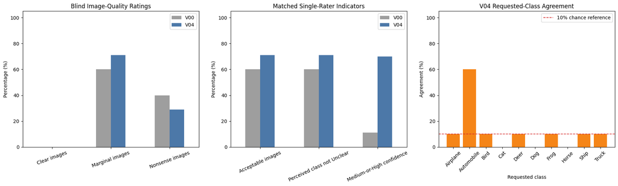

```
V04 quality summary:
```

|  | quality_rating | count | percentage |
| --- | --- | --- | --- |
| 0 | Clear | 0 | 0.0 |
| 1 | Marginal | 71 | 71.0 |
| 2 | Nonsense | 29 | 29.0 |

```
V04 confidence summary:
```

|  | confidence | count | percentage |
| --- | --- | --- | --- |
| 0 | High | 0 | 0.0 |
| 1 | Medium | 70 | 70.0 |
| 2 | Low | 30 | 30.0 |

```
V04 perceived-class summary:
```

|  | perceived_class | count | percentage |
| --- | --- | --- | --- |
| 0 | Airplane | 5 | 5.0 |
| 1 | Automobile | 13 | 13.0 |
| 2 | Bird | 12 | 12.0 |
| 3 | Cat | 8 | 8.0 |
| 4 | Deer | 2 | 2.0 |
| 5 | Dog | 12 | 12.0 |
| 6 | Frog | 3 | 3.0 |
| 7 | Horse | 2 | 2.0 |
| 8 | Ship | 11 | 11.0 |
| 9 | Truck | 3 | 3.0 |
| 10 | Unclear | 29 | 29.0 |

```
V04 requested-class summary:
```

|  | requested_class_name | sample_count | clear_count | marginal_count | nonsense_count | perceived_unclear_count | requested_class_match_count | acceptable_percentage | perceived_unclear_percentage | requested_class_match_percentage |
| --- | --- | --- | --- | --- | --- | --- | --- | --- | --- | --- |
| 0 | Airplane | 10 | 0 | 9 | 1 | 1 | 1 | 90.0 | 10.0 | 10.0 |
| 1 | Automobile | 10 | 0 | 9 | 1 | 1 | 6 | 90.0 | 10.0 | 60.0 |
| 2 | Bird | 10 | 0 | 6 | 4 | 4 | 1 | 60.0 | 40.0 | 10.0 |
| 3 | Cat | 10 | 0 | 8 | 2 | 2 | 0 | 80.0 | 20.0 | 0.0 |
| 4 | Deer | 10 | 0 | 5 | 5 | 5 | 1 | 50.0 | 50.0 | 10.0 |
| 5 | Dog | 10 | 0 | 7 | 3 | 3 | 0 | 70.0 | 30.0 | 0.0 |
| 6 | Frog | 10 | 0 | 7 | 3 | 3 | 1 | 70.0 | 30.0 | 10.0 |
| 7 | Horse | 10 | 0 | 7 | 3 | 3 | 0 | 70.0 | 30.0 | 0.0 |
| 8 | Ship | 10 | 0 | 8 | 2 | 2 | 1 | 80.0 | 20.0 | 10.0 |
| 9 | Truck | 10 | 0 | 5 | 5 | 5 | 1 | 50.0 | 50.0 | 10.0 |

```
V00 versus V04 manual comparison:
```

|  | metric | V00_percentage | V04_percentage | V04_minus_V00_percentage_points |
| --- | --- | --- | --- | --- |
| 0 | Clear images | 0.0 | 0.0 | 0.0 |
| 1 | Marginal images | 60.0 | 71.0 | 11.0 |
| 2 | Nonsense images | 40.0 | 29.0 | -11.0 |
| 3 | Acceptable images | 60.0 | 71.0 | 11.0 |
| 4 | Perceived class not Unclear | 60.0 | 71.0 | 11.0 |
| 5 | Medium-or-High confidence | 11.0 | 70.0 | 59.0 |
| 6 | Requested-class agreement | NaN | 12.0 | NaN |

```
V04 acceptable-image rate: 71.00%
V04 perceived class available: 71.00%
V04 requested-class agreement: 12/100 (12.00%)
Agreement among non-Unclear guesses: 16.90%
Manual summary figure: artifacts\vae\V04\formal_manual_evaluation\V04_manual_evaluation_summary.png
Requested-class scoring applicable to V00: No; V00 is unconditional.
Official test-set usage: None
```

```python
indicator_plot = (
    v00_v04_manual_comparison_df.iloc[
        3:6
    ].set_index("metric")
)
indicator_plot[[
    "V00_percentage",
    "V04_percentage"
]].plot(
    kind="bar",
    ax=axes[1],
    color=["#9E9E9E", "#4C78A8"]
)
axes[1].set_title(
    "Matched Single-Rater Indicators"
)
axes[1].set_xlabel("")
axes[1].set_ylabel("Percentage (%)")
axes[1].set_ylim(0, 105)
axes[1].tick_params(
    axis="x",
    rotation=25
)
axes[1].legend(["V00", "V04"])

axes[2].bar(
    v04_requested_class_summary_df[
        "requested_class_name"
    ],
    v04_requested_class_summary_df[
        "requested_class_match_percentage"
    ],
    color="#F58518"
)
axes[2].axhline(
    10.0,
    color="#D62728",
    linestyle="--",
    linewidth=1.2,
    label="10% chance reference"
)
axes[2].set_title(
    "V04 Requested-Class Agreement"
)
axes[2].set_xlabel("Requested class")
axes[2].set_ylabel("Agreement (%)")
axes[2].set_ylim(0, 105)
axes[2].tick_params(
    axis="x",
    rotation=45
)
axes[2].legend()

plt.tight_layout()
v04_manual_summary_figure_path = (
    v04_final_manual_dir
    / "V04_manual_evaluation_summary.png"
)
plt.savefig(
    v04_manual_summary_figure_path,
    dpi=150,
    bbox_inches="tight"
)
plt.show()

print("\nV04 quality summary:")
display(
    v04_manual_quality_summary_df.round(2)
)
print("\nV04 confidence summary:")
display(
    v04_manual_confidence_summary_df.round(2)
)
print("\nV04 perceived-class summary:")
display(
    v04_manual_perceived_summary_df.round(2)
)
print("\nV04 requested-class summary:")
display(
    v04_requested_class_summary_df.round(2)
)
print(
    "\nV00 versus V04 manual comparison:"
)
display(
    v00_v04_manual_comparison_df.round(2)
)

print(
    "\nV04 acceptable-image rate: "
    f"{v04_acceptable_rate:.2f}%"
)
print(
    "V04 perceived class available: "
    f"{v04_non_unclear_rate:.2f}%"
)
print(
    "V04 requested-class agreement: "
    f"{v04_requested_match_count}/100 "
    f"({v04_requested_match_rate:.2f}%)"
)
print(
    "Agreement among non-Unclear guesses: "
    f"{v04_match_given_non_unclear_rate:.2f}%"
)
print(
    "Manual summary figure: "
    f"{v04_manual_summary_figure_path}"
)
print(
    "Requested-class scoring applicable "
    "to V00: No; V00 is unconditional."
)
print("Official test-set usage: None")
```

### 12.3 Evidence-Based V04 Human-Evaluation Findings

#### Protocol validity

All 100 ratings passed validation before the requested-class key was joined. Every blind ID appeared exactly once, the sole rater was Aniq, all required fields were complete, every quality, perceived-class and confidence value used the permitted vocabulary, and every row followed the documented `Nonsense` ↔ `Unclear` scoring convention. The samples were balanced at 10 requested images per class, uncurated and generated without official test data.

#### Overall image quality

| Quality rating | V00 count | V00 percentage | V04 count | V04 percentage |
| --- | --- | --- | --- | --- |
| Clear | 0 | 0% | 0 | 0% |
| Marginal | 60 | 60% | 71 | 71% |
| Nonsense | 40 | 40% | 29 | 29% |
| **Acceptable (Clear + Marginal)** | **60** | **60%** | **71** | **71%** |

V04 increases the by-eye acceptable rate by **11 percentage points** and reduces the Nonsense rate by the same amount. This supports an improvement in plausibility over the selected V00 baseline. Nevertheless, no V04 image was rated Clear. The correct conclusion is therefore that V04 produces fewer incoherent outputs, not that it produces sharp or reliably recognisable CIFAR-10 objects.

The rater assigned a non-`Unclear` class to 71% of V04 images, compared with 60% for V00. Medium-or-High confidence also increased from 11% to 70%. However, V04 received no High-confidence rating, so the apparent improvement remains at the level of tentative recognition.

#### Requested-class agreement and class difficulty

V04 matched the hidden requested class for **12 of 100 images (12%)**. Among the 71 non-`Unclear` guesses, agreement was **16.90%**. The 10% line in the figure is only a descriptive random-guess reference for ten balanced classes; it is not a formal significance test. An overall result of 12% is therefore insufficient evidence of strong semantic class control.

| Requested class | Acceptable | Unclear | Requested-class match |
| --- | --- | --- | --- |
| Airplane | 90% | 10% | 10% |
| Automobile | 90% | 10% | **60%** |
| Bird | 60% | 40% | 10% |
| Cat | 80% | 20% | **0%** |
| Deer | 50% | 50% | 10% |
| Dog | 70% | 30% | **0%** |
| Frog | 70% | 30% | 10% |
| Horse | 70% | 30% | **0%** |
| Ship | 80% | 20% | 10% |
| Truck | 50% | 50% | 10% |

Automobile is the clearest positive result, with 60% requested-class agreement. Cat, Dog and Horse received no correct requested-class matches, while Deer and Truck had the highest `Unclear` rates at 50%. This suggests that V04 more readily expresses some vehicle-like patterns than visually overlapping animal classes. The claim remains provisional because there are only 10 images per requested class and one human rater.

The perceived-class distribution is also uneven despite balanced requested labels. Automobile, Bird, Dog and Ship were guessed relatively often, whereas Deer, Frog, Horse and Truck were rarely perceived. This indicates that the conditional decoder can favour recurring visual prototypes instead of following every requested label reliably.

#### Final interpretation

The human evidence complements rather than replaces the quantitative evaluation. It supports rather than overturns the provisional quantitative preference for V04: image plausibility improved over V00, while the weak 12% requested-class agreement remains an explicit limitation. Class conditioning changes generated outputs, but does not guarantee that a human recognises the requested class.

No further tuning is performed after viewing these ratings. This prevents the subjective development evaluation from becoming a new optimisation loop and preserves the declared V00-V05 quantitative screening process.

### 12.4 Final VAE Selection Confirmation

Section 11 provisionally selected V04 from the quantitative V00-V05 comparison. The blinded manual evaluation then increased the acceptable-image rate from **60% for V00 to 71% for V04** and reduced the Nonsense rate from **40% to 29%**. Although no image was rated Clear and requested-class agreement remained weak at **12%**, these limitations do not overturn V04's broader advantages in FID, reconstruction, SSIM, edge agreement, stability and efficiency.

Combining the quantitative and manual evidence, **V04 is confirmed as the final VAE-family model**. This is a within-family decision only; it does not determine the overall GAN-versus-VAE winner.

## 13. Final V04 Freeze, Export and Handoff

### 13.1 Freeze Decision

V04 at epoch 50 is frozen as the final VAE-family model. This decision uses the complete development evidence from Sections 5-12 and does not claim that V04 is already the overall GAN-versus-VAE winner.

The freeze fixes:

- conditional ConvTranspose encoder and decoder;
- latent dimension `64`;
- `β = 0.5`;
- summed L1 plus scaled SSIM reconstruction objective;
- Adam optimizer with learning rate `0.001`;
- epoch 50 weights;
- CIFAR-10 class order and one-hot conditioning; and
- `[0, 1]` RGB output preprocessing.

No architecture, objective, checkpoint or hyperparameter may be changed in response to later manual, FID or test results.

### 13.2 Export Contract

The export cell creates a self-contained `VAE_FINAL_V04` package containing:

- final VAE, encoder and decoder `.h5` weights;
- a standalone loadable conditional decoder;
- fixed latent vectors, class IDs and one-hot labels;
- the exact in-memory reference outputs used for later reload verification;
- V00-V05 selection evidence and V04 evaluation artefacts;
- the completed blind-scoring evidence;
- configuration and result-summary JSON files;
- file hashes and an export inventory; and
- a handoff manifest marked as pending independent reload verification.

The cell loads saved weights and performs inference only. It does not call `fit`, use the official test set, select between GAN and VAE, or generate the official 1,000-image submission.

```python
from datetime import datetime, timezone
from hashlib import sha256
import shutil


FINAL_VAE_EXPERIMENT_ID = "V04"
FINAL_VAE_CHECKPOINT_EPOCH = 50
FINAL_VAE_STATUS = (
    "frozen_pending_independent_"
    "reload_verification"
)

assert "encoder_v04" in globals()
assert "decoder_v04" in globals()
assert FINAL_VAE_EXPERIMENT_ID == "V04"
assert FINAL_VAE_CHECKPOINT_EPOCH == 50

final_v04_root = (
    Path("artifacts")
    / "vae"
    / "VAE_FINAL_V04"
)
final_v04_weights_dir = (
    final_v04_root / "weights"
)
final_v04_fixed_inputs_dir = (
    final_v04_root / "fixed_inputs"
)
final_v04_evaluation_dir = (
    final_v04_root / "evaluation"
)
final_v04_manual_dir = (
    final_v04_root / "manual_scoring"
)
final_v04_metadata_dir = (
    final_v04_root / "metadata"
)

for directory in [
    final_v04_root,
    final_v04_weights_dir,
    final_v04_fixed_inputs_dir,
    final_v04_evaluation_dir,
    final_v04_manual_dir,
    final_v04_metadata_dir
]:
    directory.mkdir(
        parents=True,
        exist_ok=True
    )

final_v04_manifest_path = (
    final_v04_root
    / "VAE_FINAL_V04_handoff_manifest.json"
)
if final_v04_manifest_path.exists():
    raise FileExistsError(
        "A completed V04 freeze manifest "
        "already exists. Do not silently "
        f"overwrite it: {final_v04_manifest_path}"
    )


def final_v04_file_sha256(file_path):
    digest = sha256()
    with Path(file_path).open(
        "rb"
    ) as source_file:
        for block in iter(
            lambda: source_file.read(
                1024 * 1024
            ),
            b""
        ):
            digest.update(block)
    return digest.hexdigest()


def verified_copy_v04(
    source_path,
    destination_path
):
    source_path = Path(source_path)
    destination_path = Path(
        destination_path
    )
    assert source_path.exists(), (
        f"Required source missing: "
        f"{source_path}"
    )
    destination_path.parent.mkdir(
        parents=True,
        exist_ok=True
    )
    shutil.copy2(
        source_path,
        destination_path
    )
    assert destination_path.exists()
    assert (
        final_v04_file_sha256(
            source_path
        )
        == final_v04_file_sha256(
            destination_path
        )
    )
    return destination_path


# -------------------------------------------------------
# 1. Freeze and verify the selected source weights
# -------------------------------------------------------
source_v04_weight_dir = (
    Path("artifacts")
    / "vae"
    / "V04"
    / "weights"
)
source_v04_vae_weights = (
    source_v04_weight_dir
    / "V04_vae_final.weights.h5"
)
source_v04_encoder_weights = (
    source_v04_weight_dir
    / "V04_encoder_final.weights.h5"
)
source_v04_decoder_weights = (
    source_v04_weight_dir
    / "V04_decoder_final.weights.h5"
)

for source_path in [
    source_v04_vae_weights,
    source_v04_encoder_weights,
    source_v04_decoder_weights
]:
    assert source_path.exists(), (
        f"Selected V04 weight file "
        f"missing: {source_path}"
    )

final_v04_vae_weights = (
    final_v04_weights_dir
    / "VAE_FINAL_V04_vae.weights.h5"
)
final_v04_encoder_weights = (
    final_v04_weights_dir
    / "VAE_FINAL_V04_encoder.weights.h5"
)
final_v04_decoder_weights = (
    final_v04_weights_dir
    / "VAE_FINAL_V04_decoder.weights.h5"
)

verified_copy_v04(
    source_v04_vae_weights,
    final_v04_vae_weights
)
verified_copy_v04(
    source_v04_encoder_weights,
    final_v04_encoder_weights
)
verified_copy_v04(
    source_v04_decoder_weights,
    final_v04_decoder_weights
)

encoder_v04.load_weights(
    str(final_v04_encoder_weights)
)
decoder_v04.load_weights(
    str(final_v04_decoder_weights)
)

assert encoder_v04.count_params() == 653_248
assert decoder_v04.count_params() == 394_307

# -------------------------------------------------------
# 2. Freeze the exact conditional inference inputs
# -------------------------------------------------------
fixed_input_source_dir = (
    Path("artifacts")
    / "vae"
    / "fixed_inputs"
)
source_fixed_latents = (
    fixed_input_source_dir
    / "fixed_latent_vectors_dim64.npy"
)
source_fixed_label_ids = (
    fixed_input_source_dir
    / "V03_fixed_conditional_label_ids.npy"
)
source_fixed_one_hot = (
    fixed_input_source_dir
    / (
        "V03_fixed_conditional_"
        "one_hot_labels.npy"
    )
)

final_v04_latent_path = (
    final_v04_fixed_inputs_dir
    / "VAE_FINAL_V04_fixed_latents.npy"
)
final_v04_label_ids_path = (
    final_v04_fixed_inputs_dir
    / "VAE_FINAL_V04_fixed_label_ids.npy"
)
final_v04_one_hot_path = (
    final_v04_fixed_inputs_dir
    / (
        "VAE_FINAL_V04_fixed_"
        "one_hot_labels.npy"
    )
)

verified_copy_v04(
    source_fixed_latents,
    final_v04_latent_path
)
verified_copy_v04(
    source_fixed_label_ids,
    final_v04_label_ids_path
)
verified_copy_v04(
    source_fixed_one_hot,
    final_v04_one_hot_path
)

final_v04_fixed_latents = np.load(
    final_v04_latent_path
).astype(np.float32)
final_v04_fixed_label_ids = np.load(
    final_v04_label_ids_path
).astype(np.int64)
final_v04_fixed_one_hot = np.load(
    final_v04_one_hot_path
).astype(np.float32)

assert final_v04_fixed_latents.shape == (
    100,
    64
)
assert final_v04_fixed_label_ids.shape == (
    100,
)
assert final_v04_fixed_one_hot.shape == (
    100,
    10
)
assert np.array_equal(
    np.bincount(
        final_v04_fixed_label_ids,
        minlength=10
    ),
    np.full(10, 10)
)
assert np.allclose(
    final_v04_fixed_one_hot.sum(
        axis=1
    ),
    1.0
)

final_v04_reference_outputs = np.clip(
    decoder_v04.predict(
        [
            final_v04_fixed_latents,
            final_v04_fixed_one_hot
        ],
        verbose=0
    ),
    0.0,
    1.0
).astype(np.float32)
assert final_v04_reference_outputs.shape == (
    100,
    32,
    32,
    3
)
assert np.isfinite(
    final_v04_reference_outputs
).all()

existing_v04_fixed_uint8 = np.load(
    Path("artifacts")
    / "vae"
    / "V04"
    / "evaluation"
    / "V04_fixed_requested_samples.npy"
)
reference_v04_uint8 = np.rint(
    final_v04_reference_outputs
    * 255.0
).astype(np.uint8)
assert np.array_equal(
    reference_v04_uint8,
    existing_v04_fixed_uint8
)
```

```python
final_v04_reference_outputs_path = (
    final_v04_fixed_inputs_dir
    / (
        "VAE_FINAL_V04_reference_"
        "outputs_float32.npy"
    )
)
final_v04_reference_uint8_path = (
    final_v04_fixed_inputs_dir
    / (
        "VAE_FINAL_V04_reference_"
        "outputs_uint8.npy"
    )
)
np.save(
    final_v04_reference_outputs_path,
    final_v04_reference_outputs
)
np.save(
    final_v04_reference_uint8_path,
    reference_v04_uint8
)

# Standalone inference model for Notebook 4.
final_v04_decoder_model = (
    final_v04_root
    / "VAE_FINAL_V04_decoder.keras"
)
decoder_v04.save(
    str(final_v04_decoder_model),
    include_optimizer=False,
    overwrite=True
)
assert final_v04_decoder_model.exists()

# -------------------------------------------------------
# 3. Copy evaluation and manual-scoring evidence
# -------------------------------------------------------
source_v04_evaluation_dir = (
    Path("artifacts")
    / "vae"
    / "V04"
    / "evaluation"
)
for source_path in (
    source_v04_evaluation_dir.glob("*")
):
    if source_path.is_file():
        verified_copy_v04(
            source_path,
            final_v04_evaluation_dir
            / source_path.name
        )

source_consolidated_dir = (
    Path("artifacts")
    / "vae"
    / "consolidated_selection"
)
for source_path in (
    source_consolidated_dir.glob("*")
):
    if source_path.is_file():
        verified_copy_v04(
            source_path,
            final_v04_evaluation_dir
            / source_path.name
        )

source_v04_manual_dir = (
    Path("artifacts")
    / "vae"
    / "V04"
    / "formal_manual_evaluation"
)
for source_path in (
    source_v04_manual_dir.glob("*")
):
    if source_path.is_file():
        verified_copy_v04(
            source_path,
            final_v04_manual_dir
            / source_path.name
        )

v04_training_sources = [
    (
        Path("artifacts")
        / "vae"
        / "V04"
        / "V04_training_history.csv"
    ),
    (
        Path("artifacts")
        / "vae"
        / "V04"
        / "V04_training_record.json"
    ),
    (
        Path("artifacts")
        / "vae"
        / "V04"
        / "V04_training_diagnostics.png"
    )
]
for source_path in v04_training_sources:
    verified_copy_v04(
        source_path,
        final_v04_evaluation_dir
        / source_path.name
    )

# -------------------------------------------------------
# 4. Save configuration and final development summary
# -------------------------------------------------------
freeze_timestamp_utc = (
    datetime.now(
        timezone.utc
    ).isoformat()
)

final_v04_configuration = {
    "selected_experiment_id": "V04",
    "selected_checkpoint_epoch": 50,
    "model_type": "conditional_vae",
    "encoder_decoder_family": (
        "conditional_convtranspose_vae"
    ),
    "input_shape": [32, 32, 3],
    "output_shape": [32, 32, 3],
    "output_range": [0.0, 1.0],
    "latent_dimension": 64,
    "number_of_classes": 10,
    "class_order": list(class_names),
    "conditioning": (
        "one_hot_in_encoder_and_decoder"
    ),
    "beta": 0.5,
    "reconstruction_objective": (
        "summed_l1_plus_0.1_times_"
        "3072_times_one_minus_ssim"
    ),
    "total_objective": (
        "reconstruction_plus_"
        "0.5_times_kl"
    ),
    "optimizer": "Adam",
    "learning_rate": 0.001,
    "batch_size": 128,
    "epochs": 50,
    "seed": int(SEED),
    "data_augmentation": None,
    "encoder_parameters": int(
        encoder_v04.count_params()
    ),
    "decoder_parameters": int(
        decoder_v04.count_params()
    ),
    "test_set_used": False,
    "frozen_at_utc": freeze_timestamp_utc
}
final_v04_configuration_path = (
    final_v04_metadata_dir
    / "VAE_FINAL_V04_configuration.json"
)
with final_v04_configuration_path.open(
    "w",
    encoding="utf-8"
) as configuration_file:
    json.dump(
        final_v04_configuration,
        configuration_file,
        indent=4
    )

consolidated_v04_df = pd.read_csv(
    source_consolidated_dir
    / "V00_V05_consolidated_comparison.csv"
)
selected_v04_row = (
    consolidated_v04_df[
        consolidated_v04_df[
            "experiment_id"
        ] == "V04"
    ].iloc[0]
)
manual_joined_for_freeze = pd.read_csv(
    source_v04_manual_dir
    / "V04_manual_scoring_joined_results.csv"
)

final_v04_summary = {
    "selected_experiment_id": "V04",
    "selection_scope": (
        "final_within_vae_family"
    ),
    "development_fid_mean": float(
        selected_v04_row["fid_mean"]
    ),
    "development_fid_std": float(
        selected_v04_row["fid_std"]
    ),
    "reconstruction_mse": float(
        selected_v04_row[
            "reconstruction_mse"
        ]
    ),
    "reconstruction_mae": float(
        selected_v04_row[
            "reconstruction_mae"
        ]
    ),
    "reconstruction_psnr_db": float(
        selected_v04_row[
            "reconstruction_psnr_db"
        ]
    ),
    "reconstruction_ssim": float(
        selected_v04_row[
            "reconstruction_ssim"
        ]
    ),
    "absolute_edge_gap": float(
        selected_v04_row[
            "absolute_edge_gap"
        ]
    ),
    "conditional_control_ratio": float(
        selected_v04_row[
            "conditional_control_ratio"
        ]
    ),
    "manual_sample_count": int(
        len(manual_joined_for_freeze)
    ),
    "manual_acceptable_percentage": float(
        manual_joined_for_freeze[
            "acceptable_image"
        ].mean() * 100.0
    ),
    "manual_nonsense_percentage": float(
        (
            manual_joined_for_freeze[
                quality_column
            ] == "Nonsense"
        ).mean() * 100.0
    ),
    "manual_requested_class_agreement": float(
        manual_joined_for_freeze[
            "requested_class_match"
        ].mean() * 100.0
    ),
    "manual_rater_count": 1,
    "key_limitations": [
        (
            "No generated image received "
            "a Clear quality rating."
        ),
        (
            "Requested-class agreement "
            "was close to the 10% random-"
            "guess reference."
        ),
        (
            "The manual evaluation used "
            "one rater and ten images per "
            "requested class."
        )
    ],
    "test_set_used": False,
    "overall_gan_vae_selection_completed": False
}
final_v04_summary_path = (
    final_v04_metadata_dir
    / "VAE_FINAL_V04_development_summary.json"
)
with final_v04_summary_path.open(
    "w",
    encoding="utf-8"
) as summary_file:
    json.dump(
        final_v04_summary,
        summary_file,
        indent=4
    )
```

```python
# File inventory excludes the manifest itself.
inventory_records_v04 = []
for exported_path in sorted(
    path
    for path in final_v04_root.rglob("*")
    if path.is_file()
):
    inventory_records_v04.append({
        "relative_path": str(
            exported_path.relative_to(
                final_v04_root
            )
        ),
        "size_bytes": int(
            exported_path.stat().st_size
        ),
        "sha256": (
            final_v04_file_sha256(
                exported_path
            )
        )
    })

final_v04_inventory_df = pd.DataFrame(
    inventory_records_v04
)
final_v04_inventory_path = (
    final_v04_metadata_dir
    / "VAE_FINAL_V04_export_inventory.csv"
)
final_v04_inventory_df.to_csv(
    final_v04_inventory_path,
    index=False
)

final_v04_manifest = {
    "status": FINAL_VAE_STATUS,
    "selected_experiment_id": (
        FINAL_VAE_EXPERIMENT_ID
    ),
    "selected_checkpoint_epoch": (
        FINAL_VAE_CHECKPOINT_EPOCH
    ),
    "frozen_at_utc": freeze_timestamp_utc,
    "standalone_decoder": str(
        final_v04_decoder_model
    ),
    "weights": {
        "vae": str(
            final_v04_vae_weights
        ),
        "encoder": str(
            final_v04_encoder_weights
        ),
        "decoder": str(
            final_v04_decoder_weights
        )
    },
    "fixed_inputs": {
        "latents": str(
            final_v04_latent_path
        ),
        "label_ids": str(
            final_v04_label_ids_path
        ),
        "one_hot_labels": str(
            final_v04_one_hot_path
        ),
        "reference_outputs_float32": str(
            final_v04_reference_outputs_path
        ),
        "reference_outputs_uint8": str(
            final_v04_reference_uint8_path
        )
    },
    "configuration": str(
        final_v04_configuration_path
    ),
    "development_summary": str(
        final_v04_summary_path
    ),
    "export_inventory": str(
        final_v04_inventory_path
    ),
    "manual_scoring_directory": str(
        final_v04_manual_dir
    ),
    "evaluation_directory": str(
        final_v04_evaluation_dir
    ),
    "reload_verification": {
        "status": "pending",
        "required_next_step": True
    },
    "test_set_used": False,
    "official_1000_images_generated": False,
    "overall_gan_vae_selection_completed": False,
    "next_notebook": (
        "04 shared frozen GAN-versus-VAE "
        "comparison"
    )
}
with final_v04_manifest_path.open(
    "w",
    encoding="utf-8"
) as manifest_file:
    json.dump(
        final_v04_manifest,
        manifest_file,
        indent=4
    )

required_final_paths_v04 = [
    final_v04_vae_weights,
    final_v04_encoder_weights,
    final_v04_decoder_weights,
    final_v04_decoder_model,
    final_v04_latent_path,
    final_v04_label_ids_path,
    final_v04_one_hot_path,
    final_v04_reference_outputs_path,
    final_v04_reference_uint8_path,
    final_v04_configuration_path,
    final_v04_summary_path,
    final_v04_inventory_path,
    final_v04_manifest_path
]
for required_path in (
    required_final_paths_v04
):
    assert required_path.exists()
    assert required_path.stat().st_size > 0

print("V04 freeze and export completed.")
print(
    "Freeze status: "
    f"{FINAL_VAE_STATUS}"
)
print(
    "Frozen decoder: "
    f"{final_v04_decoder_model}"
)
print(
    "Handoff manifest: "
    f"{final_v04_manifest_path}"
)
print(
    "Inventory rows before manifest: "
    f"{len(final_v04_inventory_df)}"
)
print(
    "Fixed outputs match the existing "
    "V04 evaluation samples: Yes"
)
print("Model retrained: No")
print("Official test-set usage: None")
print(
    "Independent reload verification: "
    "Pending"
)
```

```
WARNING:tensorflow:Compiled the loaded model, but the compiled metrics have yet to be built. `model.compile_metrics` will be empty until you train or evaluate the model.
V04 freeze and export completed.
Freeze status: frozen_pending_independent_reload_verification
Frozen decoder: artifacts\vae\VAE_FINAL_V04\VAE_FINAL_V04_decoder.keras
Handoff manifest: artifacts\vae\VAE_FINAL_V04\VAE_FINAL_V04_handoff_manifest.json
Inventory rows before manifest: 48
Fixed outputs match the existing V04 evaluation samples: Yes
Model retrained: No
Official test-set usage: None
Independent reload verification: Pending
```

### 13.3 Independent Decoder Reload Verification

The export is not considered complete merely because files were written. The next cell verifies the package independently:

1. recheck every file recorded in the export inventory using its size and SHA-256 hash;
2. load the exported standalone decoder from disk with `compile=False`;
3. load the frozen latent vectors, one-hot labels and reference outputs from the package;
4. regenerate all 100 images using only the reloaded decoder;
5. compare the regenerated floating-point and uint8 outputs with the frozen references;
6. verify shape, numerical range, finiteness, balance and sample uniqueness;
7. save a reloaded-output verification grid and JSON record; and
8. update the handoff manifest to `frozen_and_reload_verified` only after every assertion passes.

The TensorFlow message about compiled metrics during export is harmless because this decoder is an inference model and is loaded with `compile=False`. This verification does not retrain the model or use the official test set.

```python
from datetime import datetime, timezone
from hashlib import sha256


final_v04_root_reload = (
    Path("artifacts")
    / "vae"
    / "VAE_FINAL_V04"
)
final_v04_decoder_model_reload = (
    final_v04_root_reload
    / "VAE_FINAL_V04_decoder.keras"
)
final_v04_manifest_path_reload = (
    final_v04_root_reload
    / "VAE_FINAL_V04_handoff_manifest.json"
)
final_v04_inventory_path_reload = (
    final_v04_root_reload
    / "metadata"
    / "VAE_FINAL_V04_export_inventory.csv"
)
final_v04_latent_path_reload = (
    final_v04_root_reload
    / "fixed_inputs"
    / "VAE_FINAL_V04_fixed_latents.npy"
)
final_v04_label_ids_path_reload = (
    final_v04_root_reload
    / "fixed_inputs"
    / "VAE_FINAL_V04_fixed_label_ids.npy"
)
final_v04_one_hot_path_reload = (
    final_v04_root_reload
    / "fixed_inputs"
    / (
        "VAE_FINAL_V04_fixed_"
        "one_hot_labels.npy"
    )
)
final_v04_reference_path_reload = (
    final_v04_root_reload
    / "fixed_inputs"
    / (
        "VAE_FINAL_V04_reference_"
        "outputs_float32.npy"
    )
)
final_v04_reference_uint8_path_reload = (
    final_v04_root_reload
    / "fixed_inputs"
    / (
        "VAE_FINAL_V04_reference_"
        "outputs_uint8.npy"
    )
)
final_v04_evaluation_dir_reload = (
    final_v04_root_reload
    / "evaluation"
)

required_reload_paths_v04 = [
    final_v04_decoder_model_reload,
    final_v04_manifest_path_reload,
    final_v04_inventory_path_reload,
    final_v04_latent_path_reload,
    final_v04_label_ids_path_reload,
    final_v04_one_hot_path_reload,
    final_v04_reference_path_reload,
    final_v04_reference_uint8_path_reload
]
for required_path in (
    required_reload_paths_v04
):
    assert required_path.exists(), (
        "Required frozen V04 file "
        f"missing: {required_path}"
    )


def reload_file_sha256_v04(file_path):
    digest = sha256()
    with Path(file_path).open(
        "rb"
    ) as source_file:
        for block in iter(
            lambda: source_file.read(
                1024 * 1024
            ),
            b""
        ):
            digest.update(block)
    return digest.hexdigest()


# Validate the original export inventory before
# loading the decoder.
original_inventory_v04 = pd.read_csv(
    final_v04_inventory_path_reload
)
assert len(original_inventory_v04) > 0
for inventory_row in (
    original_inventory_v04.itertuples(
        index=False
    )
):
    inventory_file_path = (
        final_v04_root_reload
        / inventory_row.relative_path
    )
    assert inventory_file_path.exists(), (
        f"Inventoried file missing: "
        f"{inventory_file_path}"
    )
    assert (
        inventory_file_path.stat().st_size
        == int(inventory_row.size_bytes)
    )
    assert (
        reload_file_sha256_v04(
            inventory_file_path
        )
        == inventory_row.sha256
    )

with final_v04_manifest_path_reload.open(
    "r",
    encoding="utf-8"
) as manifest_file:
    pending_manifest_v04 = json.load(
        manifest_file
    )

assert pending_manifest_v04["status"] == (
    "frozen_pending_independent_"
    "reload_verification"
)
assert (
    pending_manifest_v04[
        "reload_verification"
    ]["status"]
    == "pending"
)
assert (
    pending_manifest_v04[
        "test_set_used"
    ]
    is False
)

# Load the standalone decoder from disk. No
# in-memory V04 model is used for prediction.
reloaded_decoder_v04 = (
    keras.models.load_model(
        str(
            final_v04_decoder_model_reload
        ),
        compile=False
    )
)

reloaded_latents_v04 = np.load(
    final_v04_latent_path_reload
).astype(np.float32)
reloaded_label_ids_v04 = np.load(
    final_v04_label_ids_path_reload
).astype(np.int64)
reloaded_one_hot_v04 = np.load(
    final_v04_one_hot_path_reload
).astype(np.float32)
reference_outputs_v04 = np.load(
    final_v04_reference_path_reload
).astype(np.float32)
reference_uint8_v04 = np.load(
    final_v04_reference_uint8_path_reload
)

assert reloaded_latents_v04.shape == (
    100,
    64
)
assert reloaded_label_ids_v04.shape == (
    100,
)
assert reloaded_one_hot_v04.shape == (
    100,
    10
)
assert reference_outputs_v04.shape == (
    100,
    32,
    32,
    3
)
assert reference_uint8_v04.shape == (
    100,
    32,
    32,
    3
)
assert reference_uint8_v04.dtype == np.uint8
assert np.array_equal(
    np.bincount(
        reloaded_label_ids_v04,
        minlength=10
    ),
    np.full(10, 10)
)

reloaded_outputs_v04 = np.clip(
    reloaded_decoder_v04.predict(
        [
            reloaded_latents_v04,
            reloaded_one_hot_v04
        ],
        verbose=0
    ),
    0.0,
    1.0
).astype(np.float32)

assert reloaded_outputs_v04.shape == (
    100,
    32,
    32,
    3
)
assert np.isfinite(
    reloaded_outputs_v04
).all()
assert reloaded_outputs_v04.min() >= 0.0
assert reloaded_outputs_v04.max() <= 1.0

maximum_absolute_difference_v04 = float(
    np.max(
        np.abs(
            reloaded_outputs_v04
            - reference_outputs_v04
        )
    )
)
mean_absolute_difference_v04 = float(
    np.mean(
        np.abs(
            reloaded_outputs_v04
            - reference_outputs_v04
        )
    )
)
reloaded_uint8_v04 = np.rint(
    reloaded_outputs_v04 * 255.0
).astype(np.uint8)
reloaded_unique_count_v04 = int(
    len(
        np.unique(
            reloaded_uint8_v04.reshape(
                100,
                -1
            ),
            axis=0
        )
    )
)
uint8_exact_match_v04 = bool(
    np.array_equal(
        reloaded_uint8_v04,
        reference_uint8_v04
    )
)

assert maximum_absolute_difference_v04 <= 1e-6
assert uint8_exact_match_v04
assert reloaded_unique_count_v04 == 100

# Save a class-balanced verification grid.
fig, axes = plt.subplots(
    10,
    10,
    figsize=(14, 14)
)
for class_id, class_name in enumerate(
    class_names
):
    class_positions = np.where(
        reloaded_label_ids_v04 == class_id
    )[0]
    assert len(class_positions) == 10

    for draw_index, sample_index in enumerate(
        class_positions
    ):
        axis = axes[
            class_id,
            draw_index
        ]
        axis.imshow(
            reloaded_outputs_v04[
                sample_index
            ]
        )
        axis.axis("off")

        if class_id == 0:
            axis.set_title(
                f"Draw {draw_index + 1}",
                fontsize=8
            )
        if draw_index == 0:
            axis.text(
                -0.25,
                0.5,
                class_name,
                transform=axis.transAxes,
                rotation=90,
                va="center",
                ha="right",
                fontsize=9
            )

fig.suptitle(
    (
        "Reloaded VAE_FINAL_V04 "
        "Decoder Verification"
    ),
    fontsize=14
)
plt.tight_layout()
v04_reload_grid_path = (
    final_v04_evaluation_dir_reload
    / (
        "VAE_FINAL_V04_reload_"
        "verification_grid.png"
    )
)
plt.savefig(
    v04_reload_grid_path,
    dpi=150,
    bbox_inches="tight"
)
plt.show()

reload_verified_at_utc_v04 = (
    datetime.now(
        timezone.utc
    ).isoformat()
)
v04_reload_metrics = {
    "selected_experiment_id": "V04",
    "standalone_decoder": str(
        final_v04_decoder_model_reload
    ),
    "verified_at_utc": (
        reload_verified_at_utc_v04
    ),
    "output_shape": list(
        reloaded_outputs_v04.shape
    ),
    "output_min": float(
        reloaded_outputs_v04.min()
    ),
    "output_max": float(
        reloaded_outputs_v04.max()
    ),
    "maximum_absolute_difference": (
        maximum_absolute_difference_v04
    ),
    "mean_absolute_difference": (
        mean_absolute_difference_v04
    ),
    "uint8_exact_match": (
        uint8_exact_match_v04
    ),
    "unique_uint8_images_out_of_100": (
        reloaded_unique_count_v04
    ),
    "balanced_requested_classes": True,
    "test_set_used": False,
    "status": "passed"
}
v04_reload_metrics_path = (
    final_v04_evaluation_dir_reload
    / (
        "VAE_FINAL_V04_reload_"
        "verification.json"
    )
)
with v04_reload_metrics_path.open(
    "w",
    encoding="utf-8"
) as metrics_file:
    json.dump(
        v04_reload_metrics,
        metrics_file,
        indent=4
    )

# Rebuild the inventory to include the new reload
# artefacts. The inventory and manifest are excluded
# from their own hashes.
updated_inventory_records_v04 = []
for exported_path in sorted(
    path
    for path in final_v04_root_reload.rglob("*")
    if (
        path.is_file()
        and path
        not in {
            final_v04_inventory_path_reload,
            final_v04_manifest_path_reload
        }
    )
):
    updated_inventory_records_v04.append({
        "relative_path": str(
            exported_path.relative_to(
                final_v04_root_reload
            )
        ),
        "size_bytes": int(
            exported_path.stat().st_size
        ),
        "sha256": (
            reload_file_sha256_v04(
                exported_path
            )
        )
    })

updated_inventory_v04 = pd.DataFrame(
    updated_inventory_records_v04
)
updated_inventory_v04.to_csv(
    final_v04_inventory_path_reload,
    index=False
)

pending_manifest_v04["status"] = (
    "frozen_and_reload_verified"
)
pending_manifest_v04[
    "reload_verification"
] = {
    "status": "passed",
    "verified_at_utc": (
        reload_verified_at_utc_v04
    ),
    "metrics": str(
        v04_reload_metrics_path
    ),
    "grid": str(
        v04_reload_grid_path
    ),
    "maximum_absolute_difference": (
        maximum_absolute_difference_v04
    ),
    "uint8_exact_match": (
        uint8_exact_match_v04
    ),
    "unique_uint8_images_out_of_100": (
        reloaded_unique_count_v04
    )
}

with final_v04_manifest_path_reload.open(
    "w",
    encoding="utf-8"
) as manifest_file:
    json.dump(
        pending_manifest_v04,
        manifest_file,
        indent=4
    )

with final_v04_manifest_path_reload.open(
    "r",
    encoding="utf-8"
) as manifest_file:
    verified_manifest_v04 = json.load(
        manifest_file
    )

assert verified_manifest_v04["status"] == (
    "frozen_and_reload_verified"
)
assert (
    verified_manifest_v04[
        "reload_verification"
    ]["status"]
    == "passed"
)
assert (
    verified_manifest_v04[
        "test_set_used"
    ]
    is False
)

print(
    "V04 independent reload "
    "verification passed."
)
print(
    "Maximum absolute difference: "
    f"{maximum_absolute_difference_v04:.10f}"
)
print(
    "Mean absolute difference: "
    f"{mean_absolute_difference_v04:.10f}"
)
print(
    "Exact uint8 match: "
    f"{uint8_exact_match_v04}"
)
print(
    "Unique generated images: "
    f"{reloaded_unique_count_v04}/100"
)
print(
    "Updated inventory rows: "
    f"{len(updated_inventory_v04)}"
)
print(
    "Final manifest status: "
    f"{verified_manifest_v04['status']}"
)
print("Model retrained: No")
print("Official test-set usage: None")
```

[figure not shown]

```
V04 independent reload verification passed.
Maximum absolute difference: 0.0000000000
Mean absolute difference: 0.0000000000
Exact uint8 match: True
Unique generated images: 100/100
Updated inventory rows: 50
Final manifest status: frozen_and_reload_verified
Model retrained: No
Official test-set usage: None
```

### 13.4 Executed Reload-Verification Findings

The independent verification completed successfully at **2026-07-26 06:35:24 UTC**. Before loading the model, every file in the original export inventory passed its recorded size and SHA-256 check.

The standalone decoder was then loaded from the exported package using `compile=False`. It regenerated all 100 frozen class-balanced samples from the saved latent vectors and one-hot labels with:

- output shape: `(100, 32, 32, 3)`;
- output range: `0.009008` to `0.997995`;
- maximum absolute difference from the frozen float32 reference: **0.0**;
- mean absolute difference: **0.0**;
- exact uint8 match: **True**; and
- unique uint8 images: **100 / 100**.

The exported decoder therefore reproduces the reference outputs exactly without rebuilding the architecture or retraining. The verification grid and metrics JSON were added to the package, the inventory was updated to 50 hashed files, and the manifest status changed only after all assertions passed:

`frozen_and_reload_verified`

The TensorFlow compiled-metrics warning shown during export is expected. The standalone decoder is used only for inference and was deliberately reloaded with `compile=False`; the warning does not affect its outputs.

### 13.5 Post-Selection Latent-Space Diagnostic with t-SNE

**Target model:** Frozen `VAE_FINAL_V04` only  
**Execution status:** Completed, artifact-audited, and interpreted using the executed output.

This subsection examines the frozen final encoder only after V04 had already been selected, exported, and independently reload-verified. It is therefore a **post-selection diagnostic**, not a model-selection experiment.

The analysis:

- loads the frozen V04 encoder weights;
- uses a fixed, class-balanced sample from the CIFAR-10 training split only;
- extracts deterministic 64-dimensional `z_mean` vectors;
- applies one fixed t-SNE configuration;
- retains the executed plot and artifact audit; and
- does not retrain the VAE, alter any weight, reopen checkpoint selection, or access the official test set.

The generated t-SNE files are additional evaluation artefacts. They do not change the frozen V04 model, checkpoint, handoff status, or previously verified inference outputs.

#### 13.5.1 Question, Method, and Interpretation Boundary

**Question:** How are CIFAR-10 training images arranged in the frozen V04 encoder's 64-dimensional latent mean representation, `z_mean`?

**Method:**

- draw a fixed, class-balanced sample of 2,000 CIFAR-10 training images, with 200 images per class;
- preprocess images to `float32 [0, 1]`;
- provide each image's true one-hot class label to the final conditional encoder;
- extract deterministic `z_mean` vectors rather than randomly sampled `z` vectors;
- project the 64-dimensional vectors to two dimensions using one fixed t-SNE configuration; and
- colour the points using the known CIFAR-10 class labels.

**Important boundary:** V04 is conditional. The true class label is supplied to the encoder, so visible class separation cannot be presented as unsupervised class discovery. The plot only visualises the class-conditioned latent representation learned by the final encoder.

**t-SNE limitation:** t-SNE is mainly useful for local neighbourhood patterns. The axes have no direct semantic meaning, distances between far-apart groups can be misleading, and the visible arrangement depends on the fixed t-SNE settings and sample.

```python
# Imports and environment check.
from pathlib import Path
import hashlib
import inspect
import json
import sys
import time
import warnings

import matplotlib.pyplot as plt
import numpy as np
import pandas as pd
import sklearn
from sklearn.manifold import TSNE
import tensorflow as tf
from tensorflow import keras
from tensorflow.keras import layers

print(f"Python version: {sys.version.split()[0]}")
print(f"TensorFlow version: {tf.__version__}")
print(f"Keras version: {getattr(keras, '__version__', 'bundled with TensorFlow')}")
print(f"scikit-learn version: {sklearn.__version__}")

if not str(tf.__version__).startswith("2.10"):
    warnings.warn(
        "This notebook was written for TensorFlow/Keras 2.10. "
        "The code may still run elsewhere, but the required assignment "
        "environment is TensorFlow/Keras 2.10."
    )
```

```
Python version: 3.8.20
TensorFlow version: 2.10.0
Keras version: 2.10.0
scikit-learn version: 1.3.2
```

#### 13.5.2 Path and Run Configuration

The code searches for `VAE_FINAL_V04_handoff_manifest.json` in the current folder, its parent folders, and the expected nested path `artifacts/vae/VAE_FINAL_V04`. The manifest is then used to locate the exact frozen encoder weights.

Only edit `MANIFEST_PATH_OVERRIDE` or `PROJECT_ROOT_OVERRIDE` when the project files are stored elsewhere. Leave both as `None` when the notebook is placed either in the main VAE project folder or inside the frozen `VAE_FINAL_V04` package.

The t-SNE settings were fixed before viewing the result. They were not tuned to make the projection appear cleaner.

```python
# Reproducible configuration.
SEED = 42
NUM_CLASSES = 10
LATENT_DIM = 64
SAMPLES_PER_CLASS = 200
TOTAL_TSNE_SAMPLES = NUM_CLASSES * SAMPLES_PER_CLASS
ENCODER_BATCH_SIZE = 256

TSNE_PERPLEXITY = 30.0
TSNE_LEARNING_RATE = 200.0
TSNE_ITERATIONS = 1_000
TSNE_RANDOM_STATE = 42

CLASS_NAMES = np.array([
    "Airplane",
    "Automobile",
    "Bird",
    "Cat",
    "Deer",
    "Dog",
    "Frog",
    "Horse",
    "Ship",
    "Truck"
])

# Optional manual overrides. Use raw strings for Windows paths.
MANIFEST_PATH_OVERRIDE = None
PROJECT_ROOT_OVERRIDE = None

FORCE_RECOMPUTE_LATENTS = False
FORCE_RECOMPUTE_TSNE = False


def find_manifest(filename="VAE_FINAL_V04_handoff_manifest.json"):
    if MANIFEST_PATH_OVERRIDE is not None:
        candidate = Path(MANIFEST_PATH_OVERRIDE).expanduser().resolve()
        if not candidate.is_file():
            raise FileNotFoundError(
                f"Manifest override does not exist: {candidate}"
            )
        return candidate

    start = Path.cwd().resolve()
    search_bases = [start, *start.parents]
    for base in search_bases:
        candidates = [
            base / filename,
            base / "artifacts" / "vae" / "VAE_FINAL_V04" / filename
        ]
        for candidate in candidates:
            if candidate.is_file():
                return candidate

    raise FileNotFoundError(
        f"Could not find {filename} from {start}. "
        "Place this notebook in the main VAE project folder or the "
        "frozen VAE_FINAL_V04 folder, or set MANIFEST_PATH_OVERRIDE "
        "in this cell."
    )


manifest_path = find_manifest()
with manifest_path.open("r", encoding="utf-8") as manifest_file:
    manifest = json.load(manifest_file)

if PROJECT_ROOT_OVERRIDE is None:
    project_root = manifest_path.parent.resolve()
else:
    project_root = Path(PROJECT_ROOT_OVERRIDE).expanduser().resolve()


def resolve_manifest_artifact(raw_path, must_exist=True):
    normalized = Path(str(raw_path).replace("\\", "/"))

    if normalized.is_absolute():
        candidates = [normalized]
    else:
        candidates = [
            project_root / normalized,
            manifest_path.parent / normalized,
            Path.cwd().resolve() / normalized
        ]

    for candidate in candidates:
        if candidate.exists():
            return candidate.resolve()

    # Fallback for a moved project folder with the same filenames.
    matches = list(project_root.rglob(normalized.name))
    if len(matches) == 1:
        return matches[0].resolve()

    if must_exist:
        attempted = "\n".join(f"- {path}" for path in candidates)
        raise FileNotFoundError(
            f"Could not resolve artifact path: {raw_path}\n"
            f"Attempted:\n{attempted}\n"
            "Set PROJECT_ROOT_OVERRIDE to the folder containing the "
            "artifacts directory when necessary."
        )

    return (project_root / normalized).resolve()


assert manifest.get("status") == "frozen_and_reload_verified"
assert manifest.get("selected_experiment_id") == "V04"
assert int(manifest.get("selected_checkpoint_epoch")) == 50
assert manifest.get("test_set_used") is False

encoder_weights_path = resolve_manifest_artifact(
    manifest["weights"]["encoder"]
)
evaluation_root = resolve_manifest_artifact(
    manifest["evaluation_directory"],
    must_exist=False
)
tsne_output_dir = evaluation_root / "tsne"
tsne_output_dir.mkdir(parents=True, exist_ok=True)

latent_cache_path = (
    tsne_output_dir / "VAE_FINAL_V04_tsne_z_mean_cache.npz"
)
tsne_csv_path = (
    tsne_output_dir / "VAE_FINAL_V04_tsne_embedding.csv"
)
tsne_metadata_path = (
    tsne_output_dir / "VAE_FINAL_V04_tsne_metadata.json"
)
tsne_plot_path = (
    tsne_output_dir / "VAE_FINAL_V04_tsne_z_mean.png"
)

print(f"Manifest: {manifest_path}")
print(f"Project root: {project_root}")
print(f"Final encoder weights: {encoder_weights_path}")
print(f"t-SNE output directory: {tsne_output_dir}")
print("Selected model: V04, checkpoint epoch 50")
print("Model retraining required: No")
print("Official test-set usage: None")
```

```
Manifest: [local path removed]
Project root: [local path removed]
Final encoder weights: [local path removed]
t-SNE output directory: [local path removed]
Selected model: V04, checkpoint epoch 50
Model retraining required: No
Official test-set usage: None
```

#### 13.5.3 Exact Final V04 Encoder Reconstruction

The next cell rebuilds only the final V04 conditional encoder and loads `VAE_FINAL_V04_encoder.weights.h5`.

The architecture must match the frozen model exactly:

```
RGB image, 32 x 32 x 3
-> Conv2D 32
-> Conv2D 64
-> Conv2D 128
-> Flatten
-> concatenate true one-hot class label
-> Dense 256
-> z_mean, 64 values
-> z_log_var, 64 values
-> sampling layer
```

The t-SNE analysis uses `z_mean`. The full VAE and decoder are not needed.

```python
class V04Sampling(layers.Layer):
    """Keras 2.10-compatible VAE reparameterisation layer."""

    def call(self, inputs):
        z_mean, z_log_var = inputs
        batch_size = tf.shape(z_mean)[0]
        latent_dimension = tf.shape(z_mean)[1]
        epsilon = tf.random.normal(
            shape=(batch_size, latent_dimension)
        )
        return z_mean + tf.exp(0.5 * z_log_var) * epsilon


def build_final_v04_encoder():
    """Rebuild the exact frozen V04 conditional encoder."""
    tf.keras.utils.set_random_seed(SEED)

    image_inputs = keras.Input(
        shape=(32, 32, 3),
        name="V04_encoder_image_input"
    )
    label_inputs = keras.Input(
        shape=(NUM_CLASSES,),
        name="V04_encoder_label_input"
    )

    x = layers.Conv2D(
        32,
        kernel_size=3,
        strides=2,
        padding="same",
        activation="relu",
        name="V04_encoder_conv_1"
    )(image_inputs)
    x = layers.Conv2D(
        64,
        kernel_size=3,
        strides=2,
        padding="same",
        activation="relu",
        name="V04_encoder_conv_2"
    )(x)
    x = layers.Conv2D(
        128,
        kernel_size=3,
        strides=2,
        padding="same",
        activation="relu",
        name="V04_encoder_conv_3"
    )(x)
    x = layers.Flatten(
        name="V04_encoder_flatten"
    )(x)
    x = layers.Concatenate(
        name="V04_encoder_feature_label_concat"
    )([x, label_inputs])
    x = layers.Dense(
        256,
        activation="relu",
        name="V04_encoder_dense"
    )(x)

    z_mean = layers.Dense(
        LATENT_DIM,
        name="V04_z_mean"
    )(x)
    z_log_var = layers.Dense(
        LATENT_DIM,
        name="V04_z_log_var"
    )(x)
    z = V04Sampling(
        name="V04_z_sampling"
    )([z_mean, z_log_var])

    encoder = keras.Model(
        inputs=[image_inputs, label_inputs],
        outputs=[z_mean, z_log_var, z],
        name="V04_conditional_encoder"
    )

    expected_parameter_count = 653_248
    actual_parameter_count = encoder.count_params()
    if actual_parameter_count != expected_parameter_count:
        raise ValueError(
            "V04 encoder architecture mismatch. "
            f"Expected {expected_parameter_count:,} parameters, "
            f"found {actual_parameter_count:,}."
        )

    encoder.load_weights(str(encoder_weights_path))
    return encoder


# Lightweight validation. This does not train the model.
encoder_v04_tsne = build_final_v04_encoder()
print(f"Encoder name: {encoder_v04_tsne.name}")
print(f"Encoder parameters: {encoder_v04_tsne.count_params():,}")
print("Final encoder weights loaded: Yes")
print("Model retrained: No")
```

```
Encoder name: V04_conditional_encoder
Encoder parameters: 653,248
Final encoder weights loaded: Yes
Model retrained: No
```

#### 13.5.4 Balanced Training Sample and Latent Extraction

A class-balanced subset avoids allowing one class to dominate the visual density. The sample is drawn once using seed 42 and cached together with its `z_mean` and `z_log_var` outputs.

The cache makes the workflow modular. After the latent cache has been created, the t-SNE and plotting cells can be rerun without rebuilding the model or re-encoding the images.

```python
def select_balanced_training_indices(class_ids, samples_per_class, seed):
    rng = np.random.default_rng(seed)
    selected = []

    for class_id in range(NUM_CLASSES):
        available = np.flatnonzero(class_ids == class_id)
        if len(available) < samples_per_class:
            raise ValueError(
                f"Class {class_id} has only {len(available)} images."
            )
        chosen = rng.choice(
            available,
            size=samples_per_class,
            replace=False
        )
        selected.append(chosen)

    selected = np.concatenate(selected)
    return selected[rng.permutation(len(selected))]


def load_or_create_v04_latent_cache(force=False):
    if latent_cache_path.is_file() and not force:
        with np.load(latent_cache_path) as cached:
            result = {
                "sample_indices": cached["sample_indices"],
                "class_ids": cached["class_ids"],
                "z_mean": cached["z_mean"],
                "z_log_var": cached["z_log_var"]
            }
        print(f"Loaded existing latent cache: {latent_cache_path}")
    else:
        # Load the official dataset but use the 50,000-image training split only.
        (x_train_uint8, y_train_raw), _ = (
            keras.datasets.cifar10.load_data()
        )
        y_train = y_train_raw.reshape(-1).astype(np.int64)

        sample_indices = select_balanced_training_indices(
            class_ids=y_train,
            samples_per_class=SAMPLES_PER_CLASS,
            seed=SEED
        )
        sample_images = (
            x_train_uint8[sample_indices].astype(np.float32) / 255.0
        )
        sample_class_ids = y_train[sample_indices]
        sample_one_hot = keras.utils.to_categorical(
            sample_class_ids,
            num_classes=NUM_CLASSES
        ).astype(np.float32)

        encoder = build_final_v04_encoder()
        z_mean, z_log_var, _ = encoder.predict(
            [sample_images, sample_one_hot],
            batch_size=ENCODER_BATCH_SIZE,
            verbose=1
        )

        result = {
            "sample_indices": sample_indices.astype(np.int32),
            "class_ids": sample_class_ids.astype(np.int64),
            "z_mean": z_mean.astype(np.float32),
            "z_log_var": z_log_var.astype(np.float32)
        }

        np.savez_compressed(
            latent_cache_path,
            **result
        )
        print(f"Saved latent cache: {latent_cache_path}")

    assert result["sample_indices"].shape == (TOTAL_TSNE_SAMPLES,)
    assert result["class_ids"].shape == (TOTAL_TSNE_SAMPLES,)
    assert result["z_mean"].shape == (TOTAL_TSNE_SAMPLES, LATENT_DIM)
    assert result["z_log_var"].shape == (
        TOTAL_TSNE_SAMPLES,
        LATENT_DIM
    )
    assert np.isfinite(result["z_mean"]).all()
    assert np.isfinite(result["z_log_var"]).all()

    class_counts = np.bincount(
        result["class_ids"],
        minlength=NUM_CLASSES
    )
    assert np.all(class_counts == SAMPLES_PER_CLASS)

    print(f"Latent matrix shape: {result['z_mean'].shape}")
    print(f"Class counts: {class_counts.tolist()}")
    print("Latent source: deterministic z_mean")
    print("Standardisation before t-SNE: None")
    print("Official test-set usage: None")
    return result


latent_data = load_or_create_v04_latent_cache(
    force=FORCE_RECOMPUTE_LATENTS
)
```

```
Saved latent cache: [local path removed]
Latent matrix shape: (2000, 64)
Class counts: [200, 200, 200, 200, 200, 200, 200, 200, 200, 200]
Latent source: deterministic z_mean
Standardisation before t-SNE: None
Official test-set usage: None
```

#### 13.5.5 Fixed t-SNE Projection

The projection uses one fixed configuration:

- input: 64-dimensional `z_mean` vectors;
- sample count: 2,000;
- perplexity: 30;
- learning rate: 200;
- iterations: 1,000;
- initialisation: PCA;
- random state: 42; and
- no scaling or standardisation of the latent dimensions.

The code supports both older and newer scikit-learn parameter names for the iteration count. The resulting coordinates and metadata are saved so the figure can be recreated without rerunning t-SNE.

```python
def sha256_array(array):
    contiguous = np.ascontiguousarray(array)
    return hashlib.sha256(contiguous.tobytes()).hexdigest()


def expected_tsne_metadata(z_mean):
    return {
        "selected_experiment_id": "V04",
        "selected_checkpoint_epoch": 50,
        "feature_source": "encoder_z_mean",
        "conditional_encoder_label_input": "true_one_hot_class_label",
        "sample_source": "cifar10_training_split_only",
        "sample_count": int(TOTAL_TSNE_SAMPLES),
        "samples_per_class": int(SAMPLES_PER_CLASS),
        "latent_dimension": int(LATENT_DIM),
        "standardisation": "none",
        "perplexity": float(TSNE_PERPLEXITY),
        "learning_rate": float(TSNE_LEARNING_RATE),
        "iterations": int(TSNE_ITERATIONS),
        "initialisation": "pca",
        "random_state": int(TSNE_RANDOM_STATE),
        "z_mean_sha256": sha256_array(z_mean),
        "test_set_used": False,
        "model_retrained": False,
        "post_selection_diagnostic": True
    }


def metadata_matches(existing, expected):
    keys = [
        "selected_experiment_id",
        "selected_checkpoint_epoch",
        "feature_source",
        "conditional_encoder_label_input",
        "sample_source",
        "sample_count",
        "samples_per_class",
        "latent_dimension",
        "standardisation",
        "perplexity",
        "learning_rate",
        "iterations",
        "initialisation",
        "random_state",
        "z_mean_sha256",
        "test_set_used",
        "model_retrained",
        "post_selection_diagnostic"
    ]
    return all(existing.get(key) == expected.get(key) for key in keys)


def load_or_create_tsne_embedding(force=False):
    latent = load_or_create_v04_latent_cache(
        force=FORCE_RECOMPUTE_LATENTS
    )
    z_mean = latent["z_mean"]
    class_ids = latent["class_ids"]
    sample_indices = latent["sample_indices"]
    expected_metadata = expected_tsne_metadata(z_mean)

    can_reuse = (
        tsne_csv_path.is_file()
        and tsne_metadata_path.is_file()
        and not force
    )

    if can_reuse:
        with tsne_metadata_path.open("r", encoding="utf-8") as file:
            existing_metadata = json.load(file)
        if metadata_matches(existing_metadata, expected_metadata):
            embedding_df = pd.read_csv(tsne_csv_path)
            if len(embedding_df) == TOTAL_TSNE_SAMPLES:
                print(f"Loaded existing t-SNE embedding: {tsne_csv_path}")
                return embedding_df, existing_metadata

    tsne_parameters = {
        "n_components": 2,
        "perplexity": TSNE_PERPLEXITY,
        "learning_rate": TSNE_LEARNING_RATE,
        "init": "pca",
        "random_state": TSNE_RANDOM_STATE,
        "method": "barnes_hut",
        "angle": 0.5,
        "verbose": 1
    }

    tsne_signature = inspect.signature(TSNE).parameters
    if "max_iter" in tsne_signature:
        tsne_parameters["max_iter"] = TSNE_ITERATIONS
    else:
        tsne_parameters["n_iter"] = TSNE_ITERATIONS

    start_time = time.perf_counter()
    embedding = TSNE(**tsne_parameters).fit_transform(z_mean)
    runtime_seconds = time.perf_counter() - start_time

    embedding_df = pd.DataFrame({
        "sample_index": sample_indices.astype(int),
        "class_id": class_ids.astype(int),
        "class_name": CLASS_NAMES[class_ids],
        "tsne_1": embedding[:, 0],
        "tsne_2": embedding[:, 1]
    })
    embedding_df.to_csv(tsne_csv_path, index=False)

    metadata = dict(expected_metadata)
    metadata.update({
        "runtime_seconds": float(runtime_seconds),
        "tensorflow_version": str(tf.__version__),
        "scikit_learn_version": str(sklearn.__version__),
        "encoder_weights": str(encoder_weights_path),
        "latent_cache": str(latent_cache_path),
        "embedding_csv": str(tsne_csv_path),
        "plot_path": str(tsne_plot_path)
    })

    with tsne_metadata_path.open("w", encoding="utf-8") as file:
        json.dump(metadata, file, indent=4)

    print(f"Saved t-SNE coordinates: {tsne_csv_path}")
    print(f"Saved t-SNE metadata: {tsne_metadata_path}")
    print(f"t-SNE runtime: {runtime_seconds:.2f} seconds")
    return embedding_df, metadata


tsne_df, tsne_metadata = load_or_create_tsne_embedding(
    force=FORCE_RECOMPUTE_TSNE
)

display(tsne_df.head())
```

```
Loaded existing latent cache: [local path removed]
Latent matrix shape: (2000, 64)
Class counts: [200, 200, 200, 200, 200, 200, 200, 200, 200, 200]
Latent source: deterministic z_mean
Standardisation before t-SNE: None
Official test-set usage: None
[t-SNE] Computing 91 nearest neighbors...
[t-SNE] Indexed 2000 samples in 0.000s...
[t-SNE] Computed neighbors for 2000 samples in 0.186s...
```

```
[t-SNE] Computed conditional probabilities for sample 1000 / 2000
[t-SNE] Computed conditional probabilities for sample 2000 / 2000
[t-SNE] Mean sigma: 2.069770
[t-SNE] KL divergence after 250 iterations with early exaggeration: 113.486420
[t-SNE] KL divergence after 1000 iterations: 3.092675
Saved t-SNE coordinates: [local path removed]
Saved t-SNE metadata: [local path removed]
t-SNE runtime: 5.64 seconds
```

|  | sample_index | class_id | class_name | tsne_1 | tsne_2 |
| --- | --- | --- | --- | --- | --- |
| 0 | 29176 | 1 | Automobile | 1.847444 | 2.588480 |
| 1 | 24358 | 3 | Cat | -3.937738 | -6.512520 |
| 2 | 5091 | 8 | Ship | -0.280219 | -5.533076 |
| 3 | 8325 | 5 | Dog | -1.935148 | 5.041224 |
| 4 | 30967 | 4 | Deer | 2.372961 | -5.625641 |

#### 13.5.6 Final V04 t-SNE Plot

This plotting cell reads the saved coordinates when the in-memory DataFrame is unavailable. It can therefore be rerun independently after a kernel restart, provided the setup cell has established the output paths.

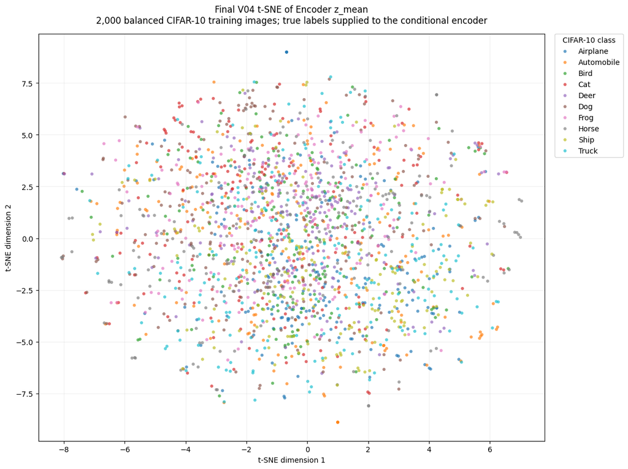

```
Saved t-SNE plot: [local path removed]
```

```python
def load_tsne_dataframe():
    if "tsne_df" in globals() and isinstance(tsne_df, pd.DataFrame):
        return tsne_df.copy()
    if not tsne_csv_path.is_file():
        raise FileNotFoundError(
            "The t-SNE CSV does not exist. Run the fixed t-SNE projection "
            "cell first."
        )
    return pd.read_csv(tsne_csv_path)


def plot_final_v04_tsne(embedding_df):
    required_columns = {
        "class_id",
        "class_name",
        "tsne_1",
        "tsne_2"
    }
    missing = required_columns.difference(embedding_df.columns)
    if missing:
        raise ValueError(f"Missing t-SNE columns: {sorted(missing)}")

    fig, ax = plt.subplots(figsize=(12, 9))

    for class_id, class_name in enumerate(CLASS_NAMES):
        class_rows = embedding_df[embedding_df["class_id"] == class_id]
        ax.scatter(
            class_rows["tsne_1"],
            class_rows["tsne_2"],
            s=18,
            alpha=0.68,
            label=class_name,
            edgecolors="none"
        )

    ax.set_title(
        "Final V04 t-SNE of Encoder z_mean\n"
        "2,000 balanced CIFAR-10 training images; true labels supplied "
        "to the conditional encoder",
        pad=14
    )
    ax.set_xlabel("t-SNE dimension 1")
    ax.set_ylabel("t-SNE dimension 2")
    ax.grid(alpha=0.2)
    ax.legend(
        title="CIFAR-10 class",
        bbox_to_anchor=(1.02, 1.0),
        loc="upper left",
        borderaxespad=0.0
    )

    fig.tight_layout()
    fig.savefig(
        tsne_plot_path,
        dpi=220,
        bbox_inches="tight"
    )
    plt.show()

    print(f"Saved t-SNE plot: {tsne_plot_path}")


plot_final_v04_tsne(load_tsne_dataframe())
```

#### 13.5.7 Result Interpretation

**Observation.**  
The 2,000 latent means form one broad, heavily overlapping projection rather than ten compact class-separated clusters. All ten class colours are distributed through the central region and across much of the outer area. A few small same-class neighbourhoods appear, but no animal or vehicle class occupies a clearly isolated region, and the plot does not support a claim of strong class separation.

**Meaning.**  
Under this fixed t-SNE configuration, V04's 64-dimensional `z_mean` representation appears to preserve continuous image-level variation shared across classes more strongly than discrete class identity. One plausible reason is that the conditional VAE supplies the class label separately, allowing the latent vector to focus on appearance factors that can occur across several classes rather than reserving a separate latent region for each class. The plot does not establish that the latent space is disentangled, and it does not reveal what any individual latent dimension represents.

**Conditional-model caveat.**  
The true one-hot class label was provided to the encoder for every image. The mixed projection therefore cannot be described as unsupervised class discovery. It also does not prove that conditioning failed, because the model may use the explicit label directly while keeping substantial image variation in a shared latent space. Conversely, the occasional same-class local groupings are too limited to justify claiming that V04 learned ten distinct class clusters.

**t-SNE caveat.**  
t-SNE is a non-linear two-dimensional projection designed mainly to preserve local neighbourhood relationships. The axis directions have no semantic meaning, while global distances, apparent cluster sizes, and the overall arrangement should not be treated as exact properties of the original 64-dimensional latent space. The result is also specific to the fixed sample and t-SNE settings used here.

**Role in the final VAE argument.**  
This is supporting post-selection evidence about the organisation of the frozen V04 encoder representation. Its value is diagnostic rather than promotional: it shows that the final conditional VAE does not produce visibly discrete class partitions in this two-dimensional projection. The heavily mixed projection is consistent with the 12% requested-class agreement in the limited sense that neither result supports strong class-specific organisation, but the plot cannot explain the low agreement because the class label is supplied separately and t-SNE is only a two-dimensional diagnostic. It does not replace the existing reconstruction, generation, conditional-control, diversity, FID, stability, and reload-verification evidence used to select and freeze V04.

**Decision.**  
V04 remains frozen. No training, tuning, checkpoint change, model-selection rule, or official test-set access is introduced by this visualisation.

#### 13.5.8 Artifact Audit

The final audit verifies that the cached latent vectors, t-SNE coordinates, metadata, and plot all exist, that exactly 2,000 samples are present, and that every CIFAR-10 class contributes exactly 200 images. It also records that the selected model, weights, training state, and official test-set policy remain unchanged.

```python
# Final artifact audit for the integrated VAE notebook.
required_outputs = [
    latent_cache_path,
    tsne_csv_path,
    tsne_metadata_path,
    tsne_plot_path
]

missing_outputs = [
    str(path) for path in required_outputs if not path.is_file()
]
if missing_outputs:
    raise FileNotFoundError(
        "Missing expected t-SNE outputs:\n"
        + "\n".join(f"- {path}" for path in missing_outputs)
    )

embedding_audit_df = pd.read_csv(tsne_csv_path)
assert len(embedding_audit_df) == TOTAL_TSNE_SAMPLES
assert embedding_audit_df["class_id"].nunique() == NUM_CLASSES
assert embedding_audit_df[["tsne_1", "tsne_2"]].notna().all().all()

class_count_audit = (
    embedding_audit_df
    .groupby(["class_id", "class_name"])
    .size()
    .rename("count")
    .reset_index()
)
assert np.all(class_count_audit["count"].to_numpy() == SAMPLES_PER_CLASS)

display(class_count_audit)
print("Final V04 t-SNE artifact audit passed.")
print("Selected model changed: No")
print("Weights changed: No")
print("Model retrained: No")
print("Official test-set usage: None")
print(f"Supplemental t-SNE plot: {tsne_plot_path}")
```

|  | class_id | class_name | count |
| --- | --- | --- | --- |
| 0 | 0 | Airplane | 200 |
| 1 | 1 | Automobile | 200 |
| 2 | 2 | Bird | 200 |
| 3 | 3 | Cat | 200 |
| 4 | 4 | Deer | 200 |
| 5 | 5 | Dog | 200 |
| 6 | 6 | Frog | 200 |
| 7 | 7 | Horse | 200 |
| 8 | 8 | Ship | 200 |
| 9 | 9 | Truck | 200 |

```
Final V04 t-SNE artifact audit passed.
Selected model changed: No
Weights changed: No
Model retrained: No
Official test-set usage: None
Supplemental t-SNE plot: [local path removed]
```

## 14. Final V04 Inference Contract and Handoff

### 14.1 Frozen Decoder Contract

The selected VAE-family model is **V04 at epoch 50**. Its standalone decoder expects two inputs:

1. `float32` latent vectors with shape `(N, 64)`, sampled from a standard normal distribution; and
2. `float32` one-hot labels with shape `(N, 10)`.

The fixed class order is:

`Airplane, Automobile, Bird, Cat, Deer, Dog, Frog, Horse, Ship, Truck`

The decoder returns RGB images with shape `(N, 32, 32, 3)` in the range `[0, 1]`. Convert to uint8 only after clipping:

`np.rint(np.clip(images, 0, 1) * 255).astype(np.uint8)`

The verified handoff package contains the standalone decoder, full-model and component weights, configuration and development metadata, a hashed export inventory, and the handoff manifest. The complete evaluation, manual-scoring evidence, fixed inputs, reference outputs and reload-verification records are retained in the same package. Exact storage paths and filenames remain inside the executable code and machine-readable manifest rather than the explanatory report.

The t-SNE coordinates, metadata, plot, and latent cache are retained as additional post-selection evaluation artefacts. They are not required to reconstruct the decoder and do not change the frozen inference contract.

### 14.2 Limitations and Responsible Interpretation

- **No sample was rated Clear.** V04 improved the acceptable rate over V00 from 60% to 71%, but all acceptable images remained Marginal.
- **Class control is weak.** Requested-class agreement was 12%, only two percentage points above the descriptive 10% random-guess reference.
- **Class performance is uneven.** Automobile achieved 60% agreement, while Cat, Dog and Horse achieved 0%. These per-class results use only 10 images each.
- **Human evaluation is subjective.** It used one development rater, although the sample order was blinded and all 100 images were retained.
- **FID is a proxy.** InceptionV3 is trained on ImageNet and its features are not perfectly aligned with 32 x 32 CIFAR-10 images.
- **VAE blur remains visible.** The reconstruction and SSIM improvements reduce structural error but do not guarantee sharp semantic objects.
- **The post-selection t-SNE projection is heavily overlapping.** Under the fixed projection, V04's `z_mean` representations do not form ten clean class-separated clusters. Because true labels are supplied separately to the conditional encoder and t-SNE does not preserve global geometry reliably, this is supporting latent-space evidence rather than proof of failed conditioning or disentanglement.
- **Development evidence must not become test-set tuning.** No official test image was used for architecture selection, model improvement, manual scoring or freezing.

### 14.3 Work Reserved for Notebook 4

Notebook 4 must use the frozen GAN and VAE packages without changing their architecture, weights or preprocessing. It remains responsible for:

- validating both handoff manifests;
- loading both standalone generation models;
- applying the same final FID and nearest-neighbour protocols;
- conducting any fresh matched cross-family visual comparison required by the shared plan;
- presenting the RGB-versus-grayscale conclusion with its evidence asymmetry stated explicitly: the GAN side is supported by a real grayscale experiment, while the VAE side remains an untested hypothesis from Section 5.5 and must not be presented as equally evidenced;
- selecting the overall GAN-versus-VAE winner using the declared evidence;
- using the official test reference only at the agreed one-time final stage; and
- generating the official balanced 1,000-image submission only from the overall winner.

The current manifest correctly records:

- official test-set usage: **False**;
- overall GAN-versus-VAE selection completed: **False**; and
- official 1,000 images generated: **False**.

## 15. VAE Family Conclusion

The VAE track began by comparing Dense, ConvTranspose and UpSampling decoder designs under a common training and evaluation protocol. V00 ConvTranspose provided the strongest baseline balance across development FID, diversity, repetition, reconstruction quality and matched visual evidence, and was therefore retained for systematic improvement.

The subsequent experiments tested focused changes rather than accumulating every modification:

| Experiment | Main change | Decision |
| --- | --- | --- |
| V01 | Reduce `β` from `1.0` to `0.5` | Accepted as the stronger unconditional parent |
| V02 | Increase latent dimension from `64` to `128` | Rejected because the modest gains did not justify the efficiency and diversity trade-offs |
| V03 | Add one-hot class conditioning to V01 | Retained as the conditional parent |
| V04 | Replace BCE with the combined L1 + SSIM reconstruction objective | Accepted as the final incumbent |
| V05 | Replace Adam with AdamW while keeping V04 otherwise fixed | Rejected because its marginal FID gain did not provide a stronger overall trade-off |

V04 was selected for its overall evidence rather than because it won every metric. Its repeated-generation development FID was `145.5441 ± 0.3302`, compared with `166.6486 ± 0.4074` for V00, while reconstruction measures also improved relative to V03. V05 achieved a slightly lower mean FID, but the `0.29%` difference was accompanied by weaker results on several supporting measures and `48.29%` longer recorded training time.

The blinded evaluation confirmed rather than overturned the quantitative selection. V04 achieved `71` acceptable images out of `100`, but produced no Clear images and only `12%` requested-class agreement, leaving prior-sampled visual quality and class control as important limitations.

Finally, the standalone frozen decoder reproduced all `100` reference outputs exactly after independent reload, with zero numerical difference and `100/100` unique uint8 samples. The post-selection t-SNE projection showed substantial class overlap and is retained only as a diagnostic of the conditional latent representation.

**Final VAE status: V04 at epoch `50` is complete, frozen and independently reload-verified for the shared GAN-versus-VAE comparison.**

## 16. References

1. D. P. Kingma and M. Welling, [“Auto-Encoding Variational Bayes”](https://arxiv.org/abs/1312.6114), 2013.
2. Singapore Polytechnic, *ST1504 Topic 5: Generative Adversarial Networks*, AY2026/27 Semester 1 lecture material.
3. Singapore Polytechnic, *ST1504 Lab 5: GAN and VAE Practical Materials*, AY2026/27 Semester 1.
4. A. Krizhevsky, [“Learning Multiple Layers of Features from Tiny Images”](https://www.cs.toronto.edu/~kriz/learning-features-2009-TR.pdf), Technical Report, 2009.
5. M. Heusel, H. Ramsauer, T. Unterthiner, B. Nessler and S. Hochreiter, [“GANs Trained by a Two Time-Scale Update Rule Converge to a Local Nash Equilibrium”](https://proceedings.neurips.cc/paper/2017/hash/8a1d694707eb0fefe65871369074926d-Abstract.html), *NeurIPS*, 2017.
6. Z. Wang, A. C. Bovik, H. R. Sheikh and E. P. Simoncelli, [“Image Quality Assessment: From Error Visibility to Structural Similarity”](https://ece.uwaterloo.ca/~z70wang/publications/ssim.html), *IEEE Transactions on Image Processing*, 13(4), 2004.
7. I. Loshchilov and F. Hutter, [“Decoupled Weight Decay Regularization”](https://openreview.net/pdf?id=Bkg6RiCqY7), *ICLR*, 2019.
8. K. Sohn, H. Lee and X. Yan, [“Learning Structured Output Representation using Deep Conditional Generative Models”](https://proceedings.neurips.cc/paper/2015/hash/8d55a249e6baa5c06772297520da2051-Abstract.html), *NeurIPS*, 2015.
9. L. van der Maaten and G. Hinton, [“Visualizing Data using t-SNE”](https://jmlr.org/papers/v9/vandermaaten08a.html), *Journal of Machine Learning Research*, 9, pp. 2579-2605, 2008.